# FPET-Style Hierarchical Logistic Growth Model for Modern Contraceptive Prevalence (mCPR): Best-Compromise Variant

## 21.7 Decision space: growth vs headroom (as-of 2026)

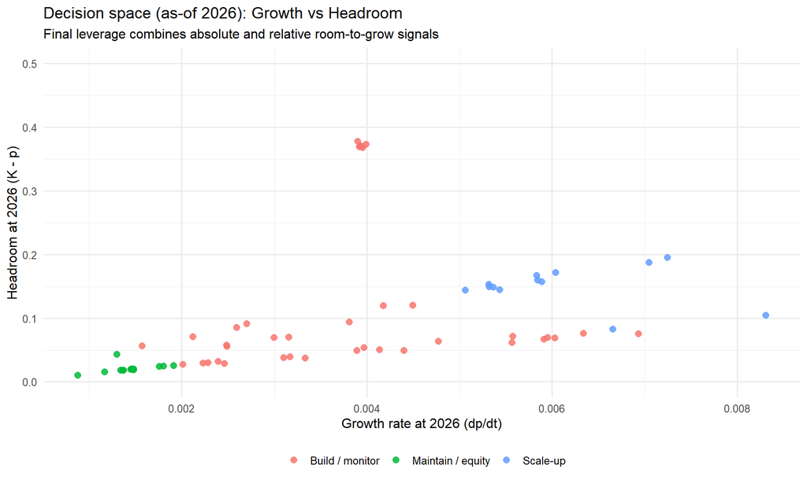

```r
# Visualize phase decision space using growth vs absolute headroom.
ggplot(investment_table, aes(x = dpdt_mean, y = head_mean, color = phase)) +
  geom_point(alpha = 0.85, size = 2.5) +
  coord_cartesian(ylim = c(0, 0.5)) +
  theme_minimal(base_size = 12) +
  labs(
    title = "Decision space (as-of 2026): Growth vs Headroom",
    subtitle = "Final leverage combines absolute and relative room-to-grow signals",
    x = "Growth rate at 2026 (dp/dt)",
    y = "Headroom at 2026 (K - p)"
  ) +
  theme(legend.position = "bottom", legend.title = element_blank())
```

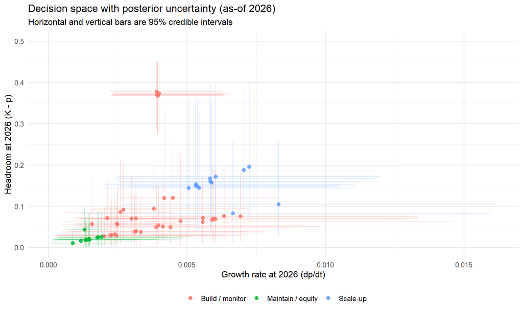

```r
# Companion view with posterior uncertainty bars on both axes.
ggplot(investment_table, aes(x = dpdt_mean, y = head_mean, color = phase)) +
  geom_errorbar(aes(ymin = head_p05, ymax = head_p95), alpha = 0.25, linewidth = 0.5) +
  geom_errorbarh(aes(xmin = dpdt_p05, xmax = dpdt_p95), alpha = 0.25, linewidth = 0.5) +
  geom_point(alpha = 0.85, size = 2.2) +
  coord_cartesian(ylim = c(0, 0.5)) +
  theme_minimal(base_size = 12) +
  labs(
    title = "Decision space with posterior uncertainty (as-of 2026)",
    subtitle = "Horizontal and vertical bars are 95% credible intervals",
    x = "Growth rate at 2026 (dp/dt)",
    y = "Headroom at 2026 (K - p)"
  ) +
  theme(legend.position = "bottom", legend.title = element_blank())
```

# 22 Country-level posterior projections (all countries)

Interpretation: a) Each panel shows the posterior mean mCPR trajectory for one country. b) The panel label reports `2026 - t0`, the number of years between the 2026 decision point and the posterior mean inflection year. c) The ochre horizontal band and line show the 95% credible interval and posterior mean for the country ceiling `K`. d) The blue vertical band and line show the 95% credible interval and posterior mean for the inflection year `t0`. e) The grey dotted line marks the last observed DHS survey year, and each panel projects 10 years beyond that point.

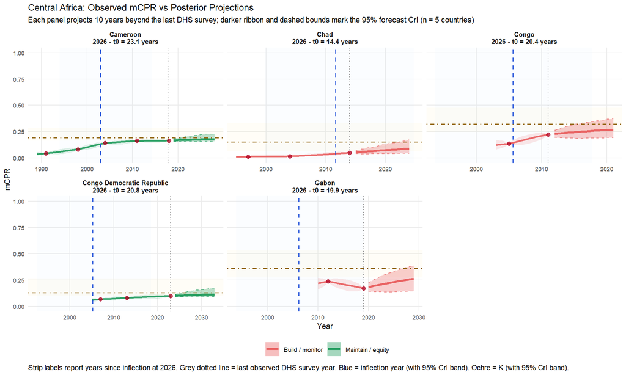

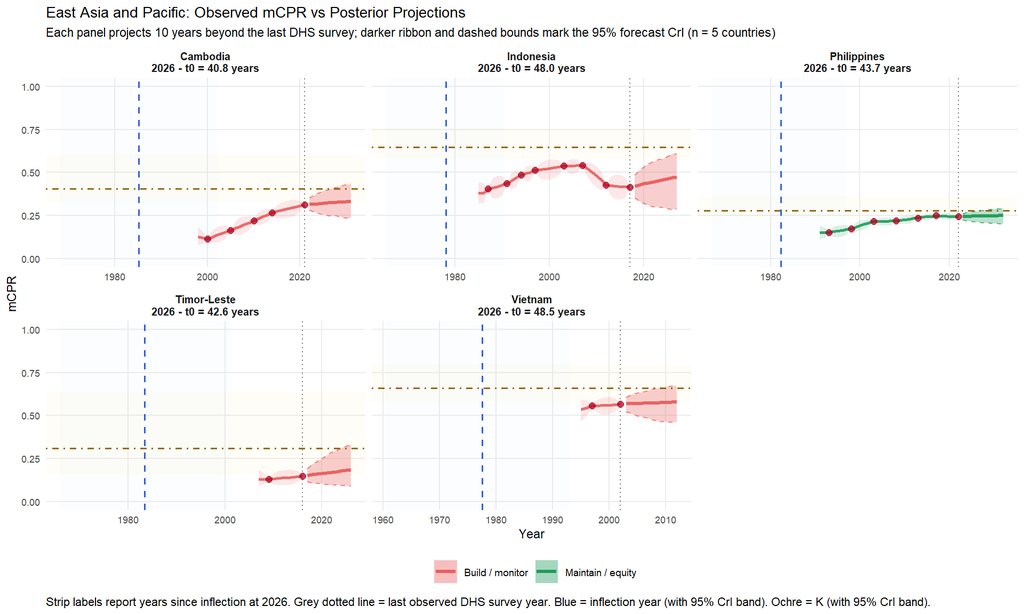

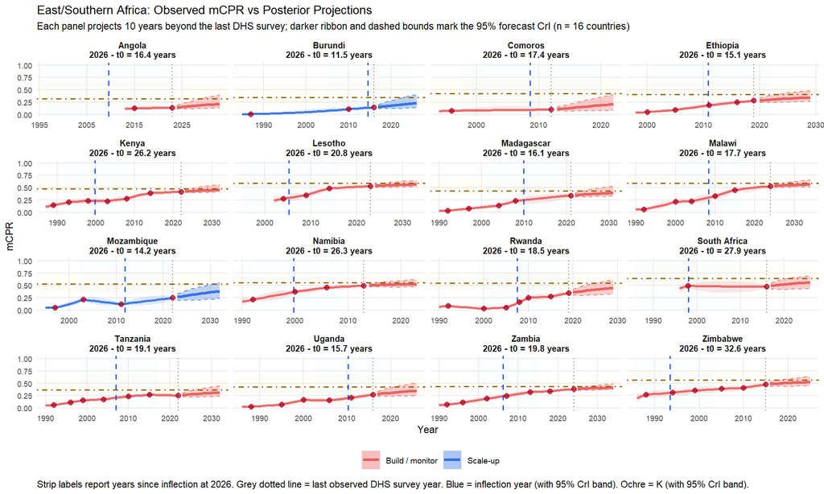

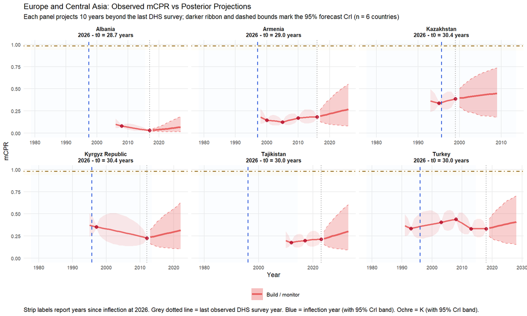

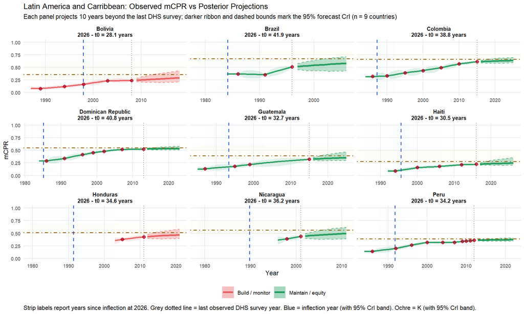

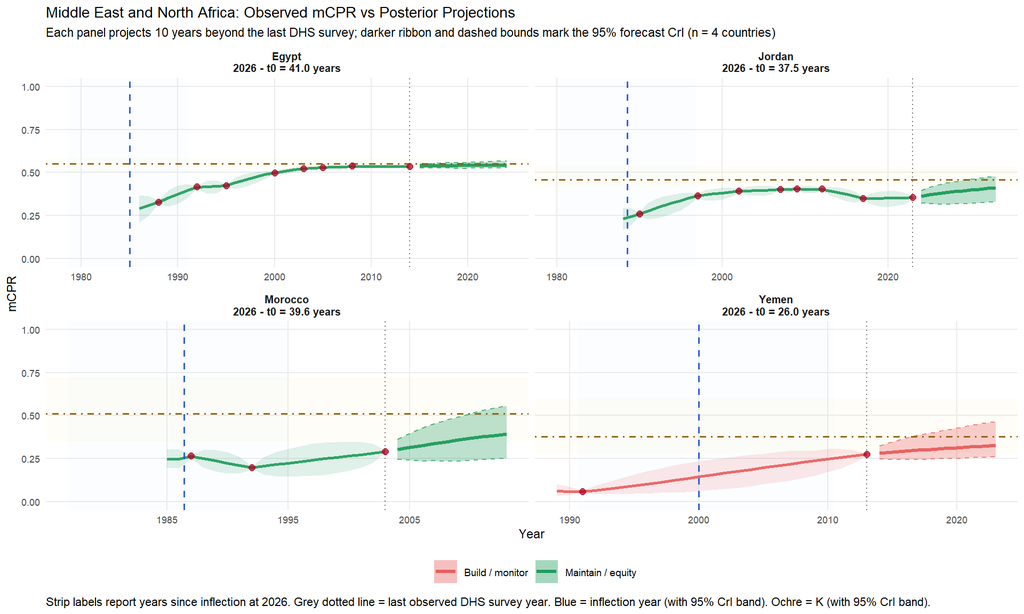

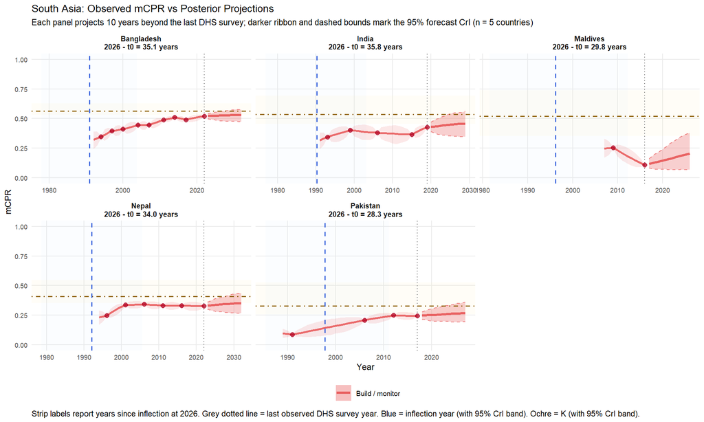

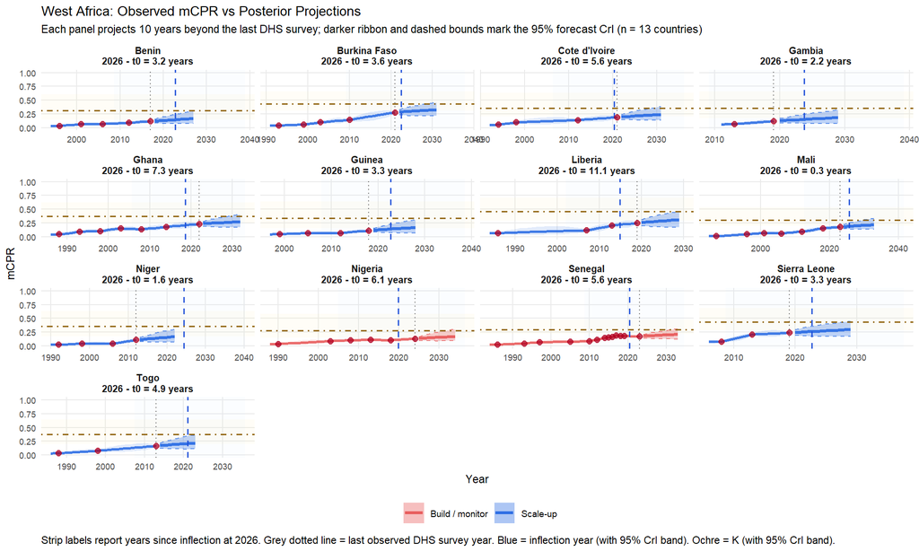

```r
# Plot posterior trajectories for all countries, split by region so each
# rendered figure stays readable and only shows a modest number of countries.
phase_order <- c("Scale-up", "Build / monitor", "Maintain / equity")

country_obs_window <- mcpr_logistic_data %>%
  group_by(country) %>%
  summarise(
    first_obs_year = min(year, na.rm = TRUE),
    last_obs_year = max(year, na.rm = TRUE),
    .groups = "drop"
  )

country_region_lookup <- mcpr_logistic_data %>%
  distinct(country, region)

curve_guides <- investment_table %>%
  left_join(country_obs_window, by = "country") %>%
  left_join(country_region_lookup, by = "country") %>%
  transmute(
    country,
    region,
    phase,
    leverage,
    first_obs_year,
    last_obs_year,
    forecast_end_year = last_obs_year + 10,
    K_mean,
    K_p05,
    K_p95,
    t0_year_mean = 2000 + t0_mean,
    t0_year_p05 = 2000 + t0_p05,
    t0_year_p95 = 2000 + t0_p95,
    years_since_t0_2026 = 2026 - (2000 + t0_mean)
  ) %>%
  filter(
    is.finite(K_mean), is.finite(K_p05), is.finite(K_p95),
    is.finite(t0_year_mean), is.finite(t0_year_p05), is.finite(t0_year_p95),
    is.finite(last_obs_year), is.finite(forecast_end_year)
  )

country_order <- curve_guides %>%
  mutate(region = factor(region, levels = region_label_lookup$region)) %>%
  mutate(phase = factor(phase, levels = phase_order)) %>%
  arrange(region, phase, desc(leverage), country) %>%
  pull(country)

curve_guides <- curve_guides %>%
  mutate(
    country = factor(country, levels = country_order),
    country_label = paste0(
      as.character(country),
      "\n2026 - t0 = ",
      sprintf("%.1f", years_since_t0_2026),
      " years"
    )
  )

country_labeller <- setNames(
  curve_guides$country_label,
  as.character(curve_guides$country)
)

years <- seq(
  min(mcpr_logistic_data$year, na.rm = TRUE) - 2,
  max(curve_guides$forecast_end_year, na.rm = TRUE),
  by = 1
)

nd_grid <- mcpr_logistic_data %>%
  distinct(country, region_prior, s_region_fixed) %>%
  mutate(country = as.character(country)) %>%
  left_join(
    curve_guides %>%
      transmute(country = as.character(country), region, phase, first_obs_year, last_obs_year, forecast_end_year),
    by = "country"
  ) %>%
  tidyr::crossing(year = years) %>%
  filter(
    year >= first_obs_year - 2,
    year <= forecast_end_year
  ) %>%
  mutate(
    region_prior = as.character(region_prior),
    year_center = year - 2000,
    n = 1,
    y = 0
  )

ep <- posterior_epred(fit_logistic, newdata = nd_grid, re_formula = NULL)

summ <- tibble(
  country = nd_grid$country,
  region = nd_grid$region,
  phase = nd_grid$phase,
  year = nd_grid$year,
  first_obs_year = nd_grid$first_obs_year,
  last_obs_year = nd_grid$last_obs_year,
  forecast_end_year = nd_grid$forecast_end_year,
  p_mean = colMeans(ep),
  p_lo = apply(ep, 2, quantile, ci_lower),
  p_hi = apply(ep, 2, quantile, ci_upper)
) %>%
  mutate(
    segment = if_else(year <= last_obs_year, "historical", "forecast")
  ) %>%
  left_join(
    curve_guides %>%
      transmute(country = as.character(country), country_factor = country),
    by = "country"
  ) %>%
  mutate(country = country_factor) %>%
  select(-country_factor)

obs_subset <- mcpr_logistic_data %>%
  left_join(
    curve_guides %>%
      transmute(country = as.character(country), phase, country_factor = country),
    by = "country"
  ) %>%
  mutate(country = country_factor) %>%
  filter(!is.na(country)) %>%
  select(country, region, phase, year, mCPR)

# Consistent color direction across phases.
phase_cols <- c(
  "Scale-up" = "#2F6FE4",
  "Build / monitor" = "#E85D5D",
  "Maintain / equity" = "#1E9B5B"
)

region_plot_order <- curve_guides %>%
  distinct(region) %>%
  mutate(region = factor(region, levels = region_label_lookup$region)) %>%
  arrange(region) %>%
  pull(region) %>%
  as.character()

make_region_country_plot <- function(region_name) {
  region_guides <- curve_guides %>%
    filter(region == region_name)

  region_summ <- summ %>%
    filter(region == region_name)

  region_obs <- obs_subset %>%
    filter(region == region_name)

  n_country_region <- nrow(region_guides)
  ncol_region <- dplyr::case_when(
    n_country_region <= 4 ~ 2L,
    n_country_region <= 9 ~ 3L,
    n_country_region <= 16 ~ 4L,
    TRUE ~ 5L
  )

  ggplot() +
    # Horizontal band = 95% CrI for K (country ceiling).
    geom_rect(
      data = region_guides,
      aes(xmin = -Inf, xmax = Inf, ymin = K_p05, ymax = K_p95),
      inherit.aes = FALSE,
      fill = "#FDE68A",
      alpha = 0.07
    ) +
    # Vertical band = 95% CrI for inflection year.
    geom_rect(
      data = region_guides,
      aes(xmin = t0_year_p05, xmax = t0_year_p95, ymin = -Inf, ymax = Inf),
      inherit.aes = FALSE,
      fill = "#BFDBFE",
      alpha = 0.06
    ) +
    geom_vline(
      data = region_guides,
      aes(xintercept = last_obs_year),
      linetype = "dotted",
      linewidth = 0.45,
      color = "grey40",
      alpha = 0.9
    ) +
    geom_ribbon(
      data = region_summ %>% filter(segment == "historical"),
      aes(x = year, ymin = p_lo, ymax = p_hi, fill = phase),
      alpha = 0.14
    ) +
    geom_ribbon(
      data = region_summ %>% filter(segment == "forecast"),
      aes(x = year, ymin = p_lo, ymax = p_hi, fill = phase),
      alpha = 0.30
    ) +
    geom_line(
      data = region_summ %>% filter(segment == "forecast"),
      aes(x = year, y = p_lo, color = phase),
      linewidth = 0.45,
      alpha = 0.70,
      linetype = "dashed"
    ) +
    geom_line(
      data = region_summ %>% filter(segment == "forecast"),
      aes(x = year, y = p_hi, color = phase),
      linewidth = 0.45,
      alpha = 0.70,
      linetype = "dashed"
    ) +
    geom_line(
      data = region_summ %>% filter(segment == "historical"),
      aes(x = year, y = p_mean, color = phase),
      linewidth = 0.9,
      alpha = 0.90
    ) +
    geom_line(
      data = region_summ %>% filter(segment == "forecast"),
      aes(x = year, y = p_mean, color = phase),
      linewidth = 1.15,
      alpha = 0.95
    ) +
    geom_hline(
      data = region_guides,
      aes(yintercept = K_mean),
      linetype = "dotdash",
      linewidth = 0.55,
      color = "#8A5A00",
      alpha = 0.9
    ) +
    geom_vline(
      data = region_guides,
      aes(xintercept = t0_year_mean),
      linetype = "dashed",
      linewidth = 0.55,
      color = "#1D4ED8",
      alpha = 0.9
    ) +
    geom_point(
      data = region_obs,
      aes(x = year, y = mCPR),
      size = 2,
      alpha = 0.75,
      color = "#B00020"
    ) +
    facet_wrap(
      ~ country,
      ncol = ncol_region,
      scales = "free_x",
      labeller = labeller(country = country_labeller)
    ) +
    scale_color_manual(values = phase_cols) +
    scale_fill_manual(values = phase_cols) +
    coord_cartesian(ylim = c(0, 1)) +
    theme_minimal(base_size = 8.8) +
    theme(
      legend.position = "bottom",
      legend.title = element_blank(),
      panel.grid.minor = element_blank(),
      strip.text = element_text(face = "bold", size = 7.4, lineheight = 0.95),
      axis.text.x = element_text(size = 6.9),
      axis.text.y = element_text(size = 6.9),
      plot.caption = element_text(hjust = 0, size = 8.2)
    ) +
    labs(
      title = paste0(region_name, ": Observed mCPR vs Posterior Projections"),
      subtitle = paste0(
        "Each panel projects 10 years beyond the last DHS survey; darker ribbon and dashed bounds mark the 95% forecast CrI (n = ",
        n_country_region,
        " countries)"
      ),
      x = "Year",
      y = "mCPR",
      caption = "Strip labels report years since inflection at 2026. Grey dotted line = last observed DHS survey year. Blue = inflection year (with 95% CrI band). Ochre = K (with 95% CrI band)."
    )
}

purrr::walk(region_plot_order, function(region_name) {
  print(make_region_country_plot(region_name))
})
```

## 22.1 Country-level growth rates over time

This section reports the model-implied annual change in mCPR, $\frac{dp_i(t)}{dt}$, for each country across its observed DHS window and an additional 10-year projection window.

Interpretation:

1. `dpdt_mean` is the posterior mean annual change in mCPR at that calendar year.
2. `dpdt_p05` and `dpdt_p95` are the 95% credible interval bounds for that annual change.
3. `segment` marks whether a given year is inside the observed survey window or in the forward projection period.

```r
# Build a full country-year table of model-implied growth rates using the
# analytic derivative of the logistic S-curve.
country_growth_meta <- curve_guides %>%
  transmute(
    country = as.character(country),
    region,
    phase,
    first_obs_year,
    last_obs_year,
    forecast_end_year,
    country_col = match(as.character(country), countries)
  )

country_growth_rate_table <- bind_rows(
  lapply(seq_len(nrow(country_growth_meta)), function(i) {
    meta_i <- country_growth_meta[i, ]
    year_vec <- seq(meta_i$first_obs_year, meta_i$forecast_end_year, by = 1)
    t_vec <- year_vec - 2000

    t_mat_i <- matrix(rep(t_vec, each = n_draws), nrow = n_draws)
    t0_i <- t0_draws[, meta_i$country_col]
    s_i <- s_draws[, meta_i$country_col]
    K_i <- K_draws[, meta_i$country_col]

    z_i <- exp(-sweep(sweep(t_mat_i, 1, t0_i, "-"), 1, s_i, "/"))
    dpdt_i <- sweep(z_i / (1 + z_i)^2, 1, K_i / s_i, "*")

    tibble(
      country = meta_i$country,
      region = meta_i$region,
      phase = meta_i$phase,
      year = year_vec,
      segment = if_else(year_vec <= meta_i$last_obs_year, "historical", "forecast"),
      dpdt_mean = colMeans(dpdt_i),
      dpdt_p05 = apply(dpdt_i, 2, quantile, ci_lower),
      dpdt_p95 = apply(dpdt_i, 2, quantile, ci_upper)
    )
  })
) %>%
  arrange(region, country, year)

# Use a paged table in the HTML report because the full country-year output is long.
rmarkdown::paged_table(
  country_growth_rate_table %>%
    mutate(across(where(is.numeric), ~ round(.x, 4)))
)
```

| country | region | phase | year | segment | dpdt_mean | dpdt_p05 | dpdt_p95 |
| --- | --- | --- | --- | --- | --- | --- | --- |
| Cameroon | Central Africa | Maintain / equity | 1991 | historical | 0.0035 | 0.0018 | 0.0061 |
| Cameroon | Central Africa | Maintain / equity | 1992 | historical | 0.0038 | 0.0019 | 0.0065 |
| Cameroon | Central Africa | Maintain / equity | 1993 | historical | 0.0040 | 0.0021 | 0.0068 |
| Cameroon | Central Africa | Maintain / equity | 1994 | historical | 0.0042 | 0.0022 | 0.0070 |
| Cameroon | Central Africa | Maintain / equity | 1995 | historical | 0.0044 | 0.0023 | 0.0072 |
| Cameroon | Central Africa | Maintain / equity | 1996 | historical | 0.0045 | 0.0024 | 0.0075 |
| Cameroon | Central Africa | Maintain / equity | 1997 | historical | 0.0047 | 0.0025 | 0.0077 |
| Cameroon | Central Africa | Maintain / equity | 1998 | historical | 0.0048 | 0.0026 | 0.0078 |
| Cameroon | Central Africa | Maintain / equity | 1999 | historical | 0.0048 | 0.0026 | 0.0078 |
| Cameroon | Central Africa | Maintain / equity | 2000 | historical | 0.0049 | 0.0027 | 0.0077 |

[output cut: 2032 more lines]

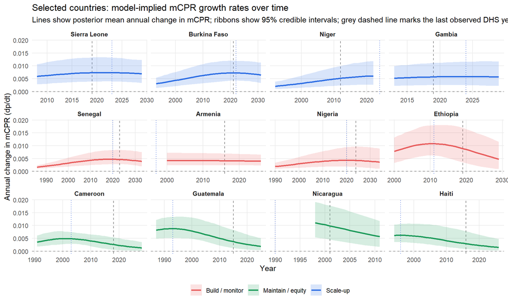

```r
# Plot a readable subset of countries so growth-rate trajectories can be scanned quickly.
pick_growth_plot <- function(df, phase_name, n_pick) {
  df %>%
    filter(phase == phase_name) %>%
    arrange(desc(leverage), country) %>%
    slice_head(n = n_pick)
}

growth_plot_countries <- bind_rows(
  pick_growth_plot(investment_table, "Scale-up", 4),
  pick_growth_plot(investment_table, "Build / monitor", 4),
  pick_growth_plot(investment_table, "Maintain / equity", 4)
) %>%
  distinct(country, .keep_all = TRUE) %>%
  left_join(
    curve_guides %>%
      transmute(country = as.character(country), last_obs_year),
    by = "country"
  )

growth_plot_data <- country_growth_rate_table %>%
  filter(country %in% growth_plot_countries$country) %>%
  left_join(
    growth_plot_countries %>%
      select(country, phase, leverage, last_obs_year, t0_year_mean),
    by = c("country", "phase")
  ) %>%
  mutate(
    country = factor(
      country,
      levels = growth_plot_countries %>%
        arrange(factor(phase, levels = phase_order), desc(leverage), country) %>%
        pull(country)
    )
  )

ggplot(growth_plot_data, aes(x = year, y = dpdt_mean, color = phase, fill = phase)) +
  geom_hline(yintercept = 0, linetype = "dashed", color = "grey55", linewidth = 0.4) +
  geom_vline(
    aes(xintercept = last_obs_year),
    linetype = "dashed",
    color = "grey40",
    linewidth = 0.45,
    alpha = 0.85,
    show.legend = FALSE
  ) +
  geom_ribbon(aes(ymin = dpdt_p05, ymax = dpdt_p95), alpha = 0.18, color = NA) +
  geom_line(linewidth = 1.0) +
  geom_vline(
    aes(xintercept = t0_year_mean),
    linetype = "dotted",
    color = "#1D4ED8",
    linewidth = 0.45,
    alpha = 0.85,
    show.legend = FALSE
  ) +
  facet_wrap(~ country, ncol = 4, scales = "free_x") +
  scale_color_manual(values = phase_cols) +
  scale_fill_manual(values = phase_cols) +
  theme_minimal(base_size = 11) +
  theme(
    legend.position = "bottom",
    legend.title = element_blank(),
    panel.grid.minor = element_blank(),
    strip.text = element_text(face = "bold")
  ) +
  labs(
    title = "Selected countries: model-implied mCPR growth rates over time",
    subtitle = "Lines show posterior mean annual change in mCPR; ribbons show 95% credible intervals; grey dashed line marks the last observed DHS year and blue dotted line marks the posterior mean inflection year",
    x = "Year",
    y = "Annual change in mCPR (dp/dt)"
  )
```

# 23 Sub-Saharan Africa: projected path to 40% mCPR

This section focuses only on the Sub-Saharan Africa analytic regions: a) West Africa b) Central Africa c) East/Southern Africa

The goal is to answer four practical questions: a) where each country is projected to be over the next 10 years; b) when each country is projected to reach 40% mCPR; c) how much annual growth would be needed to get there within 10 years from the latest observed mCPR; d) whether that required growth is broadly consistent with both observed inter-survey growth and the model-implied instantaneous growth profile.

```r
# Build Sub-Saharan Africa summary objects used by the plots and tables below.
ssa_regions <- c("West Africa", "Central Africa", "East/Southern Africa")
target_mcpr_40 <- 0.40

# Latest observed DHS value by SSA country.
ssa_latest_obs <- mcpr_logistic_data %>%
  filter(region %in% ssa_regions, !is.na(mCPR), !is.na(year)) %>%
  group_by(country, region) %>%
  slice_max(order_by = year, n = 1, with_ties = FALSE) %>%
  ungroup() %>%
  transmute(
    country,
    region,
    last_obs_year = year,
    last_obs_mcpr = mCPR
  ) %>%
  arrange(region, country)

# Observation-to-observation annualized growth on the observed DHS scale.
ssa_obs_growth_intervals <- mcpr_logistic_data %>%
  filter(region %in% ssa_regions, !is.na(mCPR), !is.na(year)) %>%
  arrange(country, year) %>%
  group_by(country, region) %>%
  mutate(
    prev_year = lag(year),
    prev_mcpr = lag(mCPR),
    obs_growth_annual = (mCPR - prev_mcpr) / (year - prev_year),
    interval_mid_year = (year + prev_year) / 2
  ) %>%
  filter(!is.na(obs_growth_annual), is.finite(obs_growth_annual)) %>%
  ungroup()

ssa_obs_growth_summary <- ssa_obs_growth_intervals %>%
  group_by(country, region) %>%
  summarise(
    latest_obs_interval_growth = obs_growth_annual[which.max(year)],
    mean_obs_interval_growth = mean(obs_growth_annual, na.rm = TRUE),
    max_obs_interval_growth = max(obs_growth_annual, na.rm = TRUE),
    min_obs_interval_growth = min(obs_growth_annual, na.rm = TRUE),
    n_intervals = n(),
    .groups = "drop"
  )

# Country-specific posterior year when mCPR first reaches 40%.
# If a country is already above 40% at the latest observed mCPR, we report the
# latest observed year as the forward-looking reach year. If K <= 40% in a draw,
# the target is unreachable in that draw.
ssa_country_order_vec <- ssa_latest_obs$country
ssa_country_cols <- match(ssa_country_order_vec, countries)

ssa_last_obs_year_mat <- matrix(
  rep(ssa_latest_obs$last_obs_year, each = n_draws),
  nrow = n_draws,
  ncol = length(ssa_country_cols)
)
ssa_last_obs_mcpr_mat <- matrix(
  rep(ssa_latest_obs$last_obs_mcpr, each = n_draws),
  nrow = n_draws,
  ncol = length(ssa_country_cols)
)

ssa_K_draws <- K_draws[, ssa_country_cols, drop = FALSE]
ssa_t0_draws <- t0_draws[, ssa_country_cols, drop = FALSE]
ssa_s_draws <- s_draws[, ssa_country_cols, drop = FALSE]

reach40_possible_mat <- ssa_K_draws > target_mcpr_40
target_ratio_mat <- pmin(target_mcpr_40 / ssa_K_draws, 0.999999)
t40_year_raw_mat <- 2000 + ssa_t0_draws + ssa_s_draws * qlogis(target_ratio_mat)

ssa_target40_year_mat <- ifelse(
  ssa_last_obs_mcpr_mat >= target_mcpr_40,
  ssa_last_obs_year_mat,
  ifelse(
    reach40_possible_mat,
    pmax(t40_year_raw_mat, ssa_last_obs_year_mat),
    NA_real_
  )
)

ssa_years_to_40_mat <- ssa_target40_year_mat - ssa_last_obs_year_mat

ssa_model_dpdt_lastobs_mat <- dpdt_lastobs_mat[, ssa_country_cols, drop = FALSE]
ssa_model_dpdt_2025_mat <- dpdt_goal_base_mat[, ssa_country_cols, drop = FALSE]

ssa_target40_table <- tibble(
  country = ssa_latest_obs$country,
  region = ssa_latest_obs$region,
  last_obs_year = ssa_latest_obs$last_obs_year,
  last_obs_mcpr = ssa_latest_obs$last_obs_mcpr,
  prob_ever_reach_40 = colMeans(!is.na(ssa_target40_year_mat)),
  projected_year_reach_40_p50 = apply(ssa_target40_year_mat, 2, function(x) if (all(is.na(x))) NA_real_ else median(x, na.rm = TRUE)),
  projected_year_reach_40 = apply(ssa_target40_year_mat, 2, function(x) if (all(is.na(x))) NA_real_ else mean(x, na.rm = TRUE)),
  projected_year_reach_40_p05 = apply(ssa_target40_year_mat, 2, function(x) if (all(is.na(x))) NA_real_ else quantile(x, ci_lower, na.rm = TRUE)),
  projected_year_reach_40_p95 = apply(ssa_target40_year_mat, 2, function(x) if (all(is.na(x))) NA_real_ else quantile(x, ci_upper, na.rm = TRUE)),
  projected_years_from_latest_to_40 = apply(ssa_years_to_40_mat, 2, function(x) if (all(is.na(x))) NA_real_ else mean(x, na.rm = TRUE)),
  required_growth_to_40_10y = pmax(target_mcpr_40 - ssa_latest_obs$last_obs_mcpr, 0) / 10,
  model_dpdt_2025_mean = colMeans(ssa_model_dpdt_2025_mat),
  model_dpdt_2025_p05 = apply(ssa_model_dpdt_2025_mat, 2, quantile, ci_lower),
  model_dpdt_2025_p95 = apply(ssa_model_dpdt_2025_mat, 2, quantile, ci_upper),
  model_dpdt_lastobs_mean = colMeans(ssa_model_dpdt_lastobs_mat),
  model_dpdt_lastobs_p05 = apply(ssa_model_dpdt_lastobs_mat, 2, quantile, ci_lower),
  model_dpdt_lastobs_p95 = apply(ssa_model_dpdt_lastobs_mat, 2, quantile, ci_upper)
) %>%
  left_join(
    ssa_obs_growth_summary,
    by = c("country", "region")
  ) %>%
  left_join(
    investment_table %>%
      transmute(
        country,
        investment_phase = phase,
        leverage,
        K_mean,
        K_p05,
        K_p95,
        t0_year_mean,
        years_since_t0_2026,
        dpdt_mean_2026 = dpdt_mean
      ),
    by = "country"
  ) %>%
  left_join(
    s_curve_stage_table %>%
      transmute(
        country,
        s_curve_stage,
        last_obs_rel_sat_mean,
        years_since_t0_lastobs_mean
      ),
    by = "country"
  ) %>%
  mutate(
    target40_status = case_when(
      last_obs_mcpr >= target_mcpr_40 ~ "Already crossed",
      is.na(projected_year_reach_40_p50) ~ "Not projected to cross",
      projected_year_reach_40_p50 <= 2035 ~ "Projected to cross by 2035",
      TRUE ~ "Projected to cross after 2035"
    ),
    required_growth_pp_per_year = 100 * required_growth_to_40_10y,
    latest_obs_interval_growth_pp_per_year = 100 * latest_obs_interval_growth,
    max_obs_interval_growth_pp_per_year = 100 * max_obs_interval_growth,
    model_dpdt_2025_pp_per_year = 100 * model_dpdt_2025_mean,
    model_dpdt_lastobs_pp_per_year = 100 * model_dpdt_lastobs_mean,
    model_dpdt_2026_pp_per_year = 100 * dpdt_mean_2026
  ) %>%
  arrange(
    factor(region, levels = ssa_regions),
    factor(
      target40_status,
      levels = c(
        "Projected to cross by 2035",
        "Projected to cross after 2035",
        "Already crossed",
        "Not projected to cross"
      )
    ),
    projected_year_reach_40_p50,
    country
  )
```

## 23.1 Sub-Saharan Africa: observed trajectories and 10-year projections

Interpretation: a) red points are observed DHS mCPR values; b) solid colored lines are posterior mean trajectories; c) ribbons are 95% credible intervals; d) the grey dotted line marks the year of the latest observed mCPR; e) the blue dashed line marks the posterior mean inflection year; f) the grey horizontal line marks the 40% target.

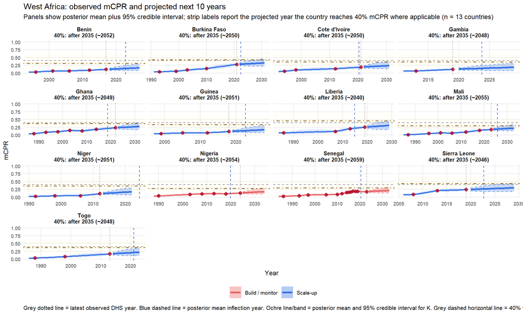

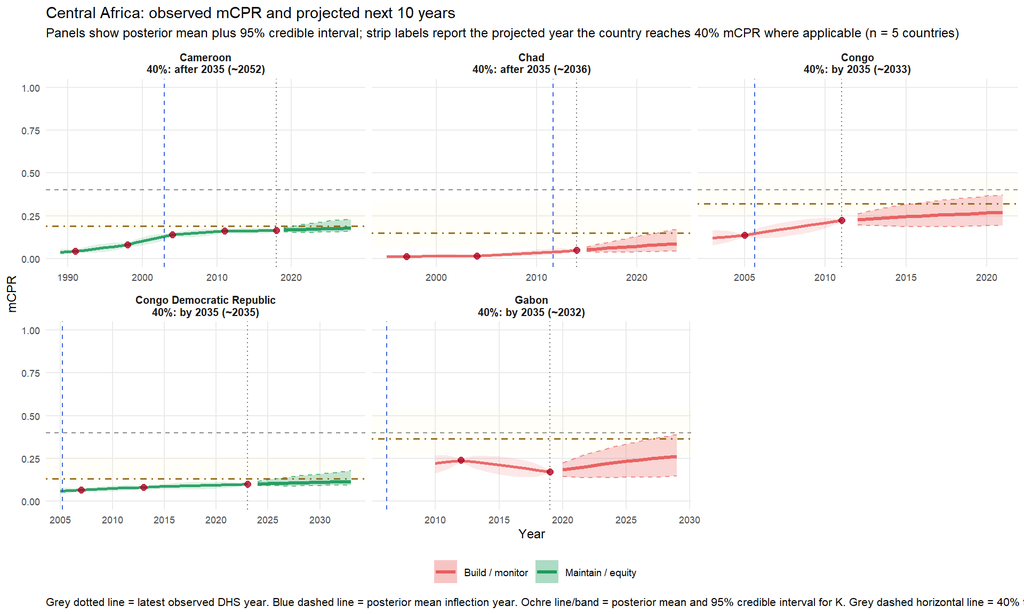

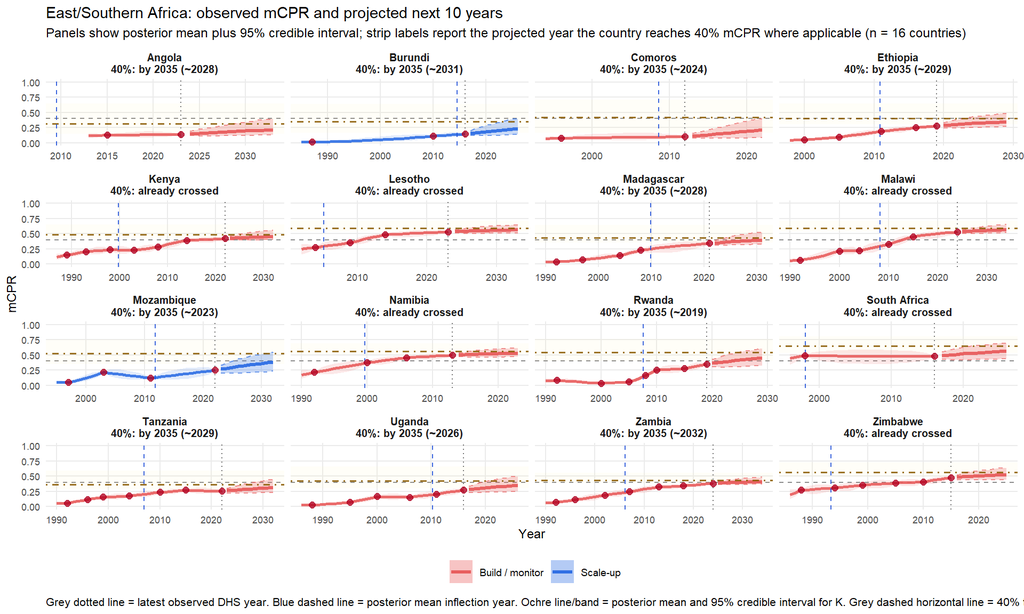

```r
# Plot SSA country trajectories and 10-year projections, grouped by SSA subregion.
ssa_curve_guides <- curve_guides %>%
  filter(region %in% ssa_regions) %>%
  left_join(
    ssa_target40_table %>%
      select(country, target40_status, projected_year_reach_40_p50),
    by = c("country" = "country")
  )

ssa_country_labeller <- setNames(
  paste0(
    as.character(ssa_curve_guides$country),
    "\n40%: ",
    dplyr::case_when(
      ssa_curve_guides$target40_status == "Already crossed" ~ "already crossed",
      ssa_curve_guides$target40_status == "Not projected to cross" ~ "not projected",
      ssa_curve_guides$target40_status == "Projected to cross by 2035" ~ paste0("by 2035 (~", round(ssa_curve_guides$projected_year_reach_40_p50), ")"),
      TRUE ~ paste0("after 2035 (~", round(ssa_curve_guides$projected_year_reach_40_p50), ")")
    )
  ),
  as.character(ssa_curve_guides$country)
)

make_ssa_projection_plot <- function(region_name) {
  region_guides <- ssa_curve_guides %>%
    filter(region == region_name)

  region_summ <- summ %>%
    filter(region == region_name, country %in% region_guides$country)

  region_obs <- obs_subset %>%
    filter(region == region_name, country %in% region_guides$country)

  n_country_region <- nrow(region_guides)
  ncol_region <- dplyr::case_when(
    n_country_region <= 4 ~ 2L,
    n_country_region <= 9 ~ 3L,
    n_country_region <= 16 ~ 4L,
    TRUE ~ 5L
  )

  ggplot() +
    geom_hline(yintercept = target_mcpr_40, linetype = "dashed", color = "grey55", linewidth = 0.45) +
    geom_rect(
      data = region_guides,
      aes(xmin = -Inf, xmax = Inf, ymin = K_p05, ymax = K_p95),
      inherit.aes = FALSE,
      fill = "#FDE68A",
      alpha = 0.06
    ) +
    geom_vline(
      data = region_guides,
      aes(xintercept = last_obs_year),
      linetype = "dotted",
      linewidth = 0.45,
      color = "grey40",
      alpha = 0.9
    ) +
    geom_ribbon(
      data = region_summ %>% filter(segment == "historical"),
      aes(x = year, ymin = p_lo, ymax = p_hi, fill = phase),
      alpha = 0.14
    ) +
    geom_ribbon(
      data = region_summ %>% filter(segment == "forecast"),
      aes(x = year, ymin = p_lo, ymax = p_hi, fill = phase),
      alpha = 0.26
    ) +
    geom_line(
      data = region_summ %>% filter(segment == "forecast"),
      aes(x = year, y = p_lo, color = phase),
      linewidth = 0.42,
      alpha = 0.65,
      linetype = "dashed"
    ) +
    geom_line(
      data = region_summ %>% filter(segment == "forecast"),
      aes(x = year, y = p_hi, color = phase),
      linewidth = 0.42,
      alpha = 0.65,
      linetype = "dashed"
    ) +
    geom_line(
      data = region_summ %>% filter(segment == "historical"),
      aes(x = year, y = p_mean, color = phase),
      linewidth = 0.9,
      alpha = 0.9
    ) +
    geom_line(
      data = region_summ %>% filter(segment == "forecast"),
      aes(x = year, y = p_mean, color = phase),
      linewidth = 1.1,
      alpha = 0.95
    ) +
    geom_hline(
      data = region_guides,
      aes(yintercept = K_mean),
      linetype = "dotdash",
      linewidth = 0.55,
      color = "#8A5A00",
      alpha = 0.85
    ) +
    geom_vline(
      data = region_guides,
      aes(xintercept = t0_year_mean),
      linetype = "dashed",
      linewidth = 0.5,
      color = "#1D4ED8",
      alpha = 0.85
    ) +
    geom_point(
      data = region_obs,
      aes(x = year, y = mCPR),
      size = 2,
      alpha = 0.78,
      color = "#B00020"
    ) +
    facet_wrap(
      ~ country,
      ncol = ncol_region,
      scales = "free_x",
      labeller = labeller(country = ssa_country_labeller)
    ) +
    scale_color_manual(values = phase_cols) +
    scale_fill_manual(values = phase_cols) +
    coord_cartesian(ylim = c(0, 1)) +
    theme_minimal(base_size = 9) +
    theme(
      legend.position = "bottom",
      legend.title = element_blank(),
      panel.grid.minor = element_blank(),
      strip.text = element_text(face = "bold", size = 7.4, lineheight = 0.95),
      axis.text.x = element_text(size = 6.8),
      axis.text.y = element_text(size = 6.8),
      plot.caption = element_text(hjust = 0, size = 8.0)
    ) +
    labs(
      title = paste0(region_name, ": observed mCPR and projected next 10 years"),
      subtitle = paste0("Panels show posterior mean plus 95% credible interval; strip labels report the projected year the country reaches 40% mCPR where applicable (n = ", n_country_region, " countries)"),
      x = "Year",
      y = "mCPR",
      caption = "Grey dotted line = latest observed DHS year. Blue dashed line = posterior mean inflection year. Ochre line/band = posterior mean and 95% credible interval for K. Grey dashed horizontal line = 40% target."
    )
}

purrr::walk(ssa_regions, function(region_name) {
  print(make_ssa_projection_plot(region_name))
})
```

## 23.2 Sub-Saharan Africa: projected year each country reaches 40% mCPR

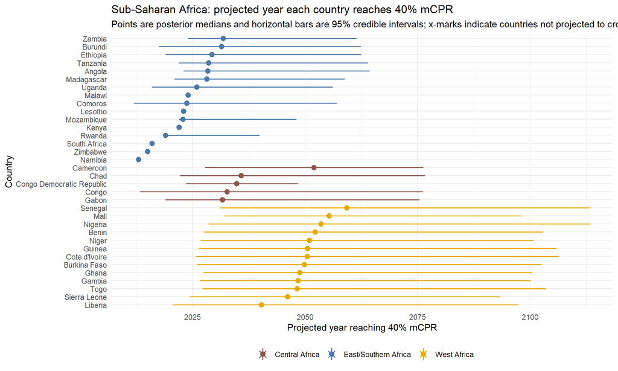

```r
# Plot projected year to 40% mCPR for all SSA countries. Countries not
# projected to cross are shown with an x-marker and label at the top of the plot.
ssa_year40_plot_cap <- max(ssa_target40_table$projected_year_reach_40_p95, na.rm = TRUE) + 2

ssa_year40_plot_data <- ssa_target40_table %>%
  mutate(
    year40_plot = dplyr::case_when(
      target40_status == "Already crossed" ~ as.numeric(last_obs_year),
      target40_status == "Not projected to cross" ~ as.numeric(ssa_year40_plot_cap),
      TRUE ~ as.numeric(projected_year_reach_40_p50)
    ),
    year40_p05_plot = dplyr::case_when(
      target40_status == "Already crossed" ~ as.numeric(last_obs_year),
      target40_status == "Not projected to cross" ~ NA_real_,
      TRUE ~ as.numeric(projected_year_reach_40_p05)
    ),
    year40_p95_plot = dplyr::case_when(
      target40_status == "Already crossed" ~ as.numeric(last_obs_year),
      target40_status == "Not projected to cross" ~ NA_real_,
      TRUE ~ as.numeric(projected_year_reach_40_p95)
    ),
    country = factor(
      country,
      levels = ssa_target40_table %>%
        arrange(factor(region, levels = ssa_regions), year40_plot, country) %>%
        pull(country)
    )
  )

ggplot(ssa_year40_plot_data, aes(x = country, color = region)) +
  geom_pointrange(
    data = ssa_year40_plot_data %>% filter(target40_status != "Not projected to cross"),
    aes(y = year40_plot, ymin = year40_p05_plot, ymax = year40_p95_plot),
    linewidth = 0.55
  ) +
  geom_point(
    data = ssa_year40_plot_data %>% filter(target40_status == "Not projected to cross"),
    aes(y = year40_plot),
    shape = 4,
    size = 2.8,
    stroke = 0.9
  ) +
  geom_text(
    data = ssa_year40_plot_data %>% filter(target40_status == "Not projected to cross"),
    aes(y = year40_plot + 0.6, label = "Not projected"),
    color = "grey25",
    size = 3,
    hjust = 0
  ) +
  coord_flip() +
  theme_minimal(base_size = 11) +
  scale_color_manual(values = region_palette) +
  labs(
    title = "Sub-Saharan Africa: projected year each country reaches 40% mCPR",
    subtitle = "Points are posterior medians and horizontal bars are 95% credible intervals; x-marks indicate countries not projected to cross 40%",
    x = "Country",
    y = "Projected year reaching 40% mCPR"
  ) +
  theme(legend.position = "bottom", legend.title = element_blank())
```

## 23.3 Sub-Saharan Africa: required versus observed and model-implied growth

Interpretation: a) the red horizontal line is the annual growth required to move from the latest observed mCPR to 40% within 10 years; b) black points and lines are observed inter-survey annualized growth rates; c) the colored curve and ribbon are the model-implied instantaneous annual growth rate and its 95% credible interval; d) this comparison shows whether the 40% target is close to, or well above, the growth rates already observed and implied by the fitted trajectory.

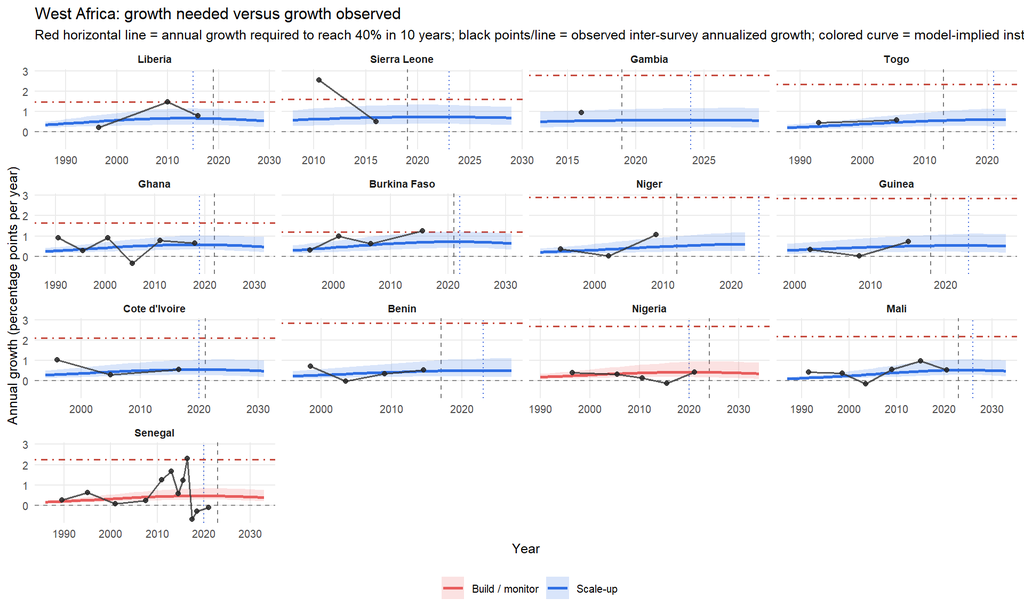

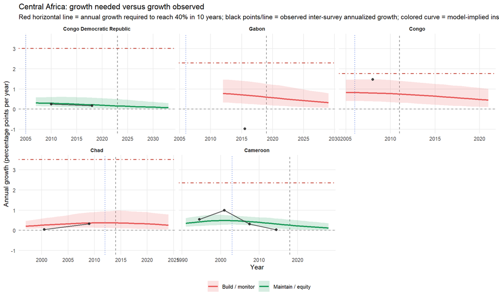

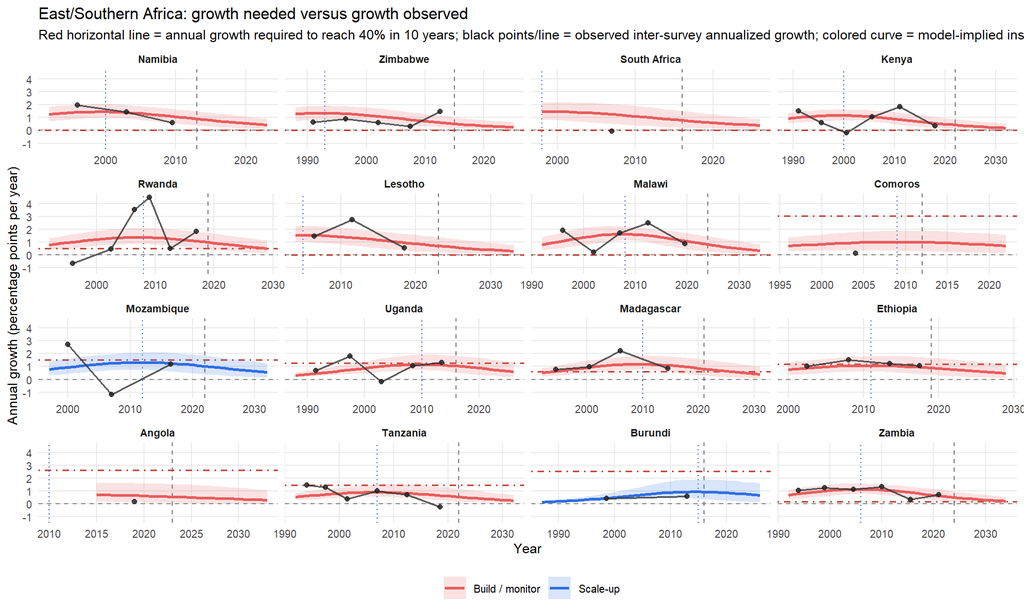

```r
# Compare observed interval growth, model-implied instantaneous growth, and the
# annual growth required to hit 40% mCPR in 10 years from the latest observed mCPR.
ssa_growth_plot_base <- country_growth_rate_table %>%
  filter(region %in% ssa_regions) %>%
  left_join(
    ssa_target40_table %>%
      select(country, required_growth_pp_per_year, last_obs_year, t0_year_mean, target40_status),
    by = "country"
  ) %>%
  mutate(
    dpdt_mean_pp = 100 * dpdt_mean,
    dpdt_p05_pp = 100 * dpdt_p05,
    dpdt_p95_pp = 100 * dpdt_p95
  )

ssa_obs_growth_plot <- ssa_obs_growth_intervals %>%
  mutate(obs_growth_pp = 100 * obs_growth_annual)

make_ssa_growth_plot <- function(region_name) {
  region_growth <- ssa_growth_plot_base %>%
    filter(region == region_name)

  region_obs_growth <- ssa_obs_growth_plot %>%
    filter(region == region_name)

  region_order <- ssa_target40_table %>%
    filter(region == region_name) %>%
    arrange(projected_year_reach_40, desc(required_growth_pp_per_year), country) %>%
    pull(country)

  n_country_region <- length(region_order)
  ncol_region <- dplyr::case_when(
    n_country_region <= 4 ~ 2L,
    n_country_region <= 9 ~ 3L,
    n_country_region <= 16 ~ 4L,
    TRUE ~ 5L
  )

  region_growth <- region_growth %>%
    mutate(country = factor(country, levels = region_order))

  region_obs_growth <- region_obs_growth %>%
    mutate(country = factor(country, levels = region_order))

  ggplot(region_growth, aes(x = year, y = dpdt_mean_pp, color = phase, fill = phase)) +
    geom_hline(yintercept = 0, linetype = "dashed", color = "grey55", linewidth = 0.4) +
    geom_hline(
      aes(yintercept = required_growth_pp_per_year),
      color = "#C0392B",
      linewidth = 0.55,
      linetype = "dotdash",
      alpha = 0.9,
      show.legend = FALSE
    ) +
    geom_vline(
      aes(xintercept = last_obs_year),
      linetype = "dashed",
      color = "grey40",
      linewidth = 0.45,
      alpha = 0.85,
      show.legend = FALSE
    ) +
    geom_vline(
      aes(xintercept = t0_year_mean),
      linetype = "dotted",
      color = "#1D4ED8",
      linewidth = 0.45,
      alpha = 0.85,
      show.legend = FALSE
    ) +
    geom_ribbon(aes(ymin = dpdt_p05_pp, ymax = dpdt_p95_pp), alpha = 0.18, color = NA) +
    geom_line(linewidth = 0.95) +
    geom_line(
      data = region_obs_growth,
      aes(x = interval_mid_year, y = obs_growth_pp, group = country),
      inherit.aes = FALSE,
      color = "grey20",
      linewidth = 0.55,
      alpha = 0.8
    ) +
    geom_point(
      data = region_obs_growth,
      aes(x = interval_mid_year, y = obs_growth_pp),
      inherit.aes = FALSE,
      color = "grey15",
      size = 1.5,
      alpha = 0.85
    ) +
    facet_wrap(~ country, ncol = ncol_region, scales = "free_x") +
    scale_color_manual(values = phase_cols) +
    scale_fill_manual(values = phase_cols) +
    theme_minimal(base_size = 9.5) +
    theme(
      legend.position = "bottom",
      legend.title = element_blank(),
      panel.grid.minor = element_blank(),
      strip.text = element_text(face = "bold", size = 7.3)
    ) +
    labs(
      title = paste0(region_name, ": growth needed versus growth observed"),
      subtitle = "Red horizontal line = annual growth required to reach 40% in 10 years; black points/line = observed inter-survey annualized growth; colored curve = model-implied instantaneous annual growth",
      x = "Year",
      y = "Annual growth (percentage points per year)"
    )
}

purrr::walk(ssa_regions, function(region_name) {
  print(make_ssa_growth_plot(region_name))
})
```

## 23.4 Sub-Saharan Africa summary table

This table combines the main planning quantities for each Sub-Saharan Africa country: a) latest observed DHS mCPR; b) fitted ceiling $K$; c) fitted inflection year and years since inflection at the latest observed mCPR; d) investment phase and S-curve stage; e) observed, required, and model-implied annual growth rates; f) projected year reaching 40% mCPR.

```r
# Print a compact SSA planning table with the key quantities needed to judge the
# realism of a 40% mCPR target.
ssa_summary_table <- ssa_target40_table %>%
  select(
    country,
    region,
    last_obs_year,
    last_obs_mcpr,
    K_mean,
    t0_year_mean,
    years_since_t0_lastobs_mean,
    model_dpdt_lastobs_pp_per_year,
    model_dpdt_2026_pp_per_year,
    latest_obs_interval_growth_pp_per_year,
    max_obs_interval_growth_pp_per_year,
    required_growth_pp_per_year,
    investment_phase,
    s_curve_stage,
    projected_year_reach_40,
    target40_status
  ) %>%
  arrange(factor(region, levels = ssa_regions), projected_year_reach_40, country)

knitr::kable(
  ssa_summary_table %>%
    mutate(across(where(is.numeric), ~ round(.x, 3))),
  caption = "Sub-Saharan Africa summary: stage, growth, and projected year reaching 40% mCPR"
)
```

Sub-Saharan Africa summary: stage, growth, and projected year reaching 40% mCPR

| country | region | last_obs_year | last_obs_mcpr | K_mean | t0_year_mean | years_since_t0_lastobs_mean | model_dpdt_lastobs_pp_per_year | model_dpdt_2026_pp_per_year | latest_obs_interval_growth_pp_per_year | max_obs_interval_growth_pp_per_year | required_growth_pp_per_year | investment_phase | s_curve_stage | projected_year_reach_40 | target40_status |
| --- | --- | --- | --- | --- | --- | --- | --- | --- | --- | --- | --- | --- | --- | --- | --- |
| Liberia | West Africa | 2019 | 0.253 | 0.456 | 2015 | 4.099 | 0.658 | 0.589 | 0.799 | 1.466 | 1.470 | Scale-up | Stage 2: diffusion | 2045.239 | Projected to cross after 2035 |
| Sierra Leone | West Africa | 2019 | 0.239 | 0.438 | 2023 | -3.715 | 0.735 | 0.725 | 0.508 | 2.537 | 1.607 | Scale-up | Stage 2: diffusion | 2049.049 | Projected to cross after 2035 |
| Gambia | West Africa | 2019 | 0.122 | 0.354 | 2024 | -4.752 | 0.574 | 0.584 | 0.954 | 0.954 | 2.777 | Scale-up | Stage 2: diffusion | 2052.435 | Projected to cross after 2035 |
| Togo | West Africa | 2013 | 0.167 | 0.371 | 2021 | -8.092 | 0.569 | 0.584 | 0.592 | 0.592 | 2.326 | Scale-up | Stage 2: diffusion | 2052.782 | Projected to cross after 2035 |
| Ghana | West Africa | 2022 | 0.234 | 0.369 | 2019 | 3.344 | 0.572 | 0.544 | 0.659 | 0.922 | 1.656 | Scale-up | Stage 2: diffusion | 2052.895 | Projected to cross after 2035 |
| Burkina Faso | West Africa | 2021 | 0.279 | 0.428 | 2022 | -1.430 | 0.726 | 0.705 | 1.244 | 1.244 | 1.206 | Scale-up | Stage 2: diffusion | 2053.358 | Projected to cross after 2035 |
| Niger | West Africa | 2012 | 0.110 | 0.357 | 2024 | -12.422 | 0.517 | 0.604 | 1.075 | 1.075 | 2.901 | Scale-up | Stage 2: diffusion | 2054.204 | Projected to cross after 2035 |
| Guinea | West Africa | 2018 | 0.114 | 0.334 | 2023 | -4.657 | 0.530 | 0.532 | 0.732 | 0.732 | 2.857 | Scale-up | Stage 2: diffusion | 2054.350 | Projected to cross after 2035 |
| Cote d’Ivoire | West Africa | 2021 | 0.190 | 0.352 | 2020 | 0.623 | 0.557 | 0.537 | 0.567 | 1.035 | 2.098 | Scale-up | Stage 2: diffusion | 2054.544 | Projected to cross after 2035 |
| Benin | West Africa | 2017 | 0.117 | 0.312 | 2023 | -5.793 | 0.495 | 0.506 | 0.544 | 0.719 | 2.833 | Scale-up | Stage 2: diffusion | 2056.073 | Projected to cross after 2035 |
| Nigeria | West Africa | 2024 | 0.131 | 0.280 | 2020 | 4.138 | 0.426 | 0.418 | 0.432 | 0.432 | 2.690 | Build / monitor | Stage 2: diffusion | 2057.707 | Projected to cross after 2035 |
| Mali | West Africa | 2023 | 0.181 | 0.300 | 2026 | -2.705 | 0.534 | 0.532 | 0.529 | 0.975 | 2.194 | Scale-up | Stage 2: diffusion | 2058.661 | Projected to cross after 2035 |
| Senegal | West Africa | 2023 | 0.175 | 0.292 | 2020 | 2.600 | 0.466 | 0.450 | -0.112 | 2.303 | 2.255 | Build / monitor | Stage 2: diffusion | 2062.090 | Projected to cross after 2035 |
| Congo Democratic Republic | Central Africa | 2023 | 0.099 | 0.130 | 2005 | 17.793 | 0.163 | 0.134 | 0.177 | 0.244 | 3.011 | Maintain / equity | Stage 3: plateau | 2034.390 | Projected to cross by 2035 |
| Gabon | Central Africa | 2019 | 0.171 | 0.363 | 2006 | 12.856 | 0.599 | 0.397 | -0.975 | -0.975 | 2.287 | Build / monitor | Stage 2: diffusion | 2035.161 | Projected to cross by 2035 |
| Congo | Central Africa | 2011 | 0.223 | 0.320 | 2006 | 5.386 | 0.753 | 0.317 | 1.464 | 1.464 | 1.771 | Build / monitor | Stage 2: diffusion | 2035.772 | Projected to cross by 2035 |
| Chad | Central Africa | 2014 | 0.048 | 0.149 | 2012 | 2.366 | 0.375 | 0.239 | 0.333 | 0.333 | 3.516 | Build / monitor | Stage 2: diffusion | 2037.695 | Projected to cross after 2035 |
| Cameroon | Central Africa | 2018 | 0.164 | 0.189 | 2003 | 15.062 | 0.259 | 0.148 | 0.033 | 0.994 | 2.362 | Maintain / equity | Stage 3: plateau | 2051.778 | Projected to cross after 2035 |
| Namibia | East/Southern Africa | 2013 | 0.497 | 0.558 | 2000 | 13.269 | 0.904 | 0.333 | 0.579 | 1.956 | 0.000 | Build / monitor | Stage 2: diffusion | 2013.000 | Already crossed |
| Zimbabwe | East/Southern Africa | 2015 | 0.479 | 0.568 | 1993 | 21.611 | 0.521 | 0.229 | 1.472 | 1.472 | 0.000 | Build / monitor | Stage 3: plateau | 2015.000 | Already crossed |
| South Africa | East/Southern Africa | 2016 | 0.479 | 0.643 | 1998 | 17.921 | 0.791 | 0.389 | -0.081 | -0.081 | 0.000 | Build / monitor | Stage 3: plateau | 2016.000 | Already crossed |
| Kenya | East/Southern Africa | 2022 | 0.420 | 0.481 | 2000 | 22.211 | 0.421 | 0.310 | 0.357 | 1.862 | 0.000 | Build / monitor | Stage 3: plateau | 2022.000 | Already crossed |
| Rwanda | East/Southern Africa | 2019 | 0.351 | 0.544 | 2008 | 11.469 | 0.983 | 0.634 | 1.842 | 4.482 | 0.487 | Build / monitor | Stage 2: diffusion | 2022.554 | Projected to cross by 2035 |
| Lesotho | East/Southern Africa | 2023 | 0.532 | 0.587 | 2005 | 17.813 | 0.704 | 0.557 | 0.521 | 2.731 | 0.000 | Build / monitor | Stage 3: plateau | 2023.000 | Already crossed |
| Malawi | East/Southern Africa | 2024 | 0.530 | 0.588 | 2008 | 15.674 | 0.809 | 0.694 | 0.869 | 2.505 | 0.000 | Build / monitor | Stage 3: plateau | 2024.000 | Already crossed |
| Comoros | East/Southern Africa | 2012 | 0.099 | 0.422 | 2009 | 3.380 | 0.992 | 0.558 | 0.130 | 0.130 | 3.015 | Build / monitor | Stage 2: diffusion | 2026.081 | Projected to cross by 2035 |
| Mozambique | East/Southern Africa | 2022 | 0.250 | 0.527 | 2012 | 10.179 | 1.032 | 0.831 | 1.177 | 2.708 | 1.497 | Scale-up | Stage 2: diffusion | 2026.667 | Projected to cross by 2035 |
| Uganda | East/Southern Africa | 2016 | 0.273 | 0.426 | 2010 | 5.683 | 1.042 | 0.603 | 1.322 | 1.815 | 1.271 | Build / monitor | Stage 2: diffusion | 2028.443 | Projected to cross by 2035 |
| Madagascar | East/Southern Africa | 2021 | 0.341 | 0.434 | 2010 | 11.075 | 0.824 | 0.591 | 0.854 | 2.236 | 0.591 | Build / monitor | Stage 2: diffusion | 2030.704 | Projected to cross by 2035 |
| Ethiopia | East/Southern Africa | 2019 | 0.281 | 0.403 | 2011 | 8.122 | 0.891 | 0.595 | 1.072 | 1.504 | 1.192 | Build / monitor | Stage 2: diffusion | 2031.794 | Projected to cross by 2035 |
| Angola | East/Southern Africa | 2023 | 0.139 | 0.316 | 2010 | 13.444 | 0.555 | 0.477 | 0.181 | 0.181 | 2.609 | Build / monitor | Stage 2: diffusion | 2031.800 | Projected to cross by 2035 |
| Tanzania | East/Southern Africa | 2022 | 0.254 | 0.365 | 2007 | 15.072 | 0.540 | 0.413 | -0.242 | 1.462 | 1.457 | Build / monitor | Stage 3: plateau | 2031.929 | Projected to cross by 2035 |
| Burundi | East/Southern Africa | 2016 | 0.146 | 0.343 | 2015 | 1.496 | 0.934 | 0.666 | 0.595 | 0.595 | 2.543 | Scale-up | Stage 2: diffusion | 2033.567 | Projected to cross by 2035 |
| Zambia | East/Southern Africa | 2024 | 0.384 | 0.432 | 2006 | 17.809 | 0.514 | 0.440 | 0.723 | 1.315 | 0.157 | Build / monitor | Stage 3: plateau | 2034.304 | Projected to cross by 2035 |

# 24 Goals: Sub-Saharan Africa relative to 40% mCPR

This section reframes the SSA results around a single planning question: how close are the region and its countries to a 40% mCPR target, and how demanding would it be to reach that target within 10 years?

The goals section deliberately separates two decision lenses: a) the **natural-trajectory lens**, which asks whether countries and the weighted SSA region reach 40% under the fitted logistic model as estimated; b) the **intervention lens**, which asks what annual growth rate would be required from the model-implied `p(2026)` to reach 40% within 10 years even if the fitted `K` suggests the natural trajectory would plateau below that level.

For the regional target analysis, we do **not** fit a separate SSA logistic curve. Instead, we: a) take the fitted country-level posterior trajectories from the final model; b) aggregate them into an SSA regional trajectory using WPP women age 15-49 population weights; c) carry the latest available WPP weights forward for post-2023 forecast years, because the current weights file was built from the WPP `Estimates` sheet.

This keeps the regional target analysis consistent with the fitted country model while still weighting countries by population size.

```r
# Build a population-weighted SSA regional target summary by aggregating the
# fitted country posteriors using WPP women age 15-49 weights.
ssa_pop_weights <- read.csv("country_pop_weights_15_49.csv") %>%
  filter(region %in% ssa_regions)

ssa_weight_countries <- ssa_target40_table %>%
  distinct(country, region)

ssa_pop_weights_model <- ssa_pop_weights %>%
  filter(country %in% ssa_weight_countries$country)

missing_ssa_weights <- setdiff(ssa_weight_countries$country, unique(ssa_pop_weights_model$country))
if (length(missing_ssa_weights) > 0) {
  stop("Missing SSA population weights for: ", paste(missing_ssa_weights, collapse = ", "))
}

latest_wpp_year <- max(ssa_pop_weights_model$Year, na.rm = TRUE)

ssa_weight_latest <- ssa_pop_weights_model %>%
  filter(Year == latest_wpp_year) %>%
  select(country, women_15_49)

ssa_goal_years <- seq(
  min(mcpr_logistic_data$year[mcpr_logistic_data$region %in% ssa_regions], na.rm = TRUE),
  2036,
  by = 1
)

ssa_nd_region <- mcpr_logistic_data %>%
  filter(region %in% ssa_regions) %>%
  distinct(country, region, region_prior, s_region_fixed) %>%
  mutate(
    country = as.character(country),
    region_prior = as.character(region_prior)
  ) %>%
  tidyr::crossing(year = ssa_goal_years) %>%
  mutate(
    weight_year = pmin(year, latest_wpp_year),
    year_center = year - 2000,
    n = 1L,
    y = 0L
  ) %>%
  left_join(
    ssa_pop_weights_model %>%
      select(country, Year, women_15_49),
    by = c("country", "weight_year" = "Year")
  ) %>%
  group_by(year) %>%
  mutate(weight_country = women_15_49 / sum(women_15_49, na.rm = TRUE)) %>%
  ungroup()

if (any(is.na(ssa_nd_region$weight_country))) {
  stop("SSA regional prediction grid contains missing population weights.")
}

ep_ssa_region_country <- posterior_epred(
  fit_logistic,
  newdata = ssa_nd_region,
  re_formula = NULL
)

ssa_region_draws <- sapply(ssa_goal_years, function(yy) {
  idx <- which(ssa_nd_region$year == yy)
  ep_ssa_region_country[, idx, drop = FALSE] %*% ssa_nd_region$weight_country[idx]
})

ssa_region_curve <- tibble(
  year = ssa_goal_years,
  p_mean = colMeans(ssa_region_draws),
  p_p05 = apply(ssa_region_draws, 2, quantile, ci_lower),
  p_p95 = apply(ssa_region_draws, 2, quantile, ci_upper)
)

# Observed weighted SSA points use country-year DHS observations and the WPP
# women 15-49 weight for that same calendar year. These are descriptive only,
# because the country composition differs across survey years.
ssa_observed_weighted <- mcpr_logistic_data %>%
  filter(region %in% ssa_regions) %>%
  inner_join(
    ssa_pop_weights_model %>%
      select(country, Year, women_15_49),
    by = c("country", "year" = "Year")
  ) %>%
  group_by(year) %>%
  summarise(
    observed_weighted_mcpr = weighted.mean(mCPR, women_15_49, na.rm = TRUE),
    n_countries_obs = n_distinct(country),
    .groups = "drop"
  )

ssa_region_p2026_draws <- as.numeric(ssa_region_draws[, match(2026, ssa_goal_years)])
ssa_region_p2025_draws <- as.numeric(ssa_region_draws[, match(2025, ssa_goal_years)])
ssa_region_required_growth_draws <- pmax(target_mcpr_40 - ssa_region_p2026_draws, 0) / 10
ssa_region_required_growth_2025_draws <- pmax(target_mcpr_40 - ssa_region_p2025_draws, 0) / 10

ssa_weight_vec_latest <- ssa_weight_latest$women_15_49[match(ssa_latest_obs$country, ssa_weight_latest$country)]
ssa_weight_vec_latest <- ssa_weight_vec_latest / sum(ssa_weight_vec_latest, na.rm = TRUE)

ssa_region_dpdt_2025_draws <- as.numeric(dpdt_goal_base_mat[, ssa_country_cols, drop = FALSE] %*% ssa_weight_vec_latest)
ssa_region_dpdt_2026_draws <- as.numeric(dpdt_mat[, ssa_country_cols, drop = FALSE] %*% ssa_weight_vec_latest)

ssa_region_year40_draws <- apply(ssa_region_draws, 1, function(x) {
  idx <- which(x >= target_mcpr_40)
  if (length(idx) == 0) NA_real_ else ssa_goal_years[min(idx)]
})

ssa_region_goals_summary <- tibble(
  geography = "Sub-Saharan Africa",
  weight_basis = paste0("Women 15-49 from WPP Estimates; ", latest_wpp_year, " weights carried forward after 2023"),
  last_obs_weighted_mean = weighted.mean(ssa_target40_table$last_obs_mcpr, ssa_weight_vec_latest, na.rm = TRUE),
  p2025_mean = mean(ssa_region_p2025_draws),
  p2025_p05 = quantile(ssa_region_p2025_draws, ci_lower),
  p2025_p95 = quantile(ssa_region_p2025_draws, ci_upper),
  p2026_mean = mean(ssa_region_p2026_draws),
  p2026_p05 = quantile(ssa_region_p2026_draws, ci_lower),
  p2026_p95 = quantile(ssa_region_p2026_draws, ci_upper),
  required_growth_from_lastobs_pp_per_year =
    100 * pmax(target_mcpr_40 - weighted.mean(ssa_target40_table$last_obs_mcpr, ssa_weight_vec_latest, na.rm = TRUE), 0) / 10,
  required_growth_from_p2025_pp_per_year = 100 * mean(ssa_region_required_growth_2025_draws),
  required_growth_pp_per_year = 100 * mean(ssa_region_required_growth_draws),
  required_growth_pp_per_year_p05 = 100 * quantile(ssa_region_required_growth_draws, ci_lower),
  required_growth_pp_per_year_p95 = 100 * quantile(ssa_region_required_growth_draws, ci_upper),
  model_dpdt_2025_pp_per_year = 100 * mean(ssa_region_dpdt_2025_draws),
  model_dpdt_2025_pp_per_year_p05 = 100 * quantile(ssa_region_dpdt_2025_draws, ci_lower),
  model_dpdt_2025_pp_per_year_p95 = 100 * quantile(ssa_region_dpdt_2025_draws, ci_upper),
  model_dpdt_2026_pp_per_year = 100 * mean(ssa_region_dpdt_2026_draws),
  model_dpdt_2026_pp_per_year_p05 = 100 * quantile(ssa_region_dpdt_2026_draws, ci_lower),
  model_dpdt_2026_pp_per_year_p95 = 100 * quantile(ssa_region_dpdt_2026_draws, ci_upper),
  observed_latest_interval_growth_pp_per_year =
    weighted.mean(ssa_target40_table$latest_obs_interval_growth_pp_per_year, ssa_weight_vec_latest, na.rm = TRUE),
  observed_max_interval_growth_pp_per_year =
    weighted.mean(ssa_target40_table$max_obs_interval_growth_pp_per_year, ssa_weight_vec_latest, na.rm = TRUE),
  projected_year_reach_40_p50 = if (all(is.na(ssa_region_year40_draws))) NA_real_ else median(ssa_region_year40_draws, na.rm = TRUE),
  projected_year_reach_40 = if (all(is.na(ssa_region_year40_draws))) NA_real_ else mean(ssa_region_year40_draws, na.rm = TRUE),
  projected_year_reach_40_p05 = if (all(is.na(ssa_region_year40_draws))) NA_real_ else quantile(ssa_region_year40_draws, ci_lower, na.rm = TRUE),
  projected_year_reach_40_p95 = if (all(is.na(ssa_region_year40_draws))) NA_real_ else quantile(ssa_region_year40_draws, ci_upper, na.rm = TRUE),
  prob_reach_40_by_2035 = mean(!is.na(ssa_region_year40_draws) & ssa_region_year40_draws <= 2035),
  prob_reach_40_by_2036 = mean(!is.na(ssa_region_year40_draws) & ssa_region_year40_draws <= 2036)
)
```

```r
ssa_p2025_draws <- p_goal_base_mat[, ssa_country_cols, drop = FALSE]

ssa_p2025_country_summary <- tibble(
  country = ssa_country_order_vec,
  p2025_mean = colMeans(ssa_p2025_draws),
  p2025_p05 = apply(ssa_p2025_draws, 2, quantile, ci_lower),
  p2025_p95 = apply(ssa_p2025_draws, 2, quantile, ci_upper),
  prob_reach_40_by_2035 = colMeans(!is.na(ssa_target40_year_mat) & ssa_target40_year_mat <= 2035)
)

ssa_goals_country_table <- ssa_target40_table %>%
  left_join(
    ssa_p2025_country_summary,
    by = "country"
  ) %>%
  left_join(
    investment_table %>%
      transmute(country, p2026_mean = p_mean),
    by = "country"
  ) %>%
  left_join(
    s_curve_stage_2026_table %>%
      transmute(country, s_curve_stage_2026),
    by = "country"
  ) %>%
  left_join(
    ssa_weight_latest %>%
      select(country, women_15_49),
    by = "country"
  ) %>%
  mutate(
    weight_share_ssa = women_15_49 / sum(women_15_49, na.rm = TRUE),
    target_gap_pp = 100 * (target_mcpr_40 - last_obs_mcpr),
    target_gap_p2025_pp = 100 * (target_mcpr_40 - p2025_mean),
    target_gap_p2026_pp = 100 * (target_mcpr_40 - p2026_mean),
    projected_reach_40_by_2036 = !is.na(projected_year_reach_40) & projected_year_reach_40 <= 2036,
    crossing_label = case_when(
      last_obs_mcpr >= target_mcpr_40 ~ paste0("Already crossed (", last_obs_year, ")"),
      is.na(projected_year_reach_40_p50) ~ "Not projected",
      projected_year_reach_40_p50 <= 2035 ~ paste0("By 2035 (~", round(projected_year_reach_40_p50), ")"),
      TRUE ~ paste0("After 2035 (~", round(projected_year_reach_40_p50), ")")
    ),
    required_growth_from_lastobs_pp_per_year = pmax(target_gap_pp, 0) / 10,
    required_growth_from_p2025_pp_per_year = pmax(target_gap_p2025_pp, 0) / 10,
    required_growth_from_p2026_pp_per_year = pmax(target_gap_p2026_pp, 0) / 10,
    growth_gap_vs_latest_obs_pp = required_growth_pp_per_year - latest_obs_interval_growth_pp_per_year,
    growth_gap_vs_model_pp = required_growth_pp_per_year - model_dpdt_lastobs_pp_per_year
  ) %>%
  arrange(factor(region, levels = ssa_regions), projected_year_reach_40_p50, country)

ssa_gap_lastobs_plot <- bind_rows(
  tibble(
    country = "Sub-Saharan Africa (weighted)",
    region = "Sub-Saharan Africa",
    required_growth_pp_per_year = ssa_region_goals_summary$required_growth_from_lastobs_pp_per_year
  ),
  ssa_goals_country_table %>%
    transmute(
      country,
      region,
      required_growth_pp_per_year = required_growth_from_lastobs_pp_per_year
    )
) %>%
  mutate(
    country = factor(
      country,
      levels = c(
        "Sub-Saharan Africa (weighted)",
        ssa_goals_country_table %>%
          arrange(desc(required_growth_from_lastobs_pp_per_year), country) %>%
          pull(country)
      )
    )
  )

ssa_gap_p2025_plot <- bind_rows(
  tibble(
    country = "Sub-Saharan Africa (weighted)",
    region = "Sub-Saharan Africa",
    required_growth_pp_per_year = ssa_region_goals_summary$required_growth_from_p2025_pp_per_year
  ),
  ssa_goals_country_table %>%
    transmute(
      country,
      region,
      required_growth_pp_per_year = required_growth_from_p2025_pp_per_year
    )
 ) %>%
  mutate(
    country = factor(
      country,
      levels = c(
        "Sub-Saharan Africa (weighted)",
        ssa_goals_country_table %>%
          arrange(desc(required_growth_from_p2025_pp_per_year), country) %>%
          pull(country)
      )
    )
  )

ssa_gap_p2026_intervention_plot <- bind_rows(
  tibble(
    country = "Sub-Saharan Africa (weighted)",
    region = "Sub-Saharan Africa",
    required_growth_pp_per_year = ssa_region_goals_summary$required_growth_pp_per_year
  ),
  ssa_goals_country_table %>%
    transmute(
      country,
      region,
      required_growth_pp_per_year = required_growth_from_p2026_pp_per_year,
      target40_status
    )
) %>%
  mutate(
    country = factor(
      country,
      levels = c(
        "Sub-Saharan Africa (weighted)",
        ssa_goals_country_table %>%
          arrange(desc(required_growth_from_p2026_pp_per_year), country) %>%
          pull(country)
      )
    )
  )

ssa_goal_comparison_long <- ssa_goals_country_table %>%
  select(
    country, region, required_growth_from_p2026_pp_per_year,
    latest_obs_interval_growth_pp_per_year,
    max_obs_interval_growth_pp_per_year,
    model_dpdt_lastobs_pp_per_year
  ) %>%
  tidyr::pivot_longer(
    cols = c(
      latest_obs_interval_growth_pp_per_year,
      max_obs_interval_growth_pp_per_year,
      model_dpdt_lastobs_pp_per_year
    ),
    names_to = "comparison_metric",
    values_to = "comparison_growth_pp_per_year"
  ) %>%
  mutate(
    comparison_metric = factor(
      comparison_metric,
      levels = c(
        "latest_obs_interval_growth_pp_per_year",
        "max_obs_interval_growth_pp_per_year",
        "model_dpdt_lastobs_pp_per_year"
      ),
      labels = c(
        "Latest observed interval growth",
        "Max observed interval growth",
        "Model-implied current growth"
      )
    )
  )

ssa_priority_matrix_data <- ssa_goals_country_table %>%
  mutate(
    priority_label = crossing_label,
    weight_share_ssa_pct = 100 * weight_share_ssa,
    prob_reach_40_by_2035_pct = 100 * prob_reach_40_by_2035
  )

# Quantify which countries move the weighted SSA trend the most and which ones
# matter most for the 40% regional goal under counterfactual scenarios.
ssa_p2026_draws_country <- p_mat[, ssa_country_cols, drop = FALSE]
ssa_p2035_draws <- logistic_draws_at_year(ssa_K_draws, ssa_t0_draws, ssa_s_draws, 2035)

ssa_contribution_2026_mat <- sweep(ssa_p2026_draws_country, 2, ssa_weight_vec_latest, `*`)
ssa_contribution_2035_mat <- sweep(ssa_p2035_draws, 2, ssa_weight_vec_latest, `*`)
ssa_contribution_delta_mat <- ssa_contribution_2035_mat - ssa_contribution_2026_mat

ssa_region_2035_draws <- rowSums(ssa_contribution_2035_mat)
ssa_marginal_if40_mat <- sweep(matrix(target_mcpr_40, nrow = nrow(ssa_contribution_2035_mat), ncol = ncol(ssa_contribution_2035_mat)), 2, ssa_weight_vec_latest, `*`) - ssa_contribution_2035_mat
```

```r
ssa_regional_influence_table <- ssa_goals_country_table %>%
  mutate(
    women_15_49_millions = women_15_49 / 1e6,
    contribution_2026_pp = 100 * colMeans(ssa_contribution_2026_mat),
    contribution_2035_pp = 100 * colMeans(ssa_contribution_2035_mat),
    delta_contribution_pp = 100 * colMeans(ssa_contribution_delta_mat),
    marginal_lift_if40_pp = 100 * colMeans(ssa_marginal_if40_mat),
    marginal_lift_if40_p05 = 100 * apply(ssa_marginal_if40_mat, 2, quantile, ci_lower),
    marginal_lift_if40_p95 = 100 * apply(ssa_marginal_if40_mat, 2, quantile, ci_upper),
    expected_goal_contribution_pp = marginal_lift_if40_pp * prob_reach_40_by_2035,
    corr_with_regional_2035 = vapply(
      seq_len(ncol(ssa_p2035_draws)),
      function(j) cor(ssa_p2035_draws[, j], ssa_region_2035_draws),
      numeric(1)
    )
  ) %>%
  arrange(desc(delta_contribution_pp), desc(expected_goal_contribution_pp), country)

ssa_regional_delta_plot <- ssa_regional_influence_table %>%
  mutate(
    country = factor(
      country,
      levels = ssa_regional_influence_table %>%
        arrange(delta_contribution_pp, country) %>%
        pull(country)
    )
  )

ssa_regional_marginal_plot <- ssa_regional_influence_table %>%
  mutate(
    country = factor(
      country,
      levels = ssa_regional_influence_table %>%
        arrange(marginal_lift_if40_pp, country) %>%
        pull(country)
    )
  )

ssa_regional_uncertainty_plot <- ssa_regional_influence_table %>%
  mutate(
    country = factor(
      country,
      levels = ssa_regional_influence_table %>%
        arrange(corr_with_regional_2035, country) %>%
        pull(country)
    )
  )

# Build a focused set of illustrative trajectories for the goals section. These
# are the countries we use to show retrospective crossings, prospective
# crossings, and no-crossing cases relative to the 40% target and the fitted K.
ssa_focus_candidates <- c("Rwanda", "Ethiopia", "Kenya", "Malawi", "Uganda", "Tanzania", "Nigeria")
ssa_focus_fallback <- ssa_goals_country_table %>%
  arrange(desc(weight_share_ssa), country) %>%
  pull(country)
ssa_focus_countries <- unique(c(
  ssa_focus_candidates[ssa_focus_candidates %in% ssa_goals_country_table$country],
  ssa_focus_fallback
))
ssa_focus_countries <- head(ssa_focus_countries, 7)

ssa_focus_meta <- ssa_goals_country_table %>%
  filter(country %in% ssa_focus_countries) %>%
  mutate(
    trajectory_status = case_when(
      target40_status == "Already crossed" ~ "Already crossed",
      target40_status == "Not projected to cross" ~ "Not projected to cross",
      target40_status == "Projected to cross by 2035" ~ "Projected to cross by 2035",
      TRUE ~ "Projected to cross after 2035"
    ),
    crossing_year_plot = case_when(
      target40_status == "Not projected to cross" ~ NA_real_,
      TRUE ~ projected_year_reach_40_p50
    )
  )

ssa_focus_order <- c(
  ssa_focus_meta %>%
    filter(trajectory_status == "Already crossed") %>%
    arrange(projected_year_reach_40_p50, country) %>%
    pull(country),
  ssa_focus_meta %>%
    filter(trajectory_status == "Projected to cross by 2035") %>%
    arrange(projected_year_reach_40_p50, country) %>%
    pull(country),
  ssa_focus_meta %>%
    filter(trajectory_status == "Projected to cross after 2035") %>%
    arrange(projected_year_reach_40_p50, country) %>%
    pull(country),
  ssa_focus_meta %>%
    filter(trajectory_status == "Not projected to cross") %>%
    arrange(desc(weight_share_ssa), country) %>%
    pull(country)
)

ssa_focus_years <- seq(
  min(mcpr_logistic_data$year[mcpr_logistic_data$country %in% ssa_focus_countries], na.rm = TRUE),
  2045,
  by = 1
)

ssa_focus_projection <- bind_rows(
  lapply(ssa_focus_order, function(ctry) {
    j <- match(ctry, countries)
    p_draws_country <- sapply(ssa_focus_years, function(yy) {
      logistic_draws_at_year(K_draws, t0_draws, s_draws, yy)[, j]
    })
    tibble(
      country = ctry,
      year = ssa_focus_years,
      p_med = apply(p_draws_country, 2, median),
      p_lo = apply(p_draws_country, 2, quantile, ci_lower),
      p_hi = apply(p_draws_country, 2, quantile, ci_upper)
    )
  })
) %>%
  left_join(
    ssa_focus_meta %>%
      select(
        country, region, last_obs_year, last_obs_mcpr, K_mean,
        crossing_year_plot, trajectory_status
      ),
    by = "country"
  ) %>%
  mutate(
    country = factor(country, levels = ssa_focus_order),
    segment = if_else(year <= last_obs_year, "Retrospective window", "Prospective window")
  )

ssa_focus_obs <- mcpr_logistic_data %>%
  filter(country %in% ssa_focus_countries, region %in% ssa_regions) %>%
  mutate(country = factor(country, levels = ssa_focus_order))

ssa_focus_annotations <- ssa_focus_meta %>%
  mutate(
    country = factor(country, levels = ssa_focus_order),
    annotation_year = pmin(if_else(is.na(crossing_year_plot), 2042, crossing_year_plot + 0.6), 2044),
    annotation_y = pmin(98, 100 * pmax(K_mean - 0.03, 0.16)),
    annotation_label = case_when(
      trajectory_status == "Already crossed" ~ "Already crossed",
      trajectory_status == "Not projected to cross" ~ "Not projected to cross",
      trajectory_status == "Projected to cross by 2035" ~ paste0("Projected by 2035 (~", round(crossing_year_plot), ")"),
      TRUE ~ paste0("Projected after 2035 (~", round(crossing_year_plot), ")")
    )
  )

ssa_asymptote_lastobs <- ssa_goals_country_table %>%
  filter(last_obs_mcpr < target_mcpr_40) %>%
  mutate(
    country = factor(
      country,
      levels = ssa_goals_country_table %>%
        filter(last_obs_mcpr < target_mcpr_40) %>%
        arrange(desc(K_mean), country) %>%
        pull(country)
    )
  )

ssa_asymptote_p2025 <- ssa_goals_country_table %>%
  filter(p2025_mean < target_mcpr_40) %>%
  mutate(
    country = factor(
      country,
      levels = ssa_goals_country_table %>%
        filter(p2025_mean < target_mcpr_40) %>%
        arrange(desc(K_mean), country) %>%
        pull(country)
    )
  )
```

## 24.1 SSA regional target: weighted trajectory and uncertainty

This graph shows the population-weighted SSA trajectory implied by the fitted country model. Each country contributes to the SSA regional value in proportion to its WPP women age 15-49 population.

Interpretation: a) black line is the posterior mean weighted SSA mCPR trajectory; b) grey ribbon is the 95% credible interval; c) red points are population-weighted observed SSA country-year mCPR values, using WPP women age 15-49 weights for the observed year; d) the dashed horizontal line is the 40% target; e) the darker vertical guides mark 2030 and 2035; f) the annotation box states whether the weighted SSA trajectory reaches 40% under business as usual, when that crossing is projected to happen, and the posterior probability of reaching 40% by 2035.

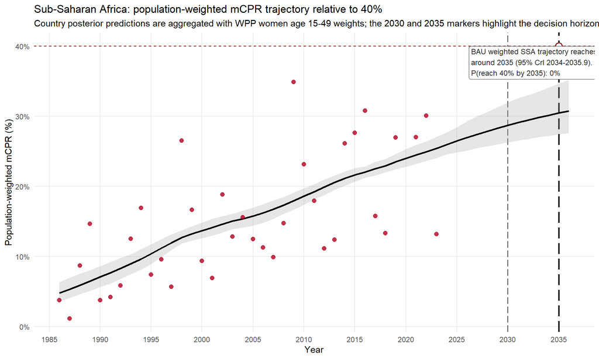

```r
ssa_region_crossing_note <- if (is.na(ssa_region_goals_summary$projected_year_reach_40_p50)) {
  paste0(
    "BAU weighted SSA trajectory does not reach 40%\n",
    "within the modeled window.\n",
    "P(reach 40% by 2035): ",
    round(100 * ssa_region_goals_summary$prob_reach_40_by_2035, 1),
    "%"
  )
} else if (ssa_region_goals_summary$projected_year_reach_40_p50 <= 2035) {
  paste0(
    "BAU weighted SSA trajectory reaches 40%\n",
    "around ",
    round(ssa_region_goals_summary$projected_year_reach_40_p50, 1),
    " (95% CrI ",
    round(ssa_region_goals_summary$projected_year_reach_40_p05, 1),
    "-",
    round(ssa_region_goals_summary$projected_year_reach_40_p95, 1),
    ").\n",
    "P(reach 40% by 2035): ",
    round(100 * ssa_region_goals_summary$prob_reach_40_by_2035, 1),
    "%"
  )
} else {
  paste0(
    "BAU weighted SSA trajectory reaches 40%\n",
    "after 2035, around ",
    round(ssa_region_goals_summary$projected_year_reach_40_p50, 1),
    " (95% CrI ",
    round(ssa_region_goals_summary$projected_year_reach_40_p05, 1),
    "-",
    round(ssa_region_goals_summary$projected_year_reach_40_p95, 1),
    ").\n",
    "P(reach 40% by 2035): ",
    round(100 * ssa_region_goals_summary$prob_reach_40_by_2035, 1),
    "%"
  )
}

ssa_region_crossing_point <- if (is.na(ssa_region_goals_summary$projected_year_reach_40_p50)) {
  tibble(year = numeric(0), p_mean = numeric(0))
} else {
  ssa_region_curve %>%
    filter(year == round(ssa_region_goals_summary$projected_year_reach_40_p50)) %>%
    transmute(year, p_mean = target_mcpr_40)
}

ssa_region_x_breaks <- sort(unique(c(
  seq(
    1985,
    2035,
    by = 5
  ),
  2030,
  2035
)))

ssa_region_annotation_y <- max(
  c(
    ssa_region_curve$p_p95,
    ssa_observed_weighted$observed_weighted_mcpr,
    target_mcpr_40
  ),
  na.rm = TRUE
)

ggplot() +
  geom_hline(yintercept = target_mcpr_40, linetype = "dashed", color = "#8B0000", linewidth = 0.5) +
  geom_vline(xintercept = 2030, linetype = "longdash", color = "grey40", linewidth = 0.65) +
  geom_vline(xintercept = 2035, linetype = "longdash", color = "grey15", linewidth = 0.9) +
  geom_ribbon(
    data = ssa_region_curve,
    aes(x = year, ymin = p_p05, ymax = p_p95),
    fill = "grey55",
    alpha = 0.22
  ) +
  geom_line(
    data = ssa_region_curve,
    aes(x = year, y = p_mean),
    color = "black",
    linewidth = 1.05
  ) +
  geom_point(
    data = ssa_observed_weighted,
    aes(x = year, y = observed_weighted_mcpr),
    color = "#B00020",
    alpha = 0.8,
    size = 2.2
  ) +
  geom_point(
    data = ssa_region_crossing_point,
    aes(x = year, y = p_mean),
    shape = 21,
    size = 3.4,
    stroke = 0.95,
    fill = "white",
    color = "#8B0000"
  ) +
  annotate(
    "label",
    x = 2026.2,
    y = ssa_region_annotation_y,
    label = ssa_region_crossing_note,
    hjust = 0,
    vjust = 1,
    size = 3.15,
    label.size = 0.2,
    fill = "white",
    color = "grey15"
  ) +
  scale_x_continuous(
    breaks = ssa_region_x_breaks,
    limits = range(ssa_region_curve$year, na.rm = TRUE)
  ) +
  scale_y_continuous(
    labels = function(x) paste0(round(100 * x), "%")
  ) +
  theme_minimal(base_size = 11) +
  theme(
    legend.position = "none",
    panel.grid.minor = element_blank()
  ) +
  labs(
    title = "Sub-Saharan Africa: population-weighted mCPR trajectory relative to 40%",
    subtitle = "Country posterior predictions are aggregated with WPP women age 15-49 weights; the 2030 and 2035 markers highlight the decision horizon for the regional 40% goal",
    x = "Year",
    y = "Population-weighted mCPR (%)"
  )
```

## 24.2 SSA regional target summary

This table summarizes the regional goal quantities using the weighted SSA trajectory: a) `last_obs_weighted_mean`: weighted SSA latest observed mCPR across countries; b) `p2025_mean`: weighted SSA mCPR in 2025 under the fitted model; c) `p2026_mean`: weighted SSA mCPR in 2026 under the fitted model; d) `required_growth_from_lastobs_pp_per_year`: annual increase needed to move from the weighted latest observed mCPR to 40% within 10 years; e) `required_growth_from_p2025_pp_per_year`: annual increase needed to move from weighted `p(2025)` to 40% within 10 years; f) `model_dpdt_2026_pp_per_year`: weighted model-implied SSA growth rate in 2026; g) `projected_year_reach_40_p50`: weighted SSA median projected year of reaching 40%; h) `prob_reach_40_by_2035`: posterior probability that SSA reaches 40% by 2035. i) `required_growth_pp_per_year`: annual increase needed to move from weighted `p(2026)` to 40% within 10 years, regardless of the fitted ceiling.

```r
knitr::kable(
  ssa_region_goals_summary %>%
    select(
      geography, last_obs_weighted_mean, p2025_mean, p2026_mean,
      required_growth_from_lastobs_pp_per_year, required_growth_from_p2025_pp_per_year,
      required_growth_pp_per_year,
      model_dpdt_2026_pp_per_year, observed_latest_interval_growth_pp_per_year,
      observed_max_interval_growth_pp_per_year,
      projected_year_reach_40_p50, prob_reach_40_by_2035
    ) %>%
    mutate(across(where(is.numeric), ~ round(.x, 3))),
  caption = "SSA regional target summary using WPP population weights"
)
```

SSA regional target summary using WPP population weights

| geography | last_obs_weighted_mean | p2025_mean | p2026_mean | required_growth_from_lastobs_pp_per_year | required_growth_from_p2025_pp_per_year | required_growth_pp_per_year | model_dpdt_2026_pp_per_year | observed_latest_interval_growth_pp_per_year | observed_max_interval_growth_pp_per_year | projected_year_reach_40_p50 | prob_reach_40_by_2035 |
| --- | --- | --- | --- | --- | --- | --- | --- | --- | --- | --- | --- |
| Sub-Saharan Africa | 0.252 | 0.265 | 0.27 | 1.475 | 1.353 | 1.304 | 0.458 | 0.545 | 0.996 | 2035 | 0 |

## 24.3 SSA regional annualized growth rate benchmark using population-weighted mCPR

This regional benchmark plot keeps the focus entirely at the weighted SSA level. It compares the annualized growth rate needed to hit 40% within 10 years against three weighted regional growth benchmarks: a) the weighted latest observed inter-survey growth; b) the weighted maximum observed inter-survey growth; c) the weighted model-implied annual growth at 2026.

This is the cleanest single-region feasibility view in the report because it asks whether the weighted SSA region is already growing fast enough, would need to return to historically high growth, or would need growth beyond what the region has recently exhibited.

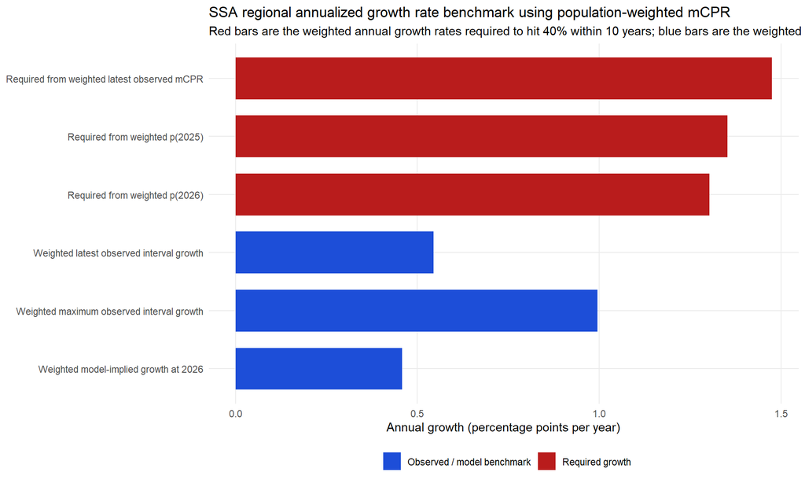

```r
ssa_region_growth_benchmark <- tibble(
  metric = c(
    "Required from weighted latest observed mCPR",
    "Required from weighted p(2025)",
    "Required from weighted p(2026)",
    "Weighted latest observed interval growth",
    "Weighted maximum observed interval growth",
    "Weighted model-implied growth at 2026"
  ),
  metric_group = c(
    "Required growth",
    "Required growth",
    "Required growth",
    "Observed / model benchmark",
    "Observed / model benchmark",
    "Observed / model benchmark"
  ),
  value = c(
    ssa_region_goals_summary$required_growth_from_lastobs_pp_per_year,
    ssa_region_goals_summary$required_growth_from_p2025_pp_per_year,
    ssa_region_goals_summary$required_growth_pp_per_year,
    ssa_region_goals_summary$observed_latest_interval_growth_pp_per_year,
    ssa_region_goals_summary$observed_max_interval_growth_pp_per_year,
    ssa_region_goals_summary$model_dpdt_2026_pp_per_year
  )
) %>%
  mutate(
    metric = factor(metric, levels = rev(metric))
  )

ggplot(ssa_region_growth_benchmark, aes(x = metric, y = value, fill = metric_group)) +
  geom_col(width = 0.72) +
  coord_flip() +
  scale_fill_manual(
    values = c(
      "Required growth" = "#B91C1C",
      "Observed / model benchmark" = "#1D4ED8"
    )
  ) +
  theme_minimal(base_size = 10.8) +
  theme(
    legend.position = "bottom",
    legend.title = element_blank(),
    panel.grid.minor = element_blank()
  ) +
  labs(
    title = "SSA regional annualized growth rate benchmark using population-weighted mCPR",
    subtitle = "Red bars are the weighted annual growth rates required to hit 40% within 10 years; blue bars are the weighted observed and model-implied growth benchmarks",
    x = NULL,
    y = "Annual growth (percentage points per year)"
  )
```

## 24.4 SSA regional level and target milestones

This chart summarizes the weighted SSA regional level relative to the 40% target under three reference points: a) the weighted latest observed mCPR; b) the weighted model-estimated `p(2025)`; c) the weighted model-estimated `p(2026)`.

The annotation box then reports the region’s projected year of reaching 40% and the posterior probability of reaching 40% by 2035.

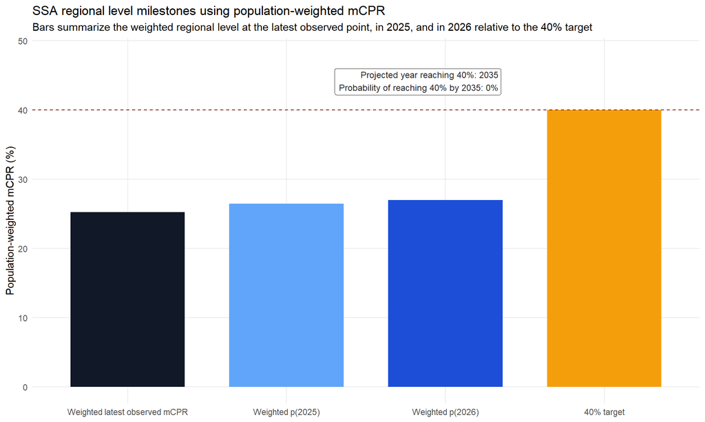

```r
ssa_region_level_benchmark <- tibble(
  metric = c(
    "Weighted latest observed mCPR",
    "Weighted p(2025)",
    "Weighted p(2026)",
    "40% target"
  ),
  value = c(
    100 * ssa_region_goals_summary$last_obs_weighted_mean,
    100 * ssa_region_goals_summary$p2025_mean,
    100 * ssa_region_goals_summary$p2026_mean,
    40
  )
) %>%
  mutate(metric = factor(metric, levels = metric))

ssa_region_milestone_note <- paste0(
  "Projected year reaching 40%: ",
  round(ssa_region_goals_summary$projected_year_reach_40_p50, 1),
  "\nProbability of reaching 40% by 2035: ",
  round(100 * ssa_region_goals_summary$prob_reach_40_by_2035, 1),
  "%"
)

ggplot(ssa_region_level_benchmark, aes(x = metric, y = value, fill = metric)) +
  geom_col(width = 0.72, show.legend = FALSE) +
  geom_hline(yintercept = 40, linetype = "dashed", color = "#7F1D1D", linewidth = 0.45) +
  annotate(
    "label",
    x = 3.35,
    y = max(ssa_region_level_benchmark$value) + 6,
    label = ssa_region_milestone_note,
    hjust = 1,
    vjust = 1,
    size = 3.2,
    label.size = 0.2,
    fill = "white",
    color = "grey15"
  ) +
  scale_fill_manual(
    values = c(
      "Weighted latest observed mCPR" = "#111827",
      "Weighted p(2025)" = "#60A5FA",
      "Weighted p(2026)" = "#1D4ED8",
      "40% target" = "#F59E0B"
    )
  ) +
  coord_cartesian(ylim = c(0, max(ssa_region_level_benchmark$value) + 8)) +
  theme_minimal(base_size = 10.8) +
  theme(
    panel.grid.minor = element_blank()
  ) +
  labs(
    title = "SSA regional level milestones using population-weighted mCPR",
    subtitle = "Bars summarize the weighted regional level at the latest observed point, in 2025, and in 2026 relative to the 40% target",
    x = NULL,
    y = "Population-weighted mCPR (%)"
  )
```

## 24.5 SSA gap analysis using the latest observed mCPR

This chart answers the 40% target question using the latest observed mCPR, even if the latest survey is older than 2025.

Interpretation: a) each bar is the annual percentage-point growth needed to reach 40% within 10 years from the latest observed mCPR; b) the first bar is the weighted SSA regional benchmark; c) taller bars imply a more demanding target path.

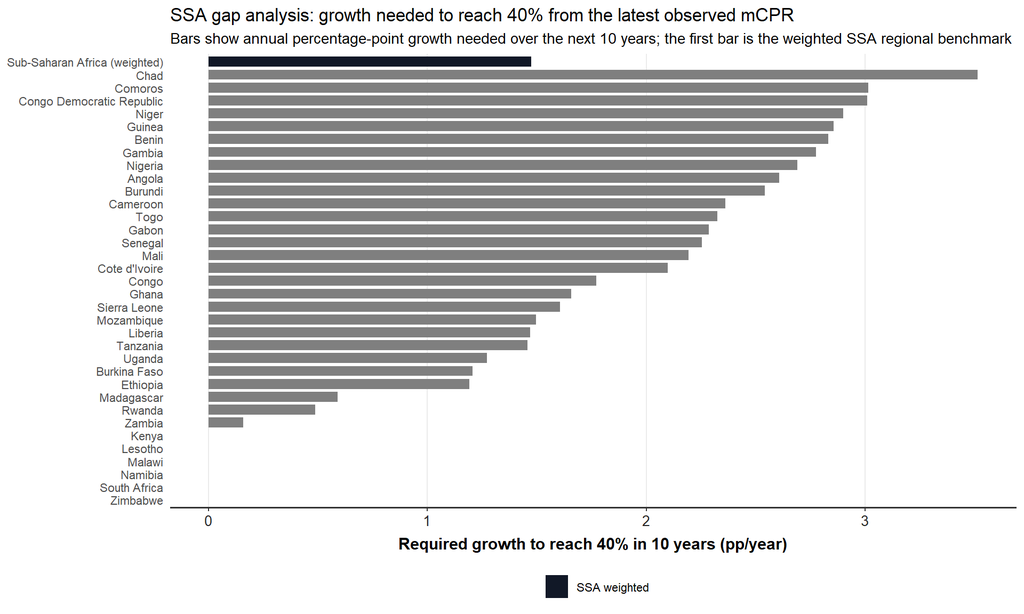

```r
ssa_gap_lastobs_plot_data <- ssa_gap_lastobs_plot %>%
  mutate(
    fill_group = if_else(country == "Sub-Saharan Africa (weighted)", "SSA weighted", region),
    country = factor(country, levels = rev(levels(country)))
  )

ggplot(ssa_gap_lastobs_plot_data, aes(x = country, y = required_growth_pp_per_year, fill = fill_group)) +
  geom_col(width = 0.78) +
  coord_flip() +
  scale_fill_manual(
    values = c(
      "SSA weighted" = "#111827",
      "West Africa" = region_palette["West Africa"],
      "Central Africa" = region_palette["Central Africa"],
      "East/Southern Africa" = region_palette["East/Southern Africa"]
    )
  ) +
  theme_minimal(base_size = 10.5) +
  theme(
    legend.position = "bottom",
    legend.title = element_blank(),
    panel.grid.minor = element_blank(),
    panel.grid.major.y = element_blank(),
    axis.line.x = element_line(color = "grey20", linewidth = 0.55),
    axis.ticks.x = element_line(color = "grey20", linewidth = 0.45),
    axis.text.x = element_text(size = 10.2, color = "grey15"),
    axis.title.x = element_text(face = "bold", size = 11.2, margin = margin(t = 6))
  ) +
  labs(
    title = "SSA gap analysis: growth needed to reach 40% from the latest observed mCPR",
    subtitle = "Bars show annual percentage-point growth needed over the next 10 years; the first bar is the weighted SSA regional benchmark",
    x = NULL,
    y = "Required growth to reach 40% in 10 years (pp/year)"
  )
```

## 24.6 SSA gap analysis using model-estimated p(2025)

This version shifts the baseline from the latest observed mCPR to the model-implied level in 2025.

Interpretation: a) this puts all countries on the same calendar footing; b) the first bar is again the weighted SSA benchmark; c) the difference between this chart and the previous one shows how much the fitted model has already moved countries toward or away from the target by 2025.

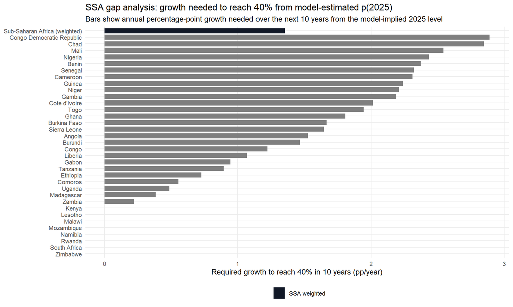

```r
ssa_gap_p2025_plot_data <- ssa_gap_p2025_plot %>%
  mutate(
    fill_group = if_else(country == "Sub-Saharan Africa (weighted)", "SSA weighted", region),
    country = factor(country, levels = rev(levels(country)))
  )

ggplot(ssa_gap_p2025_plot_data, aes(x = country, y = required_growth_pp_per_year, fill = fill_group)) +
  geom_col(width = 0.78) +
  coord_flip() +
  scale_fill_manual(
    values = c(
      "SSA weighted" = "#111827",
      "West Africa" = region_palette["West Africa"],
      "Central Africa" = region_palette["Central Africa"],
      "East/Southern Africa" = region_palette["East/Southern Africa"]
    )
  ) +
  theme_minimal(base_size = 10.5) +
  theme(
    legend.position = "bottom",
    legend.title = element_blank(),
    panel.grid.minor = element_blank()
  ) +
  labs(
    title = "SSA gap analysis: growth needed to reach 40% from model-estimated p(2025)",
    subtitle = "Bars show annual percentage-point growth needed over the next 10 years from the model-implied 2025 level",
    x = NULL,
    y = "Required growth to reach 40% in 10 years (pp/year)"
  )
```

## 24.7 Intervention scenario: growth needed from p(2026) regardless of the fitted ceiling

This chart answers a different question. It ignores whether the fitted natural trajectory actually reaches 40% and instead asks what annual growth rate would be needed from model-estimated `p(2026)` to reach 40% by 2036.

Interpretation: a) countries that do not naturally cross 40% are still included; b) the first bar is the weighted SSA benchmark from `p(2026)`; c) this is the right chart when the planning question is, “how much growth would an intervention have to generate from the current modeled level?”

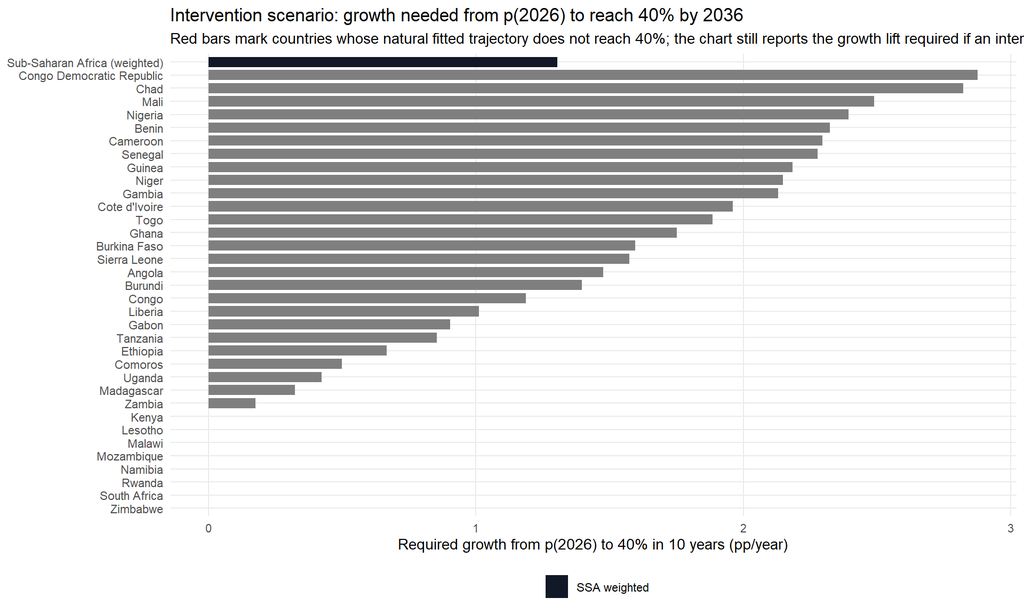

```r
ssa_gap_p2026_plot_data <- ssa_gap_p2026_intervention_plot %>%
  mutate(
    fill_group = case_when(
      country == "Sub-Saharan Africa (weighted)" ~ "SSA weighted",
      country %in% (ssa_goals_country_table %>% filter(target40_status == "Not projected to cross") %>% pull(country)) ~ "Needs intervention beyond natural trajectory",
      TRUE ~ as.character(region)
    ),
    country = factor(country, levels = rev(levels(country)))
  )

ggplot(ssa_gap_p2026_plot_data, aes(x = country, y = required_growth_pp_per_year, fill = fill_group)) +
  geom_col(width = 0.78) +
  coord_flip() +
  scale_fill_manual(
    values = c(
      "SSA weighted" = "#111827",
      "Needs intervention beyond natural trajectory" = "#B91C1C",
      "West Africa" = region_palette["West Africa"],
      "Central Africa" = region_palette["Central Africa"],
      "East/Southern Africa" = region_palette["East/Southern Africa"]
    )
  ) +
  theme_minimal(base_size = 10.5) +
  theme(
    legend.position = "bottom",
    legend.title = element_blank(),
    panel.grid.minor = element_blank()
  ) +
  labs(
    title = "Intervention scenario: growth needed from p(2026) to reach 40% by 2036",
    subtitle = "Red bars mark countries whose natural fitted trajectory does not reach 40%; the chart still reports the growth lift required if an intervention changes the path",
    x = NULL,
    y = "Required growth from p(2026) to 40% in 10 years (pp/year)"
  )
```

## 24.8 Selected SSA trajectories relative to the 40% target and K ceiling

This is the anchor trajectory figure for the goals section. It shows how selected countries sit relative to the 40% target, their fitted ceiling, and their projected crossing year.

Interpretation: a) black points are observed DHS mCPR values; b) green lines are countries already above 40%; c) blue lines are countries projected to cross by 2035; d) orange lines are countries projected to cross after 2035; e) red dashed lines indicate countries not projected to cross under the current fitted model; f) ribbons are 95% credible intervals; g) the dashed horizontal line is the 40% target; h) the dotted brown line is the fitted ceiling $K$; i) vertical lines mark the median crossing year when a crossing is projected.

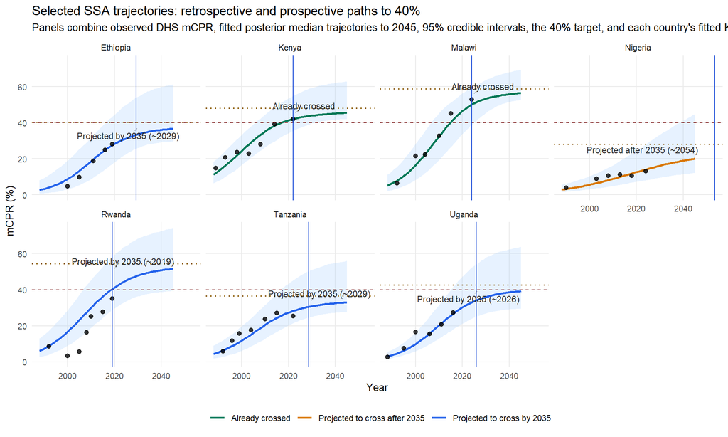

```r
ggplot(ssa_focus_projection, aes(x = year, y = 100 * p_med)) +
  geom_ribbon(
    aes(ymin = 100 * p_lo, ymax = 100 * p_hi),
    fill = "#93C5FD",
    alpha = 0.22
  ) +
  geom_line(
    aes(color = trajectory_status, linetype = trajectory_status),
    linewidth = 1
  ) +
  geom_point(
    data = ssa_focus_obs,
    aes(x = year, y = 100 * mCPR),
    inherit.aes = FALSE,
    color = "black",
    size = 1.8,
    alpha = 0.8
  ) +
  geom_hline(yintercept = 40, linetype = "dashed", color = "#7F1D1D", linewidth = 0.45) +
  geom_hline(
    data = ssa_focus_meta,
    aes(yintercept = 100 * K_mean),
    inherit.aes = FALSE,
    linetype = "dotted",
    color = "#8A5A00",
    linewidth = 0.55
  ) +
  geom_vline(
    data = ssa_focus_meta %>% filter(!is.na(crossing_year_plot)),
    aes(xintercept = crossing_year_plot),
    inherit.aes = FALSE,
    color = "#1D4ED8",
    linewidth = 0.5
  ) +
  ggrepel::geom_text_repel(
    data = ssa_focus_annotations,
    aes(x = annotation_year, y = annotation_y, label = annotation_label),
    inherit.aes = FALSE,
    size = 3,
    color = "grey15",
    segment.alpha = 0.3,
    min.segment.length = 0
  ) +
  scale_color_manual(
    values = c(
      "Already crossed" = "#047857",
      "Projected to cross by 2035" = "#2563EB",
      "Projected to cross after 2035" = "#D97706",
      "Not projected to cross" = "#B91C1C"
    )
  ) +
  scale_linetype_manual(
    values = c(
      "Already crossed" = "solid",
      "Projected to cross by 2035" = "solid",
      "Projected to cross after 2035" = "solid",
      "Not projected to cross" = "dashed"
    )
  ) +
  facet_wrap(~ country, ncol = 4) +
  theme_minimal(base_size = 10.5) +
  theme(
    legend.position = "bottom",
    legend.title = element_blank(),
    panel.grid.minor = element_blank()
  ) +
  labs(
    title = "Selected SSA trajectories: retrospective and prospective paths to 40%",
    subtitle = "Panels combine observed DHS mCPR, fitted posterior median trajectories to 2045, 95% credible intervals, the 40% target, and each country's fitted K ceiling",
    x = "Year",
    y = "mCPR (%)"
  )
```

## 24.9 Asymptote question: latest observed mCPR versus fitted K

This graph focuses on countries still below 40% at their latest observed mCPR.

Interpretation: a) black circles show the latest observed mCPR; b) gold diamonds show the fitted ceiling $K$; c) gold whiskers show the 95% credible interval for $K$; d) grey connectors show the remaining headroom from the latest observed mCPR to $K$; e) the dashed red line marks the 40% target.

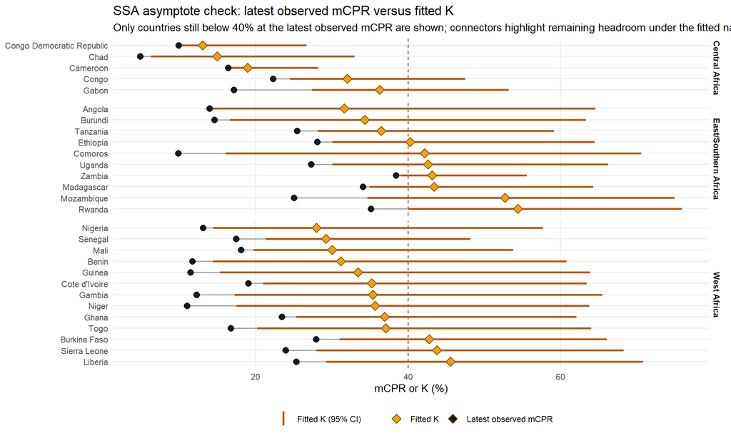

```r
ssa_asymptote_lastobs_legend <- bind_rows(
  ssa_asymptote_lastobs %>%
    transmute(country, region, y_value = 100 * last_obs_mcpr, point_type = "Latest observed mCPR"),
  ssa_asymptote_lastobs %>%
    transmute(country, region, y_value = 100 * K_mean, point_type = "Fitted K")
)

ggplot(ssa_asymptote_lastobs, aes(x = country)) +
  geom_hline(yintercept = 40, linetype = "dashed", color = "#7F1D1D", linewidth = 0.45) +
  geom_segment(
    aes(xend = country, y = 100 * last_obs_mcpr, yend = 100 * K_mean),
    color = "grey65",
    linewidth = 0.6
  ) +
  geom_linerange(
    aes(ymin = 100 * K_p05, ymax = 100 * K_p95, color = "Fitted K (95% CI)"),
    linewidth = 0.9,
    alpha = 0.95
  ) +
  geom_point(
    data = ssa_asymptote_lastobs_legend %>% filter(point_type == "Latest observed mCPR"),
    aes(y = y_value, fill = point_type),
    shape = 21,
    size = 2.8,
    color = "black",
    stroke = 0.4
  ) +
  geom_point(
    data = ssa_asymptote_lastobs_legend %>% filter(point_type == "Fitted K"),
    aes(y = y_value, fill = point_type),
    shape = 23,
    size = 3,
    color = "#8A5A00",
    stroke = 0.55
  ) +
  coord_flip() +
  facet_grid(region ~ ., scales = "free_y", space = "free_y") +
  scale_fill_manual(
    values = c(
      "Latest observed mCPR" = "#111827",
      "Fitted K" = "#F59E0B"
    )
  ) +
  scale_color_manual(
    values = c("Fitted K (95% CI)" = "#B45309")
  ) +
  theme_minimal(base_size = 10.5) +
  theme(
    legend.position = "bottom",
    legend.title = element_blank(),
    panel.grid.minor = element_blank(),
    strip.text.y = element_text(face = "bold")
  ) +
  labs(
    title = "SSA asymptote check: latest observed mCPR versus fitted K",
    subtitle = "Only countries still below 40% at the latest observed mCPR are shown; connectors highlight remaining headroom under the fitted natural trajectory",
    x = NULL,
    y = "mCPR or K (%)"
  )
```

## 24.10 Asymptote question: model-estimated p(2025) versus fitted K

This version updates the current point from the latest observed mCPR to the model-implied level in 2025.

Interpretation: a) blue circles show model-estimated `p(2025)`; b) gold diamonds show the fitted ceiling $K$; c) gold whiskers show the 95% credible interval for $K$; d) grey connectors show the modeled remaining headroom from `p(2025)` to $K$; e) countries whose $K$ remains close to or below 40% have limited modeled headroom even if their current level is still below target.

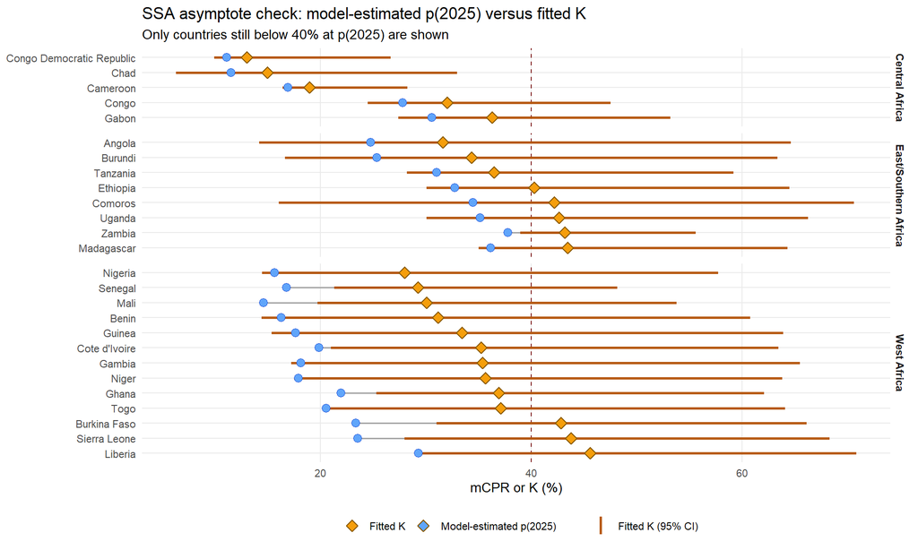

```r
ssa_asymptote_p2025_legend <- bind_rows(
  ssa_asymptote_p2025 %>%
    transmute(country, region, y_value = 100 * p2025_mean, point_type = "Model-estimated p(2025)"),
  ssa_asymptote_p2025 %>%
    transmute(country, region, y_value = 100 * K_mean, point_type = "Fitted K")
)

ggplot(ssa_asymptote_p2025, aes(x = country)) +
  geom_hline(yintercept = 40, linetype = "dashed", color = "#7F1D1D", linewidth = 0.45) +
  geom_segment(
    aes(xend = country, y = 100 * p2025_mean, yend = 100 * K_mean),
    color = "grey65",
    linewidth = 0.6
  ) +
  geom_linerange(
    aes(ymin = 100 * K_p05, ymax = 100 * K_p95, color = "Fitted K (95% CI)"),
    linewidth = 0.9,
    alpha = 0.95
  ) +
  geom_point(
    data = ssa_asymptote_p2025_legend %>% filter(point_type == "Model-estimated p(2025)"),
    aes(y = y_value, fill = point_type),
    shape = 21,
    size = 2.8,
    color = "#1D4ED8",
    stroke = 0.45
  ) +
  geom_point(
    data = ssa_asymptote_p2025_legend %>% filter(point_type == "Fitted K"),
    aes(y = y_value, fill = point_type),
    shape = 23,
    size = 3,
    color = "#8A5A00",
    stroke = 0.55
  ) +
  coord_flip() +
  facet_grid(region ~ ., scales = "free_y", space = "free_y") +
  scale_fill_manual(
    values = c(
      "Model-estimated p(2025)" = "#60A5FA",
      "Fitted K" = "#F59E0B"
    )
  ) +
  scale_color_manual(
    values = c("Fitted K (95% CI)" = "#B45309")
  ) +
  theme_minimal(base_size = 10.5) +
  theme(
    legend.position = "bottom",
    legend.title = element_blank(),
    panel.grid.minor = element_blank(),
    strip.text.y = element_text(face = "bold")
  ) +
  labs(
    title = "SSA asymptote check: model-estimated p(2025) versus fitted K",
    subtitle = "Only countries still below 40% at p(2025) are shown",
    x = NULL,
    y = "mCPR or K (%)"
  )
```

## 24.11 SSA priority matrix: distance to 40, probability of success, and country size

This graph combines target difficulty, target feasibility, and population size in one view.

Interpretation: a) the x-axis is the remaining gap from model-estimated `p(2025)` to 40%; b) the y-axis is the posterior probability of reaching 40% by 2035; c) bubble area is proportional to WPP women age 15-49 population; d) bubble color is the fitted S-curve stage at 2026; e) labels show whether a country already crossed, is projected to cross by 2035, is projected to cross later, or is not projected to cross.

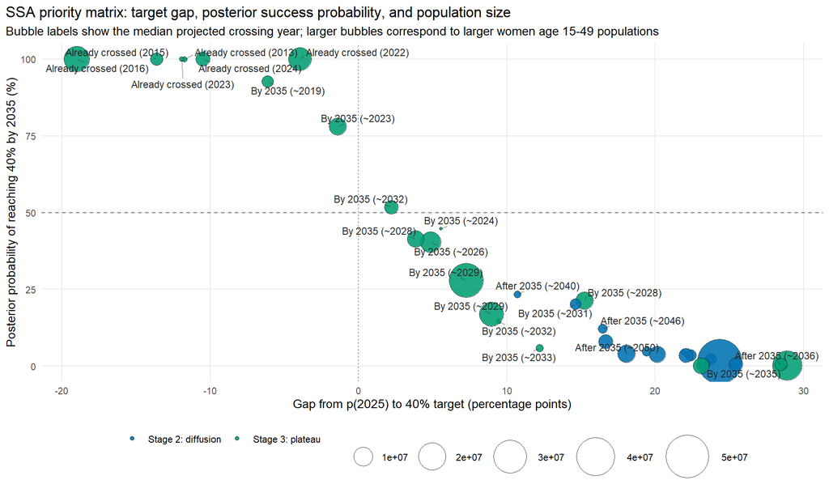

```r
ggplot(
  ssa_priority_matrix_data,
  aes(
    x = target_gap_p2025_pp,
    y = prob_reach_40_by_2035_pct,
    size = women_15_49,
    fill = s_curve_stage_2026
  )
) +
  geom_vline(xintercept = 0, linetype = "dotted", color = "grey45", linewidth = 0.45) +
  geom_hline(yintercept = 50, linetype = "dashed", color = "grey45", linewidth = 0.45) +
  geom_point(shape = 21, color = "grey15", alpha = 0.88, stroke = 0.35) +
  ggrepel::geom_text_repel(
    aes(label = priority_label),
    size = 3,
    color = "grey15",
    segment.alpha = 0.35,
    min.segment.length = 0
  ) +
  scale_size_area(
    max_size = 18,
    name = "Women 15-49"
  ) +
  scale_fill_manual(
    values = c(
      "Stage 1: initial" = "#D55E00",
      "Stage 2: diffusion" = "#0072B2",
      "Stage 3: plateau" = "#009E73"
    )
  ) +
  theme_minimal(base_size = 10.5) +
  theme(
    legend.position = "bottom",
    legend.title = element_blank(),
    panel.grid.minor = element_blank(),
    plot.title.position = "plot"
  ) +
  labs(
    title = "SSA priority matrix: target gap, posterior success probability, and population size",
    subtitle = "Bubble labels show the median projected crossing year; larger bubbles correspond to larger women age 15-49 populations",
    x = "Gap from p(2025) to 40% target (percentage points)",
    y = "Posterior probability of reaching 40% by 2035 (%)"
  )
```

## 24.12 Which countries move the weighted SSA regional trend the most?

This decomposition uses the weighted regional mean directly. Each country’s contribution to the weighted SSA average is its mCPR multiplied by its women age 15-49 population share.

Interpretation: a) bars show how many percentage points each country adds to the weighted SSA mean between 2026 and 2035 under business as usual; b) larger positive bars mean that country is carrying more of the region’s projected progress; c) the same bar also measures how much the regional mean would fall short if that country stalled at its 2026 level while others followed business as usual.

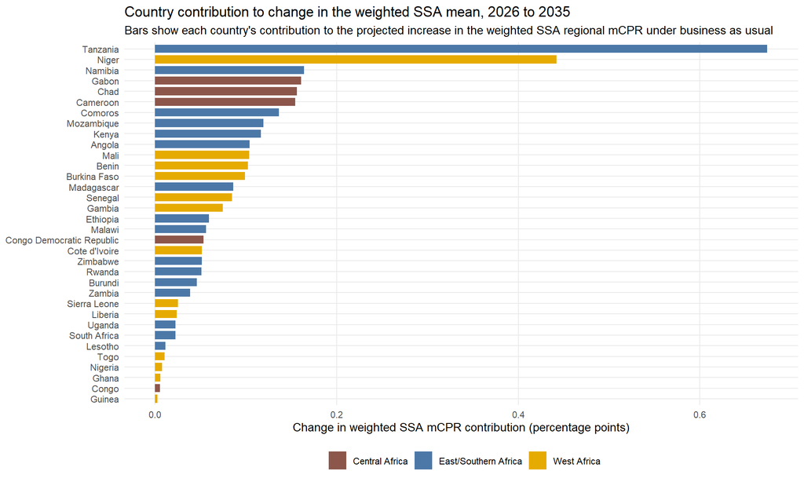

```r
ggplot(ssa_regional_delta_plot, aes(x = country, y = delta_contribution_pp, fill = region)) +
  geom_col(width = 0.76) +
  coord_flip() +
  scale_fill_manual(values = region_palette) +
  theme_minimal(base_size = 10.5) +
  theme(
    legend.position = "bottom",
    legend.title = element_blank(),
    panel.grid.minor = element_blank()
  ) +
  labs(
    title = "Country contribution to change in the weighted SSA mean, 2026 to 2035",
    subtitle = "Bars show each country's contribution to the projected increase in the weighted SSA regional mCPR under business as usual",
    x = NULL,
    y = "Change in weighted SSA mCPR contribution (percentage points)"
  )
```

## 24.13 If one country reached 40% by 2035, how much would the weighted SSA mean move?

This is a counterfactual decomposition. For each country, we hold all other countries at their business-as-usual 2035 projection and set that one country to 40%.

Interpretation: a) bars show the maximum regional lift if that country reaches 40% by 2035; b) black points show the expected contribution after weighting that lift by the country’s own posterior probability of reaching 40%; c) large bars with low black points indicate countries that matter enormously for the regional goal but are unlikely to deliver under business as usual.

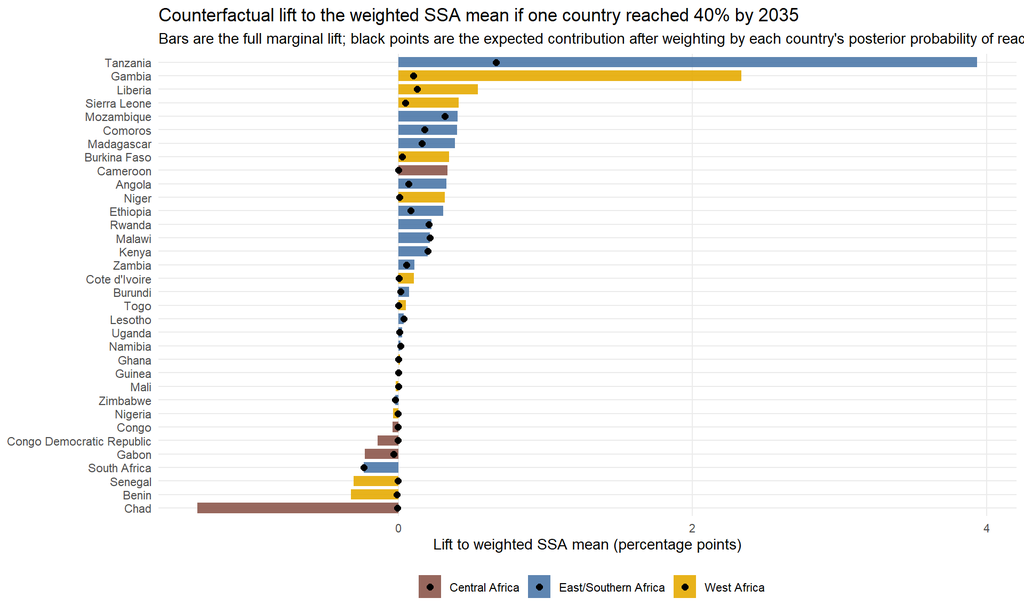

```r
ggplot(ssa_regional_marginal_plot, aes(x = country, y = marginal_lift_if40_pp, fill = region)) +
  geom_col(width = 0.76, alpha = 0.9) +
  geom_point(
    aes(y = expected_goal_contribution_pp),
    inherit.aes = TRUE,
    color = "black",
    size = 2
  ) +
  coord_flip() +
  scale_fill_manual(values = region_palette) +
  theme_minimal(base_size = 10.5) +
  theme(
    legend.position = "bottom",
    legend.title = element_blank(),
    panel.grid.minor = element_blank()
  ) +
  labs(
    title = "Counterfactual lift to the weighted SSA mean if one country reached 40% by 2035",
    subtitle = "Bars are the full marginal lift; black points are the expected contribution after weighting by each country's posterior probability of reaching 40%",
    x = NULL,
    y = "Lift to weighted SSA mean (percentage points)"
  )
```

## 24.14 Which countries most influence the regional 2035 outcome?

This is a model-based influence diagnostic. It asks how strongly each country’s posterior 2035 trajectory co-moves with the weighted SSA 2035 regional trajectory across posterior draws.

Interpretation: a) higher values mean the country’s uncertainty matters more for the regional 2035 outcome; b) large-population countries with high correlation are the countries most able to swing the regional result; c) this is not the same as having the fastest growth rate; it is an influence measure on the regional target outcome.

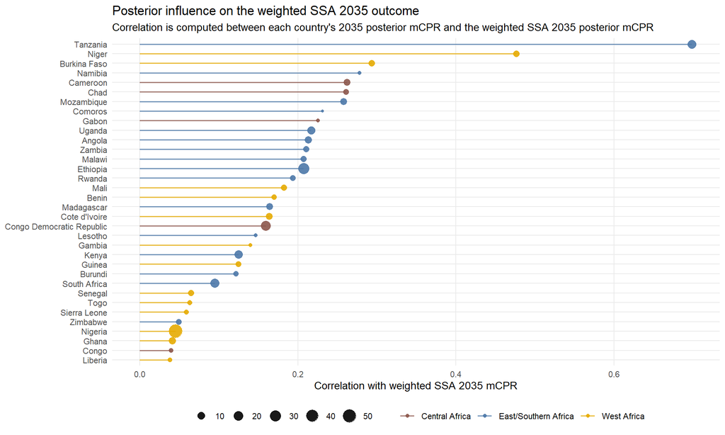

```r
ggplot(ssa_regional_uncertainty_plot, aes(x = country, y = corr_with_regional_2035, color = region)) +
  geom_segment(
    aes(xend = country, y = 0, yend = corr_with_regional_2035),
    linewidth = 0.7,
    alpha = 0.75
  ) +
  geom_point(aes(size = women_15_49_millions), alpha = 0.9) +
  coord_flip() +
  scale_color_manual(values = region_palette) +
  scale_size_continuous(name = "Women 15-49\n(millions)") +
  theme_minimal(base_size = 10.5) +
  theme(
    legend.position = "bottom",
    legend.title = element_blank(),
    panel.grid.minor = element_blank()
  ) +
  labs(
    title = "Posterior influence on the weighted SSA 2035 outcome",
    subtitle = "Correlation is computed between each country's 2035 posterior mCPR and the weighted SSA 2035 posterior mCPR",
    x = NULL,
    y = "Correlation with weighted SSA 2035 mCPR"
  )
```

## 24.15 SSA regional influence summary table

This table brings the regional-contribution analysis into one place: a) each country’s weighted contribution to the SSA mean in 2026 and 2035; b) the change in that contribution under business as usual; c) the lift to the weighted SSA mean if that country reached 40% by 2035; d) the expected goal contribution after weighting by the country’s own probability of reaching 40%; e) the posterior influence of that country on the regional 2035 outcome.

```r
knitr::kable(
  ssa_regional_influence_table %>%
    select(
      country, region, women_15_49_millions,
      contribution_2026_pp, contribution_2035_pp, delta_contribution_pp,
      marginal_lift_if40_pp, expected_goal_contribution_pp,
      prob_reach_40_by_2035, corr_with_regional_2035
    ) %>%
    mutate(across(where(is.numeric), ~ round(.x, 3))),
  caption = "SSA regional influence summary: weighted contribution, counterfactual lift, and posterior influence"
)
```

SSA regional influence summary: weighted contribution, counterfactual lift, and posterior influence

| country | region | women_15_49_millions | contribution_2026_pp | contribution_2035_pp | delta_contribution_pp | marginal_lift_if40_pp | expected_goal_contribution_pp | prob_reach_40_by_2035 | corr_with_regional_2035 |
| --- | --- | --- | --- | --- | --- | --- | --- | --- | --- |
| Tanzania | East/Southern Africa | 16.123 | 3.094 | 3.769 | 0.674 | 3.938 | 0.665 | 0.169 | 0.699 |
| Niger | West Africa | 5.689 | 3.802 | 4.244 | 0.442 | 0.317 | 0.011 | 0.034 | 0.476 |
| Namibia | East/Southern Africa | 0.760 | 1.511 | 1.675 | 0.164 | 0.015 | 0.015 | 1.000 | 0.278 |
| Gabon | Central Africa | 0.610 | 1.216 | 1.377 | 0.161 | -0.226 | -0.033 | 0.144 | 0.226 |
| Chad | Central Africa | 4.363 | 3.702 | 3.858 | 0.156 | -1.365 | -0.005 | 0.004 | 0.261 |
| Cameroon | Central Africa | 6.936 | 1.801 | 1.955 | 0.154 | 0.334 | 0.000 | 0.000 | 0.262 |
| Comoros | East/Southern Africa | 0.209 | 0.688 | 0.824 | 0.136 | 0.399 | 0.179 | 0.447 | 0.231 |
| Mozambique | East/Southern Africa | 8.108 | 0.545 | 0.665 | 0.120 | 0.405 | 0.316 | 0.780 | 0.258 |
| Kenya | East/Southern Africa | 14.494 | 0.477 | 0.593 | 0.116 | 0.200 | 0.200 | 1.000 | 0.125 |
| Angola | East/Southern Africa | 8.482 | 0.374 | 0.478 | 0.104 | 0.330 | 0.070 | 0.213 | 0.213 |
| Mali | West Africa | 5.348 | 1.004 | 1.107 | 0.104 | -0.015 | 0.000 | 0.006 | 0.182 |
| Benin | West Africa | 3.355 | 2.277 | 2.380 | 0.102 | -0.322 | -0.007 | 0.023 | 0.170 |
| Burkina Faso | West Africa | 5.586 | 0.760 | 0.859 | 0.099 | 0.345 | 0.027 | 0.078 | 0.293 |
| Madagascar | East/Southern Africa | 7.691 | 0.287 | 0.373 | 0.086 | 0.386 | 0.160 | 0.413 | 0.164 |
| Senegal | West Africa | 4.514 | 0.995 | 1.080 | 0.085 | -0.303 | -0.001 | 0.005 | 0.065 |
| Gambia | West Africa | 0.655 | 0.939 | 1.014 | 0.074 | 2.332 | 0.104 | 0.045 | 0.140 |
| Ethiopia | East/Southern Africa | 32.128 | 0.276 | 0.336 | 0.059 | 0.305 | 0.085 | 0.278 | 0.207 |
| Malawi | East/Southern Africa | 5.474 | 0.227 | 0.283 | 0.056 | 0.217 | 0.217 | 1.000 | 0.207 |
| Congo Democratic Republic | Central Africa | 23.561 | 0.604 | 0.657 | 0.053 | -0.141 | 0.000 | 0.001 | 0.160 |
| Cote d’Ivoire | West Africa | 7.535 | 0.298 | 0.349 | 0.052 | 0.108 | 0.004 | 0.038 | 0.164 |
| Zimbabwe | East/Southern Africa | 4.309 | 0.708 | 0.760 | 0.051 | -0.019 | -0.019 | 1.000 | 0.049 |
| Rwanda | East/Southern Africa | 3.637 | 0.200 | 0.251 | 0.051 | 0.226 | 0.209 | 0.927 | 0.193 |
| Burundi | East/Southern Africa | 3.220 | 0.184 | 0.230 | 0.046 | 0.073 | 0.015 | 0.201 | 0.122 |
| Zambia | East/Southern Africa | 5.218 | 0.169 | 0.208 | 0.039 | 0.112 | 0.058 | 0.517 | 0.210 |
| Sierra Leone | West Africa | 2.133 | 0.182 | 0.207 | 0.025 | 0.412 | 0.050 | 0.121 | 0.059 |
| Liberia | West Africa | 1.348 | 0.420 | 0.443 | 0.024 | 0.541 | 0.127 | 0.234 | 0.038 |
| Uganda | East/Southern Africa | 11.900 | 0.143 | 0.166 | 0.023 | 0.026 | 0.010 | 0.404 | 0.217 |
| South Africa | East/Southern Africa | 17.559 | 0.823 | 0.846 | 0.023 | -0.234 | -0.234 | 1.000 | 0.095 |
| Lesotho | East/Southern Africa | 0.638 | 0.043 | 0.055 | 0.012 | 0.038 | 0.038 | 1.000 | 0.147 |
| Togo | West Africa | 2.247 | 0.148 | 0.158 | 0.011 | 0.052 | 0.002 | 0.046 | 0.063 |
| Nigeria | West Africa | 54.276 | 0.119 | 0.127 | 0.008 | -0.036 | -0.001 | 0.014 | 0.045 |
| Ghana | West Africa | 8.617 | 0.067 | 0.073 | 0.006 | 0.014 | 0.001 | 0.040 | 0.041 |
| Congo | Central Africa | 1.478 | 0.141 | 0.146 | 0.006 | -0.038 | -0.002 | 0.058 | 0.040 |
| Guinea | West Africa | 3.519 | 0.026 | 0.029 | 0.003 | 0.001 | 0.000 | 0.035 | 0.125 |

## 24.16 SSA countries: projected year reaching 40% with uncertainty

This graph focuses on timing uncertainty.

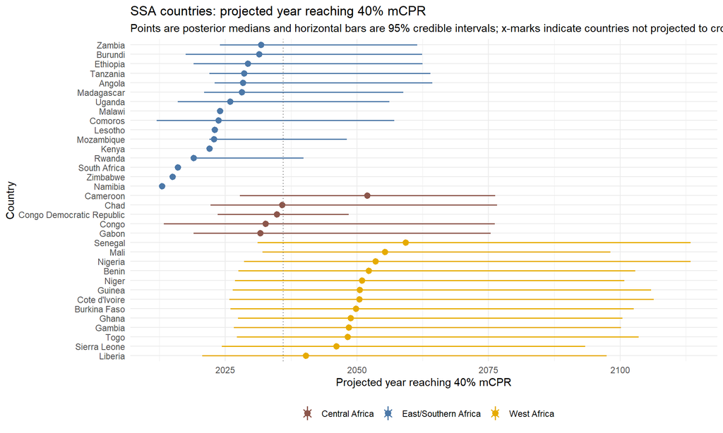

```r
ssa_goals_year40_cap <- max(ssa_goals_country_table$projected_year_reach_40_p95, na.rm = TRUE) + 2

ssa_goals_year40_plot <- ssa_goals_country_table %>%
  mutate(
    year40_plot = case_when(
      target40_status == "Already crossed" ~ as.numeric(last_obs_year),
      target40_status == "Not projected to cross" ~ as.numeric(ssa_goals_year40_cap),
      TRUE ~ as.numeric(projected_year_reach_40_p50)
    ),
    year40_p05_plot = case_when(
      target40_status == "Already crossed" ~ as.numeric(last_obs_year),
      target40_status == "Not projected to cross" ~ NA_real_,
      TRUE ~ as.numeric(projected_year_reach_40_p05)
    ),
    year40_p95_plot = case_when(
      target40_status == "Already crossed" ~ as.numeric(last_obs_year),
      target40_status == "Not projected to cross" ~ NA_real_,
      TRUE ~ as.numeric(projected_year_reach_40_p95)
    ),
    country = factor(
      country,
      levels = ssa_goals_country_table %>%
        arrange(factor(region, levels = ssa_regions), year40_plot, country) %>%
        pull(country)
    )
  )

ggplot(ssa_goals_year40_plot, aes(x = country, color = region)) +
  geom_pointrange(
    data = ssa_goals_year40_plot %>% filter(target40_status != "Not projected to cross"),
    aes(y = year40_plot, ymin = year40_p05_plot, ymax = year40_p95_plot),
    linewidth = 0.55
  ) +
  geom_point(
    data = ssa_goals_year40_plot %>% filter(target40_status == "Not projected to cross"),
    aes(y = year40_plot),
    shape = 4,
    size = 2.8,
    stroke = 0.9
  ) +
  geom_hline(yintercept = 2036, linetype = "dotted", color = "grey45") +
  coord_flip() +
  theme_minimal(base_size = 11) +
  scale_color_manual(values = region_palette) +
  labs(
    title = "SSA countries: projected year reaching 40% mCPR",
    subtitle = "Points are posterior medians and horizontal bars are 95% credible intervals; x-marks indicate countries not projected to cross 40%",
    x = "Country",
    y = "Projected year reaching 40% mCPR"
  ) +
  theme(legend.position = "bottom", legend.title = element_blank())
```

## 24.17 SSA countries: is 40% in 10 years realistic?

This graph compares three benchmarks against the annual growth required to hit 40% within 10 years: a) the latest observed interval growth; b) the maximum observed interval growth; d) the model-implied current annual growth rate.

The required growth on the x-axis comes from model-estimated `p(2026)` and ignores whether the fitted ceiling is below 40%. This makes the graph an intervention-feasibility benchmark rather than a natural-trajectory forecast.

Points below the 45-degree line imply the target requires faster growth than that comparison benchmark.

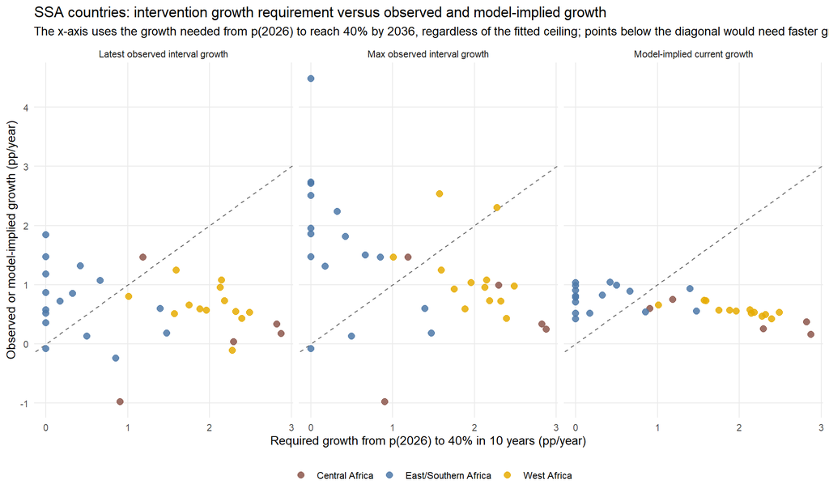

```r
ggplot(
  ssa_goal_comparison_long,
  aes(
    x = required_growth_from_p2026_pp_per_year,
    y = comparison_growth_pp_per_year,
    color = region
  )
) +
  geom_abline(slope = 1, intercept = 0, linetype = "dashed", color = "grey45") +
  geom_point(size = 2.4, alpha = 0.85) +
  facet_wrap(~ comparison_metric, ncol = 3) +
  scale_color_manual(values = region_palette) +
  theme_minimal(base_size = 10.5) +
  theme(
    legend.position = "bottom",
    legend.title = element_blank(),
    panel.grid.minor = element_blank()
  ) +
  labs(
    title = "SSA countries: intervention growth requirement versus observed and model-implied growth",
    subtitle = "The x-axis uses the growth needed from p(2026) to reach 40% by 2036, regardless of the fitted ceiling; points below the diagonal would need faster growth than the comparison benchmark",
    x = "Required growth from p(2026) to 40% in 10 years (pp/year)",
    y = "Observed or model-implied growth (pp/year)"
  )
```

## 24.18 SSA country goal summary table

This table brings the main goal-tracking quantities into one place: a) current level relative to 40%; b) model-estimated `p(2025)` and `p(2026)`; c) projected year of reaching 40%; d) required growth to hit 40% within 10 years; e) latest observed and model-implied growth benchmarks; f) investment phase and S-curve stage; g) the country’s population share within the modeled SSA set.

The first table below isolates the intervention scenario. It keeps countries that do not naturally cross 40% in view and reports the annual growth that would still be required from `p(2026)` if an intervention were assumed to change the path.

```r
knitr::kable(
  ssa_goals_country_table %>%
    select(
      country, region, p2026_mean, required_growth_from_p2026_pp_per_year,
      latest_obs_interval_growth_pp_per_year, model_dpdt_2026_pp_per_year,
      target40_status, projected_year_reach_40, s_curve_stage_2026
    ) %>%
    mutate(across(where(is.numeric), ~ round(.x, 3))),
  caption = "SSA intervention scenario summary: growth needed from p(2026) to reach 40% by 2036"
)
```

SSA intervention scenario summary: growth needed from p(2026) to reach 40% by 2036

| country | region | p2026_mean | required_growth_from_p2026_pp_per_year | latest_obs_interval_growth_pp_per_year | model_dpdt_2026_pp_per_year | target40_status | projected_year_reach_40 | s_curve_stage_2026 |
| --- | --- | --- | --- | --- | --- | --- | --- | --- |
| Liberia | West Africa | 0.299 | 1.011 | 0.799 | 0.589 | Projected to cross after 2035 | 2045.239 | Stage 2: diffusion |
| Sierra Leone | West Africa | 0.243 | 1.573 | 0.508 | 0.725 | Projected to cross after 2035 | 2049.049 | Stage 2: diffusion |
| Togo | West Africa | 0.211 | 1.886 | 0.592 | 0.584 | Projected to cross after 2035 | 2052.782 | Stage 2: diffusion |
| Gambia | West Africa | 0.187 | 2.130 | 0.954 | 0.584 | Projected to cross after 2035 | 2052.435 | Stage 2: diffusion |
| Ghana | West Africa | 0.225 | 1.752 | 0.659 | 0.544 | Projected to cross after 2035 | 2052.895 | Stage 2: diffusion |
| Burkina Faso | West Africa | 0.240 | 1.595 | 1.244 | 0.705 | Projected to cross after 2035 | 2053.358 | Stage 2: diffusion |
| Cote d’Ivoire | West Africa | 0.204 | 1.961 | 0.567 | 0.537 | Projected to cross after 2035 | 2054.544 | Stage 2: diffusion |
| Guinea | West Africa | 0.182 | 2.185 | 0.732 | 0.532 | Projected to cross after 2035 | 2054.350 | Stage 2: diffusion |
| Niger | West Africa | 0.185 | 2.148 | 1.075 | 0.604 | Projected to cross after 2035 | 2054.204 | Stage 2: diffusion |
| Benin | West Africa | 0.168 | 2.323 | 0.544 | 0.506 | Projected to cross after 2035 | 2056.073 | Stage 2: diffusion |
| Nigeria | West Africa | 0.161 | 2.394 | 0.432 | 0.418 | Projected to cross after 2035 | 2057.707 | Stage 2: diffusion |
| Mali | West Africa | 0.151 | 2.489 | 0.529 | 0.532 | Projected to cross after 2035 | 2058.661 | Stage 2: diffusion |
| Senegal | West Africa | 0.172 | 2.277 | -0.112 | 0.450 | Projected to cross after 2035 | 2062.090 | Stage 2: diffusion |
| Gabon | Central Africa | 0.310 | 0.904 | -0.975 | 0.397 | Projected to cross by 2035 | 2035.161 | Stage 3: plateau |
| Congo | Central Africa | 0.281 | 1.187 | 1.464 | 0.317 | Projected to cross by 2035 | 2035.772 | Stage 3: plateau |
| Congo Democratic Republic | Central Africa | 0.112 | 2.877 | 0.177 | 0.134 | Projected to cross by 2035 | 2034.390 | Stage 3: plateau |
| Chad | Central Africa | 0.118 | 2.823 | 0.333 | 0.239 | Projected to cross after 2035 | 2037.695 | Stage 3: plateau |
| Cameroon | Central Africa | 0.170 | 2.295 | 0.033 | 0.148 | Projected to cross after 2035 | 2051.778 | Stage 3: plateau |
| Namibia | East/Southern Africa | 0.521 | 0.000 | 0.579 | 0.333 | Already crossed | 2013.000 | Stage 3: plateau |
| Zimbabwe | East/Southern Africa | 0.538 | 0.000 | 1.472 | 0.229 | Already crossed | 2015.000 | Stage 3: plateau |
| South Africa | East/Southern Africa | 0.594 | 0.000 | -0.081 | 0.389 | Already crossed | 2016.000 | Stage 3: plateau |
| Rwanda | East/Southern Africa | 0.468 | 0.000 | 1.842 | 0.634 | Projected to cross by 2035 | 2022.554 | Stage 3: plateau |
| Kenya | East/Southern Africa | 0.443 | 0.000 | 0.357 | 0.310 | Already crossed | 2022.000 | Stage 3: plateau |
| Mozambique | East/Southern Africa | 0.423 | 0.000 | 1.177 | 0.831 | Projected to cross by 2035 | 2026.667 | Stage 3: plateau |
| Lesotho | East/Southern Africa | 0.525 | 0.000 | 0.521 | 0.557 | Already crossed | 2023.000 | Stage 3: plateau |
| Comoros | East/Southern Africa | 0.350 | 0.498 | 0.130 | 0.558 | Projected to cross by 2035 | 2026.081 | Stage 3: plateau |
| Malawi | East/Southern Africa | 0.512 | 0.000 | 0.869 | 0.694 | Already crossed | 2024.000 | Stage 3: plateau |
| Uganda | East/Southern Africa | 0.358 | 0.423 | 1.322 | 0.603 | Projected to cross by 2035 | 2028.443 | Stage 3: plateau |
| Madagascar | East/Southern Africa | 0.368 | 0.324 | 0.854 | 0.591 | Projected to cross by 2035 | 2030.704 | Stage 3: plateau |
| Angola | East/Southern Africa | 0.252 | 1.476 | 0.181 | 0.477 | Projected to cross by 2035 | 2031.800 | Stage 3: plateau |
| Tanzania | East/Southern Africa | 0.315 | 0.854 | -0.242 | 0.413 | Projected to cross by 2035 | 2031.929 | Stage 3: plateau |
| Ethiopia | East/Southern Africa | 0.333 | 0.666 | 1.072 | 0.595 | Projected to cross by 2035 | 2031.794 | Stage 3: plateau |
| Burundi | East/Southern Africa | 0.260 | 1.395 | 0.595 | 0.666 | Projected to cross by 2035 | 2033.567 | Stage 2: diffusion |
| Zambia | East/Southern Africa | 0.383 | 0.175 | 0.723 | 0.440 | Projected to cross by 2035 | 2034.304 | Stage 3: plateau |

```r
knitr::kable(
  ssa_goals_country_table %>%
    select(
      country, region, weight_share_ssa, last_obs_year, last_obs_mcpr,
      p2025_mean, p2026_mean, target40_status, projected_year_reach_40,
      required_growth_from_lastobs_pp_per_year, required_growth_from_p2025_pp_per_year,
      required_growth_from_p2026_pp_per_year,
      latest_obs_interval_growth_pp_per_year, model_dpdt_lastobs_pp_per_year,
      prob_reach_40_by_2035, investment_phase, s_curve_stage_2026
    ) %>%
    mutate(across(where(is.numeric), ~ round(.x, 3))),
  caption = "SSA country goal summary relative to 40% mCPR"
)
```

SSA country goal summary relative to 40% mCPR

| country | region | weight_share_ssa | last_obs_year | last_obs_mcpr | p2025_mean | p2026_mean | target40_status | projected_year_reach_40 | required_growth_from_lastobs_pp_per_year | required_growth_from_p2025_pp_per_year | required_growth_from_p2026_pp_per_year | latest_obs_interval_growth_pp_per_year | model_dpdt_lastobs_pp_per_year | prob_reach_40_by_2035 | investment_phase | s_curve_stage_2026 |
| --- | --- | --- | --- | --- | --- | --- | --- | --- | --- | --- | --- | --- | --- | --- | --- | --- |
| Liberia | West Africa | 0.005 | 2019 | 0.253 | 0.293 | 0.299 | Projected to cross after 2035 | 2045.239 | 1.470 | 1.070 | 1.011 | 0.799 | 0.658 | 0.234 | Scale-up | Stage 2: diffusion |
| Sierra Leone | West Africa | 0.008 | 2019 | 0.239 | 0.235 | 0.243 | Projected to cross after 2035 | 2049.049 | 1.607 | 1.646 | 1.573 | 0.508 | 0.735 | 0.121 | Scale-up | Stage 2: diffusion |
| Togo | West Africa | 0.008 | 2013 | 0.167 | 0.206 | 0.211 | Projected to cross after 2035 | 2052.782 | 2.326 | 1.944 | 1.886 | 0.592 | 0.569 | 0.046 | Scale-up | Stage 2: diffusion |
| Gambia | West Africa | 0.002 | 2019 | 0.122 | 0.181 | 0.187 | Projected to cross after 2035 | 2052.435 | 2.777 | 2.189 | 2.130 | 0.954 | 0.574 | 0.045 | Scale-up | Stage 2: diffusion |
| Ghana | West Africa | 0.031 | 2022 | 0.234 | 0.219 | 0.225 | Projected to cross after 2035 | 2052.895 | 1.656 | 1.806 | 1.752 | 0.659 | 0.572 | 0.040 | Scale-up | Stage 2: diffusion |
| Burkina Faso | West Africa | 0.020 | 2021 | 0.279 | 0.233 | 0.240 | Projected to cross after 2035 | 2053.358 | 1.206 | 1.666 | 1.595 | 1.244 | 0.726 | 0.078 | Scale-up | Stage 2: diffusion |
| Cote d’Ivoire | West Africa | 0.027 | 2021 | 0.190 | 0.199 | 0.204 | Projected to cross after 2035 | 2054.544 | 2.098 | 2.015 | 1.961 | 0.567 | 0.557 | 0.038 | Scale-up | Stage 2: diffusion |
| Guinea | West Africa | 0.012 | 2018 | 0.114 | 0.176 | 0.182 | Projected to cross after 2035 | 2054.350 | 2.857 | 2.238 | 2.185 | 0.732 | 0.530 | 0.035 | Scale-up | Stage 2: diffusion |
| Niger | West Africa | 0.020 | 2012 | 0.110 | 0.179 | 0.185 | Projected to cross after 2035 | 2054.204 | 2.901 | 2.209 | 2.148 | 1.075 | 0.517 | 0.034 | Scale-up | Stage 2: diffusion |
| Benin | West Africa | 0.012 | 2017 | 0.117 | 0.163 | 0.168 | Projected to cross after 2035 | 2056.073 | 2.833 | 2.374 | 2.323 | 0.544 | 0.495 | 0.023 | Scale-up | Stage 2: diffusion |
| Nigeria | West Africa | 0.193 | 2024 | 0.131 | 0.156 | 0.161 | Projected to cross after 2035 | 2057.707 | 2.690 | 2.436 | 2.394 | 0.432 | 0.426 | 0.014 | Build / monitor | Stage 2: diffusion |
| Mali | West Africa | 0.019 | 2023 | 0.181 | 0.146 | 0.151 | Projected to cross after 2035 | 2058.661 | 2.194 | 2.542 | 2.489 | 0.529 | 0.534 | 0.006 | Scale-up | Stage 2: diffusion |
| Senegal | West Africa | 0.016 | 2023 | 0.175 | 0.168 | 0.172 | Projected to cross after 2035 | 2062.090 | 2.255 | 2.322 | 2.277 | -0.112 | 0.466 | 0.005 | Build / monitor | Stage 2: diffusion |
| Gabon | Central Africa | 0.002 | 2019 | 0.171 | 0.305 | 0.310 | Projected to cross by 2035 | 2035.161 | 2.287 | 0.945 | 0.904 | -0.975 | 0.599 | 0.144 | Build / monitor | Stage 3: plateau |
| Congo | Central Africa | 0.005 | 2011 | 0.223 | 0.278 | 0.281 | Projected to cross by 2035 | 2035.772 | 1.771 | 1.220 | 1.187 | 1.464 | 0.753 | 0.058 | Build / monitor | Stage 3: plateau |
| Congo Democratic Republic | Central Africa | 0.084 | 2023 | 0.099 | 0.111 | 0.112 | Projected to cross by 2035 | 2034.390 | 3.011 | 2.891 | 2.877 | 0.177 | 0.163 | 0.001 | Maintain / equity | Stage 3: plateau |
| Chad | Central Africa | 0.015 | 2014 | 0.048 | 0.115 | 0.118 | Projected to cross after 2035 | 2037.695 | 3.516 | 2.848 | 2.823 | 0.333 | 0.375 | 0.004 | Build / monitor | Stage 3: plateau |
| Cameroon | Central Africa | 0.025 | 2018 | 0.164 | 0.169 | 0.170 | Projected to cross after 2035 | 2051.778 | 2.362 | 2.311 | 2.295 | 0.033 | 0.259 | 0.000 | Maintain / equity | Stage 3: plateau |
| Namibia | East/Southern Africa | 0.003 | 2013 | 0.497 | 0.517 | 0.521 | Already crossed | 2013.000 | 0.000 | 0.000 | 0.000 | 0.579 | 0.904 | 1.000 | Build / monitor | Stage 3: plateau |
| Zimbabwe | East/Southern Africa | 0.015 | 2015 | 0.479 | 0.536 | 0.538 | Already crossed | 2015.000 | 0.000 | 0.000 | 0.000 | 1.472 | 0.521 | 1.000 | Build / monitor | Stage 3: plateau |
| South Africa | East/Southern Africa | 0.062 | 2016 | 0.479 | 0.590 | 0.594 | Already crossed | 2016.000 | 0.000 | 0.000 | 0.000 | -0.081 | 0.791 | 1.000 | Build / monitor | Stage 3: plateau |
| Rwanda | East/Southern Africa | 0.013 | 2019 | 0.351 | 0.461 | 0.468 | Projected to cross by 2035 | 2022.554 | 0.487 | 0.000 | 0.000 | 1.842 | 0.983 | 0.927 | Build / monitor | Stage 3: plateau |
| Kenya | East/Southern Africa | 0.051 | 2022 | 0.420 | 0.439 | 0.443 | Already crossed | 2022.000 | 0.000 | 0.000 | 0.000 | 0.357 | 0.421 | 1.000 | Build / monitor | Stage 3: plateau |
| Mozambique | East/Southern Africa | 0.029 | 2022 | 0.250 | 0.414 | 0.423 | Projected to cross by 2035 | 2026.667 | 1.497 | 0.000 | 0.000 | 1.177 | 1.032 | 0.780 | Scale-up | Stage 3: plateau |
| Lesotho | East/Southern Africa | 0.002 | 2023 | 0.532 | 0.519 | 0.525 | Already crossed | 2023.000 | 0.000 | 0.000 | 0.000 | 0.521 | 0.704 | 1.000 | Build / monitor | Stage 3: plateau |
| Comoros | East/Southern Africa | 0.001 | 2012 | 0.099 | 0.344 | 0.350 | Projected to cross by 2035 | 2026.081 | 3.015 | 0.556 | 0.498 | 0.130 | 0.992 | 0.447 | Build / monitor | Stage 3: plateau |
| Malawi | East/Southern Africa | 0.019 | 2024 | 0.530 | 0.505 | 0.512 | Already crossed | 2024.000 | 0.000 | 0.000 | 0.000 | 0.869 | 0.809 | 1.000 | Build / monitor | Stage 3: plateau |
| Uganda | East/Southern Africa | 0.042 | 2016 | 0.273 | 0.351 | 0.358 | Projected to cross by 2035 | 2028.443 | 1.271 | 0.486 | 0.423 | 1.322 | 1.042 | 0.404 | Build / monitor | Stage 3: plateau |
| Madagascar | East/Southern Africa | 0.027 | 2021 | 0.341 | 0.361 | 0.368 | Projected to cross by 2035 | 2030.704 | 0.591 | 0.385 | 0.324 | 0.854 | 0.824 | 0.413 | Build / monitor | Stage 3: plateau |
| Angola | East/Southern Africa | 0.030 | 2023 | 0.139 | 0.248 | 0.252 | Projected to cross by 2035 | 2031.800 | 2.609 | 1.525 | 1.476 | 0.181 | 0.555 | 0.213 | Build / monitor | Stage 3: plateau |
| Tanzania | East/Southern Africa | 0.057 | 2022 | 0.254 | 0.310 | 0.315 | Projected to cross by 2035 | 2031.929 | 1.457 | 0.897 | 0.854 | -0.242 | 0.540 | 0.169 | Build / monitor | Stage 3: plateau |
| Ethiopia | East/Southern Africa | 0.114 | 2019 | 0.281 | 0.327 | 0.333 | Projected to cross by 2035 | 2031.794 | 1.192 | 0.728 | 0.666 | 1.072 | 0.891 | 0.278 | Build / monitor | Stage 3: plateau |
| Burundi | East/Southern Africa | 0.011 | 2016 | 0.146 | 0.254 | 0.260 | Projected to cross by 2035 | 2033.567 | 2.543 | 1.464 | 1.395 | 0.595 | 0.934 | 0.201 | Scale-up | Stage 2: diffusion |
| Zambia | East/Southern Africa | 0.019 | 2024 | 0.384 | 0.378 | 0.383 | Projected to cross by 2035 | 2034.304 | 0.157 | 0.220 | 0.175 | 0.723 | 0.514 | 0.517 | Build / monitor | Stage 3: plateau |

## 24.19 Dashboard preview: SSA static views

This section reorganizes the SSA goal-tracking analysis into a dashboard-style static preview. The point is not to introduce a new model. The point is to pull the main strategic questions into a compact sequence of figures and tables so we can see what the app-facing views should look like before building an interactive dashboard.

The preview focuses on these questions: a) is the weighted SSA 40% goal realistic under business as usual; b) what is the current gap to 40% at the regional and country levels; c) what annualized growth rate would be needed to close that gap; d) do historical and model-implied growth rates suggest that annualized growth rate is realistic; e) where are the key outliers, structural ceiling issues, and leverage points for debate.

```r
goal_verdict <- function(prob_reach_40) {
  case_when(
    prob_reach_40 >= 0.75 ~ "Probable under BAU",
    prob_reach_40 >= 0.40 ~ "Plausible but uncertain under BAU",
    TRUE ~ "Aspirational under BAU"
  )
}

k_trafficlight_status <- function(k_lo, k_hi, target = target_mcpr_40) {
  case_when(
    k_lo >= target ~ "K above 40%",
    k_hi < target ~ "K below 40%",
    TRUE ~ "K straddles 40%"
  )
}

build_ssa_region_preview <- function(exclude_countries = character(), scenario_label = "All SSA") {
  idx_keep_rows <- which(!ssa_nd_region$country %in% exclude_countries)

  nd_keep <- ssa_nd_region[idx_keep_rows, , drop = FALSE] %>%
    group_by(year) %>%
    mutate(weight_country_rebased = women_15_49 / sum(women_15_49, na.rm = TRUE)) %>%
    ungroup()

  draws <- sapply(ssa_goal_years, function(yy) {
    idx_year <- which(nd_keep$year == yy)
    as.numeric(
      ep_ssa_region_country[, idx_keep_rows[idx_year], drop = FALSE] %*%
        nd_keep$weight_country_rebased[idx_year]
    )
  })

  if (is.vector(draws)) {
    draws <- matrix(draws, nrow = n_draws, ncol = length(ssa_goal_years))
  }

  keep_countries <- ssa_latest_obs$country[!ssa_latest_obs$country %in% exclude_countries]
  keep_cols <- match(keep_countries, countries)
  keep_weights <- ssa_weight_latest$women_15_49[match(keep_countries, ssa_weight_latest$country)]
  keep_weights <- keep_weights / sum(keep_weights, na.rm = TRUE)

  p2025_draws_keep <- as.numeric(draws[, match(2025, ssa_goal_years)])
  p2026_draws_keep <- as.numeric(p_mat[, keep_cols, drop = FALSE] %*% keep_weights)
  dpdt2026_draws_keep <- as.numeric(dpdt_mat[, keep_cols, drop = FALSE] %*% keep_weights)

  year40_draws_keep <- apply(draws, 1, function(x) {
    idx <- which(x >= target_mcpr_40)
    if (length(idx) == 0) NA_real_ else ssa_goal_years[min(idx)]
  })

  latest_keep <- ssa_goals_country_table %>%
    filter(country %in% keep_countries) %>%
    mutate(weight_preview = keep_weights[match(country, keep_countries)])

  list(
    curve = tibble(
      scenario = scenario_label,
      year = ssa_goal_years,
      p_mean = colMeans(draws),
      p_p05 = apply(draws, 2, quantile, ci_lower),
      p_p95 = apply(draws, 2, quantile, ci_upper)
    ),
    summary = tibble(
      scenario = scenario_label,
      excluded_countries = if (length(exclude_countries) == 0) "None" else paste(exclude_countries, collapse = ", "),
      last_obs_weighted_mean = weighted.mean(latest_keep$last_obs_mcpr, latest_keep$weight_preview, na.rm = TRUE),
      p2025_mean = mean(p2025_draws_keep),
      p2026_mean = mean(p2026_draws_keep),
      required_growth_from_lastobs_pp_per_year =
        100 * pmax(target_mcpr_40 - weighted.mean(latest_keep$last_obs_mcpr, latest_keep$weight_preview, na.rm = TRUE), 0) / 10,
      required_growth_from_p2025_pp_per_year = 100 * mean(pmax(target_mcpr_40 - p2025_draws_keep, 0) / 10),
      required_growth_from_p2026_pp_per_year = 100 * mean(pmax(target_mcpr_40 - p2026_draws_keep, 0) / 10),
      model_dpdt_2026_pp_per_year = 100 * mean(dpdt2026_draws_keep),
      projected_year_reach_40_p50 = if (all(is.na(year40_draws_keep))) NA_real_ else median(year40_draws_keep, na.rm = TRUE),
      prob_reach_40_by_2035 = mean(!is.na(year40_draws_keep) & year40_draws_keep <= 2035)
    ) %>%
      mutate(verdict = goal_verdict(prob_reach_40_by_2035))
  )
}

ssa_dashboard_all <- build_ssa_region_preview(character(0), "All SSA")
ssa_dashboard_excl_ndrc <- build_ssa_region_preview(
  c("Nigeria", "Congo Democratic Republic"),
  "Excluding Nigeria and DRC"
)

ssa_dashboard_region_curve <- bind_rows(
  ssa_dashboard_all$curve,
  ssa_dashboard_excl_ndrc$curve
)

ssa_dashboard_region_summary <- bind_rows(
  ssa_dashboard_all$summary,
  ssa_dashboard_excl_ndrc$summary
)

ssa_dashboard_country <- ssa_goals_country_table %>%
  mutate(
    women_15_49_millions = women_15_49 / 1e6,
    weight_share_ssa_pct = 100 * weight_share_ssa,
    k_status = k_trafficlight_status(K_p05, K_p95),
    inflection_side_2026 = if_else(years_since_t0_2026 < 0, "Pre-inflection", "Post-inflection"),
    relative_to_ssa_p2025_pp = 100 * (p2025_mean - ssa_region_goals_summary$p2025_mean),
    feasibility_status = case_when(
      K_p95 < target_mcpr_40 ~ "Fitted K below 40%",
      required_growth_from_p2025_pp_per_year <= model_dpdt_2025_pp_per_year ~ "Current annualized growth rate above required",
      required_growth_from_p2025_pp_per_year <= max_obs_interval_growth_pp_per_year ~ "Needs return to historical peak",
      TRUE ~ "Needs growth above observed history"
    )
  )

ssa_dashboard_gap_compare <- bind_rows(
  tibble(
    country = "Sub-Saharan Africa (weighted)",
    region = "Sub-Saharan Africa",
    women_15_49_millions = sum(ssa_dashboard_country$women_15_49_millions, na.rm = TRUE),
    gap_from_lastobs_pp = 100 * pmax(target_mcpr_40 - ssa_region_goals_summary$last_obs_weighted_mean, 0),
    gap_from_p2025_pp = 100 * pmax(target_mcpr_40 - ssa_region_goals_summary$p2025_mean, 0)
  ),
  ssa_dashboard_country %>%
    transmute(
      country,
      region,
      women_15_49_millions,
      gap_from_lastobs_pp = pmax(target_gap_pp, 0),
      gap_from_p2025_pp = pmax(target_gap_p2025_pp, 0)
    )
) %>%
  mutate(
    country = factor(
      country,
      levels = c(
        "Sub-Saharan Africa (weighted)",
        ssa_dashboard_country %>%
          arrange(desc(target_gap_p2025_pp), desc(target_gap_pp), country) %>%
          pull(country)
      )
    )
  )

ssa_dashboard_feasibility <- ssa_dashboard_country %>%
  mutate(
    label_flag = case_when(
      country %in% c("Nigeria", "Congo Democratic Republic") ~ TRUE,
      women_15_49 >= quantile(women_15_49, 0.85, na.rm = TRUE) ~ TRUE,
      target40_status == "Not projected to cross" ~ TRUE,
      TRUE ~ FALSE
    )
  )

ssa_dashboard_no_crossing <- ssa_dashboard_country %>%
  filter(target40_status == "Not projected to cross" | k_status == "K below 40%") %>%
  arrange(factor(region, levels = ssa_regions), desc(weight_share_ssa), country)

ssa_dashboard_stage2_window <- ssa_dashboard_country %>%
  filter(s_curve_stage_2026 == "Stage 2: diffusion") %>%
  mutate(
    crossing_window_flag = !is.na(projected_year_reach_40_p50) &
      projected_year_reach_40_p50 >= 2028 &
      projected_year_reach_40_p50 <= 2038,
    underperforming_vs_latest_obs = model_dpdt_2026_pp_per_year < latest_obs_interval_growth_pp_per_year
  ) %>%
  arrange(desc(crossing_window_flag), desc(weight_share_ssa), country)
```

### 24.19.1 Dashboard preview 1: regional verdict under business as usual

The first dashboard panel should answer the main question directly: how likely is the weighted SSA region to reach 40% by 2035 under business as usual, and how much of that answer changes if Nigeria and DRC are temporarily removed from the weighted regional calculation.

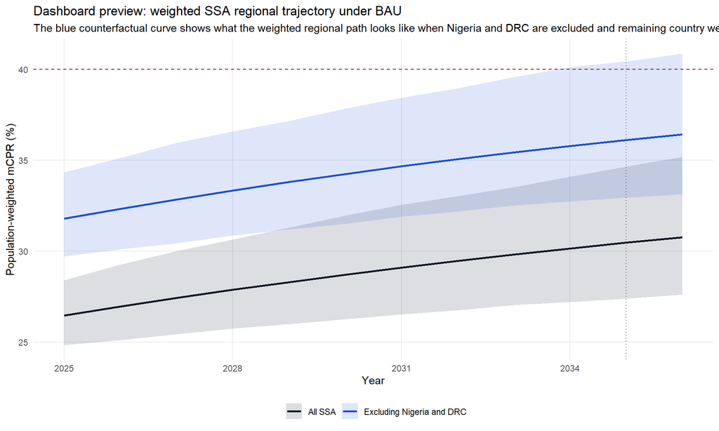

```r
ggplot(
  ssa_dashboard_region_curve %>% filter(year >= 2025),
  aes(x = year, y = 100 * p_mean, color = scenario, fill = scenario)
) +
  geom_hline(yintercept = 40, linetype = "dashed", color = "#8B0000", linewidth = 0.5) +
  geom_vline(xintercept = 2035, linetype = "dotted", color = "grey45", linewidth = 0.5) +
  geom_ribbon(aes(ymin = 100 * p_p05, ymax = 100 * p_p95), alpha = 0.14, color = NA) +
  geom_line(linewidth = 1.05) +
  scale_color_manual(
    values = c(
      "All SSA" = "#111827",
      "Excluding Nigeria and DRC" = "#1D4ED8"
    )
  ) +
  scale_fill_manual(
    values = c(
      "All SSA" = "#111827",
      "Excluding Nigeria and DRC" = "#1D4ED8"
    )
  ) +
  theme_minimal(base_size = 11) +
  theme(
    legend.position = "bottom",
    legend.title = element_blank(),
    panel.grid.minor = element_blank()
  ) +
  labs(
    title = "Dashboard preview: weighted SSA regional trajectory under BAU",
    subtitle = "The blue counterfactual curve shows what the weighted regional path looks like when Nigeria and DRC are excluded and remaining country weights are renormalized",
    x = "Year",
    y = "Population-weighted mCPR (%)"
  )
```

```r
knitr::kable(
  ssa_dashboard_region_summary %>%
    select(
      scenario, excluded_countries, last_obs_weighted_mean, p2025_mean, p2026_mean,
      required_growth_from_p2026_pp_per_year, model_dpdt_2026_pp_per_year,
      projected_year_reach_40_p50, prob_reach_40_by_2035, verdict
    ) %>%
    mutate(across(where(is.numeric), ~ round(.x, 3))),
  caption = "Dashboard preview: regional verdict under BAU, with and without Nigeria and DRC"
)
```

Dashboard preview: regional verdict under BAU, with and without Nigeria and DRC

| scenario | excluded_countries | last_obs_weighted_mean | p2025_mean | p2026_mean | required_growth_from_p2026_pp_per_year | model_dpdt_2026_pp_per_year | projected_year_reach_40_p50 | prob_reach_40_by_2035 | verdict |
| --- | --- | --- | --- | --- | --- | --- | --- | --- | --- |
| All SSA | None | 0.237 | 0.265 | 0.282 | 1.175 | 0.458 | 2035 | 0.000 | Aspirational under BAU |
| Excluding Nigeria and DRC | Nigeria, Congo Democratic Republic | 0.282 | 0.318 | 0.335 | 0.654 | 0.506 | 2034 | 0.038 | Aspirational under BAU |

### 24.19.2 Dashboard preview 2: current gap to 40% under two baselines

This preview compares the current gap to 40% using two baselines: a) the latest observed DHS mCPR; b) the model-estimated `p(2025)`.

That distinction matters because some countries have older latest surveys, while the `p(2025)` baseline places everyone on the same calendar footing.

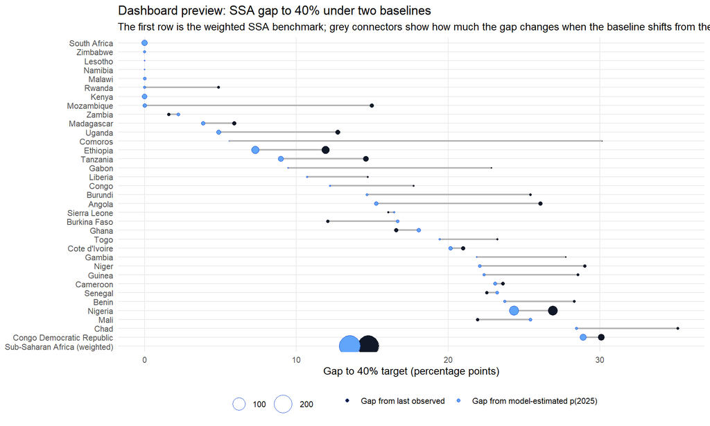

```r
ggplot(ssa_dashboard_gap_compare, aes(y = country)) +
  geom_segment(
    aes(x = gap_from_lastobs_pp, xend = gap_from_p2025_pp, yend = country),
    color = "grey70",
    linewidth = 0.75
  ) +
  geom_point(
    aes(x = gap_from_lastobs_pp, fill = "Gap from last observed", size = women_15_49_millions),
    shape = 21,
    color = "#111827",
    stroke = 0.35
  ) +
  geom_point(
    aes(x = gap_from_p2025_pp, fill = "Gap from model-estimated p(2025)", size = women_15_49_millions),
    shape = 21,
    color = "#1D4ED8",
    stroke = 0.35
  ) +
  scale_size_area(
    max_size = 10,
    name = "Women 15-49\n(millions)"
  ) +
  scale_fill_manual(
    values = c(
      "Gap from last observed" = "#111827",
      "Gap from model-estimated p(2025)" = "#60A5FA"
    )
  ) +
  theme_minimal(base_size = 10.5) +
  theme(
    legend.position = "bottom",
    legend.title = element_blank(),
    panel.grid.minor = element_blank()
  ) +
  labs(
    title = "Dashboard preview: SSA gap to 40% under two baselines",
    subtitle = "The first row is the weighted SSA benchmark; grey connectors show how much the gap changes when the baseline shifts from the latest observed DHS mCPR to model-estimated p(2025)",
    x = "Gap to 40% target (percentage points)",
    y = NULL
  )
```

### 24.19.3 Dashboard preview 3: is the required annualized growth rate realistic?

This preview compares the annual growth required from `p(2025)` to hit 40% by 2035 against the model-implied current annual growth rate at 2025.

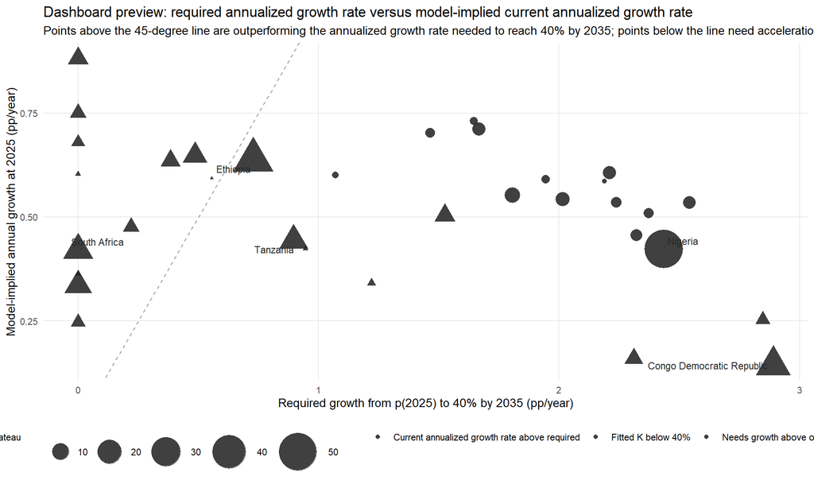

```r
ggplot(
  ssa_dashboard_feasibility,
  aes(
    x = required_growth_from_p2025_pp_per_year,
    y = model_dpdt_2025_pp_per_year,
    size = women_15_49_millions,
    fill = feasibility_status,
    shape = s_curve_stage_2026
  )
) +
  geom_abline(slope = 1, intercept = 0, linetype = "dashed", color = "grey45") +
  geom_point(color = "grey15", alpha = 0.88, stroke = 0.35) +
  ggrepel::geom_text_repel(
    data = ssa_dashboard_feasibility %>% filter(label_flag),
    aes(label = country),
    size = 3,
    color = "grey15",
    segment.alpha = 0.35,
    min.segment.length = 0
  ) +
  scale_size_area(max_size = 16, name = "Women 15-49\n(millions)") +
  scale_fill_manual(
    values = c(
      "Current annualized growth rate above required" = "#0F766E",
      "Needs return to historical peak" = "#F59E0B",
      "Needs growth above observed history" = "#B91C1C",
      "Fitted K below 40%" = "#7F1D1D"
    )
  ) +
  theme_minimal(base_size = 10.5) +
  theme(
    legend.position = "bottom",
    legend.title = element_blank(),
    panel.grid.minor = element_blank()
  ) +
  labs(
    title = "Dashboard preview: required annualized growth rate versus model-implied current annualized growth rate",
    subtitle = "Points above the 45-degree line are outperforming the annualized growth rate needed to reach 40% by 2035; points below the line need acceleration",
    x = "Required growth from p(2025) to 40% by 2035 (pp/year)",
    y = "Model-implied annual growth at 2025 (pp/year)"
  )
```

```r
knitr::kable(
  ssa_dashboard_stage2_window %>%
    select(
      country, region, weight_share_ssa, projected_year_reach_40_p50,
      prob_reach_40_by_2035, latest_obs_interval_growth_pp_per_year,
      model_dpdt_2026_pp_per_year, required_growth_from_p2026_pp_per_year,
      crossing_window_flag, underperforming_vs_latest_obs
    ) %>%
    mutate(across(where(is.numeric), ~ round(.x, 3))),
  caption = "Dashboard preview: Stage 2 countries, crossing-window potential, and diagnostic flags"
)
```

Dashboard preview: Stage 2 countries, crossing-window potential, and diagnostic flags

| country | region | weight_share_ssa | projected_year_reach_40_p50 | prob_reach_40_by_2035 | latest_obs_interval_growth_pp_per_year | model_dpdt_2026_pp_per_year | required_growth_from_p2026_pp_per_year | crossing_window_flag | underperforming_vs_latest_obs |
| --- | --- | --- | --- | --- | --- | --- | --- | --- | --- |
| Burundi | East/Southern Africa | 0.011 | 2031.453 | 0.201 | 0.595 | 0.666 | 1.395 | TRUE | FALSE |
| Nigeria | West Africa | 0.193 | 2053.527 | 0.014 | 0.432 | 0.418 | 2.394 | FALSE | TRUE |
| Ghana | West Africa | 0.031 | 2048.819 | 0.040 | 0.659 | 0.544 | 1.752 | FALSE | TRUE |
| Cote d’Ivoire | West Africa | 0.027 | 2050.478 | 0.038 | 0.567 | 0.537 | 1.961 | FALSE | TRUE |
| Niger | West Africa | 0.020 | 2050.961 | 0.034 | 1.075 | 0.604 | 2.148 | FALSE | TRUE |
| Burkina Faso | West Africa | 0.020 | 2049.814 | 0.078 | 1.244 | 0.705 | 1.595 | FALSE | TRUE |
| Mali | West Africa | 0.019 | 2055.352 | 0.006 | 0.529 | 0.532 | 2.489 | FALSE | FALSE |
| Senegal | West Africa | 0.016 | 2059.255 | 0.005 | -0.112 | 0.450 | 2.277 | FALSE | FALSE |
| Guinea | West Africa | 0.012 | 2050.540 | 0.035 | 0.732 | 0.532 | 2.185 | FALSE | TRUE |
| Benin | West Africa | 0.012 | 2052.256 | 0.023 | 0.544 | 0.506 | 2.323 | FALSE | TRUE |
| Togo | West Africa | 0.008 | 2048.260 | 0.046 | 0.592 | 0.584 | 1.886 | FALSE | TRUE |
| Sierra Leone | West Africa | 0.008 | 2046.073 | 0.121 | 0.508 | 0.725 | 1.573 | FALSE | FALSE |
| Liberia | West Africa | 0.005 | 2040.324 | 0.234 | 0.799 | 0.589 | 1.011 | FALSE | TRUE |
| Gambia | West Africa | 0.002 | 2048.477 | 0.045 | 0.954 | 0.584 | 2.130 | FALSE | TRUE |

### 24.19.4 Dashboard preview 4: structural ceiling, stage, and no-crossing countries

This panel focuses on where the fitted ceiling sits relative to the 40% target.

Interpretation: a) green countries have a fitted `K` fully above 40%; b) amber countries have a `K` interval that straddles 40%; c) red countries have a fitted `K` fully below 40%; d) shape distinguishes countries that are pre-inflection from those already post-inflection at 2026.

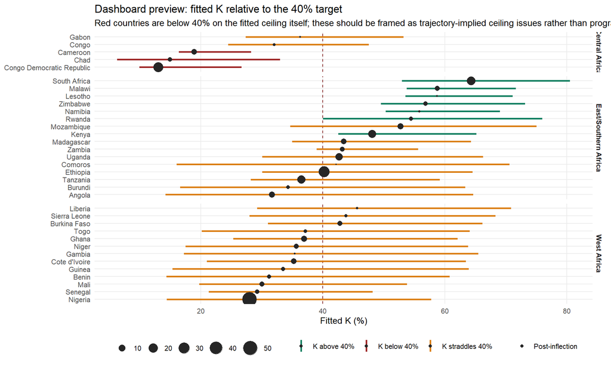

```r
ssa_dashboard_k_plot <- ssa_dashboard_country %>%
  mutate(
    country = factor(
      country,
      levels = ssa_dashboard_country %>%
        arrange(factor(region, levels = ssa_regions), K_mean, country) %>%
        pull(country)
    )
  )

ggplot(ssa_dashboard_k_plot, aes(x = country, y = 100 * K_mean)) +
  geom_hline(yintercept = 40, linetype = "dashed", color = "#7F1D1D", linewidth = 0.45) +
  geom_linerange(
    aes(ymin = 100 * K_p05, ymax = 100 * K_p95, color = k_status),
    linewidth = 0.9,
    alpha = 0.95
  ) +
  geom_point(
    aes(fill = k_status, shape = inflection_side_2026, size = women_15_49_millions),
    color = "grey15",
    stroke = 0.35
  ) +
  coord_flip() +
  facet_grid(region ~ ., scales = "free_y", space = "free_y") +
  scale_fill_manual(
    values = c(
      "K above 40%" = "#059669",
      "K straddles 40%" = "#F59E0B",
      "K below 40%" = "#B91C1C"
    )
  ) +
  scale_color_manual(
    values = c(
      "K above 40%" = "#047857",
      "K straddles 40%" = "#D97706",
      "K below 40%" = "#991B1B"
    )
  ) +
  scale_size_area(
    max_size = 8,
    name = "Women 15-49\n(millions)"
  ) +
  theme_minimal(base_size = 10.5) +
  theme(
    legend.position = "bottom",
    legend.title = element_blank(),
    panel.grid.minor = element_blank(),
    strip.text.y = element_text(face = "bold")
  ) +
  labs(
    title = "Dashboard preview: fitted K relative to the 40% target",
    subtitle = "Red countries are below 40% on the fitted ceiling itself; these should be framed as trajectory-implied ceiling issues rather than program failure",
    x = NULL,
    y = "Fitted K (%)"
  )
```

```r
knitr::kable(
  ssa_dashboard_no_crossing %>%
    select(
      country, region, women_15_49_millions, weight_share_ssa, p2025_mean, p2026_mean,
      K_mean, K_p05, K_p95, years_since_t0_2026, s_curve_stage_2026,
      prob_reach_40_by_2035, target40_status
    ) %>%
    mutate(across(where(is.numeric), ~ round(.x, 3))),
  caption = "Dashboard preview: countries with no projected crossing or K below 40%"
)
```

Dashboard preview: countries with no projected crossing or K below 40%

| country | region | women_15_49_millions | weight_share_ssa | p2025_mean | p2026_mean | K_mean | K_p05 | K_p95 | years_since_t0_2026 | s_curve_stage_2026 | prob_reach_40_by_2035 | target40_status |
| --- | --- | --- | --- | --- | --- | --- | --- | --- | --- | --- | --- | --- |
| Congo Democratic Republic | Central Africa | 23.561 | 0.084 | 0.111 | 0.112 | 0.130 | 0.099 | 0.267 | 20.793 | Stage 3: plateau | 0.001 | Projected to cross by 2035 |
| Cameroon | Central Africa | 6.936 | 0.025 | 0.169 | 0.170 | 0.189 | 0.164 | 0.282 | 23.062 | Stage 3: plateau | 0.000 | Projected to cross after 2035 |
| Chad | Central Africa | 4.363 | 0.015 | 0.115 | 0.118 | 0.149 | 0.063 | 0.330 | 14.366 | Stage 3: plateau | 0.004 | Projected to cross after 2035 |

### 24.19.5 Dashboard preview 5: country heterogeneity relative to the SSA trajectory

This preview highlights outliers and heterogeneity directly.

Interpretation: a) the x-axis compares each country’s model-estimated `p(2025)` against the weighted SSA `p(2025)`; b) points to the right are above the weighted SSA trajectory and points to the left are below it; c) the y-axis is the posterior probability of reaching 40% by 2035; d) larger points matter more for the regional conversation because of population size.

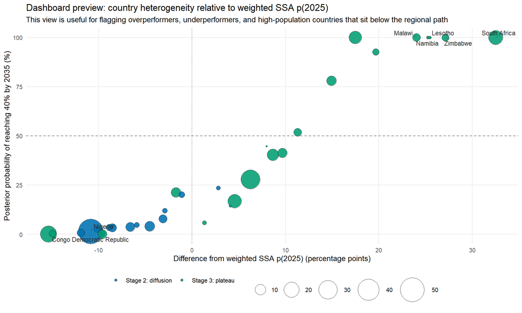

```r
ggplot(
  ssa_dashboard_country,
  aes(
    x = relative_to_ssa_p2025_pp,
    y = 100 * prob_reach_40_by_2035,
    size = women_15_49_millions,
    fill = s_curve_stage_2026
  )
) +
  geom_vline(xintercept = 0, linetype = "dotted", color = "grey45", linewidth = 0.45) +
  geom_hline(yintercept = 50, linetype = "dashed", color = "grey45", linewidth = 0.45) +
  geom_point(shape = 21, color = "grey15", alpha = 0.88, stroke = 0.35) +
  ggrepel::geom_text_repel(
    data = ssa_dashboard_country %>%
      filter(
        country %in% c("Nigeria", "Congo Democratic Republic") |
          abs(relative_to_ssa_p2025_pp) >= quantile(abs(relative_to_ssa_p2025_pp), 0.85, na.rm = TRUE)
      ),
    aes(label = country),
    size = 3,
    color = "grey15",
    segment.alpha = 0.35,
    min.segment.length = 0
  ) +
  scale_size_area(max_size = 16, name = "Women 15-49\n(millions)") +
  scale_fill_manual(
    values = c(
      "Stage 1: initial" = "#D55E00",
      "Stage 2: diffusion" = "#0072B2",
      "Stage 3: plateau" = "#009E73"
    )
  ) +
  theme_minimal(base_size = 10.5) +
  theme(
    legend.position = "bottom",
    legend.title = element_blank(),
    panel.grid.minor = element_blank()
  ) +
  labs(
    title = "Dashboard preview: country heterogeneity relative to weighted SSA p(2025)",
    subtitle = "This view is useful for flagging overperformers, underperformers, and high-population countries that sit below the regional path",
    x = "Difference from weighted SSA p(2025) (percentage points)",
    y = "Posterior probability of reaching 40% by 2035 (%)"
  )
```

### 24.19.6 Dashboard preview note on equity

The dashboard should keep an equity perspective visible, but the current model has an important boundary: it is a country-level trajectory model, not a within-country subgroup model.

That means the current static preview can support: a) keeping `Maintain / equity` visible as a meaningful planning category; b) distinguishing countries near saturation from countries still in rapid diffusion; c) showing where historical trajectories imply ceilings below 40%, without treating that as program failure.

What it cannot yet show directly is within-country inequality by wealth, geography, age, or other subgroups. That would require an explicit subgroup extension to the analysis rather than a relabeling of current country-level outputs.

## 24.20 Goals - final

This section pulls the SSA goal work into one final set of static views for decision-making.

The logic is: a) define the SSA “current level” two ways using population weights; b) convert each gap to 40% into a required annualized growth rate over the 2025 to 2045 goal window; c) compare that required annualized growth rate against observed survey-based growth, current model-implied growth, and average model-projected growth over 2025 to 2045; d) show the weighted SSA regional trajectory and every country trajectory in one place.

For the weighted SSA region, the “latest observed” baseline is the population-weighted average across each country’s latest observed DHS mCPR, not a single same-year regional survey point.

```r
# Final SSA goals block: combine the weighted regional benchmark and all SSA
# countries in one table so the same quantities drive all final charts.
ssa_goal_final_target_year <- 2045
ssa_goal_final_base_year <- 2025
ssa_goal_final_window_years <- ssa_goal_final_target_year - ssa_goal_final_base_year
ssa_goal_final_priority_geographies <- c(
  "Nigeria",
  "Senegal",
  "Ethiopia",
  "Burkina Faso",
  "Cote d'Ivoire",
  "Kenya",
  "Niger"
)
ssa_goal_final_priority_label <- "Priority geographies (weighted)"

make_goal_status <- function(last_obs_level, crossing_year, goal_year) {
  dplyr::case_when(
    last_obs_level >= target_mcpr_40 ~ "Already crossed",
    is.na(crossing_year) ~ "Not projected to cross",
    crossing_year <= goal_year ~ paste0("Projected to cross by ", goal_year),
    TRUE ~ paste0("Projected to cross after ", goal_year)
  )
}

make_goal_label <- function(last_obs_level, crossing_year, goal_year) {
  dplyr::case_when(
    last_obs_level >= target_mcpr_40 ~ "Already crossed",
    is.na(crossing_year) ~ "Not projected to cross",
    crossing_year <= goal_year ~ paste0(
      "Projected by ",
      goal_year,
      " (~",
      round(crossing_year),
      ")"
    ),
    TRUE ~ paste0(
      "Projected after ",
      goal_year,
      " (~",
      round(crossing_year),
      ")"
    )
  )
}

weighted_country_draws_at_year <- function(country_names, year_value) {
  country_cols <- match(country_names, ssa_country_order_vec)
  country_weights <- ssa_weight_latest$women_15_49[match(country_names, ssa_weight_latest$country)]
  country_weights <- country_weights / sum(country_weights, na.rm = TRUE)
  as.numeric(
    logistic_draws_at_year(
      ssa_K_draws[, country_cols, drop = FALSE],
      ssa_t0_draws[, country_cols, drop = FALSE],
      ssa_s_draws[, country_cols, drop = FALSE],
      year_value
    ) %*% country_weights
  )
}

weighted_country_dpdt_draws_at_year <- function(country_names, year_value) {
  country_cols <- match(country_names, ssa_country_order_vec)
  country_weights <- ssa_weight_latest$women_15_49[match(country_names, ssa_weight_latest$country)]
  country_weights <- country_weights / sum(country_weights, na.rm = TRUE)
  K_i <- ssa_K_draws[, country_cols, drop = FALSE]
  t0_i <- ssa_t0_draws[, country_cols, drop = FALSE]
  s_i <- ssa_s_draws[, country_cols, drop = FALSE]
  t_mat_i <- matrix(year_value - 2000, nrow = nrow(K_i), ncol = ncol(K_i))
  z_i <- exp(-(t_mat_i - t0_i) / s_i)
  dpdt_i <- (K_i / s_i) * z_i / (1 + z_i)^2
  as.numeric(dpdt_i %*% country_weights)
}

ssa_p2045_draws <- logistic_draws_at_year(
  ssa_K_draws,
  ssa_t0_draws,
  ssa_s_draws,
  ssa_goal_final_target_year
)

ssa_p2045_country_summary <- tibble(
  country = ssa_country_order_vec,
  p2045_mean = colMeans(ssa_p2045_draws)
)

ssa_goal_final_prob_goal_year <- tibble(
  country = ssa_country_order_vec,
  prob_reach_40_by_goal_year = colMeans(
    !is.na(ssa_target40_year_mat) & ssa_target40_year_mat <= ssa_goal_final_target_year
  )
)

ssa_forward_growth_country <- tibble(
  country = ssa_country_order_vec,
  projected_growth_2025_2045_pp_per_year =
    100 * colMeans((ssa_p2045_draws - ssa_p2025_draws) / ssa_goal_final_window_years)
)

ssa_region_K_draws <- as.numeric(ssa_K_draws %*% ssa_weight_vec_latest)
ssa_region_p2045_draws_final <- as.numeric(ssa_p2045_draws %*% ssa_weight_vec_latest)
ssa_region_forward_growth_2025_2045_draws <-
  (ssa_region_p2045_draws_final - ssa_region_p2025_draws) / ssa_goal_final_window_years

ssa_region_k_horizon_years <- seq(
  min(mcpr_logistic_data$year[mcpr_logistic_data$region %in% ssa_regions], na.rm = TRUE),
  2100,
  by = 1
)

ssa_region_draws_k_horizon <- sapply(ssa_region_k_horizon_years, function(yy) {
  region_country_draws <- logistic_draws_at_year(ssa_K_draws, ssa_t0_draws, ssa_s_draws, yy)
  as.numeric(region_country_draws %*% ssa_weight_vec_latest)
})

ssa_region_year_reach_99pctK_draws <- apply(
  ssa_region_draws_k_horizon >=
    matrix(
      0.99 * ssa_region_K_draws,
      nrow = nrow(ssa_region_draws_k_horizon),
      ncol = ncol(ssa_region_draws_k_horizon)
    ),
  1,
  function(hit_vec) {
    idx <- which(hit_vec)
    if (length(idx) == 0) NA_real_ else ssa_region_k_horizon_years[min(idx)]
  }
)

ssa_region_goal_final_status <- case_when(
  ssa_region_goals_summary$last_obs_weighted_mean >= target_mcpr_40 ~ "Already crossed",
  is.na(ssa_region_goals_summary$projected_year_reach_40_p50) ~ "Not projected to cross",
  ssa_region_goals_summary$projected_year_reach_40_p50 <= ssa_goal_final_target_year ~ paste0("Projected to cross by ", ssa_goal_final_target_year),
  TRUE ~ paste0("Projected to cross after ", ssa_goal_final_target_year)
)

ssa_region_goal_final_label <- case_when(
  ssa_region_goals_summary$last_obs_weighted_mean >= target_mcpr_40 ~ "Already crossed",
  is.na(ssa_region_goals_summary$projected_year_reach_40_p50) ~ "Not projected to cross",
  ssa_region_goals_summary$projected_year_reach_40_p50 <= ssa_goal_final_target_year ~ paste0(
    "Projected by ",
    ssa_goal_final_target_year,
    " (~",
    round(ssa_region_goals_summary$projected_year_reach_40_p50),
    ")"
  ),
  TRUE ~ paste0(
    "Projected after ",
    ssa_goal_final_target_year,
    " (~",
    round(ssa_region_goals_summary$projected_year_reach_40_p50)
    ,")"
  )
)

ssa_goal_final_country_rows <- ssa_goals_country_table %>%
  left_join(
    ssa_goal_final_prob_goal_year,
    by = c("country" = "country")
  ) %>%
  left_join(
    ssa_p2045_country_summary,
    by = "country"
  ) %>%
  left_join(
    ssa_forward_growth_country,
    by = "country"
  ) %>%
  left_join(
    time_to_k_table %>%
      transmute(country, year_reach_99pctK_mean),
    by = "country"
  ) %>%
  mutate(
    geography = country,
    geography_type = "Country",
    women_15_49_millions = women_15_49 / 1e6,
    current_latest_obs_pct = 100 * last_obs_mcpr,
    current_p2025_pct = 100 * p2025_mean,
    current_p2045_pct = 100 * p2045_mean,
    gap_from_lastobs_pp = 100 * pmax(target_mcpr_40 - last_obs_mcpr, 0),
    gap_from_p2025_pp = 100 * pmax(target_mcpr_40 - p2025_mean, 0),
    required_growth_from_lastobs_pp_per_year = gap_from_lastobs_pp / ssa_goal_final_window_years,
    required_growth_from_p2025_pp_per_year = gap_from_p2025_pp / ssa_goal_final_window_years,
    survey_recency_group = case_when(
      last_obs_year >= 2015 ~ "Latest survey 2015 or later",
      TRUE ~ "Latest survey before 2015"
    ),
    trajectory_status_final = make_goal_status(last_obs_mcpr, projected_year_reach_40_p50, ssa_goal_final_target_year),
    crossing_label_final = make_goal_label(last_obs_mcpr, projected_year_reach_40_p50, ssa_goal_final_target_year),
    geography_label = paste0(
      geography,
      " (",
      format(round(women_15_49_millions, 1), nsmall = 1),
      "m)"
    )
  ) %>%
  select(
    geography, geography_type, geography_label, region,
    women_15_49, women_15_49_millions, weight_share_ssa,
    last_obs_year, survey_recency_group,
    current_latest_obs_pct, current_p2025_pct, current_p2045_pct,
    gap_from_lastobs_pp, gap_from_p2025_pp,
    required_growth_from_lastobs_pp_per_year,
    required_growth_from_p2025_pp_per_year,
    latest_obs_interval_growth_pp_per_year,
    model_dpdt_2025_pp_per_year,
    model_dpdt_2026_pp_per_year,
    projected_growth_2025_2045_pp_per_year,
    K_mean, K_p05, K_p95, year_reach_99pctK_mean,
    projected_year_reach_40_p50, prob_reach_40_by_goal_year,
    trajectory_status_final, crossing_label_final
  )
```

```r
ssa_region_prob_reach_goal_year <- mean(
  !is.na(ssa_region_year40_draws) & ssa_region_year40_draws <= ssa_goal_final_target_year
)

ssa_goal_final_region_row <- tibble(
  geography = "Sub-Saharan Africa (weighted)",
  geography_type = "Region",
  geography_label = paste0(
    "Sub-Saharan Africa (weighted) (",
    format(round(sum(ssa_weight_latest$women_15_49, na.rm = TRUE) / 1e6, 1), nsmall = 1),
    "m)"
  ),
  region = "Sub-Saharan Africa",
  women_15_49 = sum(ssa_weight_latest$women_15_49, na.rm = TRUE),
  women_15_49_millions = sum(ssa_weight_latest$women_15_49, na.rm = TRUE) / 1e6,
  weight_share_ssa = 1,
  last_obs_year = NA_real_,
  survey_recency_group = "Population-weighted SSA region",
  current_latest_obs_pct = 100 * ssa_region_goals_summary$last_obs_weighted_mean,
  current_p2025_pct = 100 * ssa_region_goals_summary$p2025_mean,
  current_p2045_pct = 100 * mean(ssa_region_p2045_draws_final),
  gap_from_lastobs_pp = 100 * pmax(target_mcpr_40 - ssa_region_goals_summary$last_obs_weighted_mean, 0),
  gap_from_p2025_pp = 100 * pmax(target_mcpr_40 - ssa_region_goals_summary$p2025_mean, 0),
  required_growth_from_lastobs_pp_per_year = gap_from_lastobs_pp / ssa_goal_final_window_years,
  required_growth_from_p2025_pp_per_year = gap_from_p2025_pp / ssa_goal_final_window_years,
  latest_obs_interval_growth_pp_per_year =
    ssa_region_goals_summary$observed_latest_interval_growth_pp_per_year,
  model_dpdt_2025_pp_per_year =
    ssa_region_goals_summary$model_dpdt_2025_pp_per_year,
  model_dpdt_2026_pp_per_year =
    ssa_region_goals_summary$model_dpdt_2026_pp_per_year,
  projected_growth_2025_2045_pp_per_year =
    100 * mean(ssa_region_forward_growth_2025_2045_draws),
  K_mean = mean(ssa_region_K_draws),
  K_p05 = quantile(ssa_region_K_draws, ci_lower),
  K_p95 = quantile(ssa_region_K_draws, ci_upper),
  year_reach_99pctK_mean =
    if (all(is.na(ssa_region_year_reach_99pctK_draws))) {
      NA_real_
    } else {
      mean(ssa_region_year_reach_99pctK_draws, na.rm = TRUE)
    },
  projected_year_reach_40_p50 = ssa_region_goals_summary$projected_year_reach_40_p50,
  prob_reach_40_by_goal_year = ssa_region_prob_reach_goal_year,
  trajectory_status_final = ssa_region_goal_final_status,
  crossing_label_final = ssa_region_goal_final_label
)

ssa_goal_final_priority_weights <- ssa_weight_latest %>%
  filter(country %in% ssa_goal_final_priority_geographies) %>%
  mutate(priority_order = match(country, ssa_goal_final_priority_geographies)) %>%
  arrange(priority_order) %>%
  select(-priority_order)

if (!identical(ssa_goal_final_priority_weights$country, ssa_goal_final_priority_geographies)) {
  stop("Priority geography weights are not aligned to the plotting country order.")
}

ssa_goal_final_priority_weight_vec <- ssa_goal_final_priority_weights$women_15_49 /
  sum(ssa_goal_final_priority_weights$women_15_49, na.rm = TRUE)

ssa_goal_final_priority_lastobs_weighted_mean <- weighted.mean(
  ssa_goal_final_country_rows$current_latest_obs_pct[
    match(ssa_goal_final_priority_geographies, ssa_goal_final_country_rows$geography)
  ] / 100,
  ssa_goal_final_priority_weight_vec,
  na.rm = TRUE
)

ssa_priority_p2025_draws <- weighted_country_draws_at_year(
  ssa_goal_final_priority_geographies,
  2025
)
ssa_priority_p2045_draws <- weighted_country_draws_at_year(
  ssa_goal_final_priority_geographies,
  ssa_goal_final_target_year
)
ssa_priority_dpdt_2025_draws <- weighted_country_dpdt_draws_at_year(
  ssa_goal_final_priority_geographies,
  2025
)

ssa_priority_draws_k_horizon <- sapply(ssa_region_k_horizon_years, function(yy) {
  weighted_country_draws_at_year(ssa_goal_final_priority_geographies, yy)
})

ssa_priority_K_draws <- as.numeric(
  ssa_K_draws[, match(ssa_goal_final_priority_geographies, ssa_country_order_vec), drop = FALSE] %*%
    ssa_goal_final_priority_weight_vec
)

ssa_priority_year_reach_99pctK_draws <- apply(
  ssa_priority_draws_k_horizon >=
    matrix(
      0.99 * ssa_priority_K_draws,
      nrow = nrow(ssa_priority_draws_k_horizon),
      ncol = ncol(ssa_priority_draws_k_horizon)
    ),
  1,
  function(hit_vec) {
    idx <- which(hit_vec)
    if (length(idx) == 0) NA_real_ else ssa_region_k_horizon_years[min(idx)]
  }
)

ssa_priority_year40_draws <- apply(ssa_priority_draws_k_horizon, 1, function(x) {
  idx <- which(x >= target_mcpr_40)
  if (length(idx) == 0) NA_real_ else ssa_region_k_horizon_years[min(idx)]
})

ssa_goal_final_priority_row <- tibble(
  geography = ssa_goal_final_priority_label,
  geography_type = "Priority geographies",
  geography_label = paste0(
    ssa_goal_final_priority_label,
    " (",
    format(round(sum(ssa_goal_final_priority_weights$women_15_49, na.rm = TRUE) / 1e6, 1), nsmall = 1),
    "m)"
  ),
  region = "Priority geographies",
  women_15_49 = sum(ssa_goal_final_priority_weights$women_15_49, na.rm = TRUE),
  women_15_49_millions = sum(ssa_goal_final_priority_weights$women_15_49, na.rm = TRUE) / 1e6,
  weight_share_ssa = sum(ssa_goal_final_priority_weights$women_15_49, na.rm = TRUE) /
    sum(ssa_weight_latest$women_15_49, na.rm = TRUE),
  last_obs_year = NA_real_,
  survey_recency_group = "Priority geographies (weighted)",
  current_latest_obs_pct = 100 * ssa_goal_final_priority_lastobs_weighted_mean,
  current_p2025_pct = 100 * mean(ssa_priority_p2025_draws),
  current_p2045_pct = 100 * mean(ssa_priority_p2045_draws),
  gap_from_lastobs_pp = 100 * pmax(target_mcpr_40 - ssa_goal_final_priority_lastobs_weighted_mean, 0),
  gap_from_p2025_pp = 100 * pmax(target_mcpr_40 - mean(ssa_priority_p2025_draws), 0),
  required_growth_from_lastobs_pp_per_year = gap_from_lastobs_pp / ssa_goal_final_window_years,
  required_growth_from_p2025_pp_per_year = gap_from_p2025_pp / ssa_goal_final_window_years,
  latest_obs_interval_growth_pp_per_year = weighted.mean(
    ssa_goal_final_country_rows$latest_obs_interval_growth_pp_per_year[
      match(ssa_goal_final_priority_geographies, ssa_goal_final_country_rows$geography)
    ],
    ssa_goal_final_priority_weight_vec,
    na.rm = TRUE
  ),
  model_dpdt_2025_pp_per_year = 100 * mean(ssa_priority_dpdt_2025_draws),
  model_dpdt_2026_pp_per_year = 100 * mean(weighted_country_dpdt_draws_at_year(
    ssa_goal_final_priority_geographies,
    2026
  )),
  projected_growth_2025_2045_pp_per_year =
    100 * mean((ssa_priority_p2045_draws - ssa_priority_p2025_draws) / ssa_goal_final_window_years),
  K_mean = mean(ssa_priority_K_draws),
  K_p05 = quantile(ssa_priority_K_draws, ci_lower),
  K_p95 = quantile(ssa_priority_K_draws, ci_upper),
  year_reach_99pctK_mean =
    if (all(is.na(ssa_priority_year_reach_99pctK_draws))) {
      NA_real_
    } else {
      mean(ssa_priority_year_reach_99pctK_draws, na.rm = TRUE)
    },
  projected_year_reach_40_p50 =
    if (all(is.na(ssa_priority_year40_draws))) NA_real_ else median(ssa_priority_year40_draws, na.rm = TRUE),
  prob_reach_40_by_goal_year =
    mean(!is.na(ssa_priority_year40_draws) & ssa_priority_year40_draws <= ssa_goal_final_target_year),
  trajectory_status_final = make_goal_status(
    ssa_goal_final_priority_lastobs_weighted_mean,
    if (all(is.na(ssa_priority_year40_draws))) NA_real_ else median(ssa_priority_year40_draws, na.rm = TRUE),
    ssa_goal_final_target_year
  ),
  crossing_label_final = make_goal_label(
    ssa_goal_final_priority_lastobs_weighted_mean,
    if (all(is.na(ssa_priority_year40_draws))) NA_real_ else median(ssa_priority_year40_draws, na.rm = TRUE),
    ssa_goal_final_target_year
  )
)
```

```r
ssa_goal_final_all <- bind_rows(
  ssa_goal_final_region_row,
  ssa_goal_final_priority_row,
  ssa_goal_final_country_rows
)

ssa_goal_final_current_summary <- tibble(
  measure = c(
    "Population-weighted latest observed mCPR across each country's last survey year",
    "Population-weighted model-estimated mCPR in 2025"
  ),
  mcpr_pct = c(
    ssa_goal_final_region_row$current_latest_obs_pct,
    ssa_goal_final_region_row$current_p2025_pct
  ),
  gap_to_40_pp = c(
    ssa_goal_final_region_row$gap_from_lastobs_pp,
    ssa_goal_final_region_row$gap_from_p2025_pp
  ),
  required_growth_pp_per_year = c(
    ssa_goal_final_region_row$required_growth_from_lastobs_pp_per_year,
    ssa_goal_final_region_row$required_growth_from_p2025_pp_per_year
  )
)

ssa_goal_final_priority_current_summary <- tibble(
  measure = c(
    "Population-weighted latest observed mCPR across the priority geographies",
    "Population-weighted model-estimated mCPR in 2025 across the priority geographies"
  ),
  mcpr_pct = c(
    ssa_goal_final_priority_row$current_latest_obs_pct,
    ssa_goal_final_priority_row$current_p2025_pct
  ),
  gap_to_40_pp = c(
    ssa_goal_final_priority_row$gap_from_lastobs_pp,
    ssa_goal_final_priority_row$gap_from_p2025_pp
  ),
  required_growth_pp_per_year = c(
    ssa_goal_final_priority_row$required_growth_from_lastobs_pp_per_year,
    ssa_goal_final_priority_row$required_growth_from_p2025_pp_per_year
  )
)

ssa_goal_final_region_label <- ssa_goal_final_region_row$geography_label
ssa_goal_final_priority_label_full <- ssa_goal_final_priority_row$geography_label

strip_goal_final_population_suffix <- function(x) {
  sub(" \\([^)]*m\\)$", "", x)
}

priority_country_axis_labels <- function(labels) {
  as.expression(
    lapply(labels, function(lbl) {
      base_lbl <- strip_goal_final_population_suffix(lbl)
      if (base_lbl %in% ssa_goal_final_priority_geographies) {
        bquote(bold(.(lbl)))
      } else {
        lbl
      }
    })
  )
}

priority_focus_weighted_axis_labels <- function(labels) {
  as.expression(
    lapply(labels, function(lbl) {
      base_lbl <- strip_goal_final_population_suffix(lbl)
      if (base_lbl %in% c("Sub-Saharan Africa (weighted)", ssa_goal_final_priority_label)) {
        bquote(bold(.(lbl)))
      } else {
        lbl
      }
    })
  )
}

ssa_goal_final_focus_group_levels <- c(
  "SSA weighted",
  "Priority geographies weighted",
  "Priority countries",
  "Other countries"
)

ssa_goal_final_focus_group_cols <- c(
  "SSA weighted" = "#0072B2",
  "Priority geographies weighted" = "#E69F00",
  "Priority countries" = "#009E73",
  "Other countries" = "#C8CDD3"
)

ssa_goal_final_asymptote_fill_cols <- c(
  "Latest observed mCPR" = "#4D4D4D",
  "Model-estimated mCPR(2025)" = "#0072B2",
  "Fitted K" = "#D55E00"
)

ssa_goal_final_asymptote_outline_cols <- c(
  "Latest observed mCPR" = "#1F1F1F",
  "Model-estimated mCPR(2025)" = "#004F80",
  "Fitted K" = "#9A3E00"
)

ssa_goal_final_asymptote_fill_cols_cb <- ssa_goal_final_asymptote_fill_cols
ssa_goal_final_asymptote_outline_cols_cb <- ssa_goal_final_asymptote_outline_cols

ssa_goal_final_required_order_labels <- c(
  ssa_goal_final_region_label,
  ssa_goal_final_priority_label_full,
  ssa_goal_final_country_rows %>%
    arrange(desc(required_growth_from_p2025_pp_per_year), geography) %>%
    pull(geography_label)
)

ssa_goal_final_gap_p2025_order_labels <- c(
  ssa_goal_final_region_label,
  ssa_goal_final_priority_label_full,
  ssa_goal_final_country_rows %>%
    arrange(desc(gap_from_p2025_pp), geography) %>%
    pull(geography_label)
)

ssa_goal_final_gap_lastobs <- ssa_goal_final_all %>%
  mutate(
    geography_label_plot = factor(
      geography_label,
      levels = rev(c(
        ssa_goal_final_region_label,
        ssa_goal_final_priority_label_full,
        ssa_goal_final_country_rows %>%
          arrange(desc(gap_from_lastobs_pp), geography) %>%
          pull(geography_label)
      )),
      ordered = TRUE
    ),
    goal_fill_group = factor(case_when(
      geography == "Sub-Saharan Africa (weighted)" ~ "SSA weighted",
      geography == ssa_goal_final_priority_label ~ "Priority geographies weighted",
      geography %in% ssa_goal_final_priority_geographies ~ "Priority countries",
      TRUE ~ "Other countries"
    ), levels = ssa_goal_final_focus_group_levels),
    growth_label = paste0(
      format(round(required_growth_from_lastobs_pp_per_year, 1), nsmall = 1),
      " pp/yr"
    )
  )

ssa_goal_final_gap_p2025 <- ssa_goal_final_all %>%
  mutate(
    geography_label_plot = factor(
      geography_label,
      levels = rev(ssa_goal_final_gap_p2025_order_labels),
      ordered = TRUE
    ),
    goal_fill_group = factor(case_when(
      geography == "Sub-Saharan Africa (weighted)" ~ "SSA weighted",
      geography == ssa_goal_final_priority_label ~ "Priority geographies weighted",
      geography %in% ssa_goal_final_priority_geographies ~ "Priority countries",
      TRUE ~ "Other countries"
    ), levels = ssa_goal_final_focus_group_levels),
    growth_label = paste0(
      format(round(required_growth_from_p2025_pp_per_year, 1), nsmall = 1),
      " pp/yr"
    )
  )

ssa_goal_final_priority_focus_geographies <- c(
  "Sub-Saharan Africa (weighted)",
  ssa_goal_final_priority_label,
  ssa_goal_final_priority_geographies
)

ssa_goal_final_gap_p2025_priority_focus_labels <- c(
  ssa_goal_final_region_label,
  ssa_goal_final_priority_label_full,
  ssa_goal_final_country_rows %>%
    filter(geography %in% ssa_goal_final_priority_geographies) %>%
    arrange(desc(gap_from_p2025_pp), geography) %>%
    pull(geography_label)
)

ssa_goal_final_required_priority_focus_labels <- c(
  ssa_goal_final_region_label,
  ssa_goal_final_priority_label_full,
  ssa_goal_final_country_rows %>%
    filter(geography %in% ssa_goal_final_priority_geographies) %>%
    arrange(desc(required_growth_from_p2025_pp_per_year), geography) %>%
    pull(geography_label)
)

ssa_goal_final_priority_country_labels <- ssa_goal_final_country_rows %>%
  filter(geography %in% ssa_goal_final_priority_geographies) %>%
  arrange(match(geography, ssa_goal_final_priority_geographies)) %>%
  pull(geography_label)
```

```r
ssa_goal_final_gap_p2025_priority_focus <- ssa_goal_final_gap_p2025 %>%
  filter(geography %in% ssa_goal_final_priority_focus_geographies) %>%
  mutate(
    geography_label_plot = factor(
      geography_label,
      levels = rev(ssa_goal_final_gap_p2025_priority_focus_labels),
      ordered = TRUE
    )
  )

ssa_goal_final_pace_long <- ssa_goal_final_all %>%
  select(
    geography, geography_label, region, women_15_49_millions,
    required_growth_from_p2025_pp_per_year,
    latest_obs_interval_growth_pp_per_year,
    model_dpdt_2025_pp_per_year,
    projected_growth_2025_2045_pp_per_year
  ) %>%
  tidyr::pivot_longer(
    cols = c(
      required_growth_from_p2025_pp_per_year,
      latest_obs_interval_growth_pp_per_year,
      model_dpdt_2025_pp_per_year,
      projected_growth_2025_2045_pp_per_year
    ),
    names_to = "growth_metric",
    values_to = "growth_pp_per_year"
  ) %>%
  mutate(
    growth_metric = factor(
      growth_metric,
      levels = c(
        "required_growth_from_p2025_pp_per_year",
        "latest_obs_interval_growth_pp_per_year",
        "model_dpdt_2025_pp_per_year",
        "projected_growth_2025_2045_pp_per_year"
      ),
      labels = c(
        paste0("Required growth\nto hit 40% by ", ssa_goal_final_target_year),
        "Observed growth\nfrom latest survey interval",
        "Model-implied growth\nat 2025",
        paste0("Average projected growth\n2025-", ssa_goal_final_target_year)
      )
    ),
    geography_label_plot = factor(
      geography_label,
      levels = rev(ssa_goal_final_required_order_labels),
      ordered = TRUE
    )
  )

ssa_goal_final_pace_range <- ssa_goal_final_pace_long %>%
  group_by(geography_label_plot) %>%
  summarise(
    x_min = min(growth_pp_per_year, na.rm = TRUE),
    x_max = max(growth_pp_per_year, na.rm = TRUE),
    .groups = "drop"
  )

ssa_goal_final_pace_focus_long <- ssa_goal_final_pace_long %>%
  filter(geography %in% ssa_goal_final_priority_focus_geographies) %>%
  mutate(
    geography_label_plot = factor(
      geography_label,
      levels = rev(ssa_goal_final_required_priority_focus_labels),
      ordered = TRUE
    )
  )

ssa_goal_final_pace_focus_range <- ssa_goal_final_pace_focus_long %>%
  group_by(geography_label_plot) %>%
  summarise(
    x_min = min(growth_pp_per_year, na.rm = TRUE),
    x_max = max(growth_pp_per_year, na.rm = TRUE),
    .groups = "drop"
  )

ssa_goal_final_required_vs_observed_long <- ssa_goal_final_all %>%
  select(
    geography,
    geography_label,
    required_growth_from_p2025_pp_per_year,
    latest_obs_interval_growth_pp_per_year
  ) %>%
  tidyr::pivot_longer(
    cols = c(
      required_growth_from_p2025_pp_per_year,
      latest_obs_interval_growth_pp_per_year
    ),
    names_to = "growth_metric",
    values_to = "growth_pp_per_year"
  ) %>%
  mutate(
    growth_metric = factor(
      growth_metric,
      levels = c(
        "required_growth_from_p2025_pp_per_year",
        "latest_obs_interval_growth_pp_per_year"
      ),
      labels = c(
        paste0("Required growth\nto hit 40% by ", ssa_goal_final_target_year),
        "Observed growth\nfrom latest survey interval"
      )
    ),
    geography_label_plot = factor(
      geography_label,
      levels = rev(ssa_goal_final_required_order_labels),
      ordered = TRUE
    )
  )

ssa_goal_final_required_vs_observed_range <- ssa_goal_final_required_vs_observed_long %>%
  group_by(geography_label_plot) %>%
  summarise(
    x_min = min(growth_pp_per_year, na.rm = TRUE),
    x_max = max(growth_pp_per_year, na.rm = TRUE),
    .groups = "drop"
  )

ssa_goal_final_projected_track <- ssa_goal_final_all %>%
  mutate(
    projected_growth_gap_pp_per_year =
      projected_growth_2025_2045_pp_per_year - required_growth_from_p2025_pp_per_year,
    projected_track_status = case_when(
      current_p2045_pct >= 40 ~ "On track under projected 2025-2045 path",
      K_p95 < target_mcpr_40 ~ "Projected below 40%; fitted K below 40%",
      TRUE ~ "Projected below 40%; acceleration needed"
    ),
    projected_track_label = case_when(
      current_p2045_pct >= 40 ~ paste0(
        "On track | estimated mCPR(",
        ssa_goal_final_target_year,
        "): ",
        format(round(current_p2045_pct, 1), nsmall = 1),
        "%"
      ),
      K_p95 < target_mcpr_40 ~ paste0(
        "K below 40% | estimated mCPR(",
        ssa_goal_final_target_year,
        "): ",
        format(round(current_p2045_pct, 1), nsmall = 1),
        "%"
      ),
      TRUE ~ paste0(
        "Needs +",
        format(round(abs(projected_growth_gap_pp_per_year), 2), nsmall = 2),
        " pp/year | estimated mCPR(",
        ssa_goal_final_target_year,
        "): ",
        format(round(current_p2045_pct, 1), nsmall = 1),
        "%"
      )
    ),
    geography_label_plot = factor(
      geography_label,
      levels = levels(ssa_goal_final_gap_p2025$geography_label_plot),
      ordered = TRUE
    )
  )

ssa_goal_final_projected_track_status_cols <- c(
  "On track under projected 2025-2045 path" = "#0F766E",
  "Projected below 40%; acceleration needed" = "#D97706",
  "Projected below 40%; fitted K below 40%" = "#B91C1C"
)

ssa_goal_final_projected_track_label_x <- max(
  c(
    ssa_goal_final_projected_track$required_growth_from_p2025_pp_per_year,
    ssa_goal_final_projected_track$projected_growth_2025_2045_pp_per_year
  ),
  na.rm = TRUE
) + 0.16

ssa_goal_final_projected_track <- ssa_goal_final_projected_track %>%
  arrange(projected_growth_gap_pp_per_year, geography) %>%
  mutate(
    projected_gap_hjust = if_else(projected_growth_gap_pp_per_year >= 0, 0, 1),
    geography_label_gap_plot = factor(
      geography_label,
      levels = geography_label,
      ordered = TRUE
    )
  )

ssa_goal_final_projected_track_scatter_limits <- range(
  c(
    ssa_goal_final_projected_track$required_growth_from_p2025_pp_per_year,
    ssa_goal_final_projected_track$projected_growth_2025_2045_pp_per_year
  ),
  na.rm = TRUE
)
ssa_goal_final_projected_track_scatter_limits[1] <-
  min(0, ssa_goal_final_projected_track_scatter_limits[1]) - 0.05
ssa_goal_final_projected_track_scatter_limits[2] <-
  ssa_goal_final_projected_track_scatter_limits[2] + 0.35
```

```r
country_dpdt_draws_at_year <- function(country_name, year_value) {
  country_col <- match(country_name, ssa_country_order_vec)
  K_i <- ssa_K_draws[, country_col]
  t0_i <- ssa_t0_draws[, country_col]
  s_i <- ssa_s_draws[, country_col]
  t_vec <- year_value - 2000
  z_i <- exp(-(t_vec - t0_i) / s_i)
  (K_i / s_i) * z_i / (1 + z_i)^2
}

build_goal_growth_focus_panel <- function(country_names, geography_label) {
  year_start <- max(
    2000,
    min(mcpr_logistic_data$year[mcpr_logistic_data$country %in% country_names], na.rm = TRUE)
  )
  year_seq <- seq(year_start, ssa_goal_final_target_year, by = 1)
  growth_draws <- sapply(
    year_seq,
    function(yy) {
      if (length(country_names) == 1) {
        country_dpdt_draws_at_year(country_names, yy)
      } else {
        weighted_country_dpdt_draws_at_year(country_names, yy)
      }
    }
  )
  if (is.vector(growth_draws)) {
    growth_draws <- matrix(growth_draws, nrow = length(growth_draws), ncol = 1)
  }
  tibble(
    geography = geography_label,
    year = year_seq,
    growth_mean = 100 * colMeans(growth_draws),
    growth_p05 = 100 * apply(growth_draws, 2, quantile, ci_lower),
    growth_p95 = 100 * apply(growth_draws, 2, quantile, ci_upper)
  )
}

ssa_goal_final_growth_focus_geographies <- tibble(
  geography = c(
    "Sub-Saharan Africa (weighted)",
    ssa_goal_final_priority_label,
    ssa_goal_final_priority_geographies
  ),
  geography_group = c(
    "Weighted SSA region",
    "Weighted priority geographies",
    rep("Priority country", length(ssa_goal_final_priority_geographies))
  )
)

ssa_goal_final_growth_focus_plot <- bind_rows(
  build_goal_growth_focus_panel(
    ssa_country_order_vec,
    "Sub-Saharan Africa (weighted)"
  ),
  build_goal_growth_focus_panel(
    ssa_goal_final_priority_geographies,
    ssa_goal_final_priority_label
  ),
  bind_rows(lapply(ssa_goal_final_priority_geographies, function(country_name) {
    build_goal_growth_focus_panel(country_name, country_name)
  }))
) %>%
  left_join(
    ssa_goal_final_all %>%
      select(
        geography,
        required_growth_from_p2025_pp_per_year,
        projected_growth_2025_2045_pp_per_year,
        model_dpdt_2025_pp_per_year,
        current_p2045_pct
      ),
    by = "geography"
  ) %>%
  left_join(
    ssa_goal_final_growth_focus_geographies,
    by = "geography"
  ) %>%
  mutate(
    geography_plot = factor(
      geography,
      levels = c(
        "Sub-Saharan Africa (weighted)",
        ssa_goal_final_priority_label,
        ssa_goal_final_priority_geographies
      ),
      ordered = TRUE
    )
  )

ssa_goal_final_feasibility <- ssa_goal_final_country_rows %>%
  mutate(
    pace_gap_pp_per_year = model_dpdt_2025_pp_per_year - required_growth_from_p2025_pp_per_year,
    pace_status = case_when(
      K_p95 < target_mcpr_40 ~ "K below 40%",
      model_dpdt_2025_pp_per_year >= required_growth_from_p2025_pp_per_year ~ "Current annualized growth rate above required",
      K_p05 >= target_mcpr_40 ~ "Below required annualized growth rate, K above 40%",
      TRUE ~ "Below required annualized growth rate, K spans 40%"
    ),
    crossed_status = case_when(
      current_latest_obs_pct >= 40 ~ "Already at or above 40%",
      TRUE ~ "Below 40% at latest observed"
    ),
    label_flag = case_when(
      geography %in% c("Nigeria", "Congo Democratic Republic") ~ TRUE,
      women_15_49_millions >= quantile(women_15_49_millions, 0.85, na.rm = TRUE) ~ TRUE,
      abs(pace_gap_pp_per_year) >= quantile(abs(pace_gap_pp_per_year), 0.85, na.rm = TRUE) ~ TRUE,
      TRUE ~ FALSE
    )
  )

ssa_goal_final_region_feasibility <- ssa_goal_final_region_row %>%
  mutate(
    pace_gap_pp_per_year = model_dpdt_2025_pp_per_year - required_growth_from_p2025_pp_per_year,
    pace_status = case_when(
      K_p95 < target_mcpr_40 ~ "K below 40%",
      model_dpdt_2025_pp_per_year >= required_growth_from_p2025_pp_per_year ~ "Current annualized growth rate above required",
      K_p05 >= target_mcpr_40 ~ "Below required annualized growth rate, K above 40%",
      TRUE ~ "Below required annualized growth rate, K spans 40%"
    ),
    crossed_status = if_else(current_latest_obs_pct >= 40, "Already at or above 40%", "Below 40% at latest observed"),
    label_flag = TRUE
  )

ssa_goal_final_feasibility_cols <- c(
  "Current annualized growth rate above required" = "#0F766E",
  "Below required annualized growth rate, K above 40%" = "#2563EB",
  "Below required annualized growth rate, K spans 40%" = "#F59E0B",
  "K below 40%" = "#B91C1C"
)

ssa_goal_final_first_obs <- mcpr_logistic_data %>%
  filter(region %in% ssa_regions) %>%
  group_by(country) %>%
  summarise(first_obs_year = min(year, na.rm = TRUE), .groups = "drop")

ssa_goal_final_panel_meta <- bind_rows(
  ssa_goal_final_country_rows %>%
    left_join(ssa_goal_final_first_obs, by = c("geography" = "country")) %>%
    mutate(
      plot_end_year = pmin(
        pmax(ssa_goal_final_target_year, 5 * ceiling(year_reach_99pctK_mean / 5)),
        2095
      ),
      annotation_x = 1986.0,
      annotation_y = 67.3,
      k_label_x = 2047.8,
      k_label_y = pmin(62.8, pmax(41.5, 100 * K_mean + 2.3))
    ),
  ssa_goal_final_region_row %>%
    mutate(
      first_obs_year = min(ssa_observed_weighted$year, na.rm = TRUE),
      plot_end_year = pmin(
        pmax(ssa_goal_final_target_year, 5 * ceiling(year_reach_99pctK_mean / 5)),
        2095
      ),
      annotation_x = 1986.0,
      annotation_y = 67.3,
      k_label_x = 2047.8,
      k_label_y = pmin(62.8, pmax(41.5, 100 * K_mean + 2.3))
    )
) %>%
  mutate(
    crossing_label_with_prob = case_when(
      geography == "Sub-Saharan Africa (weighted)" ~ paste0(
        "Weighted SSA region",
        "\nP(cross by ", ssa_goal_final_target_year, "): ",
        format(round(100 * prob_reach_40_by_goal_year, 1), nsmall = 1),
        "%"
      ),
      current_latest_obs_pct >= 40 ~ paste0(
        "Already above 40%",
        "\nP(cross by ", ssa_goal_final_target_year, "): 100.0%"
      ),
      is.na(projected_year_reach_40_p50) ~ paste0(
        "No projected crossing draw",
        "\nP(cross by ", ssa_goal_final_target_year, "): ",
        format(round(100 * prob_reach_40_by_goal_year, 1), nsmall = 1),
        "%"
      ),
      TRUE ~ paste0(
        "Median crossing year\namong crossing draws: ~",
        round(projected_year_reach_40_p50),
        "\nP(cross by ", ssa_goal_final_target_year, "): ",
        format(round(100 * prob_reach_40_by_goal_year, 1), nsmall = 1),
        "%"
      )
    ),
    panel_label = geography_label,
    panel_label = factor(
      panel_label,
      levels = c(
        ssa_goal_final_region_label,
        ssa_goal_final_country_rows %>%
          arrange(factor(region, levels = ssa_regions), desc(women_15_49_millions), geography) %>%
          pull(geography_label)
      ),
      ordered = TRUE
    )
  )
```

```r
ssa_goal_final_traj_country <- bind_rows(
  lapply(
    ssa_goal_final_country_rows$geography,
    function(ctry) {
      meta_i <- ssa_goal_final_panel_meta %>%
        filter(geography == ctry) %>%
        slice(1)
      j <- match(ctry, ssa_country_order_vec)
      years_i <- seq(1985, 2050, by = 1)
      p_draws_i <- sapply(years_i, function(yy) {
        logistic_draws_at_year(ssa_K_draws, ssa_t0_draws, ssa_s_draws, yy)[, j]
      })
      tibble(
        geography = ctry,
        panel_label = meta_i$panel_label,
        year = years_i,
        p_mean = colMeans(p_draws_i),
        p_p05 = apply(p_draws_i, 2, quantile, ci_lower),
        p_p95 = apply(p_draws_i, 2, quantile, ci_upper)
      )
    }
  )
)

ssa_goal_final_traj_region <- {
  meta_i <- ssa_goal_final_panel_meta %>%
    filter(geography_type == "Region") %>%
    slice(1)
  years_i <- seq(1985, 2050, by = 1)
  p_draws_i <- sapply(years_i, function(yy) {
    region_country_draws <- logistic_draws_at_year(ssa_K_draws, ssa_t0_draws, ssa_s_draws, yy)
    as.numeric(region_country_draws %*% ssa_weight_vec_latest)
  })
  tibble(
    geography = "Sub-Saharan Africa (weighted)",
    panel_label = meta_i$panel_label,
    year = years_i,
    p_mean = colMeans(p_draws_i),
    p_p05 = apply(p_draws_i, 2, quantile, ci_lower),
    p_p95 = apply(p_draws_i, 2, quantile, ci_upper)
  )
}

ssa_goal_final_traj_plot_base <- bind_rows(
  ssa_goal_final_traj_region,
  ssa_goal_final_traj_country
)

ssa_goal_final_mean_crossing <- ssa_goal_final_traj_plot_base %>%
  group_by(geography, panel_label) %>%
  summarise(
    mean_projection_cross_year = if (any(100 * p_mean >= 40, na.rm = TRUE)) {
      min(year[100 * p_mean >= 40], na.rm = TRUE)
    } else {
      NA_real_
    },
    .groups = "drop"
  )

ssa_goal_final_panel_meta_plot <- ssa_goal_final_panel_meta %>%
  left_join(
    ssa_goal_final_mean_crossing,
    by = c("geography", "panel_label")
  ) %>%
  mutate(
    trajectory_status_plot = case_when(
      current_latest_obs_pct >= 40 ~ "Already crossed",
      is.na(mean_projection_cross_year) ~ "Not projected to cross",
      mean_projection_cross_year <= ssa_goal_final_target_year ~ paste0("Projected to cross by ", ssa_goal_final_target_year),
      TRUE ~ paste0("Projected to cross after ", ssa_goal_final_target_year)
    ),
    crossing_label_with_prob = case_when(
      geography == "Sub-Saharan Africa (weighted)" & is.na(mean_projection_cross_year) ~ paste0(
        "SSA weighted",
        "\nNo mean-path crossing",
        "\nP by ", ssa_goal_final_target_year, ": ",
        format(round(100 * prob_reach_40_by_goal_year, 1), nsmall = 1),
        "%"
      ),
      geography == "Sub-Saharan Africa (weighted)" ~ paste0(
        "SSA weighted | ~", round(mean_projection_cross_year),
        "\nP by ", ssa_goal_final_target_year, ": ",
        format(round(100 * prob_reach_40_by_goal_year, 1), nsmall = 1),
        "%"
      ),
      current_latest_obs_pct >= 40 ~ paste0(
        "Already above 40%",
        "\nP by ", ssa_goal_final_target_year, ": 100.0%"
      ),
      is.na(mean_projection_cross_year) ~ paste0(
        "No mean-path crossing",
        "\nP by ", ssa_goal_final_target_year, ": ",
        format(round(100 * prob_reach_40_by_goal_year, 1), nsmall = 1),
        "%"
      ),
      mean_projection_cross_year <= ssa_goal_final_target_year ~ paste0(
        "By ", ssa_goal_final_target_year, " | ~", round(mean_projection_cross_year),
        "\nP by ", ssa_goal_final_target_year, ": ",
        format(round(100 * prob_reach_40_by_goal_year, 1), nsmall = 1),
        "%"
      ),
      TRUE ~ paste0(
        "After ", ssa_goal_final_target_year, " | ~", round(mean_projection_cross_year),
        "\nP by ", ssa_goal_final_target_year, ": ",
        format(round(100 * prob_reach_40_by_goal_year, 1), nsmall = 1),
        "%"
      )
    )
  )

ssa_goal_final_traj_plot <- ssa_goal_final_traj_plot_base %>%
  left_join(
    ssa_goal_final_panel_meta_plot %>%
      select(panel_label, trajectory_status_plot),
    by = "panel_label"
  )

ssa_goal_final_obs_plot <- bind_rows(
  ssa_observed_weighted %>%
    transmute(
      geography = "Sub-Saharan Africa (weighted)",
      year,
      mcp_pct = 100 * observed_weighted_mcpr
    ),
  mcpr_logistic_data %>%
    filter(region %in% ssa_regions) %>%
    transmute(
      geography = country,
      year,
      mcp_pct = 100 * mCPR
    )
) %>%
  left_join(
    ssa_goal_final_panel_meta %>%
      select(geography, panel_label),
    by = "geography"
  )

ssa_goal_final_axis_breaks <- c(1985, 2000, 2015, 2030, 2045, 2050)
ssa_goal_final_axis_breaks_priority_only <- c(1985, 2000, 2015, 2030, 2045)
ssa_goal_final_axis_panels <- ssa_goal_final_panel_meta %>%
  distinct(panel_label)

ssa_goal_final_facet_axis_base <- ssa_goal_final_axis_panels %>%
  mutate(
    x = 1985,
    xend = 2050,
    y = 0.45,
    yend = 0.45
  )

ssa_goal_final_facet_axis_ticks <- tidyr::crossing(
  ssa_goal_final_axis_panels,
  x = ssa_goal_final_axis_breaks
) %>%
  mutate(
    xend = x,
    y = 0.45,
    yend = 1.3
  )

ssa_goal_final_facet_axis_labels <- tidyr::crossing(
  ssa_goal_final_axis_panels,
  x = ssa_goal_final_axis_breaks
) %>%
  mutate(
    y = -1.85,
    axis_label = as.character(x)
  )

ssa_goal_final_priority_country_panel_labels <- ssa_goal_final_panel_meta_plot %>%
  filter(geography %in% ssa_goal_final_priority_geographies) %>%
  mutate(priority_order = match(geography, ssa_goal_final_priority_geographies)) %>%
  arrange(priority_order) %>%
  pull(panel_label) %>%
  as.character()

ssa_goal_final_priority_only_panel_meta_plot <- ssa_goal_final_panel_meta_plot %>%
  filter(geography %in% ssa_goal_final_priority_geographies) %>%
  mutate(
    priority_trajectory_status = case_when(
      geography == "Kenya" ~ "Already crossed",
      geography == "Ethiopia" ~ "Projected to cross",
      TRUE ~ "Not projected to cross"
    ),
    priority_prob_label = paste0(
      "P(cross by ", ssa_goal_final_target_year, "): ",
      format(round(100 * prob_reach_40_by_goal_year, 1), nsmall = 1),
      "%"
    ),
    k_label_y_priority = pmin(66.2, 100 * K_mean + 1.2),
    panel_label = factor(
      as.character(panel_label),
      levels = ssa_goal_final_priority_country_panel_labels,
      ordered = TRUE
    )
  )
```

```r
ssa_goal_final_traj_plot_priority_only <- ssa_goal_final_traj_plot %>%
  filter(geography %in% ssa_goal_final_priority_geographies) %>%
  left_join(
    ssa_goal_final_priority_only_panel_meta_plot %>%
      select(geography, priority_trajectory_status),
    by = "geography"
  ) %>%
  mutate(
    panel_label = factor(
      as.character(panel_label),
      levels = ssa_goal_final_priority_country_panel_labels,
      ordered = TRUE
    )
  )

ssa_goal_final_obs_plot_priority_only <- ssa_goal_final_obs_plot %>%
  filter(geography %in% ssa_goal_final_priority_geographies) %>%
  mutate(
    panel_label = factor(
      as.character(panel_label),
      levels = ssa_goal_final_priority_country_panel_labels,
      ordered = TRUE
    )
  )

ssa_goal_final_axis_panels_priority_only <- ssa_goal_final_priority_only_panel_meta_plot %>%
  distinct(panel_label)

ssa_goal_final_facet_axis_base_priority_only <- ssa_goal_final_axis_panels_priority_only %>%
  mutate(
    x = 1985,
    xend = 2045,
    y = 0.45,
    yend = 0.45
  )

ssa_goal_final_facet_axis_ticks_priority_only <- tidyr::crossing(
  ssa_goal_final_axis_panels_priority_only,
  x = ssa_goal_final_axis_breaks_priority_only
) %>%
  mutate(
    xend = x,
    y = 0.45,
    yend = 1.3
  )

ssa_goal_final_facet_axis_labels_priority_only <- tidyr::crossing(
  ssa_goal_final_axis_panels_priority_only,
  x = ssa_goal_final_axis_breaks_priority_only
) %>%
  mutate(
    axis_label = as.character(x),
    x = case_when(
      x == min(ssa_goal_final_axis_breaks_priority_only) ~ x + 0.85,
      x == max(ssa_goal_final_axis_breaks_priority_only) ~ x - 0.85,
      TRUE ~ x
    ),
    y = -1.85,
    axis_label = axis_label
  )

ssa_goal_final_status_cols <- setNames(
  c("#047857", "#2563EB", "#D55E00", "#B91C1C"),
  c(
    "Already crossed",
    paste0("Projected to cross by ", ssa_goal_final_target_year),
    paste0("Projected to cross after ", ssa_goal_final_target_year),
    "Not projected to cross"
  )
)

ssa_goal_final_priority_status_cols <- c(
  "Already crossed" = "#0072B2",
  "Projected to cross" = "#009E73",
  "Not projected to cross" = "#D55E00"
)

ssa_goal_final_already_crossed <- ssa_goal_final_country_rows %>%
  filter(current_latest_obs_pct >= 40) %>%
  arrange(projected_year_reach_40_p50, geography)

ssa_goal_final_already_colors <- setNames(
  grDevices::hcl.colors(
    max(nrow(ssa_goal_final_already_crossed), 1),
    palette = "Dark 3"
  )[seq_len(max(nrow(ssa_goal_final_already_crossed), 1))],
  if (nrow(ssa_goal_final_already_crossed) > 0) {
    ssa_goal_final_already_crossed$geography
  } else {
    "placeholder"
  }
)
if (nrow(ssa_goal_final_already_crossed) == 0) {
  ssa_goal_final_already_colors <- c()
}

ssa_goal_final_already_traj <- ssa_goal_final_traj_country %>%
  filter(
    geography %in% ssa_goal_final_already_crossed$geography,
    year <= ssa_goal_final_target_year
  ) %>%
  left_join(
    ssa_goal_final_already_crossed %>%
      select(geography, geography_label),
    by = "geography"
  )

ssa_goal_final_already_obs <- mcpr_logistic_data %>%
  filter(
    region %in% ssa_regions,
    country %in% ssa_goal_final_already_crossed$geography
  ) %>%
  transmute(
    geography = country,
    year,
    mcp_pct = 100 * mCPR
  )

ssa_goal_final_already_cross_points <- mcpr_logistic_data %>%
  filter(
    region %in% ssa_regions,
    country %in% ssa_goal_final_already_crossed$geography,
    mCPR >= target_mcpr_40
  ) %>%
  group_by(country) %>%
  slice_min(year, n = 1, with_ties = FALSE) %>%
  ungroup() %>%
  transmute(
    geography = country,
    year,
    mcp_pct = 100 * mCPR,
    cross_label = paste0(country, " crossed ", year)
  )

ssa_goal_final_notyet <- ssa_goal_final_country_rows %>%
  filter(current_latest_obs_pct < 40) %>%
  mutate(
    projection_label = case_when(
      trajectory_status_final == "Not projected to cross" ~ paste0(geography, " (Not projected to cross)"),
      trajectory_status_final == paste0("Projected to cross by ", ssa_goal_final_target_year) ~ paste0(
        geography,
        " (by ",
        ssa_goal_final_target_year,
        ": ~",
        round(projected_year_reach_40_p50),
        ")"
      ),
      TRUE ~ paste0(
        geography,
        " (after ",
        ssa_goal_final_target_year,
        ": ~",
        round(projected_year_reach_40_p50),
        ")"
      )
    )
  ) %>%
  arrange(
    factor(
      trajectory_status_final,
      levels = c(
        paste0("Projected to cross by ", ssa_goal_final_target_year),
        paste0("Projected to cross after ", ssa_goal_final_target_year),
        "Not projected to cross"
      )
    ),
    projected_year_reach_40_p50,
    geography
  )

ssa_goal_final_notyet_traj <- ssa_goal_final_traj_country %>%
  filter(
    geography %in% ssa_goal_final_notyet$geography,
    year >= 2025,
    year <= 2060
  ) %>%
  left_join(
    ssa_goal_final_notyet %>%
      select(
        geography, geography_label, trajectory_status_final,
        projected_year_reach_40_p50, projection_label
      ),
    by = "geography"
  )

ssa_goal_final_notyet_label_points <- ssa_goal_final_notyet_traj %>%
  group_by(
    geography, geography_label, trajectory_status_final,
    projected_year_reach_40_p50, projection_label
  ) %>%
  slice_max(year, n = 1, with_ties = FALSE) %>%
  ungroup()

ssa_goal_final_notyet_cross_points <- ssa_goal_final_notyet %>%
  filter(!is.na(projected_year_reach_40_p50), projected_year_reach_40_p50 <= 2060) %>%
  transmute(
    geography,
    trajectory_status_final,
    year = projected_year_reach_40_p50,
    mcp_pct = 40
  )

ssa_goal_final_asymptote_p2025 <- bind_rows(
  ssa_goal_final_region_row,
  ssa_goal_final_priority_row,
  ssa_goal_final_country_rows
) %>%
  mutate(
    K_mean_pct = 100 * K_mean,
    K_p05_pct = 100 * K_p05,
    K_p95_pct = 100 * K_p95,
    current_latest_obs_plot_pct = current_latest_obs_pct
  ) %>%
  arrange(desc(K_mean_pct), desc(current_p2025_pct), geography) %>%
  {
    asymptote_levels <- c(
      "Sub-Saharan Africa (weighted)",
      ssa_goal_final_priority_label,
      .$geography[!.$geography %in% c("Sub-Saharan Africa (weighted)", ssa_goal_final_priority_label)]
    )
    mutate(
      .,
      geography_plot = factor(
        geography,
        levels = rev(asymptote_levels),
        ordered = TRUE
      ),
      k_label = paste0(format(round(K_mean_pct, 1), nsmall = 1), "%")
    )
  }
```

```r
ssa_goal_final_asymptote_right_x <- max(
  c(
    ssa_goal_final_asymptote_p2025$K_p95_pct,
    ssa_goal_final_asymptote_p2025$current_p2025_pct,
    ssa_goal_final_asymptote_p2025$current_latest_obs_plot_pct
  ),
  na.rm = TRUE
) + 6

ssa_goal_final_asymptote_label_header <- tibble(
  geography_plot = factor(
    levels(ssa_goal_final_asymptote_p2025$geography_plot)[length(levels(ssa_goal_final_asymptote_p2025$geography_plot))],
    levels = levels(ssa_goal_final_asymptote_p2025$geography_plot),
    ordered = TRUE
  ),
  x = ssa_goal_final_asymptote_right_x,
  label = "Fitted K"
)
```

### 24.20.1 Current weighted SSA level

These two rows define the regional “current level” that anchors the rest of the section.

```r
knitr::kable(
  ssa_goal_final_current_summary %>%
    transmute(
      Baseline = measure,
      `Current mCPR (%)` = round(mcpr_pct, 1),
      `Gap to 40% (pp)` = round(gap_to_40_pp, 1),
      `Required annualized growth rate (pp/year)` = round(required_growth_pp_per_year, 1)
  ),
  caption = paste0("SSA weighted current mCPR defined two ways for the 40% goal discussion (target year ", ssa_goal_final_target_year, ")")
)
```

SSA weighted current mCPR defined two ways for the 40% goal discussion (target year 2045)

| Baseline | Current mCPR (%) | Gap to 40% (pp) | Required annualized growth rate (pp/year) |
| --- | --- | --- | --- |
| Population-weighted latest observed mCPR across each country’s last survey year | 25.2 | 14.8 | 0.7 |
| Population-weighted model-estimated mCPR in 2025 | 26.5 | 13.5 | 0.7 |

`Current mCPR (%)` is the population-weighted SSA regional level under each baseline, `Gap to 40% (pp)` is the remaining distance to the 40% goal in percentage points, and `Required annualized growth rate (pp/year)` is the annual percentage-point increase needed to close that gap by 2045.

### 24.20.2 Current weighted priority-geography level

This companion table applies the same two baselines to the weighted priority geographies only: Nigeria, Senegal, Ethiopia, Burkina Faso, Cote d’Ivoire, Kenya, and Niger.

```r
knitr::kable(
  ssa_goal_final_priority_current_summary %>%
    transmute(
      Baseline = measure,
      `Current mCPR (%)` = round(mcpr_pct, 1),
      `Gap to 40% (pp)` = round(gap_to_40_pp, 1),
      `Required annualized growth rate (pp/year)` = round(required_growth_pp_per_year, 1)
    ),
  caption = paste0("Priority geographies weighted current mCPR defined two ways for the 40% goal discussion (target year ", ssa_goal_final_target_year, ")")
)
```

Priority geographies weighted current mCPR defined two ways for the 40% goal discussion (target year 2045)

| Baseline | Current mCPR (%) | Gap to 40% (pp) | Required annualized growth rate (pp/year) |
| --- | --- | --- | --- |
| Population-weighted latest observed mCPR across the priority geographies | 21.4 | 18.6 | 0.9 |
| Population-weighted model-estimated mCPR in 2025 across the priority geographies | 24.1 | 15.9 | 0.8 |

### 24.20.3 Gap to 40% from latest observed DHS mCPR

Bars show the gap to 40% in percentage points, starting from the latest observed DHS mCPR baseline.

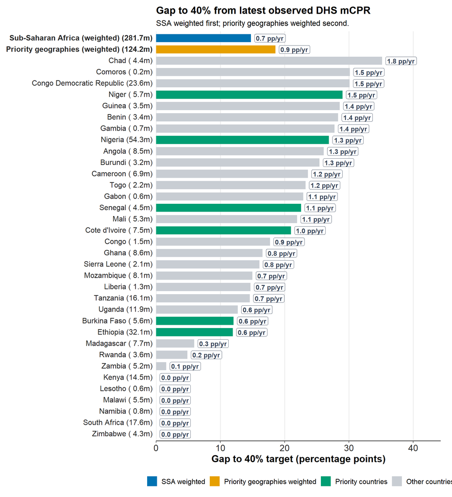

```r
ggplot(
  ssa_goal_final_gap_lastobs,
  aes(x = gap_from_lastobs_pp, y = geography_label_plot, fill = goal_fill_group)
) +
  geom_col(width = 0.72) +
  geom_label(
    aes(
      x = gap_from_lastobs_pp + 0.55,
      label = growth_label
    ),
    hjust = 0,
    size = 3.75,
    fontface = "bold",
    color = "#334155",
    fill = scales::alpha("white", 0.96),
    label.size = 0.18,
    label.padding = grid::unit(0.18, "lines")
  ) +
  scale_fill_manual(
    values = ssa_goal_final_focus_group_cols,
    breaks = ssa_goal_final_focus_group_levels
  ) +
  scale_x_continuous(
    expand = expansion(mult = c(0, 0.24))
  ) +
  scale_y_discrete(labels = priority_focus_weighted_axis_labels) +
  theme_minimal(base_size = 12.8) +
  theme(
    legend.position = "bottom",
    legend.title = element_blank(),
    panel.grid.minor = element_blank(),
    panel.grid.major.y = element_blank(),
    axis.line.x = element_line(color = "grey25", linewidth = 0.55),
    axis.ticks.x = element_line(color = "grey25", linewidth = 0.5),
    axis.text.x = element_text(size = 13.8, color = "grey15"),
    axis.text.y = element_text(size = 11.9, color = "grey15"),
    axis.title = element_text(size = 15.4, face = "bold"),
    legend.text = element_text(size = 11.2),
    plot.title = element_text(size = 16.2, face = "bold"),
    plot.subtitle = element_text(size = 12.4, lineheight = 1.02),
    plot.margin = margin(10, 18, 10, 10)
  ) +
  labs(
    title = "Gap to 40% from latest observed DHS mCPR",
    subtitle = "SSA weighted first; priority geographies weighted second.",
    x = "Gap to 40% target (percentage points)",
    y = NULL
  )
```

### 24.20.4 Gap to 40% from model-estimated mCPR(2025)

This version puts every country and the weighted SSA region on the same calendar footing by starting from `p(2025)`.

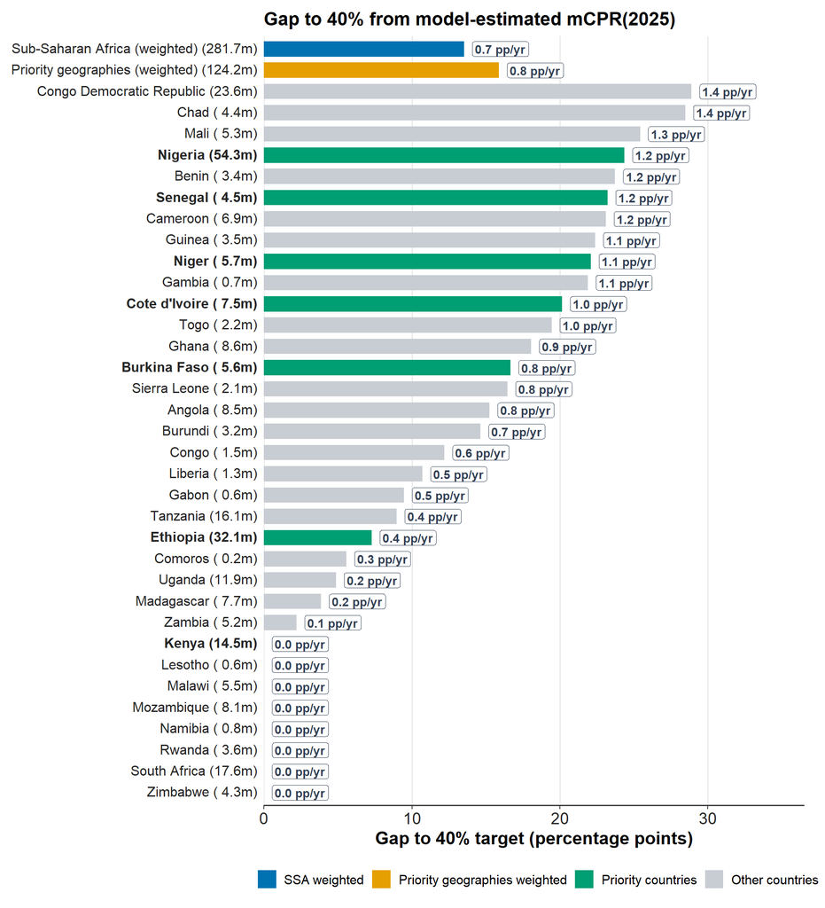

```r
ggplot(
  ssa_goal_final_gap_p2025,
  aes(x = gap_from_p2025_pp, y = geography_label_plot, fill = goal_fill_group)
) +
  geom_col(width = 0.72) +
  geom_label(
    aes(
      x = gap_from_p2025_pp + 0.55,
      label = growth_label
    ),
    hjust = 0,
    size = 3.75,
    fontface = "bold",
    color = "#334155",
    fill = scales::alpha("white", 0.96),
    label.size = 0.18,
    label.padding = grid::unit(0.18, "lines")
  ) +
  scale_fill_manual(
    values = ssa_goal_final_focus_group_cols,
    breaks = ssa_goal_final_focus_group_levels
  ) +
  scale_x_continuous(
    expand = expansion(mult = c(0, 0.24))
  ) +
  scale_y_discrete(labels = priority_country_axis_labels) +
  theme_minimal(base_size = 12.8) +
  theme(
    legend.position = "bottom",
    legend.title = element_blank(),
    panel.grid.minor = element_blank(),
    panel.grid.major.y = element_blank(),
    axis.line.x = element_line(color = "grey25", linewidth = 0.55),
    axis.ticks.x = element_line(color = "grey25", linewidth = 0.5),
    axis.text.x = element_text(size = 13.8, color = "grey15"),
    axis.text.y = element_text(size = 11.9, color = "grey15"),
    axis.title = element_text(size = 15.4, face = "bold"),
    legend.text = element_text(size = 11.2),
    plot.title = element_text(size = 16.2, face = "bold"),
    plot.subtitle = element_text(size = 12.4, lineheight = 1.02),
    plot.margin = margin(10, 18, 10, 10)
  ) +
  labs(
    title = "Gap to 40% from model-estimated mCPR(2025)",
    subtitle = NULL,
    x = "Gap to 40% target (percentage points)",
    y = NULL
  )
```

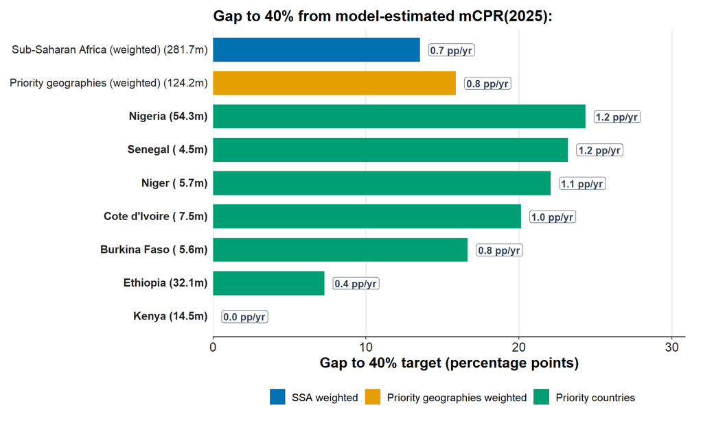

```r
ggplot(
  ssa_goal_final_gap_p2025_priority_focus,
  aes(x = gap_from_p2025_pp, y = geography_label_plot, fill = goal_fill_group)
) +
  geom_col(width = 0.72) +
  geom_label(
    aes(
      x = gap_from_p2025_pp + 0.55,
      label = growth_label
    ),
    hjust = 0,
    size = 3.6,
    fontface = "bold",
    color = "#334155",
    fill = scales::alpha("white", 0.96),
    label.size = 0.18,
    label.padding = grid::unit(0.16, "lines")
  ) +
  scale_fill_manual(
    values = ssa_goal_final_focus_group_cols,
    breaks = ssa_goal_final_focus_group_levels
  ) +
  scale_x_continuous(
    expand = expansion(mult = c(0, 0.24))
  ) +
  scale_y_discrete(labels = priority_country_axis_labels) +
  theme_minimal(base_size = 12.3) +
  theme(
    legend.position = "bottom",
    legend.title = element_blank(),
    panel.grid.minor = element_blank(),
    panel.grid.major.y = element_blank(),
    axis.line.x = element_line(color = "grey25", linewidth = 0.55),
    axis.ticks.x = element_line(color = "grey25", linewidth = 0.5),
    axis.text.x = element_text(size = 13.0, color = "grey15"),
    axis.text.y = element_text(size = 11.4, color = "grey15"),
    axis.title = element_text(size = 14.6, face = "bold"),
    legend.text = element_text(size = 10.8),
    plot.title = element_text(size = 15.2, face = "bold"),
    plot.subtitle = element_text(size = 11.9, lineheight = 1.02),
    plot.margin = margin(10, 18, 10, 10)
  ) +
  labs(
    title = "Gap to 40% from model-estimated mCPR(2025):",
    subtitle = NULL,
    x = "Gap to 40% target (percentage points)",
    y = NULL
  )
```

### 24.20.5 Growth-rate tables

These tables separate the three growth concepts used in the goals discussion so they are easier to compare without mixing observed and model-based quantities.

Interpretation: a) `Table 1` is purely observed and shows the annualized growth rate between each pair of DHS surveys for each SSA country; b) `Table 2` is purely model-based and shows the instantaneous annual growth rate by country and calendar year through `2025`; c) `Table 3` is also model-based and shows the projected year-to-year annualized growth rate over each one-year interval from `2025-2026` through `2044-2045`; d) the section then repeats those three table types for the weighted SSA region only and for the weighted priority geographies subgroup only; e) all model-based growth values are shown in `pp/year`; f) a value of `0.5` means `0.5 percentage points per year`, not `50%` growth.

```r
ssa_goal_final_survey_to_survey_growth <- ssa_obs_growth_intervals %>%
  arrange(factor(region, levels = ssa_regions), country, prev_year, year) %>%
  transmute(
    Region = region,
    Country = country,
    `Survey Interval` = paste0(prev_year, "-", year),
    `Interval Length (years)` = year - prev_year,
    `Start mCPR (%)` = round(100 * prev_mcpr, 1),
    `End mCPR (%)` = round(100 * mCPR, 1),
    `Observed Annualized Growth (pp/year)` = round(100 * obs_growth_annual, 1)
  )

ssa_goal_final_model_growth_history <- country_growth_rate_table %>%
  filter(country %in% ssa_country_order_vec, year <= 2025) %>%
  left_join(
    ssa_goal_final_country_rows %>%
      select(geography, last_obs_year),
    by = c("country" = "geography")
  ) %>%
  arrange(factor(region, levels = ssa_regions), country, year) %>%
  transmute(
    Region = region,
    Country = country,
    Year = year,
    Window = if_else(
      year <= last_obs_year,
      "Within observed DHS window",
      "Model-only year before 2025"
    ),
    `Model Instantaneous Annualized Growth (pp/year)` = round(100 * dpdt_mean, 1),
    `95% CrI (pp/year)` = paste0(
      format(round(100 * dpdt_p05, 1), nsmall = 1),
      " to ",
      format(round(100 * dpdt_p95, 1), nsmall = 1)
    )
  )

ssa_goal_final_projected_growth_2025_2045 <- bind_rows(
  lapply(ssa_goal_final_base_year:(ssa_goal_final_target_year - 1), function(start_year) {
    p_start_draws <- logistic_draws_at_year(ssa_K_draws, ssa_t0_draws, ssa_s_draws, start_year)
    p_end_draws <- logistic_draws_at_year(ssa_K_draws, ssa_t0_draws, ssa_s_draws, start_year + 1)
    growth_draws <- 100 * (p_end_draws - p_start_draws)

    tibble(
      country = ssa_country_order_vec,
      `Projection Interval` = paste0(start_year, "-", start_year + 1),
      `Start Year` = start_year,
      `End Year` = start_year + 1,
      p_start_pct = 100 * colMeans(p_start_draws),
      p_end_pct = 100 * colMeans(p_end_draws),
      growth_pp_per_year = colMeans(growth_draws),
      growth_p05 = apply(growth_draws, 2, quantile, ci_lower),
      growth_p95 = apply(growth_draws, 2, quantile, ci_upper)
    )
  })
) %>%
  left_join(
    ssa_goal_final_country_rows %>%
      select(geography, region),
    by = c("country" = "geography")
  ) %>%
  arrange(
    factor(region, levels = ssa_regions),
    country,
    `Start Year`
  ) %>%
  transmute(
    Region = region,
    Country = country,
    `Projection Interval`,
    `Start Year`,
    `End Year`,
    `p(Start Year) (%)` = round(p_start_pct, 1),
    `p(End Year) (%)` = round(p_end_pct, 1),
    `Model-Projected Annualized Growth (pp/year)` = round(growth_pp_per_year, 1),
    `95% CrI (pp/year)` = paste0(
      format(round(growth_p05, 1), nsmall = 1),
      " to ",
      format(round(growth_p95, 1), nsmall = 1)
    )
  )

build_weighted_observed_interval_table <- function(observed_df, geography_label) {
  observed_df %>%
    arrange(year) %>%
    mutate(
      prev_year = lag(year),
      prev_mcpr = lag(observed_weighted_mcpr)
    ) %>%
    filter(!is.na(prev_year), year > prev_year) %>%
    transmute(
      Geography = geography_label,
      `Observed Interval` = paste0(prev_year, "-", year),
      `Interval Length (years)` = year - prev_year,
      `Start mCPR (%)` = round(100 * prev_mcpr, 1),
      `End mCPR (%)` = round(100 * observed_weighted_mcpr, 1),
      `Observed Annualized Growth (pp/year)` = round(
        100 * (observed_weighted_mcpr - prev_mcpr) / (year - prev_year),
        1
      )
    )
}

build_weighted_model_growth_history_table <- function(country_names, geography_label) {
  year_seq <- seq(
    min(mcpr_logistic_data$year[mcpr_logistic_data$country %in% country_names], na.rm = TRUE),
    2025,
    by = 1
  )
  growth_draws <- sapply(year_seq, function(yy) {
    weighted_country_dpdt_draws_at_year(country_names, yy)
  })
  if (is.vector(growth_draws)) {
    growth_draws <- matrix(growth_draws, nrow = length(growth_draws), ncol = 1)
  }
  tibble(
    Geography = geography_label,
    Year = year_seq,
    `Model Instantaneous Annualized Growth (pp/year)` = round(100 * colMeans(growth_draws), 1),
    `95% CrI (pp/year)` = paste0(
      format(round(100 * apply(growth_draws, 2, quantile, ci_lower), 1), nsmall = 1),
      " to ",
      format(round(100 * apply(growth_draws, 2, quantile, ci_upper), 1), nsmall = 1)
    )
  )
}

build_weighted_projected_growth_table <- function(country_names, geography_label) {
  bind_rows(
    lapply(ssa_goal_final_base_year:(ssa_goal_final_target_year - 1), function(start_year) {
      p_start_draws <- weighted_country_draws_at_year(country_names, start_year)
      p_end_draws <- weighted_country_draws_at_year(country_names, start_year + 1)
      growth_draws <- 100 * (p_end_draws - p_start_draws)
      tibble(
        Geography = geography_label,
        `Projection Interval` = paste0(start_year, "-", start_year + 1),
        `Start Year` = start_year,
        `End Year` = start_year + 1,
        `p(Start Year) (%)` = round(100 * mean(p_start_draws), 1),
        `p(End Year) (%)` = round(100 * mean(p_end_draws), 1),
        `Model-Projected Annualized Growth (pp/year)` = round(mean(growth_draws), 1),
        `95% CrI (pp/year)` = paste0(
          format(round(quantile(growth_draws, ci_lower), 1), nsmall = 1),
          " to ",
          format(round(quantile(growth_draws, ci_upper), 1), nsmall = 1)
        )
      )
    })
  )
}

ssa_goal_final_priority_observed_weighted <- mcpr_logistic_data %>%
  filter(region %in% ssa_regions, country %in% ssa_goal_final_priority_geographies) %>%
  inner_join(
    ssa_pop_weights_model %>%
      filter(country %in% ssa_goal_final_priority_geographies) %>%
      select(country, Year, women_15_49),
    by = c("country", "year" = "Year")
  ) %>%
  group_by(year) %>%
  summarise(
    observed_weighted_mcpr = weighted.mean(mCPR, women_15_49, na.rm = TRUE),
    .groups = "drop"
  )

ssa_goal_final_growth_region_observed <- build_weighted_observed_interval_table(
  ssa_observed_weighted,
  "Sub-Saharan Africa (weighted)"
)

ssa_goal_final_growth_region_model_history <- build_weighted_model_growth_history_table(
  ssa_country_order_vec,
  "Sub-Saharan Africa (weighted)"
)

ssa_goal_final_growth_region_projected <- build_weighted_projected_growth_table(
  ssa_country_order_vec,
  "Sub-Saharan Africa (weighted)"
)

ssa_goal_final_growth_priority_observed <- build_weighted_observed_interval_table(
  ssa_goal_final_priority_observed_weighted,
  ssa_goal_final_priority_label
)

ssa_goal_final_growth_priority_model_history <- build_weighted_model_growth_history_table(
  ssa_goal_final_priority_geographies,
  ssa_goal_final_priority_label
)

ssa_goal_final_growth_priority_projected <- build_weighted_projected_growth_table(
  ssa_goal_final_priority_geographies,
  ssa_goal_final_priority_label
)
```

#### 24.20.5.1 Observed survey-to-survey annualized growth rates

Each row is one observed DHS survey interval for one SSA country.

```r
rmarkdown::paged_table(
  ssa_goal_final_survey_to_survey_growth
)
```

| Region | Country | Survey Interval | Interval Length (years) | Start mCPR (%) | End mCPR (%) | Observed Annualized Growth (pp/year) |
| --- | --- | --- | --- | --- | --- | --- |
| West Africa | Benin | 1996-2001 | 5 | 3.4 | 7.0 | 0.7 |
| West Africa | Benin | 2001-2006 | 5 | 7.0 | 6.9 | 0.0 |
| West Africa | Benin | 2006-2012 | 6 | 6.9 | 9.0 | 0.4 |
| West Africa | Benin | 2012-2017 | 5 | 9.0 | 11.7 | 0.5 |
| West Africa | Burkina Faso | 1993-1999 | 6 | 4.0 | 5.8 | 0.3 |
| West Africa | Burkina Faso | 1999-2003 | 4 | 5.8 | 9.8 | 1.0 |
| West Africa | Burkina Faso | 2003-2010 | 7 | 9.8 | 14.3 | 0.6 |
| West Africa | Burkina Faso | 2010-2021 | 11 | 14.3 | 27.9 | 1.2 |
| West Africa | Cote d'Ivoire | 1994-1998 | 4 | 5.7 | 9.8 | 1.0 |
| West Africa | Cote d'Ivoire | 1998-2012 | 14 | 9.8 | 13.9 | 0.3 |

[output cut: 115 more lines]

#### 24.20.5.2 Model instantaneous annualized growth rates by country and year

These are the fitted first-derivative values from the model through `2025`, expressed in `pp/year`.

```r
rmarkdown::paged_table(
  ssa_goal_final_model_growth_history
)
```

| Region | Country | Year | Window | Model Instantaneous Annualized Growth (pp/year) | 95% CrI (pp/year) |
| --- | --- | --- | --- | --- | --- |
| West Africa | Benin | 1996 | Within observed DHS window | 0.2 | 0.1 to 0.5 |
| West Africa | Benin | 1997 | Within observed DHS window | 0.3 | 0.1 to 0.5 |
| West Africa | Benin | 1998 | Within observed DHS window | 0.3 | 0.1 to 0.5 |
| West Africa | Benin | 1999 | Within observed DHS window | 0.3 | 0.1 to 0.6 |
| West Africa | Benin | 2000 | Within observed DHS window | 0.3 | 0.1 to 0.6 |
| West Africa | Benin | 2001 | Within observed DHS window | 0.3 | 0.1 to 0.6 |
| West Africa | Benin | 2002 | Within observed DHS window | 0.3 | 0.1 to 0.6 |
| West Africa | Benin | 2003 | Within observed DHS window | 0.3 | 0.2 to 0.7 |
| West Africa | Benin | 2004 | Within observed DHS window | 0.4 | 0.2 to 0.7 |
| West Africa | Benin | 2005 | Within observed DHS window | 0.4 | 0.2 to 0.7 |

[output cut: 1013 more lines]

#### 24.20.5.3 Model-projected annualized growth rates from 2025 to 2045

These values show the fitted one-year projected annualized growth rates from `2025-2026` through `2044-2045`, in `pp/year`.

```r
rmarkdown::paged_table(
  ssa_goal_final_projected_growth_2025_2045
)
```

| Region | Country | Projection Interval | Start Year | End Year | p(Start Year) (%) | p(End Year) (%) | Model-Projected Annualized Growth (pp/year) | 95% CrI (pp/year) |
| --- | --- | --- | --- | --- | --- | --- | --- | --- |
| West Africa | Benin | 2025-2026 | 2025 | 2026 | 16.3 | 16.8 | 0.5 | 0.2 to 1.1 |
| West Africa | Benin | 2026-2027 | 2026 | 2027 | 16.8 | 17.3 | 0.5 | 0.2 to 1.1 |
| West Africa | Benin | 2027-2028 | 2027 | 2028 | 17.3 | 17.8 | 0.5 | 0.2 to 1.1 |
| West Africa | Benin | 2028-2029 | 2028 | 2029 | 17.8 | 18.3 | 0.5 | 0.2 to 1.1 |
| West Africa | Benin | 2029-2030 | 2029 | 2030 | 18.3 | 18.8 | 0.5 | 0.2 to 1.1 |
| West Africa | Benin | 2030-2031 | 2030 | 2031 | 18.8 | 19.2 | 0.5 | 0.2 to 1.1 |
| West Africa | Benin | 2031-2032 | 2031 | 2032 | 19.2 | 19.7 | 0.5 | 0.2 to 1.1 |
| West Africa | Benin | 2032-2033 | 2032 | 2033 | 19.7 | 20.2 | 0.5 | 0.2 to 1.0 |
| West Africa | Benin | 2033-2034 | 2033 | 2034 | 20.2 | 20.6 | 0.5 | 0.1 to 1.0 |
| West Africa | Benin | 2034-2035 | 2034 | 2035 | 20.6 | 21.1 | 0.4 | 0.1 to 1.0 |

[output cut: 670 more lines]

#### 24.20.5.4 Weighted SSA region only: observed survey-to-survey annualized growth

```r
rmarkdown::paged_table(
  ssa_goal_final_growth_region_observed
)
```

| Geography | Observed Interval | Interval Length (years) | Start mCPR (%) | End mCPR (%) | Observed Annualized Growth (pp/year) |
| --- | --- | --- | --- | --- | --- |
| Sub-Saharan Africa (weighted) | 1986-1987 | 1 | 3.8 | 1.2 | -2.6 |
| Sub-Saharan Africa (weighted) | 1987-1988 | 1 | 1.2 | 8.7 | 7.6 |
| Sub-Saharan Africa (weighted) | 1988-1989 | 1 | 8.7 | 14.7 | 5.9 |
| Sub-Saharan Africa (weighted) | 1989-1990 | 1 | 14.7 | 3.8 | -10.9 |
| Sub-Saharan Africa (weighted) | 1990-1991 | 1 | 3.8 | 4.2 | 0.5 |
| Sub-Saharan Africa (weighted) | 1991-1992 | 1 | 4.2 | 5.8 | 1.6 |
| Sub-Saharan Africa (weighted) | 1992-1993 | 1 | 5.8 | 12.5 | 6.7 |
| Sub-Saharan Africa (weighted) | 1993-1994 | 1 | 12.5 | 16.9 | 4.4 |
| Sub-Saharan Africa (weighted) | 1994-1995 | 1 | 16.9 | 7.4 | -9.5 |
| Sub-Saharan Africa (weighted) | 1995-1996 | 1 | 7.4 | 9.6 | 2.2 |

[output cut: 26 more lines]

#### 24.20.5.5 Weighted SSA region only: model instantaneous annualized growth

```r
rmarkdown::paged_table(
  ssa_goal_final_growth_region_model_history
)
```

| Geography | Year | Model Instantaneous Annualized Growth (pp/year) | 95% CrI (pp/year) |
| --- | --- | --- | --- |
| Sub-Saharan Africa (weighted) | 1986 | 0.3 | 0.3 to 0.4 |
| Sub-Saharan Africa (weighted) | 1987 | 0.3 | 0.3 to 0.4 |
| Sub-Saharan Africa (weighted) | 1988 | 0.4 | 0.3 to 0.4 |
| Sub-Saharan Africa (weighted) | 1989 | 0.4 | 0.3 to 0.5 |
| Sub-Saharan Africa (weighted) | 1990 | 0.4 | 0.3 to 0.5 |
| Sub-Saharan Africa (weighted) | 1991 | 0.4 | 0.4 to 0.5 |
| Sub-Saharan Africa (weighted) | 1992 | 0.5 | 0.4 to 0.6 |
| Sub-Saharan Africa (weighted) | 1993 | 0.5 | 0.4 to 0.6 |
| Sub-Saharan Africa (weighted) | 1994 | 0.5 | 0.4 to 0.6 |
| Sub-Saharan Africa (weighted) | 1995 | 0.5 | 0.4 to 0.6 |

[output cut: 30 more lines]

#### 24.20.5.6 Weighted SSA region only: model-projected annualized growth from 2025 to 2045

```r
rmarkdown::paged_table(
  ssa_goal_final_growth_region_projected
)
```

[output not shown]

[output cut: 10 more lines]

#### 24.20.5.7 Priority geographies only: observed survey-to-survey annualized growth

```r
rmarkdown::paged_table(
  ssa_goal_final_growth_priority_observed
)
```

| Geography | Observed Interval | Interval Length (years) | Start mCPR (%) | End mCPR (%) | Observed Annualized Growth (pp/year) |
| --- | --- | --- | --- | --- | --- |
| Priority geographies (weighted) | 1986-1989 | 3 | 2.7 | 14.7 | 4.0 |
| Priority geographies (weighted) | 1989-1990 | 1 | 14.7 | 3.8 | -10.9 |
| Priority geographies (weighted) | 1990-1992 | 2 | 3.8 | 2.3 | -0.7 |
| Priority geographies (weighted) | 1992-1993 | 1 | 2.3 | 13.8 | 11.5 |
| Priority geographies (weighted) | 1993-1994 | 1 | 13.8 | 5.7 | -8.1 |
| Priority geographies (weighted) | 1994-1997 | 3 | 5.7 | 7.0 | 0.4 |
| Priority geographies (weighted) | 1997-1998 | 1 | 7.0 | 16.0 | 9.0 |
| Priority geographies (weighted) | 1998-1999 | 1 | 16.0 | 5.8 | -10.2 |
| Priority geographies (weighted) | 1999-2000 | 1 | 5.8 | 4.7 | -1.1 |
| Priority geographies (weighted) | 2000-2003 | 3 | 4.7 | 11.6 | 2.3 |

[output cut: 16 more lines]

#### 24.20.5.8 Priority geographies only: model instantaneous annualized growth

```r
rmarkdown::paged_table(
  ssa_goal_final_growth_priority_model_history
)
```

| Geography | Year | Model Instantaneous Annualized Growth (pp/year) | 95% CrI (pp/year) |
| --- | --- | --- | --- |
| Priority geographies (weighted) | 1986 | 0.3 | 0.2 to 0.4 |
| Priority geographies (weighted) | 1987 | 0.3 | 0.2 to 0.4 |
| Priority geographies (weighted) | 1988 | 0.3 | 0.2 to 0.4 |
| Priority geographies (weighted) | 1989 | 0.3 | 0.2 to 0.4 |
| Priority geographies (weighted) | 1990 | 0.3 | 0.2 to 0.5 |
| Priority geographies (weighted) | 1991 | 0.4 | 0.2 to 0.5 |
| Priority geographies (weighted) | 1992 | 0.4 | 0.3 to 0.5 |
| Priority geographies (weighted) | 1993 | 0.4 | 0.3 to 0.5 |
| Priority geographies (weighted) | 1994 | 0.4 | 0.3 to 0.6 |
| Priority geographies (weighted) | 1995 | 0.4 | 0.3 to 0.6 |

[output cut: 30 more lines]

#### 24.20.5.9 Priority geographies only: model-projected annualized growth from 2025 to 2045

```r
rmarkdown::paged_table(
  ssa_goal_final_growth_priority_projected
)
```

| Geography | Projection Interval | Start Year | End Year | p(Start Year) (%) | p(End Year) (%) | Model-Projected Annualized Growth (pp/year) | 95% CrI (pp/year) |
| --- | --- | --- | --- | --- | --- | --- | --- |
| Priority geographies (weighted) | 2025-2026 | 2025 | 2026 | 24.1 | 24.6 | 0.5 | 0.3 to 0.8 |
| Priority geographies (weighted) | 2026-2027 | 2026 | 2027 | 24.6 | 25.1 | 0.5 | 0.3 to 0.8 |
| Priority geographies (weighted) | 2027-2028 | 2027 | 2028 | 25.1 | 25.5 | 0.5 | 0.2 to 0.8 |
| Priority geographies (weighted) | 2028-2029 | 2028 | 2029 | 25.5 | 26.0 | 0.4 | 0.2 to 0.8 |
| Priority geographies (weighted) | 2029-2030 | 2029 | 2030 | 26.0 | 26.4 | 0.4 | 0.2 to 0.7 |
| Priority geographies (weighted) | 2030-2031 | 2030 | 2031 | 26.4 | 26.8 | 0.4 | 0.2 to 0.7 |
| Priority geographies (weighted) | 2031-2032 | 2031 | 2032 | 26.8 | 27.2 | 0.4 | 0.2 to 0.7 |
| Priority geographies (weighted) | 2032-2033 | 2032 | 2033 | 27.2 | 27.6 | 0.4 | 0.2 to 0.7 |
| Priority geographies (weighted) | 2033-2034 | 2033 | 2034 | 27.6 | 27.9 | 0.4 | 0.2 to 0.7 |
| Priority geographies (weighted) | 2034-2035 | 2034 | 2035 | 27.9 | 28.3 | 0.3 | 0.2 to 0.6 |

[output cut: 10 more lines]

### 24.20.6 Is the required annualized growth rate realistic?

This comparison keeps the required annualized growth rate on a common 2025 to 2045 footing and places it beside three benchmarks: a) the latest observed annualized inter-survey growth; b) the model-implied annual growth at 2025; c) the average model-projected annual growth from 2025 to 2045.

### 24.20.7 mCPR(2025) versus fitted K

This asymptote-style check keeps the focus on current modeled position versus the fitted ceiling.

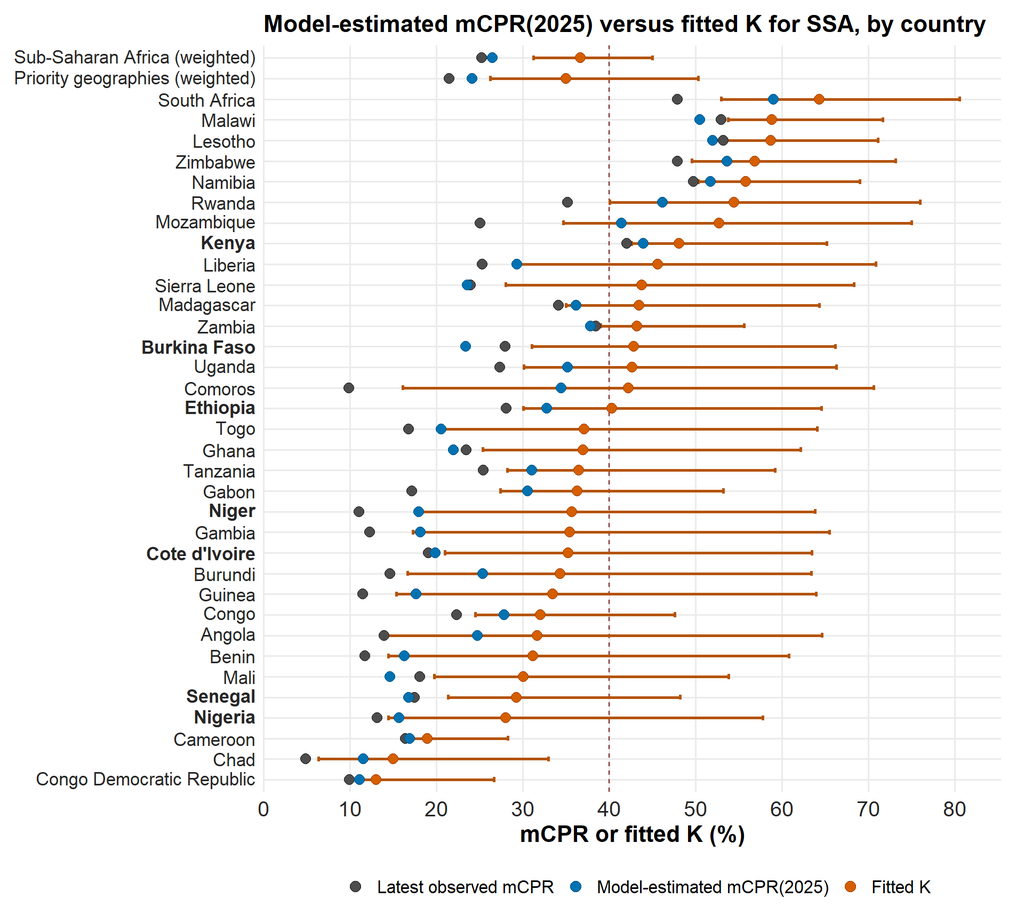

```r
ggplot(ssa_goal_final_asymptote_p2025, aes(y = geography_plot)) +
  geom_vline(
    xintercept = 40,
    linetype = "dashed",
    color = "#7F1D1D",
    linewidth = 0.5
  ) +
  geom_errorbarh(
    aes(
      xmin = K_p05_pct,
      xmax = K_p95_pct
    ),
    height = 0.24,
    linewidth = 0.95,
    color = "#B45309"
  ) +
  geom_point(
    aes(
      x = current_latest_obs_plot_pct,
      fill = "Latest observed mCPR"
    ),
    shape = 21,
    size = 3.25,
    color = ssa_goal_final_asymptote_outline_cols["Latest observed mCPR"],
    stroke = 0.45
  ) +
  geom_point(
    aes(
      x = current_p2025_pct,
      fill = "Model-estimated mCPR(2025)"
    ),
    size = 3.25,
    color = ssa_goal_final_asymptote_outline_cols["Model-estimated mCPR(2025)"],
    stroke = 0.45,
    shape = 21
  ) +
  geom_point(
    aes(
      x = K_mean_pct,
      fill = "Fitted K"
    ),
    shape = 21,
    size = 3.25,
    color = ssa_goal_final_asymptote_outline_cols["Fitted K"],
    stroke = 0.45
  ) +
  scale_fill_manual(
    values = ssa_goal_final_asymptote_fill_cols,
    breaks = c("Latest observed mCPR", "Model-estimated mCPR(2025)", "Fitted K")
  ) +
  scale_y_discrete(labels = priority_country_axis_labels) +
  scale_x_continuous(
    limits = c(
      0,
      max(ssa_goal_final_asymptote_p2025$K_p95_pct, na.rm = TRUE) + 4
    ),
    breaks = function(x) sort(unique(c(pretty(x, n = 7), 40))),
    expand = expansion(mult = c(0, 0.01))
  ) +
  theme_minimal(base_size = 12.9) +
  theme(
    legend.position = "bottom",
    legend.title = element_blank(),
    panel.grid.minor = element_blank(),
    axis.text.x = element_text(size = 14.6, color = "grey15"),
    axis.text.y = element_text(size = 12.6, color = "grey15"),
    axis.title = element_text(size = 16.0, face = "bold"),
    legend.text = element_text(size = 12.5),
    plot.title = element_text(size = 16.4, face = "bold"),
    plot.margin = margin(10, 16, 10, 10)
  ) +
  guides(
    fill = guide_legend(
      nrow = 1,
      byrow = TRUE,
      override.aes = list(
        shape = c(21, 21, 21),
        color = unname(ssa_goal_final_asymptote_outline_cols[c(
          "Latest observed mCPR",
          "Model-estimated mCPR(2025)",
          "Fitted K"
        )]),
        size = c(3.35, 3.35, 3.35),
        stroke = c(0.45, 0.45, 0.45)
      )
    )
  ) +
  coord_cartesian(clip = "off") +
  labs(
    title = "Model-estimated mCPR(2025) versus fitted K for SSA, by country",
    x = "mCPR or fitted K (%)",
    y = NULL
  )
```

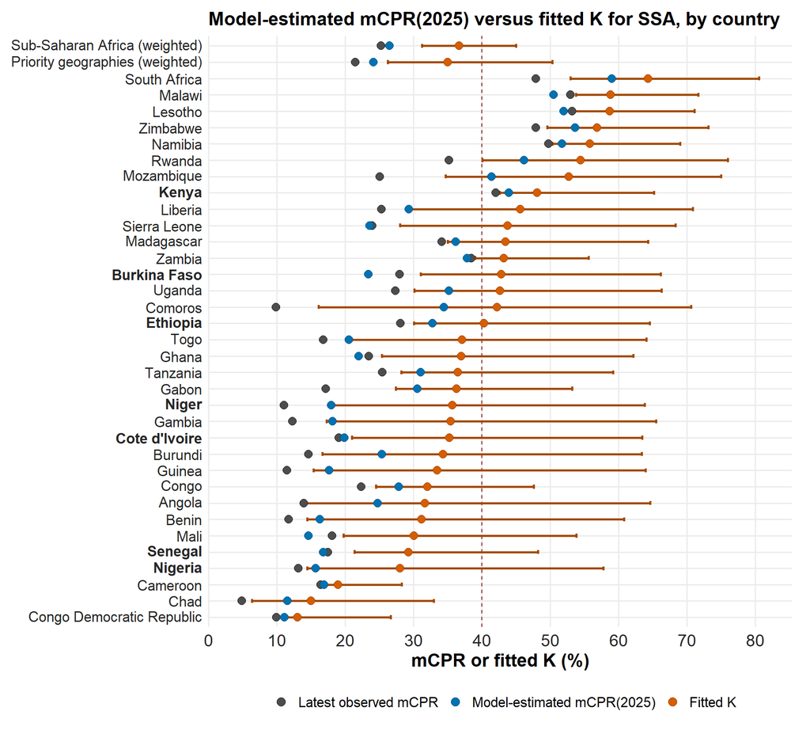

```r
ggplot(ssa_goal_final_asymptote_p2025, aes(y = geography_plot)) +
  geom_vline(
    xintercept = 40,
    linetype = "dashed",
    color = "#7F1D1D",
    linewidth = 0.5
  ) +
  geom_errorbarh(
    aes(
      xmin = K_p05_pct,
      xmax = K_p95_pct
    ),
    height = 0.24,
    linewidth = 0.95,
    color = "#A34A00"
  ) +
  geom_point(
    aes(
      x = current_latest_obs_plot_pct,
      fill = "Latest observed mCPR"
    ),
    shape = 21,
    size = 3.25,
    color = ssa_goal_final_asymptote_outline_cols_cb["Latest observed mCPR"],
    stroke = 0.45
  ) +
  geom_point(
    aes(
      x = current_p2025_pct,
      fill = "Model-estimated mCPR(2025)"
    ),
    size = 3.25,
    color = ssa_goal_final_asymptote_outline_cols_cb["Model-estimated mCPR(2025)"],
    stroke = 0.45,
    shape = 21
  ) +
  geom_point(
    aes(
      x = K_mean_pct,
      fill = "Fitted K"
    ),
    shape = 21,
    size = 3.25,
    color = ssa_goal_final_asymptote_outline_cols_cb["Fitted K"],
    stroke = 0.45
  ) +
  scale_fill_manual(
    values = ssa_goal_final_asymptote_fill_cols_cb,
    breaks = c("Latest observed mCPR", "Model-estimated mCPR(2025)", "Fitted K")
  ) +
  scale_y_discrete(labels = priority_country_axis_labels) +
  scale_x_continuous(
    limits = c(
      0,
      max(ssa_goal_final_asymptote_p2025$K_p95_pct, na.rm = TRUE) + 4
    ),
    breaks = function(x) sort(unique(c(pretty(x, n = 7), 40))),
    expand = expansion(mult = c(0, 0.01))
  ) +
  theme_minimal(base_size = 12.9) +
  theme(
    legend.position = "bottom",
    legend.title = element_blank(),
    panel.grid.minor = element_blank(),
    axis.text.x = element_text(size = 14.6, color = "grey15"),
    axis.text.y = element_text(size = 12.6, color = "grey15"),
    axis.title = element_text(size = 16.0, face = "bold"),
    legend.text = element_text(size = 12.5),
    plot.title = element_text(size = 16.4, face = "bold"),
    plot.margin = margin(10, 16, 10, 10)
  ) +
  guides(
    fill = guide_legend(
      nrow = 1,
      byrow = TRUE,
      override.aes = list(
        shape = c(21, 21, 21),
        color = unname(ssa_goal_final_asymptote_outline_cols_cb[c(
          "Latest observed mCPR",
          "Model-estimated mCPR(2025)",
          "Fitted K"
        )]),
        size = c(3.35, 3.35, 3.35),
        stroke = c(0.45, 0.45, 0.45)
      )
    )
  ) +
  coord_cartesian(clip = "off") +
  labs(
    title = "Model-estimated mCPR(2025) versus fitted K for SSA, by country",
    x = "mCPR or fitted K (%)",
    y = NULL
  )
```

[figure not shown]

```r
ggplot(
  ssa_goal_final_pace_long,
  aes(
    x = growth_pp_per_year,
    y = geography_label_plot,
    color = growth_metric
  )
) +
  geom_segment(
    data = ssa_goal_final_pace_range,
    aes(
      x = x_min,
      xend = x_max,
      y = geography_label_plot,
      yend = geography_label_plot
    ),
    inherit.aes = FALSE,
    color = "grey80",
    linewidth = 0.55
) +
  geom_point(size = 2.7, stroke = 0.35) +
  scale_y_discrete(labels = priority_country_axis_labels) +
  scale_color_manual(
    values = setNames(
      c("#B91C1C", "#111827", "#2563EB", "#059669"),
      levels(ssa_goal_final_pace_long$growth_metric)
    ),
    guide = guide_legend(nrow = 2, ncol = 2, byrow = TRUE)
  ) +
  theme_minimal(base_size = 10.4) +
  theme(
    legend.position = "bottom",
    legend.title = element_blank(),
    panel.grid.minor = element_blank(),
    axis.text.x = element_text(size = 15.0, color = "black"),
    axis.text.y = element_text(size = 13.4, color = "black"),
    axis.title = element_text(size = 16.2, face = "bold", color = "black"),
    legend.text = element_text(size = 12.2, lineheight = 0.98, color = "black"),
    legend.key.width = unit(1.1, "lines"),
    plot.title = element_text(size = 16.4, face = "bold", color = "black"),
    plot.margin = margin(10, 25, 10, 10)
  ) +
  labs(
    title = "Required annualized growth rate\nversus observed and model-based growth benchmarks",
    x = "Annual growth in mCPR (percentage points per year)",
    y = NULL
  )
```

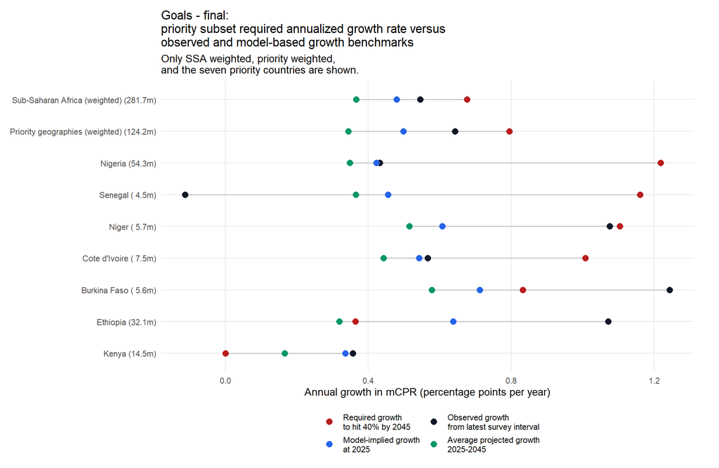

```r
ggplot(
  ssa_goal_final_pace_focus_long,
  aes(
    x = growth_pp_per_year,
    y = geography_label_plot,
    color = growth_metric
  )
) +
  geom_segment(
    data = ssa_goal_final_pace_focus_range,
    aes(
      x = x_min,
      xend = x_max,
      y = geography_label_plot,
      yend = geography_label_plot
    ),
    inherit.aes = FALSE,
    color = "grey80",
    linewidth = 0.55
  ) +
  geom_point(size = 2.8, stroke = 0.35) +
  scale_color_manual(
    values = setNames(
      c("#B91C1C", "#111827", "#2563EB", "#059669"),
      c(
        paste0("Required growth\nto hit 40% by ", ssa_goal_final_target_year),
        "Observed growth\nfrom latest survey interval",
        "Model-implied growth\nat 2025",
        paste0("Average projected growth\n2025-", ssa_goal_final_target_year)
      )
    ),
    guide = guide_legend(nrow = 2, byrow = TRUE)
  ) +
  theme_minimal(base_size = 10.4) +
  theme(
    legend.position = "bottom",
    legend.title = element_blank(),
    panel.grid.minor = element_blank(),
    legend.text = element_text(lineheight = 0.92),
    plot.margin = margin(10, 25, 10, 10)
  ) +
  labs(
    title = "Goals - final:\npriority subset required annualized growth rate versus\nobserved and model-based growth benchmarks",
    subtitle = "Only SSA weighted, priority weighted,\nand the seven priority countries are shown.",
    x = "Annual growth in mCPR (percentage points per year)",
    y = NULL
  )
```

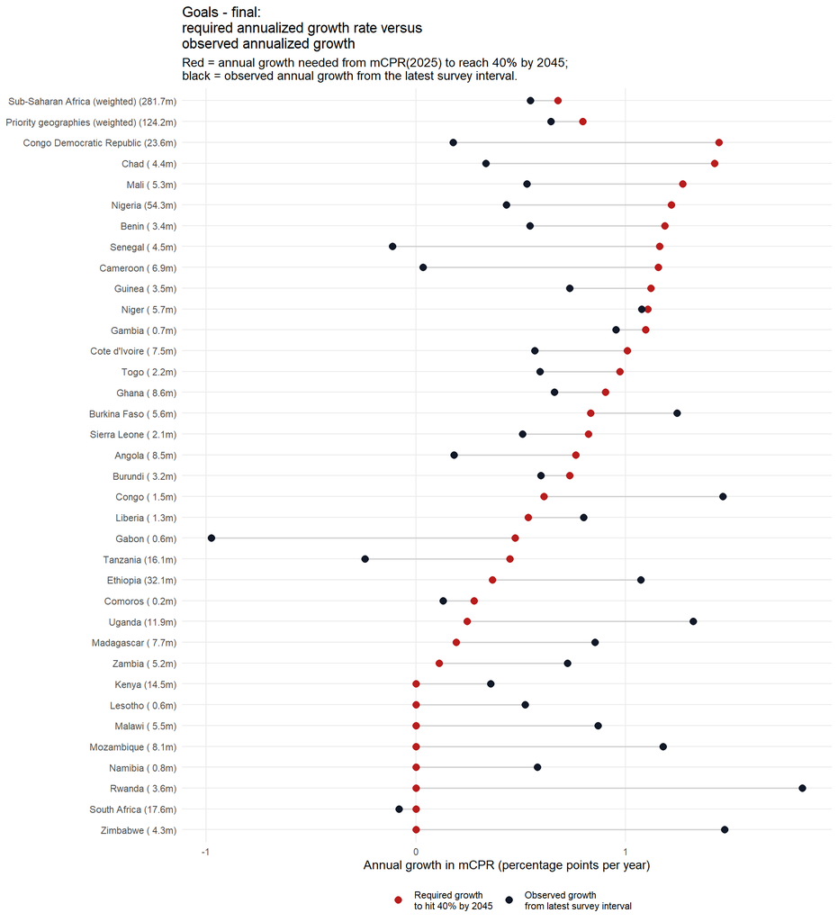

```r
ggplot(
  ssa_goal_final_required_vs_observed_long,
  aes(
    x = growth_pp_per_year,
    y = geography_label_plot,
    color = growth_metric
  )
) +
  geom_segment(
    data = ssa_goal_final_required_vs_observed_range,
    aes(
      x = x_min,
      xend = x_max,
      y = geography_label_plot,
      yend = geography_label_plot
    ),
    inherit.aes = FALSE,
    color = "grey82",
    linewidth = 0.55
  ) +
  geom_point(size = 2.8, stroke = 0.3) +
  scale_color_manual(
    values = setNames(
      c("#B91C1C", "#111827"),
      c(
        paste0("Required growth\nto hit 40% by ", ssa_goal_final_target_year),
        "Observed growth\nfrom latest survey interval"
      )
    ),
    guide = guide_legend(nrow = 1, byrow = TRUE)
  ) +
  theme_minimal(base_size = 10.4) +
  theme(
    legend.position = "bottom",
    legend.title = element_blank(),
    panel.grid.minor = element_blank(),
    legend.text = element_text(lineheight = 0.92)
  ) +
  labs(
    title = "Goals - final:\nrequired annualized growth rate versus\nobserved annualized growth",
    subtitle = paste0(
      "Red = annual growth needed from mCPR(2025) to reach 40% by ",
      ssa_goal_final_target_year, ";\nblack = observed annual growth from the latest survey interval."
    ),
    x = "Annual growth in mCPR (percentage points per year)",
    y = NULL
  )
```

### 24.20.8 Required annualized growth rate versus model-implied current annualized growth rate

This is the cleanest single-view feasibility graph for the 40% target.

Interpretation: a) the x-axis is the annual growth required to move from `p(2025)` to 40% by 2045; b) the y-axis is the model-implied annual growth rate at `2025`; c) the dotted 45-degree line is the diagonal reference line; d) points above the dotted line are outperforming the annualized growth rate needed to reach 40% by 2045 under the current fitted trajectory; e) points below the dotted line would need acceleration relative to the model-implied current annualized growth rate; f) red points have fitted `K` mostly below 40%, so even fast current growth does not by itself solve the ceiling problem.

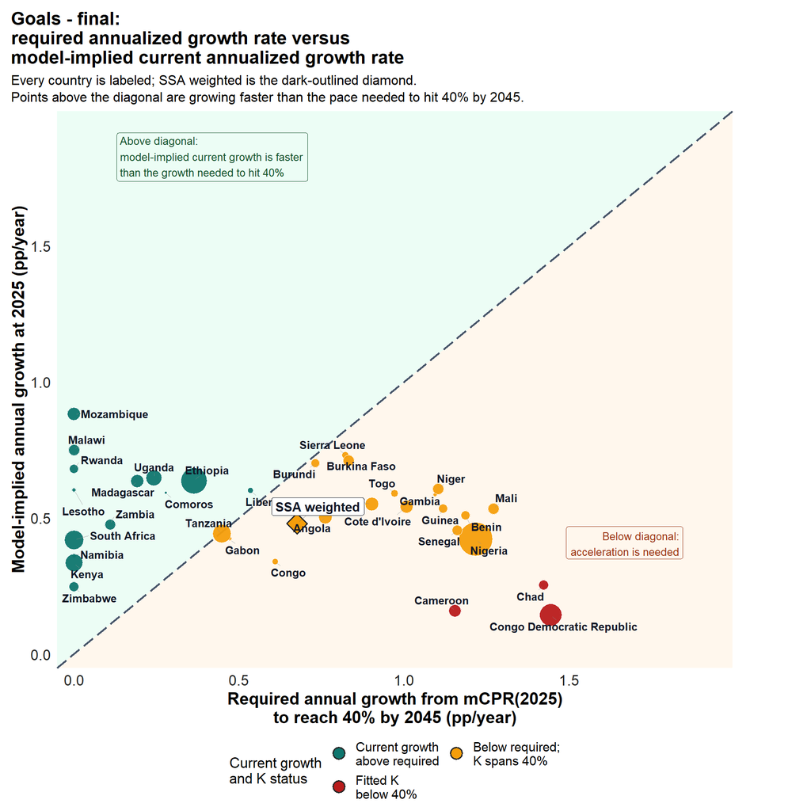

```r
ssa_goal_final_feasibility_limits <- range(
  c(
    ssa_goal_final_feasibility$required_growth_from_p2025_pp_per_year,
    ssa_goal_final_feasibility$model_dpdt_2025_pp_per_year,
    ssa_goal_final_region_feasibility$required_growth_from_p2025_pp_per_year,
    ssa_goal_final_region_feasibility$model_dpdt_2025_pp_per_year
  ),
  na.rm = TRUE
)
ssa_goal_final_feasibility_limits[1] <- min(0, ssa_goal_final_feasibility_limits[1]) - 0.05
ssa_goal_final_feasibility_limits[2] <- ssa_goal_final_feasibility_limits[2] + 0.55

ssa_goal_final_feasibility_zone_above <- tibble(
  x = c(
    ssa_goal_final_feasibility_limits[1],
    ssa_goal_final_feasibility_limits[1],
    ssa_goal_final_feasibility_limits[2]
  ),
  y = c(
    ssa_goal_final_feasibility_limits[1],
    ssa_goal_final_feasibility_limits[2],
    ssa_goal_final_feasibility_limits[2]
  )
)

ssa_goal_final_feasibility_zone_below <- tibble(
  x = c(
    ssa_goal_final_feasibility_limits[1],
    ssa_goal_final_feasibility_limits[2],
    ssa_goal_final_feasibility_limits[2]
  ),
  y = c(
    ssa_goal_final_feasibility_limits[1],
    ssa_goal_final_feasibility_limits[1],
    ssa_goal_final_feasibility_limits[2]
  )
)

ggplot() +
  geom_polygon(
    data = ssa_goal_final_feasibility_zone_above,
    aes(x = x, y = y),
    inherit.aes = FALSE,
    fill = "#ECFDF5",
    color = NA
  ) +
  geom_polygon(
    data = ssa_goal_final_feasibility_zone_below,
    aes(x = x, y = y),
    inherit.aes = FALSE,
    fill = "#FFF7ED",
    color = NA
  ) +
  geom_abline(
    slope = 1,
    intercept = 0,
    linetype = "longdash",
    color = "#475569",
    linewidth = 0.75
  ) +
  geom_point(
    data = ssa_goal_final_feasibility,
    aes(
      x = required_growth_from_p2025_pp_per_year,
      y = model_dpdt_2025_pp_per_year,
      size = women_15_49_millions,
      fill = pace_status
    ),
    shape = 21,
    color = "white",
    alpha = 0.95,
    stroke = 0.45
  ) +
  geom_point(
    data = ssa_goal_final_region_feasibility,
    aes(
      x = required_growth_from_p2025_pp_per_year,
      y = model_dpdt_2025_pp_per_year,
      fill = pace_status
    ),
    shape = 23,
    size = 6.2,
    color = "grey15",
    stroke = 0.95
  ) +
  ggrepel::geom_text_repel(
    data = ssa_goal_final_feasibility,
    aes(
      x = required_growth_from_p2025_pp_per_year,
      y = model_dpdt_2025_pp_per_year,
      label = geography
    ),
    seed = 2025,
    size = 3.45,
    color = "#111827",
    fontface = "bold",
    segment.color = "grey55",
    segment.alpha = 0.65,
    segment.size = 0.28,
    min.segment.length = 0,
    box.padding = 0.32,
    point.padding = 0.18,
    force = 1.2,
    force_pull = 0.12,
    max.overlaps = Inf,
    show.legend = FALSE
  ) +
  ggrepel::geom_label_repel(
    data = ssa_goal_final_region_feasibility,
    aes(
      x = required_growth_from_p2025_pp_per_year,
      y = model_dpdt_2025_pp_per_year,
      label = "SSA weighted"
    ),
    seed = 2025,
    size = 4.0,
    color = "#111827",
    fontface = "bold",
    segment.color = "grey40",
    segment.alpha = 0.75,
    segment.size = 0.34,
    min.segment.length = 0,
    box.padding = 0.42,
    point.padding = 0.26,
    force = 1.45,
    force_pull = 0.14,
    max.overlaps = Inf,
    fill = "white",
    label.size = 0.22,
    label.r = unit(0.14, "lines"),
    show.legend = FALSE
  ) +
  annotate(
    "label",
    x = ssa_goal_final_feasibility_limits[1] + 0.18,
    y = ssa_goal_final_feasibility_limits[2] - 0.08,
    label = "Above diagonal:\nmodel-implied current growth is faster\nthan the growth needed to hit 40%",
    hjust = 0,
    vjust = 1,
    size = 3.45,
    label.size = 0.2,
    fill = "#ECFDF5",
    color = "#14532D"
  ) +
  annotate(
    "label",
    x = ssa_goal_final_feasibility_limits[2] - 0.15,
    y = ssa_goal_final_feasibility_limits[1] + 0.4,
    label = "Below diagonal:\nacceleration is needed",
    hjust = 1,
    vjust = 0,
    size = 3.45,
    label.size = 0.2,
    fill = "#FFF7ED",
    color = "#9A3412"
  ) +
  scale_fill_manual(
    values = ssa_goal_final_feasibility_cols,
    breaks = c(
      "Current annualized growth rate above required",
      "Below required annualized growth rate, K above 40%",
      "Below required annualized growth rate, K spans 40%",
      "K below 40%"
    ),
    labels = c(
      "Current growth\nabove required",
      "Below required;\nK above 40%",
      "Below required;\nK spans 40%",
      "Fitted K\nbelow 40%"
    ),
    name = "Current growth\nand K status"
  ) +
  scale_size_area(
    max_size = 14,
    guide = "none"
  ) +
  scale_x_continuous(
    limits = ssa_goal_final_feasibility_limits,
    expand = expansion(mult = 0)
  ) +
  scale_y_continuous(
    limits = ssa_goal_final_feasibility_limits,
    expand = expansion(mult = 0)
  ) +
  coord_cartesian(
    clip = "off"
  ) +
  theme_minimal(base_size = 12.6) +
  theme(
    legend.position = "bottom",
    legend.box = "vertical",
    legend.margin = margin(0, 0, 0, 0),
    panel.grid.minor = element_blank(),
    panel.grid.major = element_line(color = "grey90", linewidth = 0.35),
    plot.title.position = "plot",
    axis.text = element_text(size = 13.2, color = "grey15"),
    axis.title = element_text(size = 15.1, face = "bold"),
    legend.text = element_text(size = 11.2, lineheight = 0.92),
    plot.title = element_text(size = 16.0, face = "bold"),
    plot.subtitle = element_text(size = 12.1, lineheight = 1.03),
    plot.margin = margin(10, 70, 10, 10)
  ) +
  guides(
    fill = guide_legend(
      order = 1,
      nrow = 2,
      byrow = TRUE,
      override.aes = list(shape = 21, size = 4.5, color = "grey15", alpha = 1)
    )
  ) +
  labs(
    title = "Goals - final:\nrequired annualized growth rate versus\nmodel-implied current annualized growth rate",
    subtitle = paste0(
      "Every country is labeled; SSA weighted is the dark-outlined diamond.\n",
      "Points above the diagonal are growing faster than the pace needed to hit 40% by ",
      ssa_goal_final_target_year, "."
    ),
    x = paste0("Required annual growth from mCPR(2025)\nto reach 40% by ", ssa_goal_final_target_year, " (pp/year)"),
    y = "Model-implied annual growth at 2025 (pp/year)"
  )
```

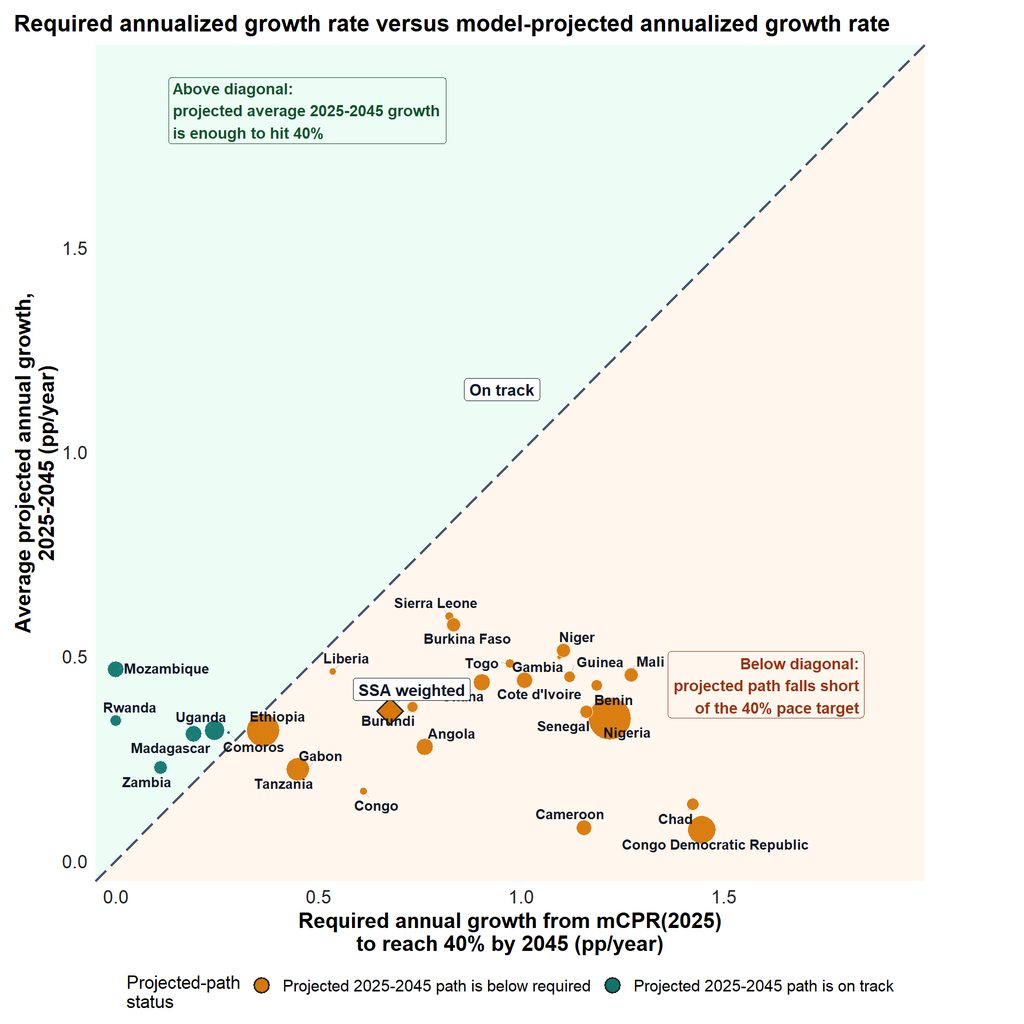

```r
ssa_goal_final_projected_feasibility <- ssa_goal_final_feasibility %>%
  filter(current_latest_obs_pct < 40) %>%
  mutate(
    projected_track_binary = if_else(
      projected_growth_2025_2045_pp_per_year >= required_growth_from_p2025_pp_per_year,
      "Projected 2025-2045 path is on track",
      "Projected 2025-2045 path is below required"
    )
  )

ssa_goal_final_region_projected_feasibility <- ssa_goal_final_region_row %>%
  mutate(
    projected_track_binary = if_else(
      projected_growth_2025_2045_pp_per_year >= required_growth_from_p2025_pp_per_year,
      "Projected 2025-2045 path is on track",
      "Projected 2025-2045 path is below required"
    )
  )

ssa_goal_final_projected_feasibility_limits <- range(
  c(
    ssa_goal_final_projected_feasibility$required_growth_from_p2025_pp_per_year,
    ssa_goal_final_projected_feasibility$projected_growth_2025_2045_pp_per_year,
    ssa_goal_final_region_projected_feasibility$required_growth_from_p2025_pp_per_year,
    ssa_goal_final_region_projected_feasibility$projected_growth_2025_2045_pp_per_year
  ),
  na.rm = TRUE
)
ssa_goal_final_projected_feasibility_limits[1] <- min(0, ssa_goal_final_projected_feasibility_limits[1]) - 0.05
ssa_goal_final_projected_feasibility_limits[2] <- ssa_goal_final_projected_feasibility_limits[2] + 0.55
ssa_goal_final_projected_feasibility_mid <- mean(ssa_goal_final_projected_feasibility_limits)

ssa_goal_final_projected_feasibility_cols <- c(
  "Projected 2025-2045 path is on track" = "#0F766E",
  "Projected 2025-2045 path is below required" = "#D97706"
)

ggplot() +
  geom_polygon(
    data = tibble(
      x = c(
        ssa_goal_final_projected_feasibility_limits[1],
        ssa_goal_final_projected_feasibility_limits[1],
        ssa_goal_final_projected_feasibility_limits[2]
      ),
      y = c(
        ssa_goal_final_projected_feasibility_limits[1],
        ssa_goal_final_projected_feasibility_limits[2],
        ssa_goal_final_projected_feasibility_limits[2]
      )
    ),
    aes(x = x, y = y),
    inherit.aes = FALSE,
    fill = "#ECFDF5",
    color = NA
  ) +
  geom_polygon(
    data = tibble(
      x = c(
        ssa_goal_final_projected_feasibility_limits[1],
        ssa_goal_final_projected_feasibility_limits[2],
        ssa_goal_final_projected_feasibility_limits[2]
      ),
      y = c(
        ssa_goal_final_projected_feasibility_limits[1],
        ssa_goal_final_projected_feasibility_limits[1],
        ssa_goal_final_projected_feasibility_limits[2]
      )
    ),
    aes(x = x, y = y),
    inherit.aes = FALSE,
    fill = "#FFF7ED",
    color = NA
  ) +
  geom_abline(
    slope = 1,
    intercept = 0,
    linetype = "longdash",
    color = "#475569",
    linewidth = 0.75
  ) +
  geom_point(
    data = ssa_goal_final_projected_feasibility,
    aes(
      x = required_growth_from_p2025_pp_per_year,
      y = projected_growth_2025_2045_pp_per_year,
      size = women_15_49_millions,
      fill = projected_track_binary
    ),
    shape = 21,
    color = "white",
    alpha = 0.95,
    stroke = 0.45
  ) +
  geom_point(
    data = ssa_goal_final_region_projected_feasibility,
    aes(
      x = required_growth_from_p2025_pp_per_year,
      y = projected_growth_2025_2045_pp_per_year,
      fill = projected_track_binary
    ),
    shape = 23,
    size = 6.2,
    color = "grey15",
    stroke = 0.95
  ) +
  ggrepel::geom_text_repel(
    data = ssa_goal_final_projected_feasibility,
    aes(
      x = required_growth_from_p2025_pp_per_year,
      y = projected_growth_2025_2045_pp_per_year,
      label = geography
    ),
    seed = 2025,
    size = 3.45,
    color = "#111827",
    fontface = "bold",
    segment.color = "grey55",
    segment.alpha = 0.65,
    segment.size = 0.28,
    min.segment.length = 0,
    box.padding = 0.32,
    point.padding = 0.18,
    force = 1.2,
    force_pull = 0.12,
    max.overlaps = Inf,
    show.legend = FALSE
  ) +
  ggrepel::geom_label_repel(
    data = ssa_goal_final_region_projected_feasibility,
    aes(
      x = required_growth_from_p2025_pp_per_year,
      y = projected_growth_2025_2045_pp_per_year,
      label = "SSA weighted"
    ),
    seed = 2025,
    size = 4.0,
    color = "#111827",
    fontface = "bold",
    segment.color = "grey40",
    segment.alpha = 0.75,
    segment.size = 0.34,
    min.segment.length = 0,
    box.padding = 0.42,
    point.padding = 0.26,
    force = 1.45,
    force_pull = 0.14,
    max.overlaps = Inf,
    fill = "white",
    label.size = 0.22,
    label.r = unit(0.14, "lines"),
    show.legend = FALSE
  ) +
  annotate(
    "label",
    x = ssa_goal_final_projected_feasibility_limits[1] + 0.18,
    y = ssa_goal_final_projected_feasibility_limits[2] - 0.08,
    label = "Above diagonal:\nprojected average 2025-2045 growth\nis enough to hit 40%",
    hjust = 0,
    vjust = 1,
    size = 3.8,
    fontface = "bold",
    label.size = 0.2,
    fill = "#ECFDF5",
    color = "#14532D"
  ) +
  annotate(
    "label",
    x = ssa_goal_final_projected_feasibility_limits[2] - 0.15,
    y = ssa_goal_final_projected_feasibility_limits[1] + 0.4,
    label = "Below diagonal:\nprojected path falls short\nof the 40% pace target",
    hjust = 1,
    vjust = 0,
    size = 3.8,
    fontface = "bold",
    label.size = 0.2,
    fill = "#FFF7ED",
    color = "#9A3412"
  ) +
  annotate(
    "label",
    x = ssa_goal_final_projected_feasibility_mid - 0.02,
    y = ssa_goal_final_projected_feasibility_mid + 0.18,
    label = "On track",
    fontface = "bold",
    size = 3.95,
    label.size = 0.18,
    fill = "white",
    color = "#111827"
  ) +
  scale_fill_manual(
    values = ssa_goal_final_projected_feasibility_cols,
    name = "Projected-path\nstatus"
  ) +
  scale_size_area(
    max_size = 14,
    guide = "none"
  ) +
  scale_x_continuous(
    limits = ssa_goal_final_projected_feasibility_limits,
    expand = expansion(mult = 0)
  ) +
  scale_y_continuous(
    limits = ssa_goal_final_projected_feasibility_limits,
    expand = expansion(mult = 0)
  ) +
  coord_cartesian(clip = "off") +
  theme_minimal(base_size = 12.6) +
  theme(
    legend.position = "bottom",
    legend.box = "vertical",
    legend.margin = margin(0, 0, 0, 0),
    panel.grid.minor = element_blank(),
    panel.grid.major = element_line(color = "grey90", linewidth = 0.35),
    plot.title.position = "plot",
    axis.text = element_text(size = 13.2, color = "grey15"),
    axis.title = element_text(size = 15.1, face = "bold"),
    legend.text = element_text(size = 11.2, lineheight = 0.92),
    plot.title = element_text(size = 16.0, face = "bold"),
    plot.subtitle = element_text(size = 12.1, lineheight = 1.03),
    plot.margin = margin(10, 70, 10, 10)
  ) +
  guides(
    fill = guide_legend(
      order = 1,
      nrow = 1,
      byrow = TRUE,
      override.aes = list(shape = 21, size = 4.5, color = "grey15", alpha = 1)
    )
  ) +
  labs(
    title = "Required annualized growth rate versus model-projected annualized growth rate",
    x = paste0("Required annual growth from mCPR(2025)\nto reach 40% by ", ssa_goal_final_target_year, " (pp/year)"),
    y = paste0("Average projected annual growth,\n2025-", ssa_goal_final_target_year, " (pp/year)")
  )
```

### 24.20.9 Projected-path acceleration gap to 2045

The current-growth graph above is helpful, but it can overstate who is really on track. A country can look fast in `2025` simply because it is in the steep middle of the S curve, even if that pace later slows before `2045`.

This section answers a simpler question: if we follow the model’s full projected path from `2025` to `2045`, is that projected pace enough to reach `40%`?

Interpretation: a) the red benchmark is the annualized growth required from `mCPR(2025)` to reach `40%` by `2045`; b) the compared projected value is the model’s **average projected annualized growth** over the full `2025` to `2045` path; c) because the projected value uses the full path, it already builds in S-curve deceleration as countries move toward `K`.

Important reading note: - `estimated mCPR(2045)` means the model’s projected **mCPR level in 2045** under the fitted trajectory. - It is **not** a probability. - The probability is shown separately as `P(cross by 2045)`, which is the share of posterior draws that reach or exceed `40%` by `2045`.

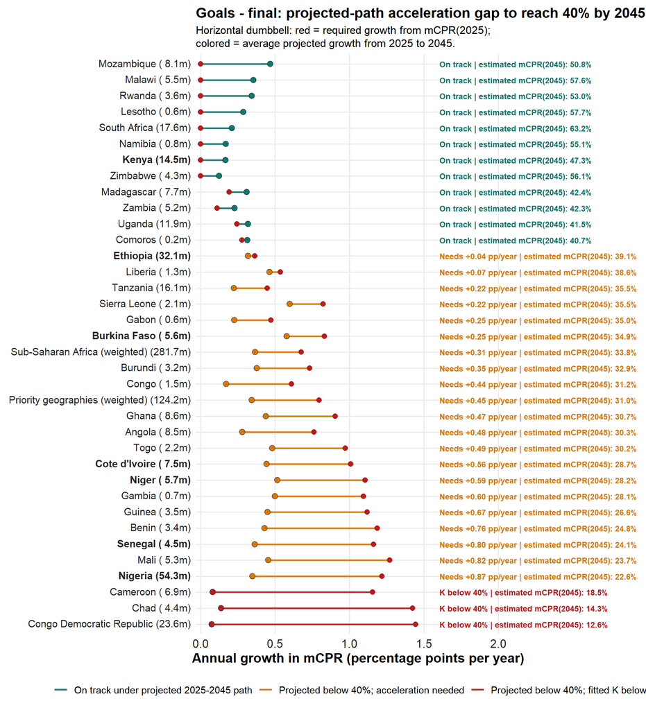

```r
ggplot(
  ssa_goal_final_projected_track,
  aes(y = geography_label_gap_plot)
) +
  geom_segment(
    aes(
      x = required_growth_from_p2025_pp_per_year,
      xend = projected_growth_2025_2045_pp_per_year,
      yend = geography_label_gap_plot,
      color = projected_track_status
    ),
    linewidth = 1.0,
    alpha = 0.9
  ) +
  geom_point(
    aes(x = required_growth_from_p2025_pp_per_year),
    color = "#B91C1C",
    fill = "#B91C1C",
    shape = 21,
    size = 2.7,
    stroke = 0.3
  ) +
  geom_point(
    aes(
      x = projected_growth_2025_2045_pp_per_year,
      fill = projected_track_status
    ),
    color = "#0F172A",
    shape = 21,
    size = 2.9,
    stroke = 0.35
  ) +
  geom_text(
    aes(
      x = ssa_goal_final_projected_track_label_x,
      label = projected_track_label,
      color = projected_track_status
    ),
    hjust = 0,
    size = 3.2,
    fontface = "bold",
    show.legend = FALSE
  ) +
  scale_fill_manual(values = ssa_goal_final_projected_track_status_cols, guide = "none") +
  scale_color_manual(
    values = ssa_goal_final_projected_track_status_cols,
    name = "Projected-path status"
  ) +
  scale_x_continuous(
    expand = expansion(mult = c(0.02, 0.34))
  ) +
  coord_cartesian(clip = "off") +
  scale_y_discrete(labels = priority_country_axis_labels) +
  theme_minimal(base_size = 12.4) +
  theme(
    legend.position = "bottom",
    legend.title = element_blank(),
    panel.grid.minor = element_blank(),
    axis.text.x = element_text(size = 13.0, color = "grey15"),
    axis.text.y = element_text(size = 11.4, color = "grey15"),
    axis.title = element_text(size = 14.8, face = "bold"),
    legend.text = element_text(size = 10.9),
    plot.title = element_text(size = 15.6, face = "bold"),
    plot.subtitle = element_text(size = 11.9, lineheight = 1.02),
    plot.margin = margin(8, 140, 8, 10)
  ) +
  labs(
    title = "Goals - final: projected-path acceleration gap to reach 40% by 2045",
    subtitle = "Horizontal dumbbell: red = required growth from mCPR(2025);\ncolored = average projected growth from 2025 to 2045.",
    x = "Annual growth in mCPR (percentage points per year)",
    y = NULL
  )
```

The same projected-path comparison can also be read as a slopegraph: each geography is one line connecting the annualized growth required from `p(2025)` to the model’s average projected annualized growth from `2025` to `2045`.

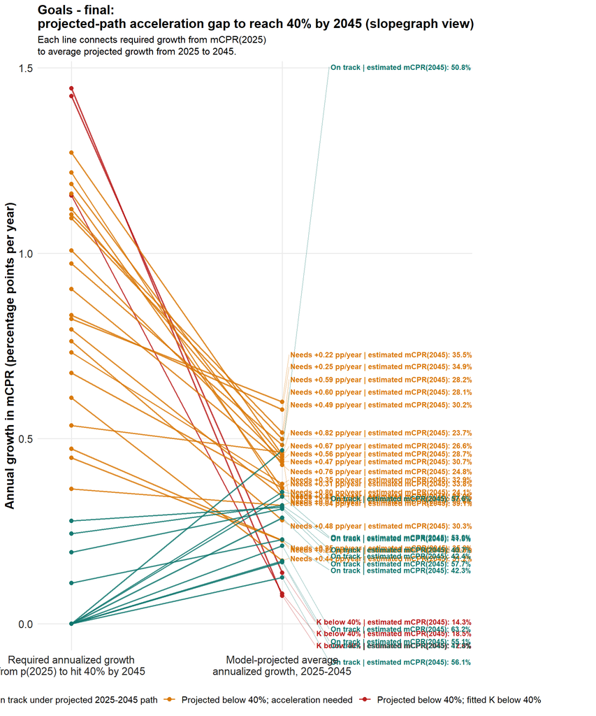

```r
ssa_goal_final_projected_track_slope <- bind_rows(
  ssa_goal_final_projected_track %>%
    transmute(
      geography_label_gap_plot,
      projected_track_status,
      metric = paste0(
        "Required annualized growth\nfrom p(2025) to hit 40% by ",
        ssa_goal_final_target_year
      ),
      growth_pp_per_year = required_growth_from_p2025_pp_per_year,
      point_label = NA_character_
    ),
  ssa_goal_final_projected_track %>%
    transmute(
      geography_label_gap_plot,
      projected_track_status,
      metric = paste0(
        "Model-projected average\nannualized growth, 2025-",
        ssa_goal_final_target_year
      ),
      growth_pp_per_year = projected_growth_2025_2045_pp_per_year,
      point_label = projected_track_label
    )
) %>%
  mutate(
    metric = factor(
      metric,
      levels = c(
        paste0(
          "Required annualized growth\nfrom p(2025) to hit 40% by ",
          ssa_goal_final_target_year
        ),
        paste0(
          "Model-projected average\nannualized growth, 2025-",
          ssa_goal_final_target_year
        )
      )
    )
  )

ggplot(
  ssa_goal_final_projected_track_slope,
  aes(
    x = metric,
    y = growth_pp_per_year,
    group = geography_label_gap_plot,
    color = projected_track_status
  )
) +
  geom_line(linewidth = 0.85, alpha = 0.82) +
  geom_point(size = 2.2, alpha = 0.96) +
  ggrepel::geom_text_repel(
    data = ssa_goal_final_projected_track_slope %>%
      filter(metric == levels(metric)[2]),
    aes(label = point_label),
    direction = "y",
    hjust = 0,
    nudge_x = 0.22,
    size = 3.15,
    fontface = "bold",
    segment.alpha = 0.35,
    min.segment.length = 0,
    box.padding = 0.22,
    point.padding = 0.15,
    label.size = 0.15,
    fill = "white",
    show.legend = FALSE
  ) +
  scale_color_manual(
    values = ssa_goal_final_projected_track_status_cols,
    name = "Projected-path status"
  ) +
  scale_x_discrete(
    expand = expansion(add = c(0.16, 0.9))
  ) +
  coord_cartesian(clip = "off") +
  theme_minimal(base_size = 12.2) +
  theme(
    legend.position = "bottom",
    legend.title = element_blank(),
    panel.grid.minor = element_blank(),
    axis.title.x = element_blank(),
    axis.text = element_text(size = 12.9, color = "grey15"),
    axis.title.y = element_text(size = 14.6, face = "bold"),
    legend.text = element_text(size = 10.9),
    plot.title = element_text(size = 15.4, face = "bold"),
    plot.subtitle = element_text(size = 11.8, lineheight = 1.02),
    plot.margin = margin(5.5, 150, 5.5, 5.5)
  ) +
  labs(
    title = "Goals - final:\nprojected-path acceleration gap to reach 40% by 2045 (slopegraph view)",
    subtitle = "Each line connects required growth from mCPR(2025)\nto average projected growth from 2025 to 2045.",
    y = "Annual growth in mCPR (percentage points per year)"
  )
```

### 24.20.10 Growth-rate paths for SSA, the weighted priority geographies, and the 7 priority countries

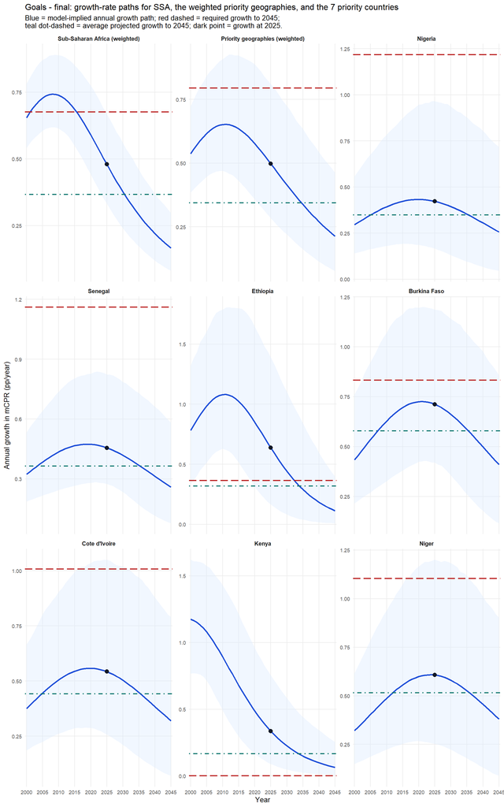

```r
ggplot(
  ssa_goal_final_growth_focus_plot,
  aes(x = year, y = growth_mean)
) +
  geom_ribbon(
    aes(ymin = growth_p05, ymax = growth_p95),
    fill = "#DBEAFE",
    alpha = 0.4
  ) +
  geom_line(
    color = "#1D4ED8",
    linewidth = 1.0
  ) +
  geom_hline(
    aes(yintercept = required_growth_from_p2025_pp_per_year),
    color = "#B91C1C",
    linetype = "longdash",
    linewidth = 0.75
  ) +
  geom_hline(
    aes(yintercept = projected_growth_2025_2045_pp_per_year),
    color = "#0F766E",
    linetype = "dotdash",
    linewidth = 0.75
  ) +
  geom_point(
    data = ssa_goal_final_growth_focus_plot %>% filter(year == 2025),
    aes(x = year, y = model_dpdt_2025_pp_per_year),
    inherit.aes = FALSE,
    color = "#111827",
    fill = "#111827",
    shape = 21,
    size = 2.6,
    stroke = 0.2
  ) +
  facet_wrap(~ geography_plot, ncol = 3, scales = "free_y") +
  scale_x_continuous(
    breaks = seq(2000, ssa_goal_final_target_year, by = 5),
    expand = expansion(mult = c(0.01, 0.01))
  ) +
  theme_minimal(base_size = 10) +
  theme(
    legend.position = "none",
    panel.grid.minor = element_blank(),
    strip.text = element_text(face = "bold", size = 8.2, lineheight = 0.95),
    axis.text.x = element_text(size = 7.2),
    axis.text.y = element_text(size = 7.1)
  ) +
  labs(
    title = "Goals - final: growth-rate paths for SSA, the weighted priority geographies, and the 7 priority countries",
    subtitle = "Blue = model-implied annual growth path; red dashed = required growth to 2045;\nteal dot-dashed = average projected growth to 2045; dark point = growth at 2025.",
    x = "Year",
    y = "Annual growth in mCPR (pp/year)"
  )
```

### 24.20.11 Weighted SSA region and all country trajectories relative to 40%

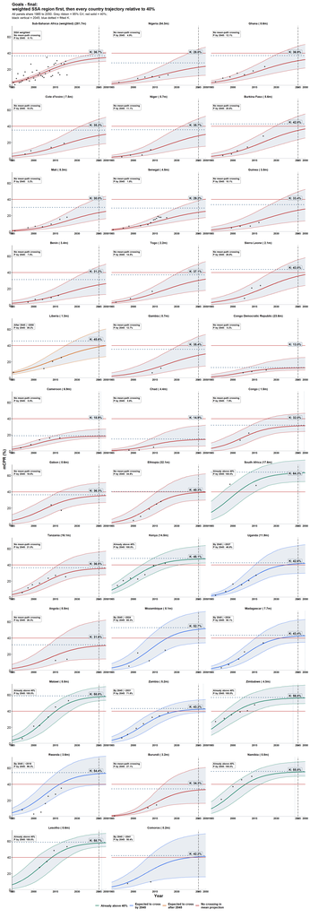

```r
ggplot(ssa_goal_final_traj_plot, aes(x = year, y = 100 * p_mean)) +
  geom_ribbon(
    aes(
      ymin = 100 * p_p05,
      ymax = 100 * p_p95
    ),
    fill = "#CBD5E1",
    alpha = 0.42
  ) +
  geom_line(
    aes(
      y = 100 * p_p05,
      color = trajectory_status_plot
    ),
    linewidth = 0.42,
    alpha = 0.9
  ) +
  geom_line(
    aes(
      y = 100 * p_p95,
      color = trajectory_status_plot
    ),
    linewidth = 0.42,
    alpha = 0.9
  ) +
  geom_line(
    aes(color = trajectory_status_plot),
    linewidth = 1.02
  ) +
  geom_segment(
    data = ssa_goal_final_facet_axis_base,
    aes(x = x, xend = xend, y = y, yend = yend),
    inherit.aes = FALSE,
    color = "#4B5563",
    linewidth = 0.28
  ) +
  geom_segment(
    data = ssa_goal_final_facet_axis_ticks,
    aes(x = x, xend = xend, y = y, yend = yend),
    inherit.aes = FALSE,
    color = "#4B5563",
    linewidth = 0.24
  ) +
  geom_text(
    data = ssa_goal_final_facet_axis_labels,
    aes(x = x, y = y, label = axis_label),
    inherit.aes = FALSE,
    color = "black",
    size = 3.45,
    fontface = "bold"
  ) +
  geom_point(
    data = ssa_goal_final_obs_plot,
    aes(x = year, y = mcp_pct),
    inherit.aes = FALSE,
    color = "black",
    size = 1.55,
    alpha = 0.72
  ) +
  geom_hline(
    yintercept = 40,
    linetype = "solid",
    color = "#B91C1C",
    linewidth = 0.7
  ) +
  geom_vline(
    xintercept = ssa_goal_final_target_year,
    linetype = "longdash",
    color = "grey20",
    linewidth = 0.55
  ) +
  geom_hline(
    data = ssa_goal_final_panel_meta_plot,
    aes(yintercept = 100 * K_mean),
    linetype = "dotted",
    color = "#1F4E79",
    linewidth = 1.18,
    alpha = 1
  ) +
  geom_vline(
    data = ssa_goal_final_panel_meta_plot %>% filter(!is.na(year_reach_99pctK_mean)),
    aes(xintercept = year_reach_99pctK_mean),
    linetype = "dotted",
    color = "#1F4E79",
    linewidth = 0.48
  ) +
  geom_label(
    data = ssa_goal_final_panel_meta_plot,
    aes(
      x = k_label_x,
      y = k_label_y,
      label = paste0("K: ", format(round(100 * K_mean, 1), nsmall = 1), "%")
    ),
    inherit.aes = FALSE,
    hjust = 1,
    vjust = 0.5,
    size = 3.95,
    fontface = "bold",
    label.size = 0.24,
    label.padding = grid::unit(0.24, "lines"),
    fill = "#EAF2FA",
    color = "black"
  ) +
  geom_label(
    data = ssa_goal_final_panel_meta_plot,
    aes(
      x = annotation_x,
      y = annotation_y,
      label = crossing_label_with_prob
    ),
    inherit.aes = FALSE,
    hjust = 0,
    vjust = 1,
    size = 3.15,
    lineheight = 0.98,
    fontface = "bold",
    label.size = 0.24,
    label.padding = grid::unit(0.22, "lines"),
    fill = scales::alpha("white", 0.98),
    color = "black"
  ) +
  facet_wrap(~ panel_label, ncol = 3, scales = "fixed") +
  scale_color_manual(
    values = ssa_goal_final_status_cols,
    breaks = c(
      "Already crossed",
      paste0("Projected to cross by ", ssa_goal_final_target_year),
      paste0("Projected to cross after ", ssa_goal_final_target_year),
      "Not projected to cross"
    ),
    labels = c(
      "Already above 40%",
      paste0("Expected to cross\nby ", ssa_goal_final_target_year),
      paste0("Expected to cross\nafter ", ssa_goal_final_target_year),
      "No crossing in\nmean projection"
    )
  ) +
  scale_x_continuous(
    breaks = seq(1985, 2050, by = 5),
    limits = c(1985, 2050),
    expand = expansion(mult = c(0, 0))
  ) +
  coord_cartesian(xlim = c(1985, 2050), ylim = c(0, 70), clip = "off") +
  theme_minimal(base_size = 11.2) +
  theme(
    legend.position = "bottom",
    legend.title = element_blank(),
    panel.grid.minor = element_blank(),
    panel.grid.major = element_blank(),
    panel.spacing = unit(1.45, "lines"),
    strip.text = element_text(face = "bold", size = 11.0, lineheight = 0.98, color = "black"),
    axis.text.x = element_blank(),
    axis.ticks.x = element_blank(),
    axis.text.y = element_text(size = 12.4, color = "black"),
    axis.title = element_text(size = 15.8, face = "bold", color = "black"),
    axis.line.y = element_line(color = "black", linewidth = 0.45),
    axis.ticks.y = element_line(color = "black", linewidth = 0.4),
    legend.text = element_text(size = 11.4, lineheight = 0.94, color = "black", face = "bold"),
    plot.title = element_text(size = 16.2, face = "bold"),
    plot.subtitle = element_text(size = 11.8, lineheight = 1.02),
    plot.margin = margin(10, 18, 30, 10)
  ) +
  labs(
    title = "Goals - final:\nweighted SSA region first, then every country trajectory relative to 40%",
    subtitle = paste0(
      "All panels share 1985 to 2050. Grey ribbon = 95% CrI; red solid = 40%;\n",
      "black vertical = ", ssa_goal_final_target_year, "; blue dotted = fitted K."
    ),
    x = "Year",
    y = "mCPR (%)"
  )
```

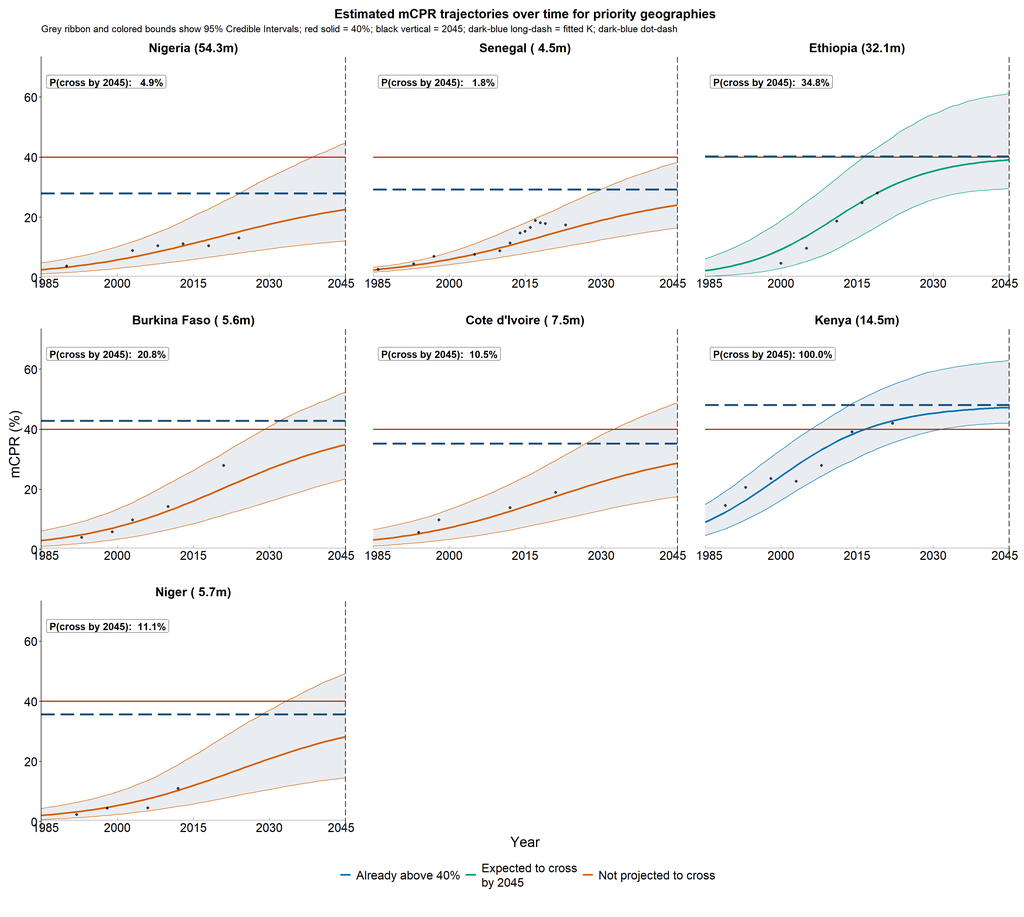

```r
ggplot(ssa_goal_final_traj_plot_priority_only, aes(x = year, y = 100 * p_mean)) +
  geom_ribbon(
    aes(
      ymin = 100 * p_p05,
      ymax = 100 * p_p95
    ),
    fill = "#CBD5E1",
    alpha = 0.42
  ) +
  geom_line(
    aes(
      y = 100 * p_p05,
      color = priority_trajectory_status
    ),
    linewidth = 0.48,
    alpha = 0.9
  ) +
  geom_line(
    aes(
      y = 100 * p_p95,
      color = priority_trajectory_status
    ),
    linewidth = 0.48,
    alpha = 0.9
  ) +
  geom_line(
    aes(color = priority_trajectory_status),
    linewidth = 1.15
  ) +
  geom_segment(
    data = ssa_goal_final_facet_axis_base_priority_only,
    aes(x = x, xend = xend, y = y, yend = yend),
    inherit.aes = FALSE,
    color = "#4B5563",
    linewidth = 0.28
  ) +
  geom_segment(
    data = ssa_goal_final_facet_axis_ticks_priority_only,
    aes(x = x, xend = xend, y = y, yend = yend),
    inherit.aes = FALSE,
    color = "#4B5563",
    linewidth = 0.24
  ) +
  geom_text(
    data = ssa_goal_final_facet_axis_labels_priority_only,
    aes(x = x, y = y, label = axis_label),
    inherit.aes = FALSE,
    color = "black",
    size = 16.4 / ggplot2::.pt
  ) +
  geom_point(
    data = ssa_goal_final_obs_plot_priority_only,
    aes(x = year, y = mcp_pct),
    inherit.aes = FALSE,
    color = "black",
    size = 1.4,
    alpha = 0.72
  ) +
  geom_hline(
    yintercept = 40,
    linetype = "solid",
    color = "#B91C1C",
    linewidth = 0.72
  ) +
  geom_vline(
    xintercept = ssa_goal_final_target_year,
    linetype = "longdash",
    color = "grey20",
    linewidth = 0.55
  ) +
  geom_hline(
    data = ssa_goal_final_priority_only_panel_meta_plot,
    aes(yintercept = 100 * K_mean),
    linetype = "longdash",
    color = "#1F4E79",
    linewidth = 1.3,
    alpha = 1
  ) +
  geom_vline(
    data = ssa_goal_final_priority_only_panel_meta_plot %>% filter(!is.na(year_reach_99pctK_mean)),
    aes(xintercept = year_reach_99pctK_mean),
    linetype = "dotdash",
    color = "#1F4E79",
    linewidth = 0.62
  ) +
  geom_label(
    data = ssa_goal_final_priority_only_panel_meta_plot,
    aes(
      x = k_label_x,
      y = k_label_y_priority,
      label = paste0("K: ", format(round(100 * K_mean, 1), nsmall = 1), "%")
    ),
    inherit.aes = FALSE,
    hjust = 1,
    vjust = 0,
    size = 5.35,
    label.size = 0.26,
    label.padding = grid::unit(0.28, "lines"),
    fill = "#EDF4FB",
    color = "black",
    fontface = "bold"
  ) +
  geom_label(
    data = ssa_goal_final_priority_only_panel_meta_plot,
    aes(
      x = annotation_x,
      y = annotation_y,
      label = priority_prob_label
    ),
    inherit.aes = FALSE,
    hjust = 0,
    vjust = 1,
    size = 4.7,
    label.size = 0.24,
    label.padding = grid::unit(0.26, "lines"),
    fill = scales::alpha("white", 0.98),
    color = "black",
    fontface = "bold"
  ) +
  facet_wrap(~ panel_label, ncol = 3, scales = "fixed") +
  scale_color_manual(
    values = ssa_goal_final_priority_status_cols,
    breaks = c(
      "Already crossed",
      "Projected to cross",
      "Not projected to cross"
    ),
    labels = c(
      "Already above 40%",
      paste0("Expected to cross\nby ", ssa_goal_final_target_year),
      "Not projected to cross"
    )
  ) +
  scale_x_continuous(
    breaks = ssa_goal_final_axis_breaks_priority_only,
    limits = c(1985, 2045),
    expand = expansion(mult = c(0, 0))
  ) +
  coord_cartesian(xlim = c(1985, 2045), ylim = c(0, 70), clip = "off") +
  theme_minimal(base_size = 11.3) +
  theme(
    legend.position = "bottom",
    legend.title = element_blank(),
    panel.grid.minor = element_blank(),
    panel.grid.major = element_blank(),
    panel.spacing.y = unit(2.1, "lines"),
    panel.spacing.x = unit(2.6, "lines"),
    strip.text = element_text(size = 16.8, face = "bold", lineheight = 1.02, color = "black"),
    axis.text.x = element_blank(),
    axis.ticks.x = element_blank(),
    axis.text.y = element_text(size = 16.4, color = "black"),
    axis.title = element_text(size = 19.2, color = "black"),
    axis.line.y = element_line(color = "black", linewidth = 0.45),
    axis.ticks.y = element_line(color = "black", linewidth = 0.4),
    legend.text = element_text(size = 16.0, lineheight = 1.0, color = "black"),
    plot.title = element_text(size = 17.2, face = "bold", color = "black", hjust = 0.5),
    plot.subtitle = element_text(size = 13.2, lineheight = 1.05, color = "black"),
    plot.margin = margin(12, 20, 34, 12)
  ) +
  labs(
    title = "Estimated mCPR trajectories over time for priority geographies",
    subtitle = paste0(
      "Grey ribbon and colored bounds show 95% Credible Intervals; red solid = 40%; ",
      "black vertical = ", ssa_goal_final_target_year, "; dark-blue long-dash = fitted K; ",
      "dark-blue dot-dash"
    ),
    x = "Year",
    y = "mCPR (%)"
  )
```

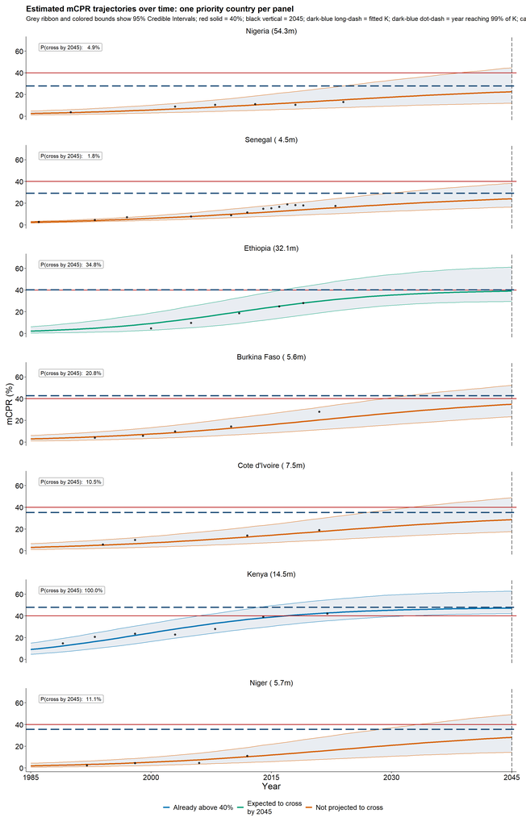

```r
ggplot(ssa_goal_final_traj_plot_priority_only, aes(x = year, y = 100 * p_mean)) +
  geom_ribbon(
    aes(
      ymin = 100 * p_p05,
      ymax = 100 * p_p95
    ),
    fill = "#CBD5E1",
    alpha = 0.42
  ) +
  geom_line(
    aes(
      y = 100 * p_p05,
      color = priority_trajectory_status
    ),
    linewidth = 0.52,
    alpha = 0.92
  ) +
  geom_line(
    aes(
      y = 100 * p_p95,
      color = priority_trajectory_status
    ),
    linewidth = 0.52,
    alpha = 0.92
  ) +
  geom_line(
    aes(color = priority_trajectory_status),
    linewidth = 1.28
  ) +
  geom_point(
    data = ssa_goal_final_obs_plot_priority_only,
    aes(x = year, y = mcp_pct),
    inherit.aes = FALSE,
    color = "black",
    size = 1.8,
    alpha = 0.75
  ) +
  geom_hline(
    yintercept = 40,
    linetype = "solid",
    color = "#B91C1C",
    linewidth = 0.78
  ) +
  geom_vline(
    xintercept = ssa_goal_final_target_year,
    linetype = "longdash",
    color = "grey20",
    linewidth = 0.58
  ) +
  geom_hline(
    data = ssa_goal_final_priority_only_panel_meta_plot,
    aes(yintercept = 100 * K_mean),
    linetype = "longdash",
    color = "#1F4E79",
    linewidth = 1.32,
    alpha = 1
  ) +
  geom_vline(
    data = ssa_goal_final_priority_only_panel_meta_plot %>% filter(!is.na(year_reach_99pctK_mean)),
    aes(xintercept = year_reach_99pctK_mean),
    linetype = "dotdash",
    color = "#1F4E79",
    linewidth = 0.68
  ) +
  geom_label(
    data = ssa_goal_final_priority_only_panel_meta_plot,
    aes(
      x = k_label_x,
      y = k_label_y,
      label = paste0("K: ", format(round(100 * K_mean, 1), nsmall = 1), "%")
    ),
    inherit.aes = FALSE,
    hjust = 1,
    vjust = 0.5,
    size = 5.2,
    label.size = 0.28,
    label.padding = grid::unit(0.3, "lines"),
    fill = "#EDF4FB",
    color = "black"
  ) +
  geom_label(
    data = ssa_goal_final_priority_only_panel_meta_plot,
    aes(
      x = annotation_x,
      y = annotation_y,
      label = priority_prob_label
    ),
    inherit.aes = FALSE,
    hjust = 0,
    vjust = 1,
    size = 4.15,
    label.size = 0.24,
    label.padding = grid::unit(0.28, "lines"),
    fill = scales::alpha("white", 0.98),
    color = "black"
  ) +
  facet_wrap(~ panel_label, ncol = 1, scales = "fixed") +
  scale_color_manual(
    values = ssa_goal_final_priority_status_cols,
    breaks = c(
      "Already crossed",
      "Projected to cross",
      "Not projected to cross"
    ),
    labels = c(
      "Already above 40%",
      paste0("Expected to cross\nby ", ssa_goal_final_target_year),
      "Not projected to cross"
    )
  ) +
  scale_x_continuous(
    breaks = ssa_goal_final_axis_breaks_priority_only,
    limits = c(1985, 2045),
    expand = expansion(mult = c(0.01, 0.01))
  ) +
  coord_cartesian(xlim = c(1985, 2045), ylim = c(0, 70), clip = "off") +
  theme_minimal(base_size = 12.6) +
  theme(
    legend.position = "bottom",
    legend.title = element_blank(),
    panel.grid.minor = element_blank(),
    panel.grid.major = element_blank(),
    panel.spacing = unit(2.0, "lines"),
    strip.text = element_text(size = 15.6, lineheight = 1.03, color = "black"),
    axis.text = element_text(size = 15.2, color = "black"),
    axis.title = element_text(size = 18.6, color = "black"),
    axis.line = element_line(color = "black", linewidth = 0.45),
    axis.ticks = element_line(color = "black", linewidth = 0.4),
    legend.text = element_text(size = 14.8, lineheight = 1.0, color = "black"),
    plot.title = element_text(size = 17.2, face = "bold", color = "black"),
    plot.subtitle = element_text(size = 13.4, lineheight = 1.05, color = "black"),
    plot.margin = margin(12, 20, 18, 12)
  ) +
  labs(
    title = "Estimated mCPR trajectories over time: one priority country per panel",
    subtitle = paste0(
      "Grey ribbon and colored bounds show 95% Credible Intervals; red solid = 40%; ",
      "black vertical = ", ssa_goal_final_target_year, "; dark-blue long-dash = fitted K; ",
      "dark-blue dot-dash = year reaching 99% of K; callouts report P(cross by ", ssa_goal_final_target_year, ")."
    ),
    x = "Year",
    y = "mCPR (%)"
  )
```

### 24.20.12 Counterfactual lift to the weighted SSA mean if one not-on-track country reached 40% by 2045

This counterfactual holds every other country at its fitted `2045` level and asks: if one country that is **not** currently projected to cross `40%` by `2045` were instead brought up to `40%`, how much would the weighted SSA estimated `mCPR(2045)` move?

Interpretation: a) bars show the average lift to the weighted SSA estimated `mCPR(2045)`; b) countries are ranked from the largest lift to the smallest lift; c) the biggest lifts come from a combination of large population weight and a large remaining shortfall to `40%` in `2045`.

```r
ssa_goal_final_lift_if40_mat <- sweep(
  pmax(target_mcpr_40 - ssa_p2045_draws, 0),
  2,
  ssa_weight_vec_latest,
  `*`
)

ssa_goal_final_weighted_ssa_p2045_pct <- 100 * mean(ssa_region_p2045_draws_final)
ssa_goal_final_lift_if40_mean <- 100 * colMeans(ssa_goal_final_lift_if40_mat)
ssa_goal_final_lift_if40_p05 <- 100 * apply(ssa_goal_final_lift_if40_mat, 2, quantile, ci_lower)
ssa_goal_final_lift_if40_p95 <- 100 * apply(ssa_goal_final_lift_if40_mat, 2, quantile, ci_upper)

ssa_goal_final_counterfactual_lift <- ssa_goal_final_country_rows %>%
  filter(!trajectory_status_final %in% c(
    "Already crossed",
    paste0("Projected to cross by ", ssa_goal_final_target_year)
  )) %>%
  mutate(
    lift_if_hit_40_pp = ssa_goal_final_lift_if40_mean[match(geography, ssa_country_order_vec)],
    lift_if_hit_40_p05 = ssa_goal_final_lift_if40_p05[match(geography, ssa_country_order_vec)],
    lift_if_hit_40_p95 = ssa_goal_final_lift_if40_p95[match(geography, ssa_country_order_vec)]
  ) %>%
  arrange(desc(lift_if_hit_40_pp), geography)

ssa_goal_final_counterfactual_lift <- ssa_goal_final_counterfactual_lift %>%
  mutate(
    geography_label_plot = factor(
    geography_label,
      levels = rev(ssa_goal_final_counterfactual_lift$geography_label),
      ordered = TRUE
    ),
    counterfactual_ssa_p2045_pct = ssa_goal_final_weighted_ssa_p2045_pct + lift_if_hit_40_pp,
    label_x = pmax(lift_if_hit_40_pp, lift_if_hit_40_p95) + 0.04,
    label_text = paste0(
      format(round(lift_if_hit_40_pp, 2), nsmall = 2),
      " pp | SSA ",
      format(round(counterfactual_ssa_p2045_pct, 1), nsmall = 1),
      "%"
    )
  )
```

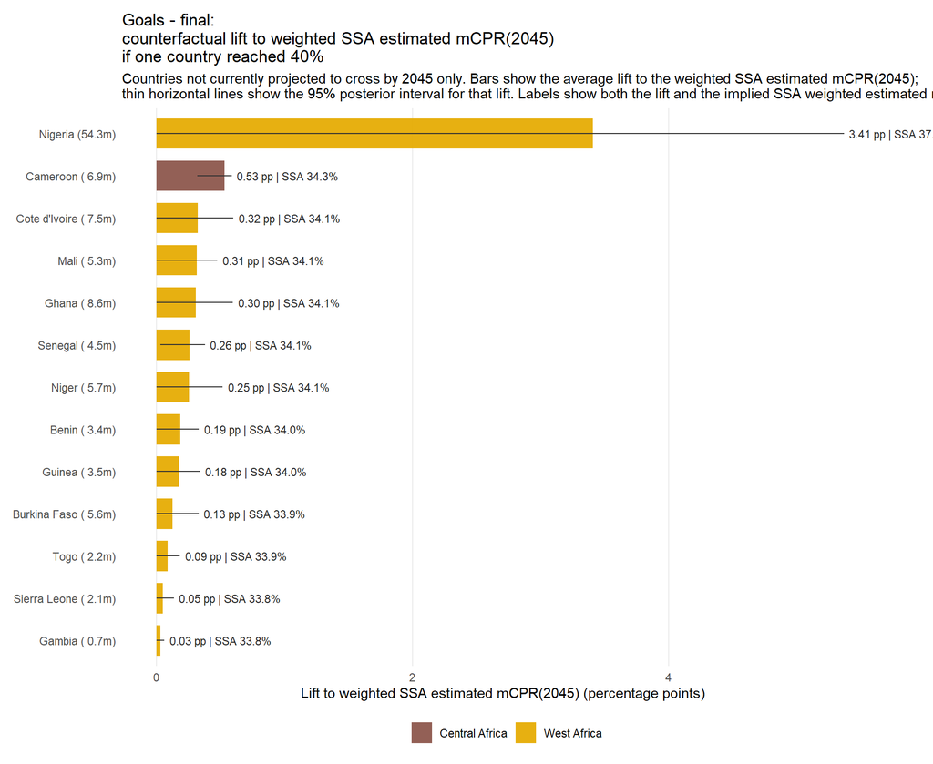

```r
ggplot(
  ssa_goal_final_counterfactual_lift,
  aes(x = lift_if_hit_40_pp, y = geography_label_plot, fill = region)
) +
  geom_col(width = 0.72, alpha = 0.94) +
  geom_segment(
    aes(
      x = lift_if_hit_40_p05,
      xend = lift_if_hit_40_p95,
      y = geography_label_plot,
      yend = geography_label_plot
    ),
    inherit.aes = FALSE,
    color = "grey20",
    linewidth = 0.5
  ) +
  geom_text(
    aes(x = label_x, label = label_text),
    hjust = 0,
    size = 3.0,
    color = "grey15"
  ) +
  coord_cartesian(clip = "off") +
  scale_fill_manual(values = region_palette) +
  theme_minimal(base_size = 10.9) +
  theme(
    legend.position = "bottom",
    legend.title = element_blank(),
    panel.grid.minor = element_blank(),
    panel.grid.major.y = element_blank(),
    axis.text.y = element_text(size = 8.7),
    plot.margin = margin(10, 38, 10, 10)
  ) +
  labs(
    title = "Goals - final:\ncounterfactual lift to weighted SSA estimated mCPR(2045)\nif one country reached 40%",
    subtitle = paste0(
      "Countries not currently projected to cross by ", ssa_goal_final_target_year,
      " only. Bars show the average lift to the weighted SSA estimated mCPR(2045);\n",
      "thin horizontal lines show the 95% posterior interval for that lift. Labels show both the lift and the implied SSA weighted estimated mCPR(2045)."
    ),
    x = "Lift to weighted SSA estimated mCPR(2045) (percentage points)",
    y = NULL
  )
```

### 24.20.13 Which countries have the most leverage on the weighted SSA estimated mCPR(2025)?

This is a **leave-one-out leverage** diagnostic, not just a population ranking. For each country, we remove that country, renormalize the remaining SSA weights, and then measure how much the weighted SSA estimated `mCPR(2025)` would change.

That means: a) large countries matter more; b) but countries close to the weighted SSA mean matter less than similarly large countries far above or below it; c) positive bars mean the country is pulling the weighted SSA mean upward, while negative bars mean it is pulling the weighted SSA mean downward.

```r
ssa_goal_final_region_p2025_mean <- ssa_region_goals_summary$p2025_mean
ssa_goal_final_region_p2045_mean <- mean(ssa_region_p2045_draws_final)

ssa_goal_final_leverage_2025 <- ssa_goal_final_country_rows %>%
  mutate(
    p_country_mean = current_p2025_pct / 100,
    leave_one_out_mean = (ssa_goal_final_region_p2025_mean - weight_share_ssa * p_country_mean) /
      pmax(1 - weight_share_ssa, 1e-9),
    leverage_shift_pp = 100 * (ssa_goal_final_region_p2025_mean - leave_one_out_mean),
    leverage_shift_abs_pp = abs(leverage_shift_pp),
    leverage_direction = if_else(
      leverage_shift_pp >= 0,
      "Lifts weighted SSA mean",
      "Pulls weighted SSA mean down"
    )
  ) %>%
  arrange(desc(leverage_shift_abs_pp), desc(leverage_shift_pp), geography)

ssa_goal_final_leverage_2025 <- ssa_goal_final_leverage_2025 %>%
  mutate(
    geography_label_plot = factor(
      geography_label,
      levels = rev(ssa_goal_final_leverage_2025$geography_label),
      ordered = TRUE
    )
  )

ssa_goal_final_leverage_2045 <- ssa_goal_final_country_rows %>%
  mutate(
    p_country_mean = current_p2045_pct / 100,
    leave_one_out_mean = (ssa_goal_final_region_p2045_mean - weight_share_ssa * p_country_mean) /
      pmax(1 - weight_share_ssa, 1e-9),
    leverage_shift_pp = 100 * (ssa_goal_final_region_p2045_mean - leave_one_out_mean),
    leverage_shift_abs_pp = abs(leverage_shift_pp),
    leverage_direction = if_else(
      leverage_shift_pp >= 0,
      "Lifts weighted SSA mean",
      "Pulls weighted SSA mean down"
    )
  ) %>%
  arrange(desc(leverage_shift_abs_pp), desc(leverage_shift_pp), geography)

ssa_goal_final_leverage_2045 <- ssa_goal_final_leverage_2045 %>%
  mutate(
    geography_label_plot = factor(
      geography_label,
      levels = rev(ssa_goal_final_leverage_2045$geography_label),
      ordered = TRUE
    )
  )

ssa_goal_final_leverage_cols <- c(
  "Lifts weighted SSA mean" = "#047857",
  "Pulls weighted SSA mean down" = "#B91C1C"
)
```

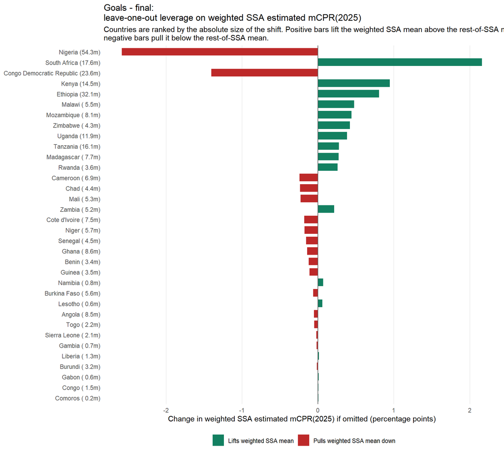

```r
ggplot(
  ssa_goal_final_leverage_2025,
  aes(x = leverage_shift_pp, y = geography_label_plot, fill = leverage_direction)
) +
  geom_col(width = 0.72, alpha = 0.94) +
  geom_vline(xintercept = 0, color = "grey35", linewidth = 0.5) +
  scale_fill_manual(values = ssa_goal_final_leverage_cols) +
  theme_minimal(base_size = 10.9) +
  theme(
    legend.position = "bottom",
    legend.title = element_blank(),
    panel.grid.minor = element_blank(),
    panel.grid.major.y = element_blank(),
    axis.text.y = element_text(size = 8.7)
  ) +
  labs(
    title = "Goals - final:\nleave-one-out leverage on weighted SSA estimated mCPR(2025)",
    subtitle = "Countries are ranked by the absolute size of the shift. Positive bars lift the weighted SSA mean above the rest-of-SSA mean;\nnegative bars pull it below the rest-of-SSA mean.",
    x = "Change in weighted SSA estimated mCPR(2025) if omitted (percentage points)",
    y = NULL
  )
```

### 24.20.14 Which countries have the most leverage on the weighted SSA estimated mCPR(2045)?

This repeats the same leave-one-out leverage idea, but now for the fitted `2045` endpoint. It answers a forward-looking question: which countries are doing the most to pull the weighted SSA estimated `mCPR(2045)` upward or downward under the fitted trajectory?

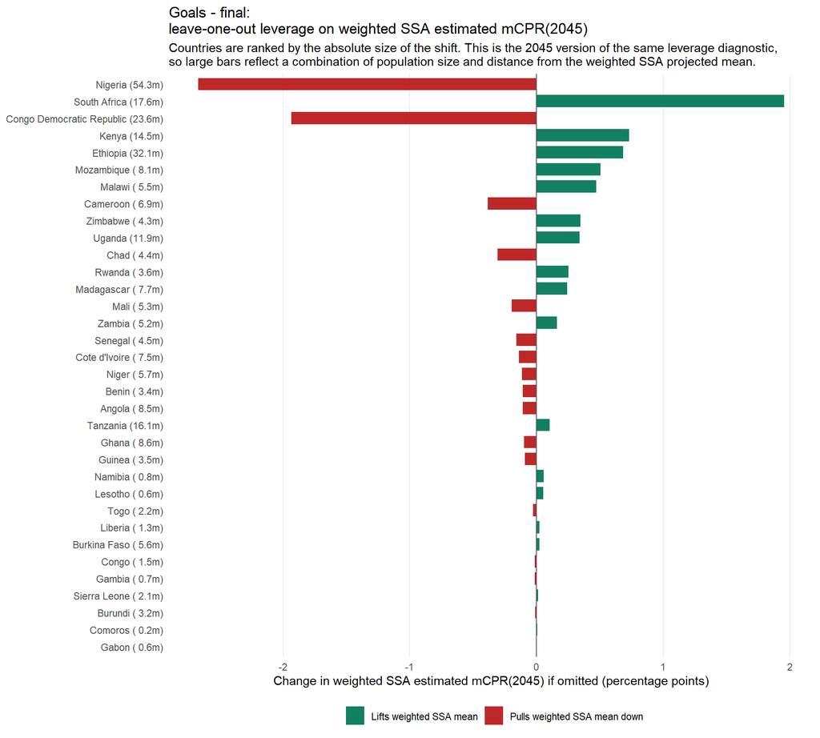

```r
ggplot(
  ssa_goal_final_leverage_2045,
  aes(x = leverage_shift_pp, y = geography_label_plot, fill = leverage_direction)
) +
  geom_col(width = 0.72, alpha = 0.94) +
  geom_vline(xintercept = 0, color = "grey35", linewidth = 0.5) +
  scale_fill_manual(values = ssa_goal_final_leverage_cols) +
  theme_minimal(base_size = 10.9) +
  theme(
    legend.position = "bottom",
    legend.title = element_blank(),
    panel.grid.minor = element_blank(),
    panel.grid.major.y = element_blank(),
    axis.text.y = element_text(size = 8.7)
  ) +
  labs(
    title = "Goals - final:\nleave-one-out leverage on weighted SSA estimated mCPR(2045)",
    subtitle = "Countries are ranked by the absolute size of the shift. This is the 2045 version of the same leverage diagnostic,\nso large bars reflect a combination of population size and distance from the weighted SSA projected mean.",
    x = "Change in weighted SSA estimated mCPR(2045) if omitted (percentage points)",
    y = NULL
  )
```

### 24.20.15 Counterfactual weighted SSA trajectories if one priority country reached 40% by 2045

This is the trajectory version of the leverage idea. We start from the fitted weighted SSA regional trajectory, then take one priority country at a time and ask: if that country were instead brought to `40%` by `2045`, how much higher would the weighted SSA path sit?

```r
smoothstep_counterfactual <- function(x) {
  x <- pmin(pmax(x, 0), 1)
  x^2 * (3 - 2 * x)
}

ssa_goal_final_priority_counterfactual_meta <- ssa_goal_final_country_rows %>%
  filter(geography %in% ssa_goal_final_priority_geographies) %>%
  mutate(
    on_track_by_goal = trajectory_status_final %in% c(
      "Already crossed",
      paste0("Projected to cross by ", ssa_goal_final_target_year)
    ),
    scenario_gap_to_40 = pmax(target_mcpr_40 - current_p2045_pct / 100, 0),
    scenario_lift_2045_pp = 100 * weight_share_ssa * scenario_gap_to_40
  ) %>%
  filter(!on_track_by_goal, scenario_gap_to_40 > 0) %>%
  arrange(desc(scenario_lift_2045_pp), geography) %>%
  mutate(
    leverage_rank = row_number(),
    leverage_tier = if_else(leverage_rank <= 3, "Top leverage scenario", "Other leverage scenario"),
    scenario_panel_label = paste0("If ", geography, " hits 40% by ", ssa_goal_final_target_year),
    scenario_display_label = paste0("If ", geography, " hits goal")
  )

ssa_goal_final_priority_counterfactual_meta <- ssa_goal_final_priority_counterfactual_meta %>%
  mutate(
    scenario_panel_label = factor(
      scenario_panel_label,
      levels = scenario_panel_label,
      ordered = TRUE
    )
  )

ssa_goal_final_priority_counterfactual_cols <- c(
  "Nigeria" = "#4E79A7",
  "Ethiopia" = "#F28E2B",
  "Burkina Faso" = "#59A14F",
  "Cote d'Ivoire" = "#E15759",
  "Senegal" = "#76B7B2",
  "Niger" = "#B07AA1"
)

ssa_goal_final_region_baseline_2025_2045 <- ssa_goal_final_traj_region %>%
  filter(year >= 2025, year <= ssa_goal_final_target_year) %>%
  transmute(
    year,
    baseline_ssa_mcpr_pct = 100 * p_mean
  )

ssa_goal_final_weighted_ssa_p2025_pct <- ssa_goal_final_region_baseline_2025_2045 %>%
  filter(year == 2025) %>%
  pull(baseline_ssa_mcpr_pct)

ssa_goal_final_priority_counterfactual_ymin <- 20
ssa_goal_final_priority_counterfactual_ymax <- 60

ssa_goal_final_priority_counterfactual_plot <- bind_rows(
  lapply(seq_len(nrow(ssa_goal_final_priority_counterfactual_meta)), function(i) {
    meta_i <- ssa_goal_final_priority_counterfactual_meta[i, ]
    baseline_country_path <- ssa_goal_final_traj_country %>%
      filter(geography == meta_i$geography, year >= 2025, year <= ssa_goal_final_target_year) %>%
      arrange(year)

    tibble(
      geography = meta_i$geography,
      geography_label = meta_i$geography_label,
      scenario_panel_label = meta_i$scenario_panel_label,
      leverage_rank = meta_i$leverage_rank,
      leverage_tier = meta_i$leverage_tier,
      year = baseline_country_path$year,
      year_progress = (baseline_country_path$year - 2025) / (ssa_goal_final_target_year - 2025),
      baseline_country_mcpr = baseline_country_path$p_mean,
      scenario_country_mcpr = pmin(
        baseline_country_path$p_mean +
          meta_i$scenario_gap_to_40 * smoothstep_counterfactual(year_progress),
        target_mcpr_40
      )
    ) %>%
      left_join(ssa_goal_final_region_baseline_2025_2045, by = "year") %>%
      mutate(
        scenario_ssa_mcpr_pct = baseline_ssa_mcpr_pct +
          100 * meta_i$weight_share_ssa * (scenario_country_mcpr - baseline_country_mcpr),
        scenario_lift_pp = scenario_ssa_mcpr_pct - baseline_ssa_mcpr_pct
      )
  })
)

ssa_goal_final_priority_counterfactual_labels <- ssa_goal_final_priority_counterfactual_plot %>%
  group_by(geography, geography_label, scenario_panel_label, leverage_rank, leverage_tier) %>%
  filter(year == max(year)) %>%
  ungroup() %>%
  left_join(
    ssa_goal_final_priority_counterfactual_meta %>%
      select(geography, scenario_display_label),
    by = "geography"
  ) %>%
  mutate(
    label_text = paste0(
      scenario_display_label,
      "\n+",
      format(round(scenario_lift_pp, 2), nsmall = 2),
      " pp\nSSA ",
      format(round(scenario_ssa_mcpr_pct, 1), nsmall = 1),
      "%"
    ),
    label_x = ssa_goal_final_target_year,
    label_y = pmin(
      scenario_ssa_mcpr_pct + 1.4,
      ssa_goal_final_priority_counterfactual_ymax - 1.1
    )
  )

ssa_goal_final_priority_counterfactual_lift_labels <- ssa_goal_final_priority_counterfactual_plot %>%
  group_by(geography, geography_label, scenario_panel_label, leverage_rank, leverage_tier) %>%
  filter(year == max(year)) %>%
  ungroup() %>%
  left_join(
    ssa_goal_final_priority_counterfactual_meta %>%
      select(geography, scenario_display_label),
    by = "geography"
  ) %>%
  mutate(
    label_text = paste0(
      scenario_display_label,
      "\n+",
      format(round(scenario_lift_pp, 2), nsmall = 2),
      " pp"
    ),
    label_x = ssa_goal_final_target_year,
    label_y = scenario_lift_pp + 0.08
  )

ssa_goal_final_priority_counterfactual_2045_summary <- ssa_goal_final_country_rows %>%
  filter(geography %in% ssa_goal_final_priority_geographies) %>%
  transmute(
    geography,
    region,
    weight_share_ssa,
    baseline_country_2045_pct = current_p2045_pct,
    counterfactual_country_2045_pct = pmax(current_p2045_pct, 40),
    baseline_ssa_2045_pct = ssa_goal_final_weighted_ssa_p2045_pct,
    counterfactual_ssa_2045_pct =
      ssa_goal_final_weighted_ssa_p2045_pct +
      weight_share_ssa * (pmax(current_p2045_pct, 40) - current_p2045_pct),
    shift_from_baseline_pp = counterfactual_ssa_2045_pct - ssa_goal_final_weighted_ssa_p2045_pct,
    trajectory_status_final
  ) %>%
  mutate(
    gap_to_40_after_scenario_pp = pmax(40 - counterfactual_ssa_2045_pct, 0),
    scenario_display_label = paste0("If ", geography, " hits goal"),
    bar_label = paste0(
      format(round(counterfactual_ssa_2045_pct, 1), nsmall = 1),
      "% | +",
      format(round(shift_from_baseline_pp, 2), nsmall = 2),
      " pp"
    )
  ) %>%
  arrange(desc(shift_from_baseline_pp), geography) %>%
  mutate(
    scenario_display_label_plot = factor(
      scenario_display_label,
      levels = rev(scenario_display_label),
      ordered = TRUE
    ),
    label_x = shift_from_baseline_pp + 0.06
  )

readr::write_csv(
  ssa_goal_final_priority_counterfactual_2045_summary %>%
    select(
      geography,
      region,
      trajectory_status_final,
      weight_share_ssa,
      baseline_country_2045_pct,
      counterfactual_country_2045_pct,
      baseline_ssa_2045_pct,
      counterfactual_ssa_2045_pct,
      shift_from_baseline_pp,
      gap_to_40_after_scenario_pp
    ),
  params$counterfactual_csv
)
```

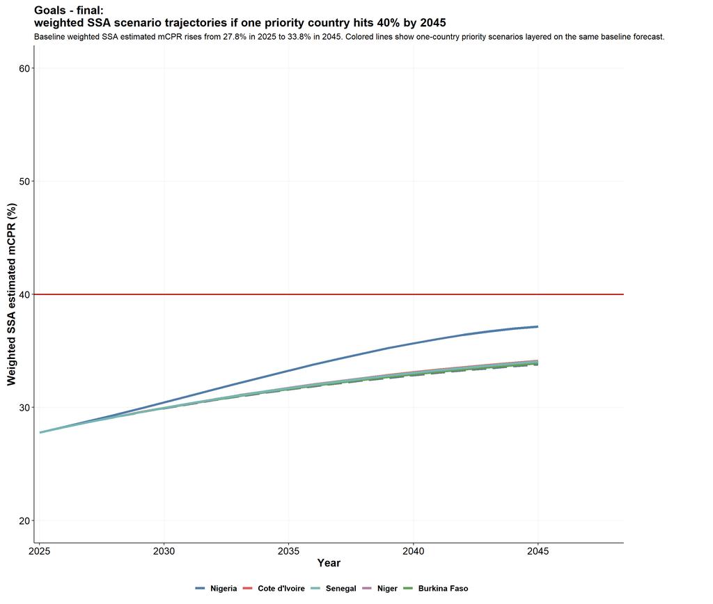

```r
ggplot(ssa_goal_final_priority_counterfactual_plot, aes(x = year, y = scenario_ssa_mcpr_pct, color = geography)) +
  geom_hline(
    yintercept = 40,
    color = "#B91C1C",
    linewidth = 0.9
  ) +
  geom_line(
    data = ssa_goal_final_region_baseline_2025_2045,
    aes(x = year, y = baseline_ssa_mcpr_pct),
    inherit.aes = FALSE,
    color = "#64748B",
    linewidth = 1.45,
    linetype = "longdash"
  ) +
  geom_line(linewidth = 1.6, alpha = 0.98) +
  ggrepel::geom_label_repel(
    data = ssa_goal_final_priority_counterfactual_labels,
    aes(
      x = label_x,
      y = label_y,
      label = label_text,
      color = geography
    ),
    inherit.aes = FALSE,
    direction = "y",
    hjust = 0,
    nudge_x = 0.9,
    size = 3.55,
    fontface = "bold",
    lineheight = 0.92,
    label.padding = unit(0.18, "lines"),
    label.size = 0.18,
    segment.color = "grey45",
    segment.alpha = 0.5,
    segment.size = 0.28,
    fill = "white",
    show.legend = FALSE
  ) +
  scale_color_manual(
    values = ssa_goal_final_priority_counterfactual_cols,
    breaks = ssa_goal_final_priority_counterfactual_meta$geography,
    labels = ssa_goal_final_priority_counterfactual_meta$geography
  ) +
  scale_fill_manual(
    values = ssa_goal_final_priority_counterfactual_cols,
    breaks = ssa_goal_final_priority_counterfactual_meta$geography,
    labels = ssa_goal_final_priority_counterfactual_meta$geography
  ) +
  scale_x_continuous(
    breaks = seq(2025, ssa_goal_final_target_year, by = 5),
    limits = c(2025, ssa_goal_final_target_year),
    expand = expansion(mult = c(0.01, 0.08))
  ) +
  coord_cartesian(
    xlim = c(2025, ssa_goal_final_target_year + 1.7),
    ylim = c(
      ssa_goal_final_priority_counterfactual_ymin,
      ssa_goal_final_priority_counterfactual_ymax
    ),
    clip = "off"
  ) +
  theme_minimal(base_size = 13.2) +
  theme(
    panel.grid.minor = element_blank(),
    panel.grid.major = element_line(color = "#E5E7EB", linewidth = 0.3),
    axis.text = element_text(size = 13.8, color = "black"),
    axis.title = element_text(size = 15.8, face = "bold", color = "black"),
    axis.line = element_line(color = "black", linewidth = 0.45),
    axis.ticks = element_line(color = "black", linewidth = 0.38),
    legend.position = "bottom",
    legend.title = element_blank(),
    legend.text = element_text(size = 11.8, face = "bold", color = "black"),
    plot.title = element_text(size = 16.7, face = "bold"),
    plot.subtitle = element_text(size = 11.9, lineheight = 1.04),
    plot.margin = margin(8, 130, 8, 10)
  ) +
  labs(
    title = "Goals - final:\nweighted SSA scenario trajectories if one priority country hits 40% by 2045",
    subtitle = paste0(
      "Baseline weighted SSA estimated mCPR rises from ",
      format(round(ssa_goal_final_weighted_ssa_p2025_pct, 1), nsmall = 1),
      "% in 2025 to ",
      format(round(ssa_goal_final_weighted_ssa_p2045_pct, 1), nsmall = 1),
      "% in 2045. Colored lines show one-country priority scenarios layered on the same baseline forecast."
    ),
    x = "Year",
    y = "Weighted SSA estimated mCPR (%)",
    color = "Scenario"
  )
```

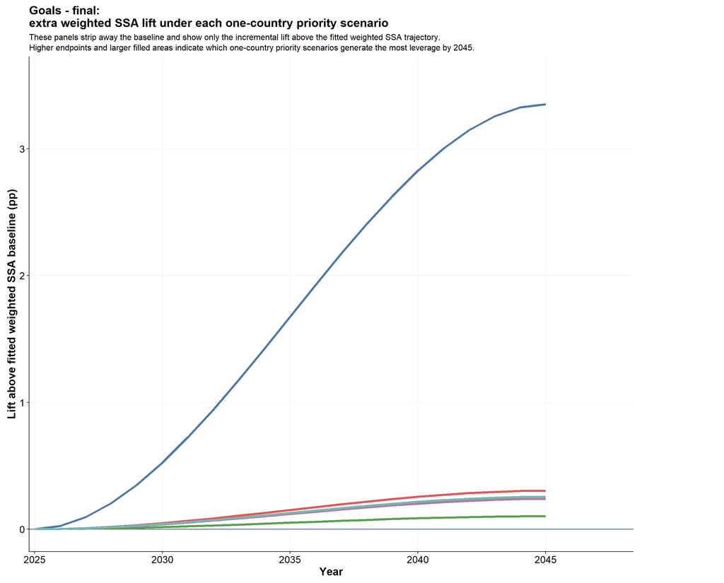

```r
ggplot(
  ssa_goal_final_priority_counterfactual_plot,
  aes(x = year, y = scenario_lift_pp, color = geography, fill = geography)
) +
  geom_hline(yintercept = 0, color = "#64748B", linewidth = 0.7) +
  geom_line(linewidth = 1.55, show.legend = FALSE) +
  ggrepel::geom_label_repel(
    data = ssa_goal_final_priority_counterfactual_lift_labels,
    aes(x = label_x, y = label_y, label = label_text, color = geography),
    inherit.aes = FALSE,
    hjust = 0,
    nudge_x = 0.9,
    size = 3.55,
    fontface = "bold",
    label.padding = unit(0.18, "lines"),
    label.size = 0.18,
    segment.color = "grey45",
    segment.alpha = 0.5,
    segment.size = 0.28,
    fill = "white",
    show.legend = FALSE
  ) +
  scale_color_manual(values = ssa_goal_final_priority_counterfactual_cols) +
  scale_fill_manual(values = ssa_goal_final_priority_counterfactual_cols) +
  scale_x_continuous(
    breaks = seq(2025, ssa_goal_final_target_year, by = 5),
    limits = c(2025, ssa_goal_final_target_year),
    expand = expansion(mult = c(0.01, 0.08))
  ) +
  coord_cartesian(
    xlim = c(2025, ssa_goal_final_target_year + 1.7),
    ylim = c(
      0,
      max(ssa_goal_final_priority_counterfactual_lift_labels$label_y, na.rm = TRUE) + 0.12
    ),
    clip = "off"
  ) +
  theme_minimal(base_size = 13.2) +
  theme(
    panel.grid.minor = element_blank(),
    panel.grid.major = element_line(color = "#E5E7EB", linewidth = 0.3),
    axis.text = element_text(size = 13.8, color = "black"),
    axis.title = element_text(size = 15.8, face = "bold", color = "black"),
    axis.line = element_line(color = "black", linewidth = 0.45),
    axis.ticks = element_line(color = "black", linewidth = 0.38),
    plot.title = element_text(size = 16.7, face = "bold"),
    plot.subtitle = element_text(size = 11.9, lineheight = 1.04),
    plot.margin = margin(8, 130, 8, 10)
  ) +
  labs(
    title = "Goals - final:\nextra weighted SSA lift under each one-country priority scenario",
    subtitle = paste0(
      "These panels strip away the baseline and show only the incremental lift above the fitted weighted SSA trajectory.\n",
      "Higher endpoints and larger filled areas indicate which one-country priority scenarios generate the most leverage by ",
      ssa_goal_final_target_year,
      "."
    ),
    x = "Year",
    y = "Lift above fitted weighted SSA baseline (pp)"
  )
```

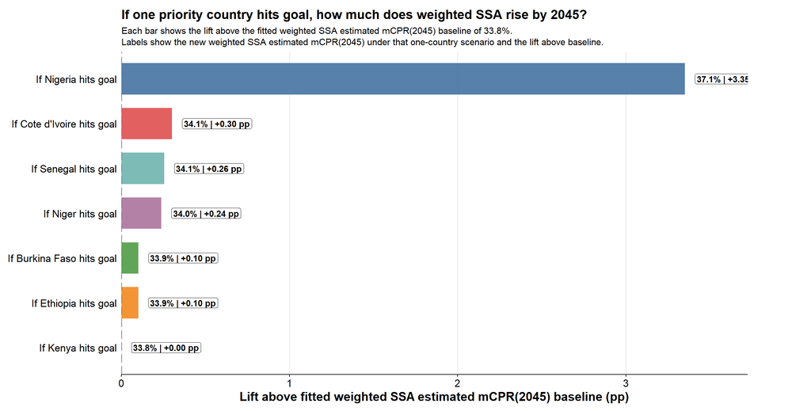

```r
ggplot(
  ssa_goal_final_priority_counterfactual_2045_summary,
  aes(
    x = shift_from_baseline_pp,
    y = scenario_display_label_plot,
    fill = geography
  )
) +
  geom_col(width = 0.7, alpha = 0.95) +
  geom_label(
    aes(x = label_x, label = bar_label),
    hjust = 0,
    size = 3.85,
    fontface = "bold",
    color = "black",
    fill = scales::alpha("white", 0.97),
    label.size = 0.18,
    label.padding = unit(0.16, "lines")
  ) +
  geom_vline(xintercept = 0, color = "#64748B", linetype = "longdash", linewidth = 0.85) +
  scale_fill_manual(values = ssa_goal_final_priority_counterfactual_cols, guide = "none") +
  scale_x_continuous(
    limits = c(
      0,
      max(ssa_goal_final_priority_counterfactual_2045_summary$label_x, na.rm = TRUE) + 0.24
    ),
    breaks = pretty,
    expand = expansion(mult = c(0, 0.02))
  ) +
  theme_minimal(base_size = 13.0) +
  theme(
    panel.grid.minor = element_blank(),
    panel.grid.major.y = element_blank(),
    axis.text = element_text(size = 13.2, color = "black"),
    axis.title = element_text(size = 15.4, face = "bold", color = "black"),
    axis.line.x = element_line(color = "black", linewidth = 0.45),
    axis.ticks.x = element_line(color = "black", linewidth = 0.38),
    plot.title = element_text(size = 16.3, face = "bold"),
    plot.subtitle = element_text(size = 11.7, lineheight = 1.03),
    plot.margin = margin(12, 80, 10, 10)
  ) +
  labs(
    title = "If one priority country hits goal, how much does weighted SSA rise by 2045?",
    subtitle = paste0(
      "Each bar shows the lift above the fitted weighted SSA estimated mCPR(2045) baseline of ",
      format(round(ssa_goal_final_weighted_ssa_p2045_pct, 1), nsmall = 1),
      "%.\nLabels show the new weighted SSA estimated mCPR(2045) under that one-country scenario and the lift above baseline."
    ),
    x = "Lift above fitted weighted SSA estimated mCPR(2045) baseline (pp)",
    y = NULL
  )
```

```r
ssa_goal_final_priority_counterfactual_2045_table <- bind_rows(
  tibble(
    Scenario = "Baseline (no change)",
    ssa_mcpr_2045 = ssa_goal_final_weighted_ssa_p2045_pct,
    shift_from_baseline_pp = 0
  ),
  tibble(
    Scenario = "Priority geographies baseline",
    ssa_mcpr_2045 = ssa_goal_final_priority_row$current_p2045_pct,
    shift_from_baseline_pp =
      ssa_goal_final_priority_row$current_p2045_pct - ssa_goal_final_weighted_ssa_p2045_pct
  ),
  ssa_goal_final_priority_counterfactual_2045_summary %>%
    transmute(
      Scenario = paste0(geography, " hits 40%"),
      ssa_mcpr_2045 = counterfactual_ssa_2045_pct,
      shift_from_baseline_pp = shift_from_baseline_pp
    )
) %>%
  mutate(
    ssa_mcpr_2045 = paste0(
      "<span style='display:inline-block; min-width:5.4em; text-align:right;'>",
      format(round(ssa_mcpr_2045, 1), nsmall = 1),
      "</span>"
    ),
    shift_from_baseline_pp = paste0(
      "<span style='display:inline-block; min-width:7.2em; text-align:right; padding-left:1.2em;'>",
      format(round(shift_from_baseline_pp, 2), nsmall = 2),
      "</span>"
    )
  )

knitr::kable(
  ssa_goal_final_priority_counterfactual_2045_table,
  format = "html",
  escape = FALSE,
  col.names = c(
    "Scenario",
    "SSA mCPR(2045)",
    "<span style='display:inline-block; min-width:7.6em; text-align:right; padding-left:1.2em;'>Shift from baseline<br>(pp)</span>"
  ),
  caption = paste0(
    "Counterfactual weighted SSA 2045 outcomes under priority-geography scenarios."
  ),
  align = c("l", "r", "r"),
  table.attr = "style='width:auto;'"
)
```

Counterfactual weighted SSA 2045 outcomes under priority-geography scenarios.

| Scenario | SSA mCPR(2045) | Shift from baseline (pp) |
| --- | --- | --- |
| Baseline (no change) | 33.8 | 0.00 |
| Priority geographies baseline | 31.0 | -2.81 |
| Nigeria hits 40% | 37.1 | 3.35 |
| Cote d’Ivoire hits 40% | 34.1 | 0.30 |
| Senegal hits 40% | 34.1 | 0.26 |
| Niger hits 40% | 34.0 | 0.24 |
| Burkina Faso hits 40% | 33.9 | 0.10 |
| Ethiopia hits 40% | 33.9 | 0.10 |
| Kenya hits 40% | 33.8 | 0.00 |

### 24.20.16 Estimated mCPR(2025) across SSA, the weighted priority geographies, and all countries

This closes the goals section with one common-footing level view. The first bar is the weighted SSA estimate for `mCPR(2025)`, the second bar is the weighted estimate across the seven priority geographies, the next seven bars are the priority countries themselves, and the remaining bars are all other SSA countries.

Interpretation: a) blue marks the weighted SSA benchmark; b) orange marks the weighted priority-geography benchmark; c) green marks the seven priority countries; d) grey marks every other SSA country; e) the dashed red line marks the `40%` goal.

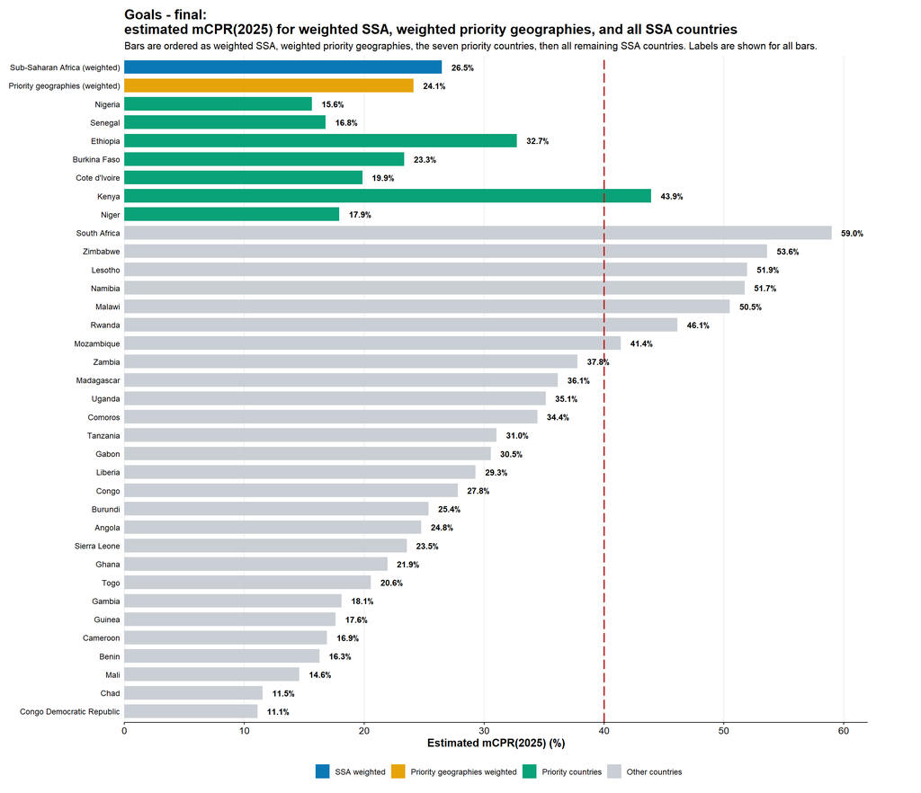

```r
ssa_goal_final_p2025_level_plot <- ssa_goal_final_all %>%
  mutate(
    plot_group_order = case_when(
      geography == "Sub-Saharan Africa (weighted)" ~ 1L,
      geography == ssa_goal_final_priority_label ~ 2L,
      geography %in% ssa_goal_final_priority_geographies ~ 3L,
      TRUE ~ 4L
    ),
    priority_country_order = match(geography, ssa_goal_final_priority_geographies),
    display_label = geography,
    goal_fill_group = factor(case_when(
      geography == "Sub-Saharan Africa (weighted)" ~ "SSA weighted",
      geography == ssa_goal_final_priority_label ~ "Priority geographies weighted",
      geography %in% ssa_goal_final_priority_geographies ~ "Priority countries",
      TRUE ~ "Other countries"
    ), levels = ssa_goal_final_focus_group_levels)
  ) %>%
  arrange(
    plot_group_order,
    priority_country_order,
    desc(current_p2025_pct),
    geography
  ) %>%
  mutate(
    display_label = factor(display_label, levels = rev(display_label), ordered = TRUE)
  )

ssa_goal_final_p2025_level_labels <- ssa_goal_final_p2025_level_plot %>%
  mutate(
    label_text = paste0(format(round(current_p2025_pct, 1), nsmall = 1), "%"),
    label_x = current_p2025_pct + 0.8
  )

ssa_goal_final_p2025_level_xmax <- max(
  c(
    ssa_goal_final_p2025_level_plot$current_p2025_pct,
    ssa_goal_final_p2025_level_labels$label_x
  ),
  na.rm = TRUE
) + 1

ggplot(
  ssa_goal_final_p2025_level_plot,
  aes(x = current_p2025_pct, y = display_label, fill = goal_fill_group)
) +
  geom_col(width = 0.74, alpha = 0.96) +
  geom_vline(xintercept = 40, color = "#B91C1C", linetype = "longdash", linewidth = 0.75) +
  geom_text(
    data = ssa_goal_final_p2025_level_labels,
    aes(x = label_x, y = display_label, label = label_text),
    inherit.aes = FALSE,
    hjust = 0,
    size = 3.35,
    fontface = "bold",
    color = "black"
  ) +
  scale_fill_manual(values = ssa_goal_final_focus_group_cols) +
  scale_x_continuous(
    limits = c(0, ssa_goal_final_p2025_level_xmax),
    breaks = pretty,
    expand = expansion(mult = c(0, 0.02))
  ) +
  coord_cartesian(clip = "off") +
  theme_minimal(base_size = 11.2) +
  theme(
    legend.position = "bottom",
    legend.title = element_blank(),
    panel.grid.minor = element_blank(),
    panel.grid.major.y = element_blank(),
    axis.text.y = element_text(size = 8.9, color = "black"),
    axis.text.x = element_text(size = 10.5, color = "black"),
    axis.title.x = element_text(size = 12.2, face = "bold", color = "black"),
    axis.line.x = element_line(color = "black", linewidth = 0.42),
    axis.ticks.x = element_line(color = "black", linewidth = 0.36),
    plot.title = element_text(size = 15.3, face = "bold"),
    plot.subtitle = element_text(size = 11.1, lineheight = 1.03),
    plot.margin = margin(10, 60, 10, 10)
  ) +
  labs(
    title = "Goals - final:\nestimated mCPR(2025) for weighted SSA, weighted priority geographies, and all SSA countries",
    subtitle = "Bars are ordered as weighted SSA, weighted priority geographies, the seven priority countries, then all remaining SSA countries. Labels are shown for all bars.",
    x = "Estimated mCPR(2025) (%)",
    y = NULL,
    fill = NULL
  )
```

## 24.21 SSA outliers relative to the weighted regional benchmark

This section asks a simple comparative question: which countries sit above or below the weighted SSA benchmark on two core dimensions: a) fitted ceiling `K`; b) current model-implied annual growth at 2026.

The regional benchmark is always the population-weighted SSA benchmark derived from the main country model.

```r
ssa_stage_cols <- c(
  "Stage 1: initial" = "#D55E00",
  "Stage 2: diffusion" = "#0072B2",
  "Stage 3: plateau" = "#009E73"
)

ssa_outlier_k_diff_draws <- sweep(
  ssa_K_draws,
  1,
  ssa_region_K_draws,
  FUN = "-"
)

ssa_outlier_growth_diff_draws <- sweep(
  dpdt_mat[, ssa_country_cols, drop = FALSE],
  1,
  ssa_region_dpdt_2026_draws,
  FUN = "-"
)

ssa_outlier_table <- ssa_goals_country_table %>%
  transmute(
    country,
    region,
    women_15_49,
    women_15_49_millions = women_15_49 / 1e6,
    K_mean,
    model_dpdt_2026_pp_per_year,
    t0_year_mean,
    years_since_t0_2026,
    s_curve_stage_2026
  ) %>%
  mutate(
    k_diff_vs_ssa_pp = 100 * colMeans(ssa_outlier_k_diff_draws),
    growth_diff_vs_ssa_pp_per_year = 100 * colMeans(ssa_outlier_growth_diff_draws),
    prob_k_above_ssa = colMeans(ssa_outlier_k_diff_draws > 0),
    prob_growth_above_ssa = colMeans(ssa_outlier_growth_diff_draws > 0)
  )

ssa_outlier_k_scale <- stats::sd(ssa_outlier_table$k_diff_vs_ssa_pp, na.rm = TRUE)
ssa_outlier_growth_scale <- stats::sd(ssa_outlier_table$growth_diff_vs_ssa_pp_per_year, na.rm = TRUE)
ssa_outlier_k_scale <- ifelse(is.finite(ssa_outlier_k_scale) && ssa_outlier_k_scale > 0, ssa_outlier_k_scale, 1)
ssa_outlier_growth_scale <- ifelse(is.finite(ssa_outlier_growth_scale) && ssa_outlier_growth_scale > 0, ssa_outlier_growth_scale, 1)

ssa_outlier_table <- ssa_outlier_table %>%
  mutate(
    outlier_quadrant = case_when(
      k_diff_vs_ssa_pp >= 0 & growth_diff_vs_ssa_pp_per_year >= 0 ~ "Higher K, higher growth than SSA",
      k_diff_vs_ssa_pp >= 0 & growth_diff_vs_ssa_pp_per_year < 0 ~ "Higher K, lower growth than SSA",
      k_diff_vs_ssa_pp < 0 & growth_diff_vs_ssa_pp_per_year >= 0 ~ "Lower K, higher growth than SSA",
      TRUE ~ "Lower K, lower growth than SSA"
    ),
    outlier_distance = sqrt(
      (k_diff_vs_ssa_pp / ssa_outlier_k_scale)^2 +
        (growth_diff_vs_ssa_pp_per_year / ssa_outlier_growth_scale)^2
    ),
    outlier_label_flag = case_when(
      country %in% c("Nigeria", "Congo Democratic Republic") ~ TRUE,
      outlier_distance >= quantile(outlier_distance, 0.86, na.rm = TRUE) ~ TRUE,
      TRUE ~ FALSE
    )
  )

ssa_outlier_quadrant_cols <- c(
  "Higher K, higher growth than SSA" = "#1D4ED8",
  "Higher K, lower growth than SSA" = "#D97706",
  "Lower K, higher growth than SSA" = "#059669",
  "Lower K, lower growth than SSA" = "#B91C1C"
)

ssa_region_rel_sat_2026_draws <- pmin(
  pmax(ssa_region_p2026_draws / ssa_region_K_draws, 1e-6),
  1 - 1e-6
)

ssa_region_stage_position_2026_draws <- qlogis(ssa_region_rel_sat_2026_draws)

ssa_region_inflection_year_draws <- apply(
  ssa_region_draws_k_horizon >=
    matrix(
      0.5 * ssa_region_K_draws,
      nrow = nrow(ssa_region_draws_k_horizon),
      ncol = ncol(ssa_region_draws_k_horizon)
    ),
  1,
  function(hit_vec) {
    idx <- which(hit_vec)
    if (length(idx) == 0) NA_real_ else ssa_region_k_horizon_years[min(idx)]
  }
)

ssa_region_stage1_2026 <- ssa_region_stage_position_2026_draws < -1.5
ssa_region_stage3_2026 <- ssa_region_stage_position_2026_draws > 1.5
ssa_region_stage2_2026 <- !(ssa_region_stage1_2026 | ssa_region_stage3_2026)

ssa_region_stage_summary <- tibble(
  geography = "Sub-Saharan Africa (weighted)",
  decision_year = 2026,
  p_2026_mean = mean(ssa_region_p2026_draws),
  K_mean = mean(ssa_region_K_draws),
  rel_sat_2026_mean = mean(ssa_region_rel_sat_2026_draws),
  stage_position_2026_mean = mean(ssa_region_stage_position_2026_draws),
  inflection_year_p50 = if (all(is.na(ssa_region_inflection_year_draws))) NA_real_ else median(ssa_region_inflection_year_draws, na.rm = TRUE),
  inflection_year_p05 = if (all(is.na(ssa_region_inflection_year_draws))) NA_real_ else quantile(ssa_region_inflection_year_draws, ci_lower, na.rm = TRUE),
  inflection_year_p95 = if (all(is.na(ssa_region_inflection_year_draws))) NA_real_ else quantile(ssa_region_inflection_year_draws, ci_upper, na.rm = TRUE),
  prob_stage1_initial_2026 = mean(ssa_region_stage1_2026),
  prob_stage2_diffusion_2026 = mean(ssa_region_stage2_2026),
  prob_stage3_plateau_2026 = mean(ssa_region_stage3_2026)
) %>%
  mutate(
    s_curve_stage_2026 = case_when(
      prob_stage1_initial_2026 >= prob_stage2_diffusion_2026 &
        prob_stage1_initial_2026 >= prob_stage3_plateau_2026 ~ "Stage 1: initial",
      prob_stage3_plateau_2026 >= prob_stage1_initial_2026 &
        prob_stage3_plateau_2026 >= prob_stage2_diffusion_2026 ~ "Stage 3: plateau",
      TRUE ~ "Stage 2: diffusion"
    )
  )

build_weighted_stage_view <- function(
  country_names,
  geography_label,
  weight_mode = c("population", "equal"),
  summary_prefix = "Weighted"
) {
  weight_mode <- match.arg(weight_mode)
  keep_countries <- intersect(country_names, ssa_country_order_vec)
  keep_cols <- match(keep_countries, ssa_country_order_vec)
  keep_weights <- if (weight_mode == "population") {
    ssa_weight_latest$women_15_49[match(keep_countries, ssa_weight_latest$country)]
  } else {
    rep(1, length(keep_countries))
  }
  keep_weights <- keep_weights / sum(keep_weights, na.rm = TRUE)

  keep_K_draws <- ssa_K_draws[, keep_cols, drop = FALSE]
  keep_t0_draws <- ssa_t0_draws[, keep_cols, drop = FALSE]
  keep_s_draws <- ssa_s_draws[, keep_cols, drop = FALSE]

  region_draws_horizon <- sapply(ssa_region_k_horizon_years, function(yy) {
    as.numeric(
      logistic_draws_at_year(keep_K_draws, keep_t0_draws, keep_s_draws, yy) %*%
        keep_weights
    )
  })

  if (is.vector(region_draws_horizon)) {
    region_draws_horizon <- matrix(
      region_draws_horizon,
      nrow = nrow(keep_K_draws),
      ncol = length(ssa_region_k_horizon_years)
    )
  }

  region_K_draws <- as.numeric(keep_K_draws %*% keep_weights)
  region_p2025_draws <- region_draws_horizon[, match(2025, ssa_region_k_horizon_years)]
  region_pgoal_draws <- region_draws_horizon[, match(ssa_goal_final_target_year, ssa_region_k_horizon_years)]
  region_rel_sat_2025_draws <- pmin(
    pmax(region_p2025_draws / region_K_draws, 1e-6),
    1 - 1e-6
  )
  region_stage_position_2025_draws <- qlogis(region_rel_sat_2025_draws)
```

```r
  region_inflection_year_draws <- apply(
    region_draws_horizon >=
      matrix(
        0.5 * region_K_draws,
        nrow = nrow(region_draws_horizon),
        ncol = ncol(region_draws_horizon)
      ),
    1,
    function(hit_vec) {
      idx <- which(hit_vec)
      if (length(idx) == 0) NA_real_ else ssa_region_k_horizon_years[min(idx)]
    }
  )

  region_crossing_draws <- apply(
    region_draws_horizon >= target_mcpr_40,
    1,
    function(hit_vec) {
      idx <- which(hit_vec)
      if (length(idx) == 0) NA_real_ else ssa_region_k_horizon_years[min(idx)]
    }
  )

  region_stage1_2025 <- region_stage_position_2025_draws < -1.5
  region_stage3_2025 <- region_stage_position_2025_draws > 1.5
  region_stage2_2025 <- !(region_stage1_2025 | region_stage3_2025)

  region_stage_summary <- tibble(
    geography = geography_label,
    p_2025_mean = mean(region_p2025_draws),
    K_mean = mean(region_K_draws),
    rel_sat_2025_mean = mean(region_rel_sat_2025_draws),
    stage_position_2025_mean = mean(region_stage_position_2025_draws),
    inflection_year_p50 = if (all(is.na(region_inflection_year_draws))) NA_real_ else median(region_inflection_year_draws, na.rm = TRUE),
    inflection_year_p05 = if (all(is.na(region_inflection_year_draws))) NA_real_ else quantile(region_inflection_year_draws, ci_lower, na.rm = TRUE),
    inflection_year_p95 = if (all(is.na(region_inflection_year_draws))) NA_real_ else quantile(region_inflection_year_draws, ci_upper, na.rm = TRUE),
    crossing_year_p50 = if (all(is.na(region_crossing_draws))) NA_real_ else median(region_crossing_draws, na.rm = TRUE),
    crossing_year_p05 = if (all(is.na(region_crossing_draws))) NA_real_ else quantile(region_crossing_draws, ci_lower, na.rm = TRUE),
    crossing_year_p95 = if (all(is.na(region_crossing_draws))) NA_real_ else quantile(region_crossing_draws, ci_upper, na.rm = TRUE),
    p_goal_year_mean = mean(region_pgoal_draws),
    p_goal_year_p05 = quantile(region_pgoal_draws, ci_lower, na.rm = TRUE),
    p_goal_year_p95 = quantile(region_pgoal_draws, ci_upper, na.rm = TRUE),
    prob_reach_40_by_goal_year = mean(!is.na(region_crossing_draws) & region_crossing_draws <= ssa_goal_final_target_year),
    prob_stage1_initial_2025 = mean(region_stage1_2025),
    prob_stage2_diffusion_2025 = mean(region_stage2_2025),
    prob_stage3_plateau_2025 = mean(region_stage3_2025)
  ) %>%
    mutate(
      s_curve_stage_2025 = case_when(
        prob_stage1_initial_2025 >= prob_stage2_diffusion_2025 &
          prob_stage1_initial_2025 >= prob_stage3_plateau_2025 ~ "Stage 1: initial",
        prob_stage3_plateau_2025 >= prob_stage1_initial_2025 &
          prob_stage3_plateau_2025 >= prob_stage2_diffusion_2025 ~ "Stage 3: plateau",
        TRUE ~ "Stage 2: diffusion"
      ),
      plot_end_year = 2060
    )

  region_stage_plot <- tibble(
    year = ssa_region_k_horizon_years,
    p_mean = colMeans(region_draws_horizon),
    p_p05 = apply(region_draws_horizon, 2, quantile, ci_lower, na.rm = TRUE),
    p_p95 = apply(region_draws_horizon, 2, quantile, ci_upper, na.rm = TRUE)
  ) %>%
    filter(year <= region_stage_summary$plot_end_year[[1]])

  region_stage_note <- paste0(
    "Stage at 2025: ", region_stage_summary$s_curve_stage_2025,
    "\n", summary_prefix, " K: ", round(100 * region_stage_summary$K_mean, 1), "%",
    "\n", summary_prefix, " estimated mCPR(2025): ", round(100 * region_stage_summary$p_2025_mean, 1), "%",
    "\n", summary_prefix, " estimated mCPR(", ssa_goal_final_target_year, "): ", round(100 * region_stage_summary$p_goal_year_mean, 1), "%",
    "\nP(reach 40% by ", ssa_goal_final_target_year, "): ", round(100 * region_stage_summary$prob_reach_40_by_goal_year, 1), "%",
    "\nInflection year: ", round(region_stage_summary$inflection_year_p50, 1),
    " (95% CrI ", round(region_stage_summary$inflection_year_p05, 1),
    "-", round(region_stage_summary$inflection_year_p95, 1), ")"
  )

  list(
    summary = region_stage_summary,
    plot = region_stage_plot,
    note = region_stage_note
  )
}

plot_weighted_ssa_stage_view <- function(
  stage_plot_df,
  stage_summary_df,
  stage_note_text,
  title_text,
  subtitle_text,
  k_label_prefix = "Weighted",
  y_axis_label = "Population-weighted model mCPR (%)"
) {
  stage_summary_plot_df <- if ("p_2025_plot_mean" %in% names(stage_summary_df)) {
    stage_summary_df %>%
      mutate(p_2025_plot_mean = dplyr::coalesce(p_2025_plot_mean, p_2025_mean))
  } else {
    stage_summary_df %>%
      mutate(p_2025_plot_mean = p_2025_mean)
  }
  stage_goal_y <- 40
  stage_k_y <- 100 * stage_summary_df$K_mean
  stage_year_min <- min(stage_plot_df$year, na.rm = TRUE)
  stage_year_mid <- (stage_year_min + 2060) / 2
  stage_label_x <- max(stage_plot_df$year, na.rm = TRUE) - 1.9
  stage_note_x <- min(stage_plot_df$year, na.rm = TRUE) + 0.15
  stage_goal_col <- "#B91C1C"
  stage_k_col <- "#6B4F1D"
  stage_curve_col <- "#15803D"
  stage_inflection_col <- "#1D4ED8"
  stage_goal_year_col <- "#374151"
  stage_current_col <- "#0F172A"
  stage_p2025_display_y <- 100 * stage_summary_df$p_2025_mean
  stage_p2025_plot_y <- 100 * stage_summary_plot_df$p_2025_plot_mean
  stage_p2025_label <- paste0("Estimated mCPR(2025): ", round(stage_p2025_display_y, 1), "%")
  stage_pgoal_y <- 100 * stage_summary_df$p_goal_year_mean
  stage_pgoal_label <- paste0(
    "Estimated mCPR(",
    ssa_goal_final_target_year,
    "): ",
    round(stage_pgoal_y, 1),
    "%"
  )
  stage_y_upper <- min(
    100,
    max(
      56,
      100 * max(stage_plot_df$p_p95, na.rm = TRUE) + 9,
      stage_k_y + 9,
      stage_p2025_plot_y + 8,
      stage_pgoal_y + 9,
      stage_goal_y + 10
    )
  )
  stage_pgoal_label_y <- ifelse(
    stage_pgoal_y <= stage_y_upper - 10,
    stage_pgoal_y + 3.2,
    stage_pgoal_y - 5.0
  )
  stage_pgoal_label_vjust <- ifelse(stage_pgoal_y <= stage_y_upper - 10, 0, 1)
  stage_reference_lines <- tibble::tibble(
    reference_label = c(
      "40% goal",
      "Fitted K",
      "Inflection year",
      paste0("Goal year (", ssa_goal_final_target_year, ")")
    ),
    reference_color = c(
      stage_goal_col,
      stage_k_col,
      stage_inflection_col,
      stage_goal_year_col
    ),
    reference_linetype = c(
      "solid",
      "dotted",
      "dotdash",
      "longdash"
    )
  )
  stage_reference_breaks <- stage_reference_lines$reference_label
  stage_reference_legend <- stage_reference_lines %>%
    mutate(
      x = stage_year_min,
      xend = stage_year_min + 1.5,
      y = -100,
      yend = -100
    )
```

```r
  ggplot(stage_plot_df, aes(x = year, y = 100 * p_mean)) +
    geom_ribbon(
      aes(ymin = 100 * p_p05, ymax = 100 * p_p95),
      fill = "#CBD5E1",
      alpha = 0.40
    ) +
    geom_line(
      aes(y = 100 * p_p05),
      color = "#64748B",
      linewidth = 0.48,
      alpha = 0.95
    ) +
    geom_line(
      aes(y = 100 * p_p95),
      color = "#64748B",
      linewidth = 0.48,
      alpha = 0.95
    ) +
    geom_line(
      color = stage_curve_col,
      linewidth = 1.45
    ) +
    geom_point(
      data = stage_summary_plot_df,
      aes(x = 2025, y = 100 * p_2025_plot_mean),
      inherit.aes = FALSE,
      shape = 21,
      size = 4.1,
      stroke = 0.7,
      fill = "white",
      color = stage_current_col
    ) +
    geom_segment(
      data = stage_summary_df,
      aes(x = ssa_goal_final_target_year, xend = ssa_goal_final_target_year, y = 0, yend = 100 * p_goal_year_mean),
      inherit.aes = FALSE,
      color = stage_goal_year_col,
      linetype = "longdash",
      linewidth = 0.65,
      alpha = 0.95
    ) +
    geom_point(
      data = stage_summary_df,
      aes(x = ssa_goal_final_target_year, y = 100 * p_goal_year_mean),
      inherit.aes = FALSE,
      shape = 23,
      size = 3.9,
      stroke = 0.45,
      fill = stage_goal_year_col,
      color = "white"
    ) +
    geom_hline(
      data = tibble::tibble(reference_label = "40% goal", yintercept = stage_goal_y),
      aes(yintercept = yintercept, color = reference_label, linetype = reference_label),
      inherit.aes = FALSE,
      linewidth = 0.95,
      show.legend = FALSE
    ) +
    geom_hline(
      data = tibble::tibble(reference_label = "Fitted K", yintercept = stage_k_y),
      aes(yintercept = yintercept, color = reference_label, linetype = reference_label),
      inherit.aes = FALSE,
      linewidth = 1.0,
      show.legend = FALSE
    ) +
    geom_vline(
      data = tibble::tibble(reference_label = "Inflection year", xintercept = stage_summary_df$inflection_year_p50),
      aes(xintercept = xintercept, color = reference_label, linetype = reference_label),
      inherit.aes = FALSE,
      linewidth = 0.9,
      show.legend = FALSE
    ) +
    geom_vline(
      data = tibble::tibble(reference_label = paste0("Goal year (", ssa_goal_final_target_year, ")"), xintercept = ssa_goal_final_target_year),
      aes(xintercept = xintercept, color = reference_label, linetype = reference_label),
      inherit.aes = FALSE,
      linewidth = 0.85,
      show.legend = FALSE
    ) +
    geom_segment(
      data = stage_reference_legend,
      aes(
        x = x,
        xend = xend,
        y = y,
        yend = yend,
        color = reference_label,
        linetype = reference_label
      ),
      inherit.aes = FALSE,
      linewidth = 1.05,
      key_glyph = ggplot2::draw_key_path
    ) +
    annotate(
      "label",
      x = 2026.4,
      y = pmax(6.8, stage_p2025_plot_y - 6.3),
      label = stage_p2025_label,
      hjust = 0,
      vjust = 0,
      size = 3.8,
      fontface = "bold",
      label.size = 0.2,
      label.padding = unit(0.2, "lines"),
      fill = "#F8FAFC",
      color = stage_current_col
    ) +
    annotate(
      "label",
      x = ssa_goal_final_target_year + 1.15,
      y = stage_pgoal_label_y,
      label = stage_pgoal_label,
      hjust = 0,
      vjust = stage_pgoal_label_vjust,
      size = 3.8,
      fontface = "bold",
      label.size = 0.2,
      label.padding = unit(0.2, "lines"),
      fill = "#F8FAFC",
      color = stage_goal_year_col
    ) +
    annotate(
      "label",
      x = stage_year_mid,
      y = stage_goal_y + 1.8,
      label = "40% goal",
      hjust = 0.5,
      vjust = 0,
      size = 4.75,
      fontface = "bold",
      label.size = 0.25,
      fill = "#FEF2F2",
      color = stage_goal_col
    ) +
    annotate(
      "label",
      x = stage_label_x,
      y = pmin(stage_y_upper - 6.0, stage_k_y + 2.8),
      label = paste0(k_label_prefix, " K: ", round(stage_k_y, 1), "%"),
      hjust = 1,
      vjust = 0,
      size = 4.85,
      fontface = "bold",
      label.size = 0.25,
      fill = "#FFFBEB",
      color = stage_k_col
    ) +
    annotate(
      "label",
      x = stage_note_x,
      y = stage_y_upper - 1.1,
      label = stage_note_text,
      hjust = 0,
      vjust = 1,
      size = 4.15,
      lineheight = 1.03,
      fontface = "bold",
      label.size = 0.18,
      label.padding = unit(0.24, "lines"),
      fill = "white",
      color = "grey15"
    ) +
    scale_x_continuous(
      breaks = sort(unique(c(
        seq(
          floor(min(stage_plot_df$year, na.rm = TRUE) / 5) * 5,
          2060,
          by = 5
        ),
        ssa_goal_final_target_year
      )))
    ) +
    scale_y_continuous(
      limits = c(0, stage_y_upper),
      expand = expansion(mult = c(0, 0.1))
    ) +
    coord_cartesian(
      xlim = c(min(stage_plot_df$year, na.rm = TRUE) - 0.8, 2062),
      ylim = c(0, stage_y_upper),
      clip = "off"
    ) +
    theme_minimal(base_size = 13.4) +
    theme(
      panel.grid.minor = element_blank(),
      panel.grid.major = element_blank(),
      axis.line.x = element_line(color = "grey20", linewidth = 0.65),
      axis.line.y = element_line(color = "grey20", linewidth = 0.65),
      axis.ticks.x = element_line(color = "grey20", linewidth = 0.55),
      axis.ticks.y = element_line(color = "grey20", linewidth = 0.55),
      axis.title = element_text(size = 15.2, face = "bold", color = "black"),
      axis.text = element_text(size = 13.8, color = "black"),
      plot.title = element_text(size = 16.8, face = "bold", hjust = 0.5, color = "black"),
      plot.subtitle = element_text(size = 12.9, lineheight = 1.08, hjust = 0.5, color = "black"),
      legend.position = "bottom",
      legend.title = element_blank(),
      legend.text = element_text(size = 13.1, color = "black"),
      plot.margin = margin(10, 34, 10, 8)
    ) +
    scale_color_manual(
      values = stats::setNames(stage_reference_lines$reference_color, stage_reference_lines$reference_label),
      breaks = stage_reference_breaks,
      guide = guide_legend(
        order = 1,
        override.aes = list(
          linewidth = 1.05,
          linetype = unname(stage_reference_lines$reference_linetype[match(stage_reference_breaks, stage_reference_lines$reference_label)])
        )
      )
    ) +
    scale_linetype_manual(
      values = stats::setNames(stage_reference_lines$reference_linetype, stage_reference_lines$reference_label),
      breaks = stage_reference_breaks,
      guide = "none"
    ) +
    labs(
      title = title_text,
      subtitle = subtitle_text,
      x = "Year",
      y = y_axis_label
    )
}
```

```r
ssa_stage_view_all <- build_weighted_stage_view(
  ssa_country_order_vec,
  "Sub-Saharan Africa (weighted)",
  weight_mode = "population",
  summary_prefix = "Weighted"
)
ssa_region_stage_summary <- ssa_stage_view_all$summary %>%
  mutate(
    p_2025_plot_mean = p_2025_mean,
    # Keep the S-curve itself from the smooth logistic stage view, but display the
    # same full-model weighted SSA mCPR(2025) used in the Goals - final tables.
    p_2025_mean = ssa_region_goals_summary$p2025_mean
  )
ssa_region_stage_plot <- ssa_stage_view_all$plot
ssa_region_stage_note <- paste0(
  "Stage at 2025: ", ssa_region_stage_summary$s_curve_stage_2025,
  "\nWeighted K: ", round(100 * ssa_region_stage_summary$K_mean, 1), "%",
  "\nWeighted estimated mCPR(2025): ", round(100 * ssa_region_stage_summary$p_2025_mean, 1), "%",
  "\nWeighted estimated mCPR(", ssa_goal_final_target_year, "): ", round(100 * ssa_region_stage_summary$p_goal_year_mean, 1), "%",
  "\nP(reach 40% by ", ssa_goal_final_target_year, "): ", round(100 * ssa_region_stage_summary$prob_reach_40_by_goal_year, 1), "%",
  "\nInflection year: ", round(ssa_region_stage_summary$inflection_year_p50, 1),
  " (95% CrI ", round(ssa_region_stage_summary$inflection_year_p05, 1),
  "-", round(ssa_region_stage_summary$inflection_year_p95, 1), ")"
)

ssa_stage_view_excl_ndrc <- build_weighted_stage_view(
  setdiff(ssa_country_order_vec, c("Nigeria", "Congo Democratic Republic")),
  "Sub-Saharan Africa excluding Nigeria and DRC (weighted)",
  weight_mode = "population",
  summary_prefix = "Weighted"
)
ssa_region_stage_summary_excl_ndrc <- ssa_stage_view_excl_ndrc$summary
ssa_region_stage_plot_excl_ndrc <- ssa_stage_view_excl_ndrc$plot
ssa_region_stage_note_excl_ndrc <- ssa_stage_view_excl_ndrc$note

ssa_stage_view_priority <- build_weighted_stage_view(
  ssa_goal_final_priority_geographies,
  ssa_goal_final_priority_label,
  weight_mode = "population",
  summary_prefix = "Weighted"
)
ssa_priority_stage_summary <- ssa_stage_view_priority$summary
ssa_priority_stage_plot <- ssa_stage_view_priority$plot
ssa_priority_stage_note <- ssa_stage_view_priority$note

ssa_stage_view_priority_excl_nigeria <- build_weighted_stage_view(
  setdiff(ssa_goal_final_priority_geographies, "Nigeria"),
  "Priority geographies excluding Nigeria (weighted)",
  weight_mode = "population",
  summary_prefix = "Weighted"
)
ssa_priority_stage_summary_excl_nigeria <- ssa_stage_view_priority_excl_nigeria$summary
ssa_priority_stage_plot_excl_nigeria <- ssa_stage_view_priority_excl_nigeria$plot
ssa_priority_stage_note_excl_nigeria <- ssa_stage_view_priority_excl_nigeria$note

ssa_stage_view_all_unweighted <- build_weighted_stage_view(
  ssa_country_order_vec,
  "Sub-Saharan Africa (unweighted)",
  weight_mode = "equal",
  summary_prefix = "Unweighted mean"
)
ssa_region_stage_summary_unweighted <- ssa_stage_view_all_unweighted$summary
ssa_region_stage_plot_unweighted <- ssa_stage_view_all_unweighted$plot
ssa_region_stage_note_unweighted <- ssa_stage_view_all_unweighted$note

ssa_stage_view_excl_ndrc_unweighted <- build_weighted_stage_view(
  setdiff(ssa_country_order_vec, c("Nigeria", "Congo Democratic Republic")),
  "Sub-Saharan Africa excluding Nigeria and DRC (unweighted)",
  weight_mode = "equal",
  summary_prefix = "Unweighted mean"
)
ssa_region_stage_summary_excl_ndrc_unweighted <- ssa_stage_view_excl_ndrc_unweighted$summary
ssa_region_stage_plot_excl_ndrc_unweighted <- ssa_stage_view_excl_ndrc_unweighted$plot
ssa_region_stage_note_excl_ndrc_unweighted <- ssa_stage_view_excl_ndrc_unweighted$note

ssa_stage_view_priority_unweighted <- build_weighted_stage_view(
  ssa_goal_final_priority_geographies,
  "Priority geographies (unweighted)",
  weight_mode = "equal",
  summary_prefix = "Unweighted mean"
)
ssa_priority_stage_summary_unweighted <- ssa_stage_view_priority_unweighted$summary
ssa_priority_stage_plot_unweighted <- ssa_stage_view_priority_unweighted$plot
ssa_priority_stage_note_unweighted <- ssa_stage_view_priority_unweighted$note

ssa_stage_view_priority_excl_nigeria_unweighted <- build_weighted_stage_view(
  setdiff(ssa_goal_final_priority_geographies, "Nigeria"),
  "Priority geographies excluding Nigeria (unweighted)",
  weight_mode = "equal",
  summary_prefix = "Unweighted mean"
)
ssa_priority_stage_summary_excl_nigeria_unweighted <- ssa_stage_view_priority_excl_nigeria_unweighted$summary
ssa_priority_stage_plot_excl_nigeria_unweighted <- ssa_stage_view_priority_excl_nigeria_unweighted$plot
ssa_priority_stage_note_excl_nigeria_unweighted <- ssa_stage_view_priority_excl_nigeria_unweighted$note

ssa_stage_country_meta <- ssa_goals_country_table %>%
  left_join(
    s_curve_stage_2026_table %>%
      select(
        country,
        stage_position_2026_mean,
        rel_sat_2026_mean
      ),
    by = "country"
  ) %>%
  transmute(
    country,
    region,
    women_15_49_millions = women_15_49 / 1e6,
    K_mean,
    t0_year_mean,
    p2026_mean,
    years_since_t0_2026,
    stage_position_2026_mean,
    rel_sat_2026_mean,
    s_curve_stage_2026,
    stage_panel_label = paste0(
      country,
      "\n",
      s_curve_stage_2026,
      " | t0~",
      round(t0_year_mean),
      " | K ",
      round(100 * K_mean),
      "%"
    )
  ) %>%
  arrange(
    factor(
      s_curve_stage_2026,
      levels = c("Stage 1: initial", "Stage 2: diffusion", "Stage 3: plateau")
    ),
    years_since_t0_2026,
    desc(women_15_49_millions),
    country
  ) %>%
  mutate(
    stage_panel_label = factor(
      stage_panel_label,
      levels = stage_panel_label,
      ordered = TRUE
    )
  )

ssa_stage_country_plot <- ssa_goal_final_traj_country %>%
  left_join(
    ssa_stage_country_meta,
    by = c("geography" = "country")
  )

ssa_stage_country_obs <- mcpr_logistic_data %>%
  filter(region %in% ssa_regions) %>%
  left_join(
    ssa_stage_country_meta %>% select(country, stage_panel_label),
    by = c("country" = "country")
  ) %>%
  transmute(
    stage_panel_label,
    year,
    mcp_pct = 100 * mCPR
  )
```

### 24.21.1 Outlier map: K and growth relative to weighted SSA

This map is the quickest visual way to see over- and underperformance relative to the weighted SSA benchmark.

Interpretation: a) points to the right have a higher fitted `K` than the weighted SSA region; b) points above zero have faster current model-implied growth than the weighted SSA region; c) point size shows women age 15-49 population; d) countries far from the origin are the clearest outliers relative to the weighted SSA benchmark.

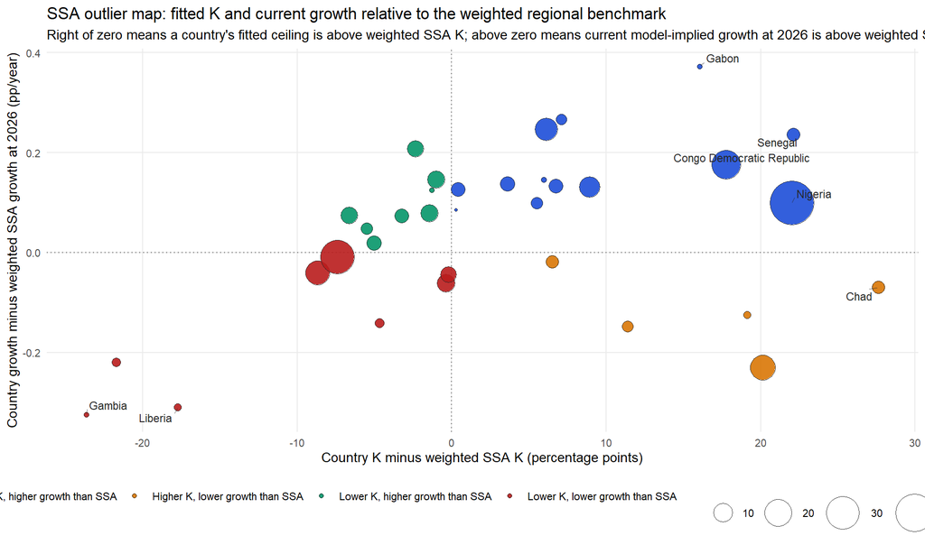

```r
ggplot(
  ssa_outlier_table,
  aes(
    x = k_diff_vs_ssa_pp,
    y = growth_diff_vs_ssa_pp_per_year,
    size = women_15_49_millions,
    fill = outlier_quadrant
  )
) +
  geom_vline(xintercept = 0, linetype = "dotted", color = "grey45", linewidth = 0.45) +
  geom_hline(yintercept = 0, linetype = "dotted", color = "grey45", linewidth = 0.45) +
  geom_point(shape = 21, color = "grey15", alpha = 0.9, stroke = 0.35) +
  ggrepel::geom_text_repel(
    data = ssa_outlier_table %>% filter(outlier_label_flag),
    aes(label = country),
    size = 3,
    color = "grey15",
    segment.alpha = 0.35,
    min.segment.length = 0
  ) +
  scale_fill_manual(values = ssa_outlier_quadrant_cols) +
  scale_size_area(max_size = 16, name = "Women 15-49\n(millions)") +
  theme_minimal(base_size = 10.5) +
  theme(
    legend.position = "bottom",
    legend.title = element_blank(),
    panel.grid.minor = element_blank()
  ) +
  labs(
    title = "SSA outlier map: fitted K and current growth relative to the weighted regional benchmark",
    subtitle = "Right of zero means a country's fitted ceiling is above weighted SSA K; above zero means current model-implied growth at 2026 is above weighted SSA growth",
    x = "Country K minus weighted SSA K (percentage points)",
    y = "Country growth minus weighted SSA growth at 2026 (pp/year)"
  )
```

## 24.22 S-curve stage positioning for the weighted SSA region and all SSA countries

This section keeps the same logistic stage logic as the country stage classification above. For the weighted regional views, we classify the weighted curve at `2025`, so the marked current position and the reported stage are aligned. For the country panels below, the existing `2026` stage rule is unchanged.

### 24.22.1 Weighted SSA region on the S curve

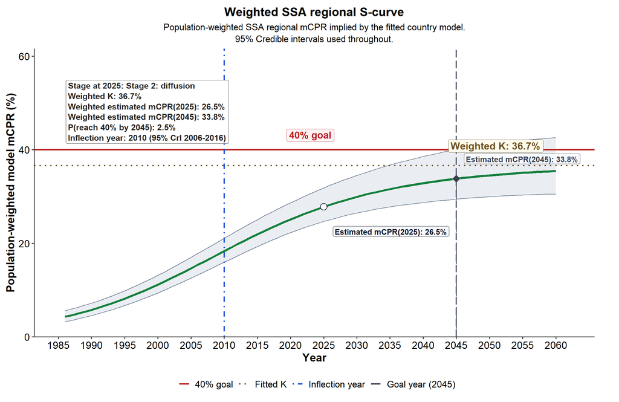

```r
plot_weighted_ssa_stage_view(
  stage_plot_df = ssa_region_stage_plot,
  stage_summary_df = ssa_region_stage_summary,
  stage_note_text = ssa_region_stage_note,
  title_text = "Weighted SSA regional S-curve",
  subtitle_text = paste0(
    "Population-weighted SSA regional mCPR implied by the fitted country model.\n",
    "95% Credible intervals used throughout."
  ),
  k_label_prefix = "Weighted",
  y_axis_label = "Population-weighted model mCPR (%)"
)
```

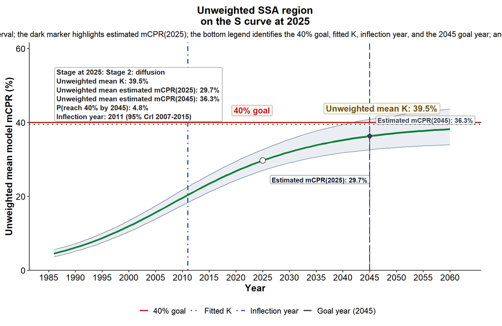

```r
plot_weighted_ssa_stage_view(
  stage_plot_df = ssa_region_stage_plot_unweighted,
  stage_summary_df = ssa_region_stage_summary_unweighted,
  stage_note_text = ssa_region_stage_note_unweighted,
  title_text = "Unweighted SSA region\non the S curve at 2025",
  subtitle_text = paste0("This is the simple equal-country mean regional mCPR implied by the fitted country model. The grey band and boundary lines show the 95% credible interval; the dark marker highlights estimated mCPR(2025); the bottom legend identifies the 40% goal, fitted K, inflection year, and the ", ssa_goal_final_target_year, " goal year; and the top-left box reports the projected unweighted regional level and probability of being at or above 40% by ", ssa_goal_final_target_year, ". The projection continues through 2060."),
  k_label_prefix = "Unweighted mean",
  y_axis_label = "Unweighted mean model mCPR (%)"
)
```